# Change In Single People’s Attachment And Co-Development With Life Satisfaction

##### 4.2.7.1.5 Avoidance: Father

Full model results for avoidance (father) (in the consistently single people):

```r
broom::tidy(get(paste0("fit_rq2_", outcomes$short[5])), conf.int = TRUE, conf.level = 0.95) %>%
  filter(label != "") %>%
  arrange(label) %>%
  select(term = label, est = estimate, ci_lo = conf.low, ci_hi = conf.high, p_value = p.value, est_std = std.all) %>%
  knitr::kable(digits = 3)
```

| term | est | ci_lo | ci_hi | p_value | est_std |
| --- | --- | --- | --- | --- | --- |
| a0 | 3.423 | 3.323 | 3.523 | 0.000 | 3.416 |
| a1 | -0.300 | -0.423 | -0.177 | 0.000 | -0.318 |
| bi | 0.035 | -0.073 | 0.143 | 0.530 | 0.029 |
| bs | -0.005 | -0.139 | 0.129 | 0.939 | -0.005 |
| cis | -0.134 | -0.252 | -0.017 | 0.025 | -0.142 |
| pred_t00 | 3.423 | 3.323 | 3.523 | 0.000 | 3.416 |
| pred_t01 | 3.413 | 3.314 | 3.511 | 0.000 | 3.405 |
| pred_t02 | 3.402 | 3.304 | 3.500 | 0.000 | 3.394 |
| pred_t03 | 3.392 | 3.294 | 3.490 | 0.000 | 3.383 |
| pred_t04 | 3.381 | 3.284 | 3.479 | 0.000 | 3.372 |
| pred_t05 | 3.371 | 3.274 | 3.469 | 0.000 | 3.361 |
| pred_t06 | 3.361 | 3.263 | 3.458 | 0.000 | 3.350 |
| pred_t07 | 3.350 | 3.253 | 3.448 | 0.000 | 3.340 |
| pred_t08 | 3.340 | 3.242 | 3.438 | 0.000 | 3.329 |
| pred_t09 | 3.330 | 3.231 | 3.429 | 0.000 | 3.318 |
| pred_t10 | 3.319 | 3.220 | 3.419 | 0.000 | 3.307 |
| pred_t11 | 3.309 | 3.208 | 3.410 | 0.000 | 3.296 |
| pred_t12 | 3.299 | 3.197 | 3.401 | 0.000 | 3.285 |
| pred_t13 | 3.288 | 3.185 | 3.392 | 0.000 | 3.274 |
| pred_t14 | 3.278 | 3.173 | 3.383 | 0.000 | 3.263 |
| pred_t15 | 3.268 | 3.161 | 3.374 | 0.000 | 3.252 |
| pred_t16 | 3.257 | 3.149 | 3.365 | 0.000 | 3.241 |
| pred_t17 | 3.247 | 3.137 | 3.357 | 0.000 | 3.230 |
| pred_t18 | 3.237 | 3.124 | 3.349 | 0.000 | 3.219 |
| pred_t19 | 3.226 | 3.112 | 3.341 | 0.000 | 3.208 |
| pred_t20 | 3.216 | 3.099 | 3.332 | 0.000 | 3.197 |
| pred_t21 | 3.206 | 3.087 | 3.324 | 0.000 | 3.186 |
| pred_t22 | 3.195 | 3.074 | 3.317 | 0.000 | 3.175 |
| pred_t23 | 3.185 | 3.061 | 3.309 | 0.000 | 3.164 |
| pred_t24 | 3.175 | 3.048 | 3.301 | 0.000 | 3.153 |
| pred_t25 | 3.164 | 3.035 | 3.294 | 0.000 | 3.142 |
| pred_t26 | 3.154 | 3.022 | 3.286 | 0.000 | 3.131 |
| pred_t27 | 3.143 | 3.008 | 3.279 | 0.000 | 3.120 |
| pred_t28 | 3.133 | 2.995 | 3.271 | 0.000 | 3.109 |
| pred_t29 | 3.123 | 2.982 | 3.264 | 0.000 | 3.098 |
| res_00 | 0.223 | 0.189 | 0.258 | 0.000 | 0.182 |
| res_01 | 0.129 | 0.100 | 0.158 | 0.000 | 0.115 |
| res_02 | 0.110 | 0.087 | 0.133 | 0.000 | 0.100 |
| res_03 | 0.155 | 0.124 | 0.186 | 0.000 | 0.136 |
| res_04 | 0.151 | 0.120 | 0.182 | 0.000 | 0.133 |
| res_05 | 0.123 | 0.098 | 0.149 | 0.000 | 0.112 |
| res_06 | 0.132 | 0.105 | 0.160 | 0.000 | 0.118 |
| res_07 | 0.174 | 0.139 | 0.208 | 0.000 | 0.149 |
| res_08 | 0.128 | 0.101 | 0.155 | 0.000 | 0.114 |
| res_09 | 0.123 | 0.096 | 0.149 | 0.000 | 0.109 |
| res_10 | 0.112 | 0.088 | 0.136 | 0.000 | 0.099 |
| res_11 | 0.123 | 0.096 | 0.150 | 0.000 | 0.107 |
| res_12 | 0.078 | 0.059 | 0.096 | 0.000 | 0.069 |
| res_13 | 0.083 | 0.062 | 0.104 | 0.000 | 0.073 |
| res_14 | 0.114 | 0.083 | 0.144 | 0.000 | 0.095 |
| res_15 | 0.096 | 0.068 | 0.123 | 0.000 | 0.080 |
| res_16 | 0.129 | 0.092 | 0.167 | 0.000 | 0.103 |
| res_17 | 0.071 | 0.046 | 0.097 | 0.000 | 0.058 |
| res_18 | 0.111 | 0.073 | 0.149 | 0.000 | 0.086 |
| res_19 | 0.091 | 0.059 | 0.123 | 0.000 | 0.070 |
| res_20 | 0.115 | 0.074 | 0.156 | 0.000 | 0.085 |
| res_21 | 0.088 | 0.055 | 0.120 | 0.000 | 0.064 |
| res_22 | 0.058 | 0.034 | 0.082 | 0.000 | 0.042 |
| res_23 | 0.066 | 0.040 | 0.092 | 0.000 | 0.046 |
| res_24 | 0.162 | 0.105 | 0.219 | 0.000 | 0.104 |
| res_25 | 0.077 | 0.043 | 0.110 | 0.000 | 0.051 |
| res_26 | 0.067 | 0.035 | 0.098 | 0.000 | 0.043 |
| res_27 | 0.033 | 0.010 | 0.057 | 0.006 | 0.021 |
| res_28 | 0.083 | 0.035 | 0.130 | 0.001 | 0.050 |
| res_29 | 0.185 | 0.088 | 0.283 | 0.000 | 0.102 |
| vi | 1.003 | 0.870 | 1.136 | 0.000 | 0.999 |
| vs | 0.890 | 0.692 | 1.088 | 0.000 | 1.000 |

Full model results for avoidance (father) (in the consistently partnered people):

```r
broom::tidy(get(paste0("fit_rq2_", outcomes$short[5], "_partn_c")), conf.int = TRUE, conf.level = 0.95) %>%
  filter(label != "") %>%
  arrange(label) %>%
  select(term = label, est = estimate, ci_lo = conf.low, ci_hi = conf.high, p_value = p.value, est_std = std.all) %>%
  knitr::kable(digits = 3)
```

| term | est | ci_lo | ci_hi | p_value | est_std |
| --- | --- | --- | --- | --- | --- |
| a0 | 3.248 | 3.187 | 3.309 | 0.000 | 3.028 |
| a1 | -0.231 | -0.300 | -0.162 | 0.000 | -0.249 |
| bi | 0.106 | 0.028 | 0.184 | 0.008 | 0.077 |
| bs | 0.114 | 0.026 | 0.202 | 0.012 | 0.096 |
| cis | -0.208 | -0.285 | -0.130 | 0.000 | -0.210 |
| pred_t00 | 3.248 | 3.187 | 3.309 | 0.000 | 3.028 |
| pred_t01 | 3.240 | 3.179 | 3.300 | 0.000 | 3.019 |
| pred_t02 | 3.232 | 3.172 | 3.292 | 0.000 | 3.011 |
| pred_t03 | 3.224 | 3.164 | 3.284 | 0.000 | 3.002 |
| pred_t04 | 3.216 | 3.156 | 3.275 | 0.000 | 2.993 |
| pred_t05 | 3.208 | 3.149 | 3.267 | 0.000 | 2.985 |
| pred_t06 | 3.200 | 3.141 | 3.259 | 0.000 | 2.976 |
| pred_t07 | 3.192 | 3.133 | 3.251 | 0.000 | 2.968 |
| pred_t08 | 3.184 | 3.125 | 3.243 | 0.000 | 2.959 |
| pred_t09 | 3.176 | 3.117 | 3.235 | 0.000 | 2.950 |
| pred_t10 | 3.168 | 3.109 | 3.228 | 0.000 | 2.942 |
| pred_t11 | 3.160 | 3.100 | 3.220 | 0.000 | 2.933 |
| pred_t12 | 3.152 | 3.092 | 3.212 | 0.000 | 2.925 |
| pred_t13 | 3.144 | 3.083 | 3.205 | 0.000 | 2.916 |
| pred_t14 | 3.136 | 3.075 | 3.198 | 0.000 | 2.907 |
| pred_t15 | 3.128 | 3.066 | 3.190 | 0.000 | 2.899 |
| pred_t16 | 3.120 | 3.057 | 3.183 | 0.000 | 2.890 |
| pred_t17 | 3.112 | 3.048 | 3.176 | 0.000 | 2.882 |
| pred_t18 | 3.104 | 3.040 | 3.169 | 0.000 | 2.873 |
| pred_t19 | 3.096 | 3.031 | 3.162 | 0.000 | 2.864 |
| pred_t20 | 3.088 | 3.022 | 3.155 | 0.000 | 2.856 |
| pred_t21 | 3.080 | 3.012 | 3.148 | 0.000 | 2.847 |
| pred_t22 | 3.072 | 3.003 | 3.142 | 0.000 | 2.839 |
| pred_t23 | 3.065 | 2.994 | 3.135 | 0.000 | 2.830 |
| pred_t24 | 3.057 | 2.985 | 3.128 | 0.000 | 2.821 |
| pred_t25 | 3.049 | 2.975 | 3.122 | 0.000 | 2.813 |
| pred_t26 | 3.041 | 2.966 | 3.115 | 0.000 | 2.804 |
| pred_t27 | 3.033 | 2.957 | 3.109 | 0.000 | 2.796 |
| pred_t28 | 3.025 | 2.947 | 3.102 | 0.000 | 2.787 |
| pred_t29 | 3.017 | 2.938 | 3.096 | 0.000 | 2.778 |
| res_00 | 0.227 | 0.205 | 0.250 | 0.000 | 0.165 |
| res_01 | 0.162 | 0.139 | 0.184 | 0.000 | 0.124 |
| res_02 | 0.135 | 0.118 | 0.153 | 0.000 | 0.107 |
| res_03 | 0.152 | 0.132 | 0.171 | 0.000 | 0.120 |
| res_04 | 0.107 | 0.091 | 0.122 | 0.000 | 0.088 |
| res_05 | 0.133 | 0.115 | 0.152 | 0.000 | 0.107 |
| res_06 | 0.162 | 0.139 | 0.185 | 0.000 | 0.128 |
| res_07 | 0.112 | 0.097 | 0.127 | 0.000 | 0.092 |
| res_08 | 0.111 | 0.095 | 0.127 | 0.000 | 0.091 |
| res_09 | 0.102 | 0.088 | 0.117 | 0.000 | 0.085 |
| res_10 | 0.109 | 0.093 | 0.124 | 0.000 | 0.089 |
| res_11 | 0.113 | 0.097 | 0.128 | 0.000 | 0.091 |
| res_12 | 0.117 | 0.101 | 0.134 | 0.000 | 0.094 |
| res_13 | 0.101 | 0.086 | 0.117 | 0.000 | 0.081 |
| res_14 | 0.135 | 0.114 | 0.156 | 0.000 | 0.105 |
| res_15 | 0.120 | 0.100 | 0.140 | 0.000 | 0.093 |
| res_16 | 0.123 | 0.101 | 0.146 | 0.000 | 0.094 |
| res_17 | 0.096 | 0.077 | 0.115 | 0.000 | 0.073 |
| res_18 | 0.127 | 0.101 | 0.153 | 0.000 | 0.093 |
| res_19 | 0.079 | 0.062 | 0.097 | 0.000 | 0.059 |
| res_20 | 0.074 | 0.058 | 0.091 | 0.000 | 0.055 |
| res_21 | 0.119 | 0.093 | 0.145 | 0.000 | 0.083 |
| res_22 | 0.105 | 0.083 | 0.127 | 0.000 | 0.072 |
| res_23 | 0.086 | 0.067 | 0.106 | 0.000 | 0.059 |
| res_24 | 0.086 | 0.066 | 0.106 | 0.000 | 0.057 |
| res_25 | 0.091 | 0.069 | 0.113 | 0.000 | 0.059 |
| res_26 | 0.126 | 0.094 | 0.159 | 0.000 | 0.079 |
| res_27 | 0.086 | 0.058 | 0.113 | 0.000 | 0.053 |
| res_28 | 0.112 | 0.074 | 0.150 | 0.000 | 0.067 |
| res_29 | 0.137 | 0.090 | 0.184 | 0.000 | 0.079 |
| vi | 1.144 | 1.049 | 1.238 | 0.000 | 0.994 |
| vs | 0.850 | 0.732 | 0.969 | 0.000 | 0.991 |

##### 4.2.7.1.6 Anxiety: Global

Full model results for anxiety (global) (in the consistently single people):

```r
broom::tidy(get(paste0("fit_rq2_", outcomes$short[6])), conf.int = TRUE, conf.level = 0.95) %>%
  filter(label != "") %>%
  arrange(label) %>%
  select(term = label, est = estimate, ci_lo = conf.low, ci_hi = conf.high, p_value = p.value, est_std = std.all) %>%
  knitr::kable(digits = 3)
```

| term | est | ci_lo | ci_hi | p_value | est_std |
| --- | --- | --- | --- | --- | --- |
| a0 | 3.415 | 3.339 | 3.492 | 0.000 | 3.735 |
| a1 | -0.905 | -1.030 | -0.779 | 0.000 | -0.811 |
| bi | 0.000 | -0.069 | 0.068 | 0.993 | 0.000 |
| bs | -0.072 | -0.182 | 0.038 | 0.198 | -0.072 |
| cis | -0.136 | -0.260 | -0.012 | 0.032 | -0.134 |
| pred_t00 | 3.415 | 3.339 | 3.492 | 0.000 | 3.735 |
| pred_t01 | 3.384 | 3.308 | 3.459 | 0.000 | 3.707 |
| pred_t02 | 3.353 | 3.278 | 3.427 | 0.000 | 3.679 |
| pred_t03 | 3.322 | 3.247 | 3.396 | 0.000 | 3.651 |
| pred_t04 | 3.290 | 3.217 | 3.364 | 0.000 | 3.623 |
| pred_t05 | 3.259 | 3.185 | 3.333 | 0.000 | 3.595 |
| pred_t06 | 3.228 | 3.154 | 3.302 | 0.000 | 3.567 |
| pred_t07 | 3.197 | 3.122 | 3.271 | 0.000 | 3.539 |
| pred_t08 | 3.166 | 3.090 | 3.241 | 0.000 | 3.511 |
| pred_t09 | 3.134 | 3.058 | 3.210 | 0.000 | 3.483 |
| pred_t10 | 3.103 | 3.026 | 3.180 | 0.000 | 3.455 |
| pred_t11 | 3.072 | 2.993 | 3.151 | 0.000 | 3.427 |
| pred_t12 | 3.041 | 2.961 | 3.121 | 0.000 | 3.399 |
| pred_t13 | 3.010 | 2.928 | 3.092 | 0.000 | 3.371 |
| pred_t14 | 2.978 | 2.894 | 3.062 | 0.000 | 3.343 |
| pred_t15 | 2.947 | 2.861 | 3.033 | 0.000 | 3.315 |
| pred_t16 | 2.916 | 2.827 | 3.004 | 0.000 | 3.287 |
| pred_t17 | 2.885 | 2.794 | 2.976 | 0.000 | 3.259 |
| pred_t18 | 2.854 | 2.760 | 2.947 | 0.000 | 3.231 |
| pred_t19 | 2.822 | 2.726 | 2.919 | 0.000 | 3.204 |
| pred_t20 | 2.791 | 2.692 | 2.890 | 0.000 | 3.176 |
| pred_t21 | 2.760 | 2.658 | 2.862 | 0.000 | 3.148 |
| pred_t22 | 2.729 | 2.624 | 2.834 | 0.000 | 3.120 |
| pred_t23 | 2.698 | 2.589 | 2.806 | 0.000 | 3.092 |
| pred_t24 | 2.666 | 2.555 | 2.778 | 0.000 | 3.064 |
| pred_t25 | 2.635 | 2.520 | 2.750 | 0.000 | 3.036 |
| pred_t26 | 2.604 | 2.486 | 2.722 | 0.000 | 3.008 |
| pred_t27 | 2.573 | 2.451 | 2.694 | 0.000 | 2.980 |
| pred_t28 | 2.542 | 2.417 | 2.666 | 0.000 | 2.952 |
| pred_t29 | 2.510 | 2.382 | 2.639 | 0.000 | 2.924 |
| res_00 | 0.368 | 0.317 | 0.418 | 0.000 | 0.305 |
| res_01 | 0.284 | 0.230 | 0.338 | 0.000 | 0.255 |
| res_02 | 0.256 | 0.211 | 0.301 | 0.000 | 0.237 |
| res_03 | 0.287 | 0.237 | 0.337 | 0.000 | 0.259 |
| res_04 | 0.336 | 0.276 | 0.396 | 0.000 | 0.290 |
| res_05 | 0.325 | 0.268 | 0.382 | 0.000 | 0.283 |
| res_06 | 0.317 | 0.260 | 0.375 | 0.000 | 0.276 |
| res_07 | 0.264 | 0.217 | 0.312 | 0.000 | 0.239 |
| res_08 | 0.256 | 0.208 | 0.303 | 0.000 | 0.230 |
| res_09 | 0.256 | 0.208 | 0.304 | 0.000 | 0.227 |
| res_10 | 0.274 | 0.225 | 0.323 | 0.000 | 0.235 |
| res_11 | 0.225 | 0.182 | 0.268 | 0.000 | 0.198 |
| res_12 | 0.254 | 0.204 | 0.304 | 0.000 | 0.213 |
| res_13 | 0.272 | 0.217 | 0.327 | 0.000 | 0.220 |
| res_14 | 0.260 | 0.204 | 0.316 | 0.000 | 0.207 |
| res_15 | 0.239 | 0.181 | 0.297 | 0.000 | 0.188 |
| res_16 | 0.288 | 0.218 | 0.359 | 0.000 | 0.213 |
| res_17 | 0.227 | 0.161 | 0.293 | 0.000 | 0.171 |
| res_18 | 0.316 | 0.225 | 0.408 | 0.000 | 0.216 |
| res_19 | 0.192 | 0.132 | 0.251 | 0.000 | 0.139 |
| res_20 | 0.204 | 0.140 | 0.268 | 0.000 | 0.141 |
| res_21 | 0.262 | 0.183 | 0.341 | 0.000 | 0.169 |
| res_22 | 0.251 | 0.170 | 0.333 | 0.000 | 0.157 |
| res_23 | 0.134 | 0.087 | 0.182 | 0.000 | 0.087 |
| res_24 | 0.180 | 0.120 | 0.240 | 0.000 | 0.109 |
| res_25 | 0.198 | 0.124 | 0.271 | 0.000 | 0.115 |
| res_26 | 0.268 | 0.166 | 0.370 | 0.000 | 0.144 |
| res_27 | 0.435 | 0.249 | 0.621 | 0.000 | 0.208 |
| res_28 | 0.149 | 0.063 | 0.235 | 0.001 | 0.079 |
| res_29 | 0.905 | 0.512 | 1.298 | 0.000 | 0.333 |
| vi | 0.836 | 0.731 | 0.941 | 0.000 | 1.000 |
| vs | 1.238 | 0.980 | 1.497 | 0.000 | 0.995 |

Full model results for anxiety (global) (in the consistently partnered people):

```r
broom::tidy(get(paste0("fit_rq2_", outcomes$short[6], "_partn_c")), conf.int = TRUE, conf.level = 0.95) %>%
  filter(label != "") %>%
  arrange(label) %>%
  select(term = label, est = estimate, ci_lo = conf.low, ci_hi = conf.high, p_value = p.value, est_std = std.all) %>%
  knitr::kable(digits = 3)
```

| term | est | ci_lo | ci_hi | p_value | est_std |
| --- | --- | --- | --- | --- | --- |
| a0 | 3.072 | 3.021 | 3.122 | 0.000 | 3.218 |
| a1 | -0.993 | -1.069 | -0.917 | 0.000 | -0.962 |
| bi | -0.159 | -0.209 | -0.110 | 0.000 | -0.167 |
| bs | 0.109 | 0.038 | 0.180 | 0.003 | 0.105 |
| cis | -0.293 | -0.370 | -0.216 | 0.000 | -0.303 |
| pred_t00 | 3.072 | 3.021 | 3.122 | 0.000 | 3.218 |
| pred_t01 | 3.037 | 2.988 | 3.087 | 0.000 | 3.185 |
| pred_t02 | 3.003 | 2.955 | 3.052 | 0.000 | 3.152 |
| pred_t03 | 2.969 | 2.921 | 3.017 | 0.000 | 3.119 |
| pred_t04 | 2.935 | 2.887 | 2.982 | 0.000 | 3.085 |
| pred_t05 | 2.901 | 2.854 | 2.947 | 0.000 | 3.052 |
| pred_t06 | 2.866 | 2.820 | 2.913 | 0.000 | 3.019 |
| pred_t07 | 2.832 | 2.786 | 2.878 | 0.000 | 2.986 |
| pred_t08 | 2.798 | 2.751 | 2.844 | 0.000 | 2.953 |
| pred_t09 | 2.764 | 2.717 | 2.810 | 0.000 | 2.920 |
| pred_t10 | 2.729 | 2.682 | 2.776 | 0.000 | 2.886 |
| pred_t11 | 2.695 | 2.648 | 2.742 | 0.000 | 2.853 |
| pred_t12 | 2.661 | 2.613 | 2.709 | 0.000 | 2.820 |
| pred_t13 | 2.627 | 2.578 | 2.675 | 0.000 | 2.787 |
| pred_t14 | 2.592 | 2.543 | 2.642 | 0.000 | 2.754 |
| pred_t15 | 2.558 | 2.508 | 2.608 | 0.000 | 2.721 |
| pred_t16 | 2.524 | 2.472 | 2.575 | 0.000 | 2.688 |
| pred_t17 | 2.490 | 2.437 | 2.542 | 0.000 | 2.654 |
| pred_t18 | 2.455 | 2.401 | 2.509 | 0.000 | 2.621 |
| pred_t19 | 2.421 | 2.366 | 2.476 | 0.000 | 2.588 |
| pred_t20 | 2.387 | 2.330 | 2.444 | 0.000 | 2.555 |
| pred_t21 | 2.353 | 2.294 | 2.411 | 0.000 | 2.522 |
| pred_t22 | 2.318 | 2.258 | 2.378 | 0.000 | 2.489 |
| pred_t23 | 2.284 | 2.222 | 2.346 | 0.000 | 2.455 |
| pred_t24 | 2.250 | 2.186 | 2.313 | 0.000 | 2.422 |
| pred_t25 | 2.216 | 2.150 | 2.281 | 0.000 | 2.389 |
| pred_t26 | 2.181 | 2.114 | 2.248 | 0.000 | 2.356 |
| pred_t27 | 2.147 | 2.078 | 2.216 | 0.000 | 2.323 |
| pred_t28 | 2.113 | 2.042 | 2.184 | 0.000 | 2.290 |
| pred_t29 | 2.079 | 2.006 | 2.152 | 0.000 | 2.256 |
| res_00 | 0.454 | 0.415 | 0.492 | 0.000 | 0.332 |
| res_01 | 0.370 | 0.326 | 0.413 | 0.000 | 0.293 |
| res_02 | 0.290 | 0.257 | 0.323 | 0.000 | 0.250 |
| res_03 | 0.303 | 0.268 | 0.337 | 0.000 | 0.261 |
| res_04 | 0.290 | 0.255 | 0.324 | 0.000 | 0.255 |
| res_05 | 0.293 | 0.258 | 0.327 | 0.000 | 0.259 |
| res_06 | 0.294 | 0.258 | 0.330 | 0.000 | 0.262 |
| res_07 | 0.278 | 0.246 | 0.310 | 0.000 | 0.253 |
| res_08 | 0.271 | 0.239 | 0.303 | 0.000 | 0.248 |
| res_09 | 0.244 | 0.214 | 0.273 | 0.000 | 0.229 |
| res_10 | 0.262 | 0.231 | 0.293 | 0.000 | 0.241 |
| res_11 | 0.271 | 0.238 | 0.303 | 0.000 | 0.246 |
| res_12 | 0.239 | 0.210 | 0.268 | 0.000 | 0.222 |
| res_13 | 0.246 | 0.215 | 0.278 | 0.000 | 0.225 |
| res_14 | 0.243 | 0.209 | 0.276 | 0.000 | 0.220 |
| res_15 | 0.221 | 0.188 | 0.253 | 0.000 | 0.201 |
| res_16 | 0.185 | 0.156 | 0.215 | 0.000 | 0.172 |
| res_17 | 0.235 | 0.197 | 0.274 | 0.000 | 0.205 |
| res_18 | 0.195 | 0.160 | 0.229 | 0.000 | 0.172 |
| res_19 | 0.225 | 0.185 | 0.265 | 0.000 | 0.190 |
| res_20 | 0.204 | 0.167 | 0.241 | 0.000 | 0.171 |
| res_21 | 0.212 | 0.172 | 0.251 | 0.000 | 0.172 |
| res_22 | 0.227 | 0.186 | 0.267 | 0.000 | 0.177 |
| res_23 | 0.165 | 0.132 | 0.198 | 0.000 | 0.132 |
| res_24 | 0.168 | 0.134 | 0.202 | 0.000 | 0.130 |
| res_25 | 0.238 | 0.189 | 0.286 | 0.000 | 0.169 |
| res_26 | 0.264 | 0.206 | 0.321 | 0.000 | 0.179 |
| res_27 | 0.197 | 0.143 | 0.251 | 0.000 | 0.135 |
| res_28 | 0.243 | 0.175 | 0.311 | 0.000 | 0.157 |
| res_29 | 0.231 | 0.161 | 0.302 | 0.000 | 0.146 |
| vi | 0.886 | 0.816 | 0.956 | 0.000 | 0.972 |
| vs | 1.055 | 0.906 | 1.203 | 0.000 | 0.989 |

##### 4.2.7.1.7 Anxiety: Romantic

Full model results for anxiety (romantic) (in the consistently single people):

```r
broom::tidy(get(paste0("fit_rq2_", outcomes$short[7])), conf.int = TRUE, conf.level = 0.95) %>%
  filter(label != "") %>%
  arrange(label) %>%
  select(term = label, est = estimate, ci_lo = conf.low, ci_hi = conf.high, p_value = p.value, est_std = std.all) %>%
  knitr::kable(digits = 3)
```

| term | est | ci_lo | ci_hi | p_value | est_std |
| --- | --- | --- | --- | --- | --- |
| a0 | 3.285 | 3.204 | 3.366 | 0.000 | 3.397 |
| a1 | -0.783 | -0.922 | -0.645 | 0.000 | -0.618 |
| bi | 0.008 | -0.065 | 0.081 | 0.836 | 0.009 |
| bs | -0.123 | -0.245 | -0.001 | 0.047 | -0.108 |
| cis | -0.175 | -0.318 | -0.032 | 0.017 | -0.143 |
| pred_t00 | 3.285 | 3.204 | 3.366 | 0.000 | 3.397 |
| pred_t01 | 3.258 | 3.178 | 3.338 | 0.000 | 3.376 |
| pred_t02 | 3.231 | 3.152 | 3.310 | 0.000 | 3.355 |
| pred_t03 | 3.204 | 3.125 | 3.282 | 0.000 | 3.333 |
| pred_t04 | 3.177 | 3.099 | 3.255 | 0.000 | 3.312 |
| pred_t05 | 3.150 | 3.072 | 3.228 | 0.000 | 3.291 |
| pred_t06 | 3.123 | 3.044 | 3.201 | 0.000 | 3.269 |
| pred_t07 | 3.096 | 3.017 | 3.174 | 0.000 | 3.248 |
| pred_t08 | 3.069 | 2.989 | 3.148 | 0.000 | 3.227 |
| pred_t09 | 3.042 | 2.961 | 3.122 | 0.000 | 3.205 |
| pred_t10 | 3.014 | 2.932 | 3.096 | 0.000 | 3.184 |
| pred_t11 | 2.987 | 2.904 | 3.071 | 0.000 | 3.163 |
| pred_t12 | 2.960 | 2.875 | 3.046 | 0.000 | 3.142 |
| pred_t13 | 2.933 | 2.846 | 3.021 | 0.000 | 3.120 |
| pred_t14 | 2.906 | 2.817 | 2.996 | 0.000 | 3.099 |
| pred_t15 | 2.879 | 2.787 | 2.972 | 0.000 | 3.078 |
| pred_t16 | 2.852 | 2.758 | 2.947 | 0.000 | 3.056 |
| pred_t17 | 2.825 | 2.728 | 2.923 | 0.000 | 3.035 |
| pred_t18 | 2.798 | 2.698 | 2.899 | 0.000 | 3.014 |
| pred_t19 | 2.771 | 2.668 | 2.875 | 0.000 | 2.992 |
| pred_t20 | 2.744 | 2.637 | 2.851 | 0.000 | 2.971 |
| pred_t21 | 2.717 | 2.607 | 2.828 | 0.000 | 2.950 |
| pred_t22 | 2.690 | 2.577 | 2.804 | 0.000 | 2.928 |
| pred_t23 | 2.663 | 2.546 | 2.780 | 0.000 | 2.907 |
| pred_t24 | 2.636 | 2.516 | 2.757 | 0.000 | 2.886 |
| pred_t25 | 2.609 | 2.485 | 2.734 | 0.000 | 2.864 |
| pred_t26 | 2.582 | 2.454 | 2.710 | 0.000 | 2.843 |
| pred_t27 | 2.555 | 2.423 | 2.687 | 0.000 | 2.822 |
| pred_t28 | 2.528 | 2.392 | 2.664 | 0.000 | 2.800 |
| pred_t29 | 2.501 | 2.361 | 2.641 | 0.000 | 2.779 |
| res_00 | 0.557 | 0.483 | 0.630 | 0.000 | 0.373 |
| res_01 | 0.254 | 0.202 | 0.306 | 0.000 | 0.215 |
| res_02 | 0.376 | 0.313 | 0.439 | 0.000 | 0.291 |
| res_03 | 0.294 | 0.242 | 0.347 | 0.000 | 0.243 |
| res_04 | 0.389 | 0.320 | 0.458 | 0.000 | 0.298 |
| res_05 | 0.360 | 0.297 | 0.423 | 0.000 | 0.281 |
| res_06 | 0.293 | 0.238 | 0.347 | 0.000 | 0.239 |
| res_07 | 0.387 | 0.320 | 0.455 | 0.000 | 0.291 |
| res_08 | 0.282 | 0.230 | 0.334 | 0.000 | 0.227 |
| res_09 | 0.296 | 0.241 | 0.351 | 0.000 | 0.232 |
| res_10 | 0.244 | 0.198 | 0.289 | 0.000 | 0.195 |
| res_11 | 0.218 | 0.175 | 0.261 | 0.000 | 0.174 |
| res_12 | 0.238 | 0.191 | 0.286 | 0.000 | 0.183 |
| res_13 | 0.273 | 0.218 | 0.328 | 0.000 | 0.199 |
| res_14 | 0.250 | 0.195 | 0.306 | 0.000 | 0.180 |
| res_15 | 0.240 | 0.183 | 0.297 | 0.000 | 0.169 |
| res_16 | 0.280 | 0.212 | 0.348 | 0.000 | 0.186 |
| res_17 | 0.281 | 0.201 | 0.362 | 0.000 | 0.180 |
| res_18 | 0.145 | 0.100 | 0.190 | 0.000 | 0.098 |
| res_19 | 0.191 | 0.131 | 0.252 | 0.000 | 0.121 |
| res_20 | 0.194 | 0.132 | 0.255 | 0.000 | 0.117 |
| res_21 | 0.214 | 0.146 | 0.281 | 0.000 | 0.123 |
| res_22 | 0.194 | 0.126 | 0.262 | 0.000 | 0.109 |
| res_23 | 0.311 | 0.211 | 0.411 | 0.000 | 0.157 |
| res_24 | 0.241 | 0.164 | 0.317 | 0.000 | 0.121 |
| res_25 | 0.206 | 0.128 | 0.284 | 0.000 | 0.101 |
| res_26 | 0.402 | 0.255 | 0.548 | 0.000 | 0.174 |
| res_27 | 0.265 | 0.145 | 0.385 | 0.000 | 0.117 |
| res_28 | 0.201 | 0.099 | 0.303 | 0.000 | 0.088 |
| res_29 | 0.342 | 0.175 | 0.510 | 0.000 | 0.135 |
| vi | 0.935 | 0.817 | 1.052 | 0.000 | 1.000 |
| vs | 1.588 | 1.265 | 1.910 | 0.000 | 0.988 |

Full model results for anxiety (romantic) (in the consistently partnered people):

```r
broom::tidy(get(paste0("fit_rq2_", outcomes$short[7], "_partn_c")), conf.int = TRUE, conf.level = 0.95) %>%
  filter(label != "") %>%
  arrange(label) %>%
  select(term = label, est = estimate, ci_lo = conf.low, ci_hi = conf.high, p_value = p.value, est_std = std.all) %>%
  knitr::kable(digits = 3)
```

| term | est | ci_lo | ci_hi | p_value | est_std |
| --- | --- | --- | --- | --- | --- |
| a0 | 2.379 | 2.326 | 2.432 | 0.000 | 2.382 |
| a1 | -0.675 | -0.753 | -0.597 | 0.000 | -0.601 |
| bi | -0.030 | -0.082 | 0.021 | 0.251 | -0.030 |
| bs | 0.103 | 0.029 | 0.177 | 0.006 | 0.092 |
| cis | -0.523 | -0.613 | -0.433 | 0.000 | -0.469 |
| pred_t00 | 2.379 | 2.326 | 2.432 | 0.000 | 2.382 |
| pred_t01 | 2.355 | 2.304 | 2.407 | 0.000 | 2.361 |
| pred_t02 | 2.332 | 2.281 | 2.383 | 0.000 | 2.341 |
| pred_t03 | 2.309 | 2.259 | 2.358 | 0.000 | 2.320 |
| pred_t04 | 2.285 | 2.237 | 2.334 | 0.000 | 2.299 |
| pred_t05 | 2.262 | 2.214 | 2.310 | 0.000 | 2.278 |
| pred_t06 | 2.239 | 2.192 | 2.286 | 0.000 | 2.258 |
| pred_t07 | 2.216 | 2.169 | 2.262 | 0.000 | 2.237 |
| pred_t08 | 2.192 | 2.146 | 2.239 | 0.000 | 2.216 |
| pred_t09 | 2.169 | 2.123 | 2.215 | 0.000 | 2.196 |
| pred_t10 | 2.146 | 2.100 | 2.192 | 0.000 | 2.175 |
| pred_t11 | 2.123 | 2.076 | 2.169 | 0.000 | 2.154 |
| pred_t12 | 2.099 | 2.053 | 2.146 | 0.000 | 2.133 |
| pred_t13 | 2.076 | 2.029 | 2.123 | 0.000 | 2.113 |
| pred_t14 | 2.053 | 2.005 | 2.100 | 0.000 | 2.092 |
| pred_t15 | 2.030 | 1.981 | 2.078 | 0.000 | 2.071 |
| pred_t16 | 2.006 | 1.957 | 2.055 | 0.000 | 2.050 |
| pred_t17 | 1.983 | 1.933 | 2.033 | 0.000 | 2.030 |
| pred_t18 | 1.960 | 1.909 | 2.011 | 0.000 | 2.009 |
| pred_t19 | 1.937 | 1.884 | 1.989 | 0.000 | 1.988 |
| pred_t20 | 1.913 | 1.860 | 1.967 | 0.000 | 1.967 |
| pred_t21 | 1.890 | 1.835 | 1.945 | 0.000 | 1.947 |
| pred_t22 | 1.867 | 1.810 | 1.923 | 0.000 | 1.926 |
| pred_t23 | 1.844 | 1.785 | 1.902 | 0.000 | 1.905 |
| pred_t24 | 1.820 | 1.760 | 1.880 | 0.000 | 1.884 |
| pred_t25 | 1.797 | 1.735 | 1.859 | 0.000 | 1.864 |
| pred_t26 | 1.774 | 1.710 | 1.837 | 0.000 | 1.843 |
| pred_t27 | 1.750 | 1.685 | 1.816 | 0.000 | 1.822 |
| pred_t28 | 1.727 | 1.660 | 1.795 | 0.000 | 1.801 |
| pred_t29 | 1.704 | 1.635 | 1.773 | 0.000 | 1.781 |
| res_00 | 0.519 | 0.475 | 0.562 | 0.000 | 0.342 |
| res_01 | 0.371 | 0.327 | 0.415 | 0.000 | 0.278 |
| res_02 | 0.280 | 0.248 | 0.312 | 0.000 | 0.231 |
| res_03 | 0.302 | 0.266 | 0.337 | 0.000 | 0.251 |
| res_04 | 0.249 | 0.219 | 0.280 | 0.000 | 0.221 |
| res_05 | 0.280 | 0.247 | 0.314 | 0.000 | 0.247 |
| res_06 | 0.282 | 0.247 | 0.317 | 0.000 | 0.253 |
| res_07 | 0.226 | 0.199 | 0.253 | 0.000 | 0.217 |
| res_08 | 0.233 | 0.205 | 0.262 | 0.000 | 0.225 |
| res_09 | 0.235 | 0.207 | 0.264 | 0.000 | 0.229 |
| res_10 | 0.231 | 0.203 | 0.259 | 0.000 | 0.228 |
| res_11 | 0.214 | 0.188 | 0.239 | 0.000 | 0.215 |
| res_12 | 0.221 | 0.194 | 0.248 | 0.000 | 0.221 |
| res_13 | 0.227 | 0.197 | 0.256 | 0.000 | 0.226 |
| res_14 | 0.241 | 0.208 | 0.275 | 0.000 | 0.236 |
| res_15 | 0.203 | 0.172 | 0.233 | 0.000 | 0.204 |
| res_16 | 0.190 | 0.160 | 0.221 | 0.000 | 0.192 |
| res_17 | 0.230 | 0.192 | 0.269 | 0.000 | 0.221 |
| res_18 | 0.181 | 0.149 | 0.213 | 0.000 | 0.179 |
| res_19 | 0.228 | 0.188 | 0.268 | 0.000 | 0.212 |
| res_20 | 0.208 | 0.171 | 0.245 | 0.000 | 0.193 |
| res_21 | 0.148 | 0.120 | 0.177 | 0.000 | 0.142 |
| res_22 | 0.211 | 0.173 | 0.249 | 0.000 | 0.186 |
| res_23 | 0.141 | 0.112 | 0.169 | 0.000 | 0.129 |
| res_24 | 0.157 | 0.125 | 0.188 | 0.000 | 0.137 |
| res_25 | 0.137 | 0.107 | 0.166 | 0.000 | 0.118 |
| res_26 | 0.203 | 0.157 | 0.249 | 0.000 | 0.160 |
| res_27 | 0.195 | 0.144 | 0.247 | 0.000 | 0.150 |
| res_28 | 0.326 | 0.237 | 0.414 | 0.000 | 0.220 |
| res_29 | 0.240 | 0.166 | 0.313 | 0.000 | 0.166 |
| vi | 0.996 | 0.918 | 1.074 | 0.000 | 0.999 |
| vs | 1.247 | 1.076 | 1.418 | 0.000 | 0.992 |

##### 4.2.7.1.8 Anxiety: Best Friend

Full model results for anxiety (best friend) (in the consistently single people):

```r
broom::tidy(get(paste0("fit_rq2_", outcomes$short[8])), conf.int = TRUE, conf.level = 0.95) %>%
  filter(label != "") %>%
  arrange(label) %>%
  select(term = label, est = estimate, ci_lo = conf.low, ci_hi = conf.high, p_value = p.value, est_std = std.all) %>%
  knitr::kable(digits = 3)
```

| term | est | ci_lo | ci_hi | p_value | est_std |
| --- | --- | --- | --- | --- | --- |
| a0 | 2.324 | 2.244 | 2.405 | 0.000 | 2.397 |
| a1 | -0.213 | -0.346 | -0.080 | 0.002 | -0.171 |
| bi | 0.009 | -0.063 | 0.082 | 0.800 | 0.011 |
| bs | -0.088 | -0.206 | 0.030 | 0.146 | -0.078 |
| cis | -0.506 | -0.658 | -0.355 | 0.000 | -0.419 |
| pred_t00 | 2.324 | 2.244 | 2.405 | 0.000 | 2.397 |
| pred_t01 | 2.317 | 2.238 | 2.396 | 0.000 | 2.392 |
| pred_t02 | 2.310 | 2.233 | 2.387 | 0.000 | 2.386 |
| pred_t03 | 2.302 | 2.227 | 2.378 | 0.000 | 2.380 |
| pred_t04 | 2.295 | 2.221 | 2.369 | 0.000 | 2.374 |
| pred_t05 | 2.288 | 2.214 | 2.361 | 0.000 | 2.368 |
| pred_t06 | 2.280 | 2.208 | 2.353 | 0.000 | 2.362 |
| pred_t07 | 2.273 | 2.201 | 2.345 | 0.000 | 2.356 |
| pred_t08 | 2.266 | 2.194 | 2.338 | 0.000 | 2.350 |
| pred_t09 | 2.258 | 2.186 | 2.330 | 0.000 | 2.344 |
| pred_t10 | 2.251 | 2.178 | 2.323 | 0.000 | 2.339 |
| pred_t11 | 2.244 | 2.170 | 2.317 | 0.000 | 2.333 |
| pred_t12 | 2.236 | 2.162 | 2.310 | 0.000 | 2.327 |
| pred_t13 | 2.229 | 2.153 | 2.304 | 0.000 | 2.321 |
| pred_t14 | 2.222 | 2.145 | 2.299 | 0.000 | 2.315 |
| pred_t15 | 2.214 | 2.135 | 2.293 | 0.000 | 2.309 |
| pred_t16 | 2.207 | 2.126 | 2.288 | 0.000 | 2.303 |
| pred_t17 | 2.200 | 2.117 | 2.282 | 0.000 | 2.297 |
| pred_t18 | 2.192 | 2.107 | 2.277 | 0.000 | 2.292 |
| pred_t19 | 2.185 | 2.097 | 2.273 | 0.000 | 2.286 |
| pred_t20 | 2.177 | 2.087 | 2.268 | 0.000 | 2.280 |
| pred_t21 | 2.170 | 2.077 | 2.264 | 0.000 | 2.274 |
| pred_t22 | 2.163 | 2.066 | 2.259 | 0.000 | 2.268 |
| pred_t23 | 2.155 | 2.056 | 2.255 | 0.000 | 2.262 |
| pred_t24 | 2.148 | 2.045 | 2.251 | 0.000 | 2.256 |
| pred_t25 | 2.141 | 2.035 | 2.247 | 0.000 | 2.250 |
| pred_t26 | 2.133 | 2.024 | 2.243 | 0.000 | 2.245 |
| pred_t27 | 2.126 | 2.013 | 2.239 | 0.000 | 2.239 |
| pred_t28 | 2.119 | 2.002 | 2.235 | 0.000 | 2.233 |
| pred_t29 | 2.111 | 1.991 | 2.232 | 0.000 | 2.227 |
| res_00 | 0.481 | 0.416 | 0.545 | 0.000 | 0.338 |
| res_01 | 0.283 | 0.227 | 0.340 | 0.000 | 0.238 |
| res_02 | 0.283 | 0.233 | 0.334 | 0.000 | 0.244 |
| res_03 | 0.341 | 0.282 | 0.399 | 0.000 | 0.286 |
| res_04 | 0.294 | 0.239 | 0.349 | 0.000 | 0.262 |
| res_05 | 0.297 | 0.244 | 0.350 | 0.000 | 0.268 |
| res_06 | 0.258 | 0.210 | 0.305 | 0.000 | 0.244 |
| res_07 | 0.285 | 0.234 | 0.336 | 0.000 | 0.266 |
| res_08 | 0.297 | 0.243 | 0.351 | 0.000 | 0.276 |
| res_09 | 0.316 | 0.258 | 0.375 | 0.000 | 0.290 |
| res_10 | 0.296 | 0.242 | 0.350 | 0.000 | 0.276 |
| res_11 | 0.283 | 0.229 | 0.338 | 0.000 | 0.266 |
| res_12 | 0.195 | 0.155 | 0.236 | 0.000 | 0.199 |
| res_13 | 0.216 | 0.172 | 0.261 | 0.000 | 0.213 |
| res_14 | 0.202 | 0.156 | 0.247 | 0.000 | 0.198 |
| res_15 | 0.282 | 0.217 | 0.348 | 0.000 | 0.253 |
| res_16 | 0.248 | 0.186 | 0.309 | 0.000 | 0.224 |
| res_17 | 0.238 | 0.171 | 0.305 | 0.000 | 0.212 |
| res_18 | 0.232 | 0.163 | 0.301 | 0.000 | 0.203 |
| res_19 | 0.279 | 0.197 | 0.362 | 0.000 | 0.228 |
| res_20 | 0.242 | 0.168 | 0.317 | 0.000 | 0.198 |
| res_21 | 0.309 | 0.213 | 0.405 | 0.000 | 0.232 |
| res_22 | 0.240 | 0.159 | 0.321 | 0.000 | 0.184 |
| res_23 | 0.267 | 0.182 | 0.352 | 0.000 | 0.193 |
| res_24 | 0.207 | 0.140 | 0.275 | 0.000 | 0.150 |
| res_25 | 0.293 | 0.190 | 0.397 | 0.000 | 0.193 |
| res_26 | 0.187 | 0.112 | 0.263 | 0.000 | 0.127 |
| res_27 | 0.203 | 0.109 | 0.296 | 0.000 | 0.131 |
| res_28 | 0.249 | 0.131 | 0.368 | 0.000 | 0.150 |
| res_29 | 0.257 | 0.126 | 0.389 | 0.000 | 0.148 |
| vi | 0.940 | 0.823 | 1.057 | 0.000 | 1.000 |
| vs | 1.553 | 1.236 | 1.869 | 0.000 | 0.994 |

Full model results for anxiety (best friend) (in the consistently partnered people):

```r
broom::tidy(get(paste0("fit_rq2_", outcomes$short[8], "_partn_c")), conf.int = TRUE, conf.level = 0.95) %>%
  filter(label != "") %>%
  arrange(label) %>%
  select(term = label, est = estimate, ci_lo = conf.low, ci_hi = conf.high, p_value = p.value, est_std = std.all) %>%
  knitr::kable(digits = 3)
```

| term | est | ci_lo | ci_hi | p_value | est_std |
| --- | --- | --- | --- | --- | --- |
| a0 | 2.036 | 1.993 | 2.080 | 0.000 | 2.490 |
| a1 | -0.044 | -0.119 | 0.032 | 0.258 | -0.039 |
| bi | -0.045 | -0.088 | -0.002 | 0.038 | -0.055 |
| bs | -0.014 | -0.086 | 0.058 | 0.703 | -0.012 |
| cis | -0.344 | -0.413 | -0.275 | 0.000 | -0.374 |
| pred_t00 | 2.036 | 1.993 | 2.080 | 0.000 | 2.490 |
| pred_t01 | 2.035 | 1.992 | 2.078 | 0.000 | 2.489 |
| pred_t02 | 2.033 | 1.992 | 2.075 | 0.000 | 2.488 |
| pred_t03 | 2.032 | 1.991 | 2.073 | 0.000 | 2.486 |
| pred_t04 | 2.030 | 1.990 | 2.071 | 0.000 | 2.485 |
| pred_t05 | 2.029 | 1.989 | 2.069 | 0.000 | 2.484 |
| pred_t06 | 2.027 | 1.988 | 2.067 | 0.000 | 2.482 |
| pred_t07 | 2.026 | 1.987 | 2.065 | 0.000 | 2.481 |
| pred_t08 | 2.024 | 1.985 | 2.064 | 0.000 | 2.480 |
| pred_t09 | 2.023 | 1.983 | 2.063 | 0.000 | 2.478 |
| pred_t10 | 2.021 | 1.981 | 2.061 | 0.000 | 2.477 |
| pred_t11 | 2.020 | 1.979 | 2.060 | 0.000 | 2.476 |
| pred_t12 | 2.018 | 1.977 | 2.060 | 0.000 | 2.474 |
| pred_t13 | 2.017 | 1.975 | 2.059 | 0.000 | 2.473 |
| pred_t14 | 2.015 | 1.972 | 2.058 | 0.000 | 2.472 |
| pred_t15 | 2.014 | 1.970 | 2.058 | 0.000 | 2.470 |
| pred_t16 | 2.012 | 1.967 | 2.058 | 0.000 | 2.469 |
| pred_t17 | 2.011 | 1.964 | 2.058 | 0.000 | 2.468 |
| pred_t18 | 2.009 | 1.961 | 2.058 | 0.000 | 2.466 |
| pred_t19 | 2.008 | 1.958 | 2.058 | 0.000 | 2.465 |
| pred_t20 | 2.006 | 1.955 | 2.058 | 0.000 | 2.464 |
| pred_t21 | 2.005 | 1.952 | 2.058 | 0.000 | 2.462 |
| pred_t22 | 2.003 | 1.948 | 2.058 | 0.000 | 2.461 |
| pred_t23 | 2.002 | 1.945 | 2.059 | 0.000 | 2.460 |
| pred_t24 | 2.000 | 1.942 | 2.059 | 0.000 | 2.458 |
| pred_t25 | 1.999 | 1.938 | 2.060 | 0.000 | 2.457 |
| pred_t26 | 1.997 | 1.935 | 2.060 | 0.000 | 2.456 |
| pred_t27 | 1.996 | 1.931 | 2.061 | 0.000 | 2.454 |
| pred_t28 | 1.994 | 1.928 | 2.061 | 0.000 | 2.453 |
| pred_t29 | 1.993 | 1.924 | 2.062 | 0.000 | 2.452 |
| res_00 | 0.343 | 0.313 | 0.372 | 0.000 | 0.339 |
| res_01 | 0.220 | 0.193 | 0.248 | 0.000 | 0.254 |
| res_02 | 0.224 | 0.199 | 0.250 | 0.000 | 0.264 |
| res_03 | 0.228 | 0.202 | 0.255 | 0.000 | 0.272 |
| res_04 | 0.206 | 0.180 | 0.231 | 0.000 | 0.256 |
| res_05 | 0.234 | 0.206 | 0.261 | 0.000 | 0.284 |
| res_06 | 0.227 | 0.199 | 0.256 | 0.000 | 0.281 |
| res_07 | 0.203 | 0.180 | 0.226 | 0.000 | 0.260 |
| res_08 | 0.197 | 0.172 | 0.221 | 0.000 | 0.255 |
| res_09 | 0.202 | 0.178 | 0.227 | 0.000 | 0.259 |
| res_10 | 0.189 | 0.166 | 0.213 | 0.000 | 0.245 |
| res_11 | 0.180 | 0.158 | 0.202 | 0.000 | 0.234 |
| res_12 | 0.174 | 0.152 | 0.195 | 0.000 | 0.224 |
| res_13 | 0.232 | 0.202 | 0.261 | 0.000 | 0.273 |
| res_14 | 0.197 | 0.169 | 0.225 | 0.000 | 0.238 |
| res_15 | 0.183 | 0.155 | 0.211 | 0.000 | 0.219 |
| res_16 | 0.179 | 0.150 | 0.207 | 0.000 | 0.209 |
| res_17 | 0.232 | 0.194 | 0.269 | 0.000 | 0.248 |
| res_18 | 0.143 | 0.117 | 0.169 | 0.000 | 0.163 |
| res_19 | 0.200 | 0.165 | 0.236 | 0.000 | 0.208 |
| res_20 | 0.181 | 0.148 | 0.214 | 0.000 | 0.185 |
| res_21 | 0.136 | 0.109 | 0.162 | 0.000 | 0.140 |
| res_22 | 0.192 | 0.158 | 0.227 | 0.000 | 0.180 |
| res_23 | 0.134 | 0.106 | 0.161 | 0.000 | 0.127 |
| res_24 | 0.154 | 0.124 | 0.185 | 0.000 | 0.137 |
| res_25 | 0.228 | 0.182 | 0.273 | 0.000 | 0.182 |
| res_26 | 0.238 | 0.186 | 0.290 | 0.000 | 0.182 |
| res_27 | 0.177 | 0.127 | 0.227 | 0.000 | 0.136 |
| res_28 | 0.181 | 0.128 | 0.234 | 0.000 | 0.132 |
| res_29 | 0.320 | 0.227 | 0.414 | 0.000 | 0.204 |
| vi | 0.667 | 0.614 | 0.719 | 0.000 | 0.997 |
| vs | 1.268 | 1.107 | 1.429 | 0.000 | 1.000 |

##### 4.2.7.1.9 Anxiety: Mother

Full model results for anxiety (mother) (in the consistently single people):

```r
broom::tidy(get(paste0("fit_rq2_", outcomes$short[9])), conf.int = TRUE, conf.level = 0.95) %>%
  filter(label != "") %>%
  arrange(label) %>%
  select(term = label, est = estimate, ci_lo = conf.low, ci_hi = conf.high, p_value = p.value, est_std = std.all) %>%
  knitr::kable(digits = 3)
```

| term | est | ci_lo | ci_hi | p_value | est_std |
| --- | --- | --- | --- | --- | --- |
| a0 | 2.054 | 1.966 | 2.141 | 0.000 | 2.105 |
| a1 | -0.314 | -0.434 | -0.194 | 0.000 | -0.320 |
| bi | 0.245 | 0.153 | 0.338 | 0.000 | 0.227 |
| bs | -0.189 | -0.315 | -0.062 | 0.003 | -0.174 |
| cis | -0.377 | -0.503 | -0.250 | 0.000 | -0.411 |
| pred_t00 | 2.054 | 1.966 | 2.141 | 0.000 | 2.105 |
| pred_t01 | 2.043 | 1.957 | 2.128 | 0.000 | 2.094 |
| pred_t02 | 2.032 | 1.948 | 2.116 | 0.000 | 2.083 |
| pred_t03 | 2.021 | 1.938 | 2.104 | 0.000 | 2.072 |
| pred_t04 | 2.010 | 1.929 | 2.092 | 0.000 | 2.061 |
| pred_t05 | 1.999 | 1.919 | 2.080 | 0.000 | 2.050 |
| pred_t06 | 1.989 | 1.909 | 2.068 | 0.000 | 2.039 |
| pred_t07 | 1.978 | 1.898 | 2.057 | 0.000 | 2.027 |
| pred_t08 | 1.967 | 1.888 | 2.046 | 0.000 | 2.016 |
| pred_t09 | 1.956 | 1.877 | 2.035 | 0.000 | 2.005 |
| pred_t10 | 1.945 | 1.866 | 2.024 | 0.000 | 1.994 |
| pred_t11 | 1.934 | 1.855 | 2.014 | 0.000 | 1.983 |
| pred_t12 | 1.924 | 1.844 | 2.003 | 0.000 | 1.972 |
| pred_t13 | 1.913 | 1.833 | 1.993 | 0.000 | 1.961 |
| pred_t14 | 1.902 | 1.821 | 1.983 | 0.000 | 1.950 |
| pred_t15 | 1.891 | 1.809 | 1.974 | 0.000 | 1.939 |
| pred_t16 | 1.880 | 1.797 | 1.964 | 0.000 | 1.928 |
| pred_t17 | 1.870 | 1.784 | 1.955 | 0.000 | 1.917 |
| pred_t18 | 1.859 | 1.772 | 1.946 | 0.000 | 1.906 |
| pred_t19 | 1.848 | 1.759 | 1.936 | 0.000 | 1.895 |
| pred_t20 | 1.837 | 1.747 | 1.928 | 0.000 | 1.884 |
| pred_t21 | 1.826 | 1.734 | 1.919 | 0.000 | 1.873 |
| pred_t22 | 1.815 | 1.721 | 1.910 | 0.000 | 1.862 |
| pred_t23 | 1.805 | 1.707 | 1.902 | 0.000 | 1.851 |
| pred_t24 | 1.794 | 1.694 | 1.894 | 0.000 | 1.840 |
| pred_t25 | 1.783 | 1.681 | 1.885 | 0.000 | 1.829 |
| pred_t26 | 1.772 | 1.667 | 1.877 | 0.000 | 1.818 |
| pred_t27 | 1.761 | 1.654 | 1.869 | 0.000 | 1.807 |
| pred_t28 | 1.751 | 1.640 | 1.861 | 0.000 | 1.796 |
| pred_t29 | 1.740 | 1.626 | 1.853 | 0.000 | 1.785 |
| res_00 | 0.423 | 0.364 | 0.481 | 0.000 | 0.308 |
| res_01 | 0.255 | 0.203 | 0.306 | 0.000 | 0.216 |
| res_02 | 0.188 | 0.152 | 0.224 | 0.000 | 0.173 |
| res_03 | 0.210 | 0.170 | 0.249 | 0.000 | 0.193 |
| res_04 | 0.236 | 0.192 | 0.280 | 0.000 | 0.216 |
| res_05 | 0.164 | 0.132 | 0.196 | 0.000 | 0.164 |
| res_06 | 0.115 | 0.091 | 0.139 | 0.000 | 0.123 |
| res_07 | 0.166 | 0.134 | 0.199 | 0.000 | 0.171 |
| res_08 | 0.170 | 0.136 | 0.204 | 0.000 | 0.176 |
| res_09 | 0.156 | 0.124 | 0.188 | 0.000 | 0.166 |
| res_10 | 0.226 | 0.183 | 0.268 | 0.000 | 0.224 |
| res_11 | 0.224 | 0.180 | 0.269 | 0.000 | 0.224 |
| res_12 | 0.132 | 0.104 | 0.161 | 0.000 | 0.146 |
| res_13 | 0.188 | 0.148 | 0.229 | 0.000 | 0.196 |
| res_14 | 0.184 | 0.142 | 0.227 | 0.000 | 0.192 |
| res_15 | 0.157 | 0.116 | 0.198 | 0.000 | 0.168 |
| res_16 | 0.132 | 0.096 | 0.168 | 0.000 | 0.144 |
| res_17 | 0.189 | 0.132 | 0.245 | 0.000 | 0.191 |
| res_18 | 0.167 | 0.113 | 0.220 | 0.000 | 0.171 |
| res_19 | 0.188 | 0.127 | 0.248 | 0.000 | 0.186 |
| res_20 | 0.157 | 0.104 | 0.210 | 0.000 | 0.158 |
| res_21 | 0.241 | 0.160 | 0.322 | 0.000 | 0.220 |
| res_22 | 0.160 | 0.104 | 0.215 | 0.000 | 0.154 |
| res_23 | 0.090 | 0.056 | 0.124 | 0.000 | 0.091 |
| res_24 | 0.153 | 0.096 | 0.211 | 0.000 | 0.142 |
| res_25 | 0.136 | 0.084 | 0.187 | 0.000 | 0.125 |
| res_26 | 0.114 | 0.065 | 0.162 | 0.000 | 0.104 |
| res_27 | 0.175 | 0.088 | 0.261 | 0.000 | 0.147 |
| res_28 | 0.099 | 0.046 | 0.153 | 0.000 | 0.087 |
| res_29 | 0.238 | 0.117 | 0.360 | 0.000 | 0.180 |
| vi | 0.903 | 0.785 | 1.021 | 0.000 | 0.949 |
| vs | 0.932 | 0.719 | 1.145 | 0.000 | 0.970 |

Full model results for anxiety (mother) (in the consistently partnered people):

```r
broom::tidy(get(paste0("fit_rq2_", outcomes$short[9], "_partn_c")), conf.int = TRUE, conf.level = 0.95) %>%
  filter(label != "") %>%
  arrange(label) %>%
  select(term = label, est = estimate, ci_lo = conf.low, ci_hi = conf.high, p_value = p.value, est_std = std.all) %>%
  knitr::kable(digits = 3)
```

| term | est | ci_lo | ci_hi | p_value | est_std |
| --- | --- | --- | --- | --- | --- |
| a0 | 1.902 | 1.849 | 1.955 | 0.000 | 1.963 |
| a1 | -0.293 | -0.359 | -0.226 | 0.000 | -0.316 |
| bi | 0.103 | 0.041 | 0.166 | 0.001 | 0.090 |
| bs | -0.088 | -0.166 | -0.011 | 0.026 | -0.081 |
| cis | -0.454 | -0.531 | -0.377 | 0.000 | -0.510 |
| pred_t00 | 1.902 | 1.849 | 1.955 | 0.000 | 1.963 |
| pred_t01 | 1.892 | 1.840 | 1.944 | 0.000 | 1.952 |
| pred_t02 | 1.881 | 1.830 | 1.932 | 0.000 | 1.941 |
| pred_t03 | 1.871 | 1.821 | 1.921 | 0.000 | 1.930 |
| pred_t04 | 1.861 | 1.812 | 1.910 | 0.000 | 1.919 |
| pred_t05 | 1.851 | 1.803 | 1.900 | 0.000 | 1.908 |
| pred_t06 | 1.841 | 1.793 | 1.889 | 0.000 | 1.897 |
| pred_t07 | 1.831 | 1.784 | 1.878 | 0.000 | 1.886 |
| pred_t08 | 1.821 | 1.774 | 1.868 | 0.000 | 1.876 |
| pred_t09 | 1.811 | 1.764 | 1.857 | 0.000 | 1.865 |
| pred_t10 | 1.801 | 1.755 | 1.847 | 0.000 | 1.854 |
| pred_t11 | 1.791 | 1.745 | 1.837 | 0.000 | 1.843 |
| pred_t12 | 1.781 | 1.734 | 1.827 | 0.000 | 1.832 |
| pred_t13 | 1.770 | 1.724 | 1.817 | 0.000 | 1.821 |
| pred_t14 | 1.760 | 1.714 | 1.807 | 0.000 | 1.810 |
| pred_t15 | 1.750 | 1.703 | 1.797 | 0.000 | 1.799 |
| pred_t16 | 1.740 | 1.693 | 1.787 | 0.000 | 1.788 |
| pred_t17 | 1.730 | 1.682 | 1.778 | 0.000 | 1.777 |
| pred_t18 | 1.720 | 1.672 | 1.768 | 0.000 | 1.766 |
| pred_t19 | 1.710 | 1.661 | 1.759 | 0.000 | 1.756 |
| pred_t20 | 1.700 | 1.650 | 1.750 | 0.000 | 1.745 |
| pred_t21 | 1.690 | 1.639 | 1.741 | 0.000 | 1.734 |
| pred_t22 | 1.680 | 1.628 | 1.731 | 0.000 | 1.723 |
| pred_t23 | 1.669 | 1.616 | 1.722 | 0.000 | 1.712 |
| pred_t24 | 1.659 | 1.605 | 1.714 | 0.000 | 1.701 |
| pred_t25 | 1.649 | 1.594 | 1.705 | 0.000 | 1.690 |
| pred_t26 | 1.639 | 1.582 | 1.696 | 0.000 | 1.679 |
| pred_t27 | 1.629 | 1.571 | 1.687 | 0.000 | 1.668 |
| pred_t28 | 1.619 | 1.559 | 1.679 | 0.000 | 1.657 |
| pred_t29 | 1.609 | 1.548 | 1.670 | 0.000 | 1.646 |
| res_00 | 0.309 | 0.281 | 0.337 | 0.000 | 0.248 |
| res_01 | 0.224 | 0.195 | 0.252 | 0.000 | 0.198 |
| res_02 | 0.175 | 0.154 | 0.197 | 0.000 | 0.166 |
| res_03 | 0.174 | 0.153 | 0.196 | 0.000 | 0.170 |
| res_04 | 0.158 | 0.138 | 0.179 | 0.000 | 0.160 |
| res_05 | 0.148 | 0.128 | 0.168 | 0.000 | 0.155 |
| res_06 | 0.181 | 0.157 | 0.204 | 0.000 | 0.187 |
| res_07 | 0.135 | 0.117 | 0.152 | 0.000 | 0.149 |
| res_08 | 0.177 | 0.154 | 0.200 | 0.000 | 0.191 |
| res_09 | 0.177 | 0.154 | 0.200 | 0.000 | 0.194 |
| res_10 | 0.162 | 0.141 | 0.183 | 0.000 | 0.183 |
| res_11 | 0.158 | 0.138 | 0.178 | 0.000 | 0.181 |
| res_12 | 0.155 | 0.135 | 0.175 | 0.000 | 0.180 |
| res_13 | 0.157 | 0.135 | 0.179 | 0.000 | 0.183 |
| res_14 | 0.162 | 0.139 | 0.186 | 0.000 | 0.190 |
| res_15 | 0.149 | 0.126 | 0.173 | 0.000 | 0.178 |
| res_16 | 0.124 | 0.103 | 0.145 | 0.000 | 0.152 |
| res_17 | 0.130 | 0.107 | 0.153 | 0.000 | 0.158 |
| res_18 | 0.130 | 0.105 | 0.154 | 0.000 | 0.157 |
| res_19 | 0.122 | 0.098 | 0.146 | 0.000 | 0.148 |
| res_20 | 0.084 | 0.067 | 0.101 | 0.000 | 0.106 |
| res_21 | 0.171 | 0.137 | 0.204 | 0.000 | 0.192 |
| res_22 | 0.173 | 0.141 | 0.205 | 0.000 | 0.191 |
| res_23 | 0.166 | 0.133 | 0.200 | 0.000 | 0.182 |
| res_24 | 0.123 | 0.097 | 0.148 | 0.000 | 0.138 |
| res_25 | 0.093 | 0.071 | 0.114 | 0.000 | 0.106 |
| res_26 | 0.116 | 0.088 | 0.144 | 0.000 | 0.127 |
| res_27 | 0.079 | 0.055 | 0.103 | 0.000 | 0.088 |
| res_28 | 0.113 | 0.078 | 0.148 | 0.000 | 0.118 |
| res_29 | 0.073 | 0.046 | 0.101 | 0.000 | 0.077 |
| vi | 0.931 | 0.855 | 1.007 | 0.000 | 0.992 |
| vs | 0.851 | 0.734 | 0.968 | 0.000 | 0.993 |

##### 4.2.7.1.10 Anxiety: Father

Full model results for anxiety (father) (in the consistently single people):

```r
broom::tidy(get(paste0("fit_rq2_", outcomes$short[10])), conf.int = TRUE, conf.level = 0.95) %>%
  filter(label != "") %>%
  arrange(label) %>%
  select(term = label, est = estimate, ci_lo = conf.low, ci_hi = conf.high, p_value = p.value, est_std = std.all) %>%
  knitr::kable(digits = 3)
```

| term | est | ci_lo | ci_hi | p_value | est_std |
| --- | --- | --- | --- | --- | --- |
| a0 | 2.180 | 2.084 | 2.277 | 0.000 | 2.297 |
| a1 | -0.334 | -0.470 | -0.198 | 0.000 | -0.337 |
| bi | 0.100 | -0.005 | 0.204 | 0.061 | 0.089 |
| bs | -0.273 | -0.421 | -0.124 | 0.000 | -0.233 |
| cis | -0.221 | -0.349 | -0.092 | 0.001 | -0.242 |
| pred_t00 | 2.180 | 2.084 | 2.277 | 0.000 | 2.297 |
| pred_t01 | 2.169 | 2.074 | 2.264 | 0.000 | 2.286 |
| pred_t02 | 2.157 | 2.064 | 2.251 | 0.000 | 2.274 |
| pred_t03 | 2.146 | 2.053 | 2.239 | 0.000 | 2.262 |
| pred_t04 | 2.134 | 2.042 | 2.226 | 0.000 | 2.251 |
| pred_t05 | 2.123 | 2.031 | 2.214 | 0.000 | 2.239 |
| pred_t06 | 2.111 | 2.020 | 2.203 | 0.000 | 2.227 |
| pred_t07 | 2.100 | 2.009 | 2.191 | 0.000 | 2.216 |
| pred_t08 | 2.088 | 1.997 | 2.180 | 0.000 | 2.204 |
| pred_t09 | 2.077 | 1.985 | 2.169 | 0.000 | 2.193 |
| pred_t10 | 2.065 | 1.973 | 2.158 | 0.000 | 2.181 |
| pred_t11 | 2.054 | 1.960 | 2.147 | 0.000 | 2.169 |
| pred_t12 | 2.042 | 1.948 | 2.137 | 0.000 | 2.158 |
| pred_t13 | 2.031 | 1.935 | 2.127 | 0.000 | 2.146 |
| pred_t14 | 2.019 | 1.922 | 2.117 | 0.000 | 2.135 |
| pred_t15 | 2.008 | 1.908 | 2.107 | 0.000 | 2.123 |
| pred_t16 | 1.996 | 1.895 | 2.098 | 0.000 | 2.111 |
| pred_t17 | 1.985 | 1.881 | 2.088 | 0.000 | 2.100 |
| pred_t18 | 1.973 | 1.867 | 2.079 | 0.000 | 2.088 |
| pred_t19 | 1.962 | 1.853 | 2.070 | 0.000 | 2.076 |
| pred_t20 | 1.950 | 1.839 | 2.061 | 0.000 | 2.065 |
| pred_t21 | 1.939 | 1.825 | 2.052 | 0.000 | 2.053 |
| pred_t22 | 1.927 | 1.811 | 2.044 | 0.000 | 2.042 |
| pred_t23 | 1.916 | 1.796 | 2.035 | 0.000 | 2.030 |
| pred_t24 | 1.904 | 1.781 | 2.027 | 0.000 | 2.018 |
| pred_t25 | 1.893 | 1.767 | 2.018 | 0.000 | 2.007 |
| pred_t26 | 1.881 | 1.752 | 2.010 | 0.000 | 1.995 |
| pred_t27 | 1.870 | 1.737 | 2.002 | 0.000 | 1.984 |
| pred_t28 | 1.858 | 1.722 | 1.994 | 0.000 | 1.972 |
| pred_t29 | 1.847 | 1.707 | 1.986 | 0.000 | 1.960 |
| res_00 | 0.373 | 0.317 | 0.430 | 0.000 | 0.293 |
| res_01 | 0.233 | 0.182 | 0.283 | 0.000 | 0.208 |
| res_02 | 0.246 | 0.197 | 0.295 | 0.000 | 0.220 |
| res_03 | 0.241 | 0.193 | 0.288 | 0.000 | 0.218 |
| res_04 | 0.232 | 0.183 | 0.280 | 0.000 | 0.214 |
| res_05 | 0.197 | 0.157 | 0.238 | 0.000 | 0.189 |
| res_06 | 0.152 | 0.119 | 0.186 | 0.000 | 0.153 |
| res_07 | 0.232 | 0.185 | 0.279 | 0.000 | 0.216 |
| res_08 | 0.199 | 0.157 | 0.242 | 0.000 | 0.191 |
| res_09 | 0.188 | 0.147 | 0.230 | 0.000 | 0.182 |
| res_10 | 0.218 | 0.173 | 0.263 | 0.000 | 0.204 |
| res_11 | 0.218 | 0.170 | 0.265 | 0.000 | 0.202 |
| res_12 | 0.123 | 0.094 | 0.152 | 0.000 | 0.124 |
| res_13 | 0.235 | 0.181 | 0.290 | 0.000 | 0.210 |
| res_14 | 0.233 | 0.175 | 0.291 | 0.000 | 0.206 |
| res_15 | 0.169 | 0.122 | 0.216 | 0.000 | 0.156 |
| res_16 | 0.142 | 0.101 | 0.184 | 0.000 | 0.132 |
| res_17 | 0.133 | 0.087 | 0.179 | 0.000 | 0.122 |
| res_18 | 0.154 | 0.100 | 0.207 | 0.000 | 0.135 |
| res_19 | 0.239 | 0.157 | 0.322 | 0.000 | 0.192 |
| res_20 | 0.196 | 0.126 | 0.266 | 0.000 | 0.159 |
| res_21 | 0.123 | 0.072 | 0.174 | 0.000 | 0.103 |
| res_22 | 0.297 | 0.189 | 0.404 | 0.000 | 0.212 |
| res_23 | 0.130 | 0.078 | 0.181 | 0.000 | 0.102 |
| res_24 | 0.149 | 0.091 | 0.207 | 0.000 | 0.113 |
| res_25 | 0.139 | 0.078 | 0.200 | 0.000 | 0.102 |
| res_26 | 0.241 | 0.141 | 0.342 | 0.000 | 0.161 |
| res_27 | 0.155 | 0.071 | 0.239 | 0.000 | 0.106 |
| res_28 | 0.076 | 0.026 | 0.126 | 0.003 | 0.053 |
| res_29 | 0.232 | 0.106 | 0.359 | 0.000 | 0.142 |
| vi | 0.894 | 0.770 | 1.018 | 0.000 | 0.992 |
| vs | 0.929 | 0.704 | 1.153 | 0.000 | 0.946 |

Full model results for anxiety (father) (in the consistently partnered people):

```r
broom::tidy(get(paste0("fit_rq2_", outcomes$short[10], "_partn_c")), conf.int = TRUE, conf.level = 0.95) %>%
  filter(label != "") %>%
  arrange(label) %>%
  select(term = label, est = estimate, ci_lo = conf.low, ci_hi = conf.high, p_value = p.value, est_std = std.all) %>%
  knitr::kable(digits = 3)
```

| term | est | ci_lo | ci_hi | p_value | est_std |
| --- | --- | --- | --- | --- | --- |
| a0 | 2.042 | 1.984 | 2.100 | 0.000 | 2.033 |
| a1 | -0.284 | -0.358 | -0.210 | 0.000 | -0.301 |
| bi | 0.149 | 0.075 | 0.223 | 0.000 | 0.116 |
| bs | -0.098 | -0.193 | -0.003 | 0.043 | -0.081 |
| cis | -0.385 | -0.468 | -0.301 | 0.000 | -0.410 |
| pred_t00 | 2.042 | 1.984 | 2.100 | 0.000 | 2.033 |
| pred_t01 | 2.032 | 1.975 | 2.089 | 0.000 | 2.023 |
| pred_t02 | 2.023 | 1.966 | 2.079 | 0.000 | 2.012 |
| pred_t03 | 2.013 | 1.958 | 2.068 | 0.000 | 2.002 |
| pred_t04 | 2.003 | 1.948 | 2.057 | 0.000 | 1.992 |
| pred_t05 | 1.993 | 1.939 | 2.047 | 0.000 | 1.981 |
| pred_t06 | 1.983 | 1.930 | 2.037 | 0.000 | 1.971 |
| pred_t07 | 1.974 | 1.921 | 2.026 | 0.000 | 1.960 |
| pred_t08 | 1.964 | 1.911 | 2.016 | 0.000 | 1.950 |
| pred_t09 | 1.954 | 1.902 | 2.006 | 0.000 | 1.940 |
| pred_t10 | 1.944 | 1.892 | 1.997 | 0.000 | 1.929 |
| pred_t11 | 1.934 | 1.882 | 1.987 | 0.000 | 1.919 |
| pred_t12 | 1.925 | 1.872 | 1.977 | 0.000 | 1.908 |
| pred_t13 | 1.915 | 1.862 | 1.968 | 0.000 | 1.898 |
| pred_t14 | 1.905 | 1.852 | 1.958 | 0.000 | 1.888 |
| pred_t15 | 1.895 | 1.841 | 1.949 | 0.000 | 1.877 |
| pred_t16 | 1.886 | 1.831 | 1.940 | 0.000 | 1.867 |
| pred_t17 | 1.876 | 1.820 | 1.931 | 0.000 | 1.857 |
| pred_t18 | 1.866 | 1.810 | 1.922 | 0.000 | 1.846 |
| pred_t19 | 1.856 | 1.799 | 1.913 | 0.000 | 1.836 |
| pred_t20 | 1.846 | 1.788 | 1.905 | 0.000 | 1.825 |
| pred_t21 | 1.837 | 1.777 | 1.896 | 0.000 | 1.815 |
| pred_t22 | 1.827 | 1.766 | 1.888 | 0.000 | 1.805 |
| pred_t23 | 1.817 | 1.755 | 1.879 | 0.000 | 1.794 |
| pred_t24 | 1.807 | 1.744 | 1.871 | 0.000 | 1.784 |
| pred_t25 | 1.797 | 1.732 | 1.862 | 0.000 | 1.773 |
| pred_t26 | 1.788 | 1.721 | 1.854 | 0.000 | 1.763 |
| pred_t27 | 1.778 | 1.710 | 1.846 | 0.000 | 1.753 |
| pred_t28 | 1.768 | 1.698 | 1.838 | 0.000 | 1.742 |
| pred_t29 | 1.758 | 1.687 | 1.830 | 0.000 | 1.732 |
| res_00 | 0.406 | 0.368 | 0.443 | 0.000 | 0.287 |
| res_01 | 0.328 | 0.286 | 0.370 | 0.000 | 0.250 |
| res_02 | 0.232 | 0.203 | 0.262 | 0.000 | 0.195 |
| res_03 | 0.182 | 0.158 | 0.207 | 0.000 | 0.163 |
| res_04 | 0.159 | 0.136 | 0.182 | 0.000 | 0.148 |
| res_05 | 0.197 | 0.170 | 0.224 | 0.000 | 0.180 |
| res_06 | 0.215 | 0.185 | 0.245 | 0.000 | 0.196 |
| res_07 | 0.154 | 0.133 | 0.175 | 0.000 | 0.150 |
| res_08 | 0.156 | 0.133 | 0.178 | 0.000 | 0.153 |
| res_09 | 0.158 | 0.136 | 0.180 | 0.000 | 0.157 |
| res_10 | 0.145 | 0.125 | 0.166 | 0.000 | 0.147 |
| res_11 | 0.146 | 0.125 | 0.166 | 0.000 | 0.148 |
| res_12 | 0.175 | 0.151 | 0.199 | 0.000 | 0.173 |
| res_13 | 0.159 | 0.135 | 0.182 | 0.000 | 0.160 |
| res_14 | 0.170 | 0.143 | 0.196 | 0.000 | 0.169 |
| res_15 | 0.159 | 0.132 | 0.186 | 0.000 | 0.159 |
| res_16 | 0.114 | 0.093 | 0.135 | 0.000 | 0.119 |
| res_17 | 0.127 | 0.103 | 0.152 | 0.000 | 0.130 |
| res_18 | 0.161 | 0.129 | 0.194 | 0.000 | 0.158 |
| res_19 | 0.101 | 0.079 | 0.122 | 0.000 | 0.103 |
| res_20 | 0.149 | 0.118 | 0.181 | 0.000 | 0.144 |
| res_21 | 0.197 | 0.155 | 0.239 | 0.000 | 0.179 |
| res_22 | 0.153 | 0.121 | 0.185 | 0.000 | 0.142 |
| res_23 | 0.105 | 0.081 | 0.129 | 0.000 | 0.100 |
| res_24 | 0.149 | 0.116 | 0.182 | 0.000 | 0.134 |
| res_25 | 0.142 | 0.108 | 0.176 | 0.000 | 0.125 |
| res_26 | 0.147 | 0.110 | 0.185 | 0.000 | 0.126 |
| res_27 | 0.087 | 0.058 | 0.117 | 0.000 | 0.077 |
| res_28 | 0.190 | 0.129 | 0.251 | 0.000 | 0.150 |
| res_29 | 0.144 | 0.089 | 0.199 | 0.000 | 0.115 |
| vi | 0.995 | 0.910 | 1.081 | 0.000 | 0.987 |
| vs | 0.883 | 0.746 | 1.020 | 0.000 | 0.993 |

#### 4.2.7.2 Multi-group models

##### 4.2.7.2.1 Avoidance: Global

Full model results for avoidance (global) (comparing consistently single & consistently partnered people):

```r
broom::tidy(get(paste0("fit_rq2_mg_", outcomes$short[1])), conf.int = TRUE, conf.level = 0.95) %>%
  filter(label != "") %>%
  arrange(label) %>%
  select(term = label, est = estimate, ci_lo = conf.low, ci_hi = conf.high, p_value = p.value, est_std = std.all) %>%
  knitr::kable(digits = 3)
```

| term | est | ci_lo | ci_hi | p_value | est_std |
| --- | --- | --- | --- | --- | --- |
| a0_p | 2.639 | 2.601 | 2.677 | 0.000 | 3.633 |
| a0_s | 2.943 | 2.884 | 3.001 | 0.000 | 4.143 |
| a1_p | -0.243 | -0.294 | -0.192 | 0.000 | -0.344 |
| a1_s | -0.340 | -0.425 | -0.256 | 0.000 | -0.457 |
| bi_p | -0.005 | -0.042 | 0.033 | 0.799 | -0.007 |
| bi_s | -0.045 | -0.098 | 0.007 | 0.093 | -0.071 |
| bs_p | 0.004 | -0.045 | 0.052 | 0.880 | 0.005 |
| bs_s | 0.029 | -0.045 | 0.104 | 0.440 | 0.044 |
| cis_p | -0.119 | -0.158 | -0.080 | 0.000 | -0.231 |
| cis_s | -0.062 | -0.127 | 0.002 | 0.059 | -0.118 |
| pred_t00_p | 2.639 | 2.601 | 2.677 | 0.000 | 3.633 |
| pred_t00_s | 2.943 | 2.884 | 3.001 | 0.000 | 4.143 |
| pred_t01_p | 2.630 | 2.593 | 2.668 | 0.000 | 3.621 |
| pred_t01_s | 2.931 | 2.873 | 2.989 | 0.000 | 4.127 |
| pred_t02_p | 2.622 | 2.585 | 2.659 | 0.000 | 3.609 |
| pred_t02_s | 2.919 | 2.862 | 2.977 | 0.000 | 4.112 |
| pred_t03_p | 2.614 | 2.577 | 2.651 | 0.000 | 3.598 |
| pred_t03_s | 2.908 | 2.850 | 2.965 | 0.000 | 4.096 |
| pred_t04_p | 2.605 | 2.569 | 2.642 | 0.000 | 3.586 |
| pred_t04_s | 2.896 | 2.839 | 2.953 | 0.000 | 4.080 |
| pred_t05_p | 2.597 | 2.561 | 2.633 | 0.000 | 3.574 |
| pred_t05_s | 2.884 | 2.827 | 2.941 | 0.000 | 4.064 |
| pred_t06_p | 2.589 | 2.552 | 2.625 | 0.000 | 3.562 |
| pred_t06_s | 2.872 | 2.815 | 2.929 | 0.000 | 4.049 |
| pred_t07_p | 2.580 | 2.544 | 2.617 | 0.000 | 3.550 |
| pred_t07_s | 2.861 | 2.803 | 2.918 | 0.000 | 4.033 |
| pred_t08_p | 2.572 | 2.536 | 2.608 | 0.000 | 3.538 |
| pred_t08_s | 2.849 | 2.791 | 2.906 | 0.000 | 4.017 |
| pred_t09_p | 2.564 | 2.527 | 2.600 | 0.000 | 3.527 |
| pred_t09_s | 2.837 | 2.779 | 2.895 | 0.000 | 4.001 |

[output cut: 104 more lines]

##### 4.2.7.2.2 Avoidance: Romantic

Full model results for avoidance (romantic) (comparing consistently single & consistently partnered people):

```r
broom::tidy(get(paste0("fit_rq2_mg_", outcomes$short[2])), conf.int = TRUE, conf.level = 0.95) %>%
  filter(label != "") %>%
  arrange(label) %>%
  select(term = label, est = estimate, ci_lo = conf.low, ci_hi = conf.high, p_value = p.value, est_std = std.all) %>%
  knitr::kable(digits = 3)
```

| term | est | ci_lo | ci_hi | p_value | est_std |
| --- | --- | --- | --- | --- | --- |
| a0_p | 1.935 | 1.898 | 1.972 | 0.000 | 2.666 |
| a0_s | 2.309 | 2.253 | 2.365 | 0.000 | 3.462 |
| a1_p | -0.116 | -0.168 | -0.064 | 0.000 | -0.159 |
| a1_s | -0.222 | -0.314 | -0.131 | 0.000 | -0.286 |
| bi_p | 0.184 | 0.147 | 0.220 | 0.000 | 0.253 |
| bi_s | 0.066 | 0.016 | 0.117 | 0.010 | 0.110 |
| bs_p | 0.021 | -0.029 | 0.070 | 0.409 | 0.029 |
| bs_s | -0.082 | -0.163 | -0.002 | 0.045 | -0.117 |
| cis_p | -0.126 | -0.165 | -0.087 | 0.000 | -0.247 |
| cis_s | -0.048 | -0.116 | 0.020 | 0.163 | -0.094 |
| pred_t00_p | 1.935 | 1.898 | 1.972 | 0.000 | 2.666 |
| pred_t00_s | 2.309 | 2.253 | 2.365 | 0.000 | 3.462 |
| pred_t01_p | 1.931 | 1.895 | 1.968 | 0.000 | 2.660 |
| pred_t01_s | 2.301 | 2.246 | 2.357 | 0.000 | 3.452 |
| pred_t02_p | 1.927 | 1.891 | 1.963 | 0.000 | 2.655 |
| pred_t02_s | 2.294 | 2.239 | 2.349 | 0.000 | 3.442 |
| pred_t03_p | 1.923 | 1.888 | 1.959 | 0.000 | 2.649 |
| pred_t03_s | 2.286 | 2.231 | 2.341 | 0.000 | 3.432 |
| pred_t04_p | 1.919 | 1.884 | 1.955 | 0.000 | 2.644 |
| pred_t04_s | 2.278 | 2.224 | 2.333 | 0.000 | 3.422 |
| pred_t05_p | 1.915 | 1.880 | 1.950 | 0.000 | 2.638 |
| pred_t05_s | 2.271 | 2.216 | 2.325 | 0.000 | 3.413 |
| pred_t06_p | 1.911 | 1.876 | 1.946 | 0.000 | 2.633 |
| pred_t06_s | 2.263 | 2.209 | 2.317 | 0.000 | 3.403 |
| pred_t07_p | 1.907 | 1.872 | 1.942 | 0.000 | 2.627 |
| pred_t07_s | 2.255 | 2.201 | 2.310 | 0.000 | 3.393 |
| pred_t08_p | 1.903 | 1.868 | 1.938 | 0.000 | 2.622 |
| pred_t08_s | 2.248 | 2.192 | 2.303 | 0.000 | 3.383 |
| pred_t09_p | 1.899 | 1.864 | 1.934 | 0.000 | 2.616 |
| pred_t09_s | 2.240 | 2.184 | 2.296 | 0.000 | 3.373 |

[output cut: 104 more lines]

##### 4.2.7.2.3 Avoidance: Best Friend

Full model results for avoidance (best friend) (comparing consistently single & consistently partnered people):

```r
broom::tidy(get(paste0("fit_rq2_mg_", outcomes$short[3])), conf.int = TRUE, conf.level = 0.95) %>%
  filter(label != "") %>%
  arrange(label) %>%
  select(term = label, est = estimate, ci_lo = conf.low, ci_hi = conf.high, p_value = p.value, est_std = std.all) %>%
  knitr::kable(digits = 3)
```

| term | est | ci_lo | ci_hi | p_value | est_std |
| --- | --- | --- | --- | --- | --- |
| a0_p | 2.123 | 2.086 | 2.159 | 0.000 | 3.099 |
| a0_s | 2.229 | 2.168 | 2.289 | 0.000 | 3.119 |
| a1_p | 0.340 | 0.271 | 0.409 | 0.000 | 0.319 |
| a1_s | 0.300 | 0.188 | 0.412 | 0.000 | 0.290 |
| bi_p | 0.014 | -0.021 | 0.050 | 0.434 | 0.021 |
| bi_s | -0.037 | -0.091 | 0.017 | 0.184 | -0.057 |
| bs_p | -0.059 | -0.125 | 0.006 | 0.077 | -0.056 |
| bs_s | -0.075 | -0.174 | 0.024 | 0.138 | -0.081 |
| cis_p | -0.181 | -0.232 | -0.130 | 0.000 | -0.249 |
| cis_s | -0.099 | -0.186 | -0.011 | 0.027 | -0.135 |
| pred_t00_p | 2.123 | 2.086 | 2.159 | 0.000 | 3.099 |
| pred_t00_s | 2.229 | 2.168 | 2.289 | 0.000 | 3.119 |
| pred_t01_p | 2.134 | 2.099 | 2.170 | 0.000 | 3.110 |
| pred_t01_s | 2.239 | 2.180 | 2.298 | 0.000 | 3.129 |
| pred_t02_p | 2.146 | 2.111 | 2.181 | 0.000 | 3.121 |
| pred_t02_s | 2.249 | 2.191 | 2.308 | 0.000 | 3.139 |
| pred_t03_p | 2.158 | 2.123 | 2.193 | 0.000 | 3.132 |
| pred_t03_s | 2.260 | 2.201 | 2.318 | 0.000 | 3.149 |
| pred_t04_p | 2.170 | 2.135 | 2.204 | 0.000 | 3.143 |
| pred_t04_s | 2.270 | 2.212 | 2.328 | 0.000 | 3.159 |
| pred_t05_p | 2.181 | 2.147 | 2.216 | 0.000 | 3.154 |
| pred_t05_s | 2.280 | 2.222 | 2.338 | 0.000 | 3.169 |
| pred_t06_p | 2.193 | 2.159 | 2.227 | 0.000 | 3.165 |
| pred_t06_s | 2.291 | 2.232 | 2.349 | 0.000 | 3.179 |
| pred_t07_p | 2.205 | 2.170 | 2.239 | 0.000 | 3.176 |
| pred_t07_s | 2.301 | 2.242 | 2.360 | 0.000 | 3.189 |
| pred_t08_p | 2.216 | 2.181 | 2.251 | 0.000 | 3.187 |
| pred_t08_s | 2.311 | 2.252 | 2.371 | 0.000 | 3.199 |
| pred_t09_p | 2.228 | 2.193 | 2.264 | 0.000 | 3.198 |
| pred_t09_s | 2.322 | 2.261 | 2.382 | 0.000 | 3.209 |

[output cut: 104 more lines]

##### 4.2.7.2.4 Avoidance: Mother

Full model results for avoidance (mother) (comparing consistently single & consistently partnered people):

```r
broom::tidy(get(paste0("fit_rq2_mg_", outcomes$short[4])), conf.int = TRUE, conf.level = 0.95) %>%
  filter(label != "") %>%
  arrange(label) %>%
  select(term = label, est = estimate, ci_lo = conf.low, ci_hi = conf.high, p_value = p.value, est_std = std.all) %>%
  knitr::kable(digits = 3)
```

| term | est | ci_lo | ci_hi | p_value | est_std |
| --- | --- | --- | --- | --- | --- |
| a0_p | 3.031 | 2.970 | 3.091 | 0.000 | 2.684 |
| a0_s | 3.163 | 3.065 | 3.261 | 0.000 | 2.883 |
| a1_p | -0.200 | -0.265 | -0.135 | 0.000 | -0.214 |
| a1_s | -0.454 | -0.582 | -0.326 | 0.000 | -0.400 |
| bi_p | 0.193 | 0.122 | 0.265 | 0.000 | 0.145 |
| bi_s | 0.186 | 0.083 | 0.290 | 0.000 | 0.153 |
| bs_p | 0.032 | -0.044 | 0.108 | 0.411 | 0.029 |
| bs_s | -0.139 | -0.275 | -0.004 | 0.044 | -0.110 |
| cis_p | -0.261 | -0.338 | -0.184 | 0.000 | -0.251 |
| cis_s | -0.327 | -0.470 | -0.185 | 0.000 | -0.267 |
| pred_t00_p | 3.031 | 2.970 | 3.091 | 0.000 | 2.684 |
| pred_t00_s | 3.163 | 3.065 | 3.261 | 0.000 | 2.883 |
| pred_t01_p | 3.024 | 2.964 | 3.084 | 0.000 | 2.677 |
| pred_t01_s | 3.147 | 3.051 | 3.244 | 0.000 | 2.869 |
| pred_t02_p | 3.017 | 2.958 | 3.077 | 0.000 | 2.670 |
| pred_t02_s | 3.132 | 3.036 | 3.228 | 0.000 | 2.855 |
| pred_t03_p | 3.010 | 2.951 | 3.069 | 0.000 | 2.662 |
| pred_t03_s | 3.116 | 3.021 | 3.211 | 0.000 | 2.841 |
| pred_t04_p | 3.003 | 2.945 | 3.062 | 0.000 | 2.655 |
| pred_t04_s | 3.100 | 3.006 | 3.195 | 0.000 | 2.828 |
| pred_t05_p | 2.996 | 2.938 | 3.055 | 0.000 | 2.647 |
| pred_t05_s | 3.085 | 2.991 | 3.178 | 0.000 | 2.814 |
| pred_t06_p | 2.990 | 2.931 | 3.048 | 0.000 | 2.640 |
| pred_t06_s | 3.069 | 2.976 | 3.163 | 0.000 | 2.800 |
| pred_t07_p | 2.983 | 2.925 | 3.041 | 0.000 | 2.633 |
| pred_t07_s | 3.053 | 2.960 | 3.147 | 0.000 | 2.786 |
| pred_t08_p | 2.976 | 2.918 | 3.034 | 0.000 | 2.625 |
| pred_t08_s | 3.038 | 2.944 | 3.131 | 0.000 | 2.772 |
| pred_t09_p | 2.969 | 2.911 | 3.027 | 0.000 | 2.618 |
| pred_t09_s | 3.022 | 2.928 | 3.116 | 0.000 | 2.759 |

[output cut: 104 more lines]

##### 4.2.7.2.5 Avoidance: Father

Full model results for avoidance (father) (comparing consistently single & consistently partnered people):

```r
broom::tidy(get(paste0("fit_rq2_mg_", outcomes$short[5])), conf.int = TRUE, conf.level = 0.95) %>%
  filter(label != "") %>%
  arrange(label) %>%
  select(term = label, est = estimate, ci_lo = conf.low, ci_hi = conf.high, p_value = p.value, est_std = std.all) %>%
  knitr::kable(digits = 3)
```

| term | est | ci_lo | ci_hi | p_value | est_std |
| --- | --- | --- | --- | --- | --- |
| a0_p | 3.248 | 3.187 | 3.309 | 0.000 | 3.028 |
| a0_s | 3.423 | 3.323 | 3.523 | 0.000 | 3.416 |
| a1_p | -0.231 | -0.300 | -0.162 | 0.000 | -0.249 |
| a1_s | -0.300 | -0.423 | -0.177 | 0.000 | -0.318 |
| bi_p | 0.106 | 0.028 | 0.184 | 0.008 | 0.077 |
| bi_s | 0.035 | -0.073 | 0.143 | 0.530 | 0.029 |
| bs_p | 0.114 | 0.026 | 0.202 | 0.012 | 0.096 |
| bs_s | -0.005 | -0.139 | 0.129 | 0.938 | -0.005 |
| cis_p | -0.208 | -0.285 | -0.130 | 0.000 | -0.210 |
| cis_s | -0.134 | -0.252 | -0.017 | 0.025 | -0.142 |
| pred_t00_p | 3.248 | 3.187 | 3.309 | 0.000 | 3.028 |
| pred_t00_s | 3.423 | 3.323 | 3.523 | 0.000 | 3.416 |
| pred_t01_p | 3.240 | 3.179 | 3.300 | 0.000 | 3.019 |
| pred_t01_s | 3.413 | 3.314 | 3.511 | 0.000 | 3.405 |
| pred_t02_p | 3.232 | 3.172 | 3.292 | 0.000 | 3.011 |
| pred_t02_s | 3.402 | 3.304 | 3.501 | 0.000 | 3.394 |
| pred_t03_p | 3.224 | 3.164 | 3.284 | 0.000 | 3.002 |
| pred_t03_s | 3.392 | 3.294 | 3.490 | 0.000 | 3.383 |
| pred_t04_p | 3.216 | 3.156 | 3.275 | 0.000 | 2.993 |
| pred_t04_s | 3.381 | 3.284 | 3.479 | 0.000 | 3.372 |
| pred_t05_p | 3.208 | 3.149 | 3.267 | 0.000 | 2.985 |
| pred_t05_s | 3.371 | 3.274 | 3.469 | 0.000 | 3.361 |
| pred_t06_p | 3.200 | 3.141 | 3.259 | 0.000 | 2.976 |
| pred_t06_s | 3.361 | 3.263 | 3.458 | 0.000 | 3.350 |
| pred_t07_p | 3.192 | 3.133 | 3.251 | 0.000 | 2.968 |
| pred_t07_s | 3.350 | 3.253 | 3.448 | 0.000 | 3.340 |
| pred_t08_p | 3.184 | 3.125 | 3.243 | 0.000 | 2.959 |
| pred_t08_s | 3.340 | 3.242 | 3.438 | 0.000 | 3.329 |
| pred_t09_p | 3.176 | 3.117 | 3.235 | 0.000 | 2.950 |
| pred_t09_s | 3.330 | 3.231 | 3.429 | 0.000 | 3.318 |

[output cut: 104 more lines]

##### 4.2.7.2.6 Anxiety: Global

Full model results for anxiety (global) (comparing consistently single & consistently partnered people):

```r
broom::tidy(get(paste0("fit_rq2_mg_", outcomes$short[6])), conf.int = TRUE, conf.level = 0.95) %>%
  filter(label != "") %>%
  arrange(label) %>%
  select(term = label, est = estimate, ci_lo = conf.low, ci_hi = conf.high, p_value = p.value, est_std = std.all) %>%
  knitr::kable(digits = 3)
```

| term | est | ci_lo | ci_hi | p_value | est_std |
| --- | --- | --- | --- | --- | --- |
| a0_p | 3.072 | 3.021 | 3.122 | 0.000 | 3.218 |
| a0_s | 3.415 | 3.339 | 3.492 | 0.000 | 3.735 |
| a1_p | -0.993 | -1.069 | -0.917 | 0.000 | -0.962 |
| a1_s | -0.905 | -1.030 | -0.779 | 0.000 | -0.811 |
| bi_p | -0.159 | -0.209 | -0.110 | 0.000 | -0.167 |
| bi_s | 0.000 | -0.069 | 0.068 | 0.993 | 0.000 |
| bs_p | 0.109 | 0.038 | 0.180 | 0.003 | 0.105 |
| bs_s | -0.072 | -0.182 | 0.038 | 0.198 | -0.072 |
| cis_p | -0.293 | -0.370 | -0.216 | 0.000 | -0.303 |
| cis_s | -0.136 | -0.260 | -0.012 | 0.032 | -0.134 |
| pred_t00_p | 3.072 | 3.021 | 3.122 | 0.000 | 3.218 |
| pred_t00_s | 3.415 | 3.339 | 3.492 | 0.000 | 3.735 |
| pred_t01_p | 3.037 | 2.988 | 3.087 | 0.000 | 3.185 |
| pred_t01_s | 3.384 | 3.308 | 3.459 | 0.000 | 3.707 |
| pred_t02_p | 3.003 | 2.955 | 3.052 | 0.000 | 3.152 |
| pred_t02_s | 3.353 | 3.278 | 3.427 | 0.000 | 3.679 |
| pred_t03_p | 2.969 | 2.921 | 3.017 | 0.000 | 3.119 |
| pred_t03_s | 3.322 | 3.247 | 3.396 | 0.000 | 3.651 |
| pred_t04_p | 2.935 | 2.887 | 2.982 | 0.000 | 3.085 |
| pred_t04_s | 3.290 | 3.217 | 3.364 | 0.000 | 3.623 |
| pred_t05_p | 2.901 | 2.854 | 2.947 | 0.000 | 3.052 |
| pred_t05_s | 3.259 | 3.185 | 3.333 | 0.000 | 3.595 |
| pred_t06_p | 2.866 | 2.820 | 2.913 | 0.000 | 3.019 |
| pred_t06_s | 3.228 | 3.154 | 3.302 | 0.000 | 3.567 |
| pred_t07_p | 2.832 | 2.786 | 2.878 | 0.000 | 2.986 |
| pred_t07_s | 3.197 | 3.122 | 3.271 | 0.000 | 3.539 |
| pred_t08_p | 2.798 | 2.751 | 2.844 | 0.000 | 2.953 |
| pred_t08_s | 3.166 | 3.090 | 3.241 | 0.000 | 3.511 |
| pred_t09_p | 2.764 | 2.717 | 2.810 | 0.000 | 2.920 |
| pred_t09_s | 3.134 | 3.058 | 3.210 | 0.000 | 3.483 |

[output cut: 104 more lines]

##### 4.2.7.2.7 Anxiety: Romantic

Full model results for anxiety (romantic) (comparing consistently single & consistently partnered people):

```r
broom::tidy(get(paste0("fit_rq2_mg_", outcomes$short[7])), conf.int = TRUE, conf.level = 0.95) %>%
  filter(label != "") %>%
  arrange(label) %>%
  select(term = label, est = estimate, ci_lo = conf.low, ci_hi = conf.high, p_value = p.value, est_std = std.all) %>%
  knitr::kable(digits = 3)
```

| term | est | ci_lo | ci_hi | p_value | est_std |
| --- | --- | --- | --- | --- | --- |
| a0_p | 2.379 | 2.326 | 2.432 | 0.000 | 2.382 |
| a0_s | 3.285 | 3.204 | 3.366 | 0.000 | 3.397 |
| a1_p | -0.675 | -0.753 | -0.597 | 0.000 | -0.601 |
| a1_s | -0.783 | -0.922 | -0.645 | 0.000 | -0.618 |
| bi_p | -0.030 | -0.082 | 0.021 | 0.251 | -0.030 |
| bi_s | 0.008 | -0.065 | 0.081 | 0.836 | 0.009 |
| bs_p | 0.103 | 0.029 | 0.177 | 0.006 | 0.092 |
| bs_s | -0.123 | -0.245 | -0.001 | 0.047 | -0.108 |
| cis_p | -0.523 | -0.613 | -0.433 | 0.000 | -0.469 |
| cis_s | -0.175 | -0.318 | -0.032 | 0.017 | -0.143 |
| pred_t00_p | 2.379 | 2.326 | 2.432 | 0.000 | 2.382 |
| pred_t00_s | 3.285 | 3.204 | 3.366 | 0.000 | 3.397 |
| pred_t01_p | 2.355 | 2.304 | 2.407 | 0.000 | 2.361 |
| pred_t01_s | 3.258 | 3.178 | 3.338 | 0.000 | 3.376 |
| pred_t02_p | 2.332 | 2.281 | 2.383 | 0.000 | 2.341 |
| pred_t02_s | 3.231 | 3.152 | 3.310 | 0.000 | 3.355 |
| pred_t03_p | 2.309 | 2.259 | 2.358 | 0.000 | 2.320 |
| pred_t03_s | 3.204 | 3.125 | 3.282 | 0.000 | 3.333 |
| pred_t04_p | 2.285 | 2.237 | 2.334 | 0.000 | 2.299 |
| pred_t04_s | 3.177 | 3.099 | 3.255 | 0.000 | 3.312 |
| pred_t05_p | 2.262 | 2.214 | 2.310 | 0.000 | 2.278 |
| pred_t05_s | 3.150 | 3.072 | 3.228 | 0.000 | 3.291 |
| pred_t06_p | 2.239 | 2.192 | 2.286 | 0.000 | 2.258 |
| pred_t06_s | 3.123 | 3.044 | 3.201 | 0.000 | 3.269 |
| pred_t07_p | 2.216 | 2.169 | 2.262 | 0.000 | 2.237 |
| pred_t07_s | 3.096 | 3.017 | 3.174 | 0.000 | 3.248 |
| pred_t08_p | 2.192 | 2.146 | 2.239 | 0.000 | 2.216 |
| pred_t08_s | 3.069 | 2.989 | 3.148 | 0.000 | 3.227 |
| pred_t09_p | 2.169 | 2.123 | 2.215 | 0.000 | 2.196 |
| pred_t09_s | 3.042 | 2.961 | 3.122 | 0.000 | 3.205 |

[output cut: 104 more lines]

##### 4.2.7.2.8 Anxiety: Best Friend

Full model results for anxiety (best friend) (comparing consistently single & consistently partnered people):

```r
broom::tidy(get(paste0("fit_rq2_mg_", outcomes$short[8])), conf.int = TRUE, conf.level = 0.95) %>%
  filter(label != "") %>%
  arrange(label) %>%
  select(term = label, est = estimate, ci_lo = conf.low, ci_hi = conf.high, p_value = p.value, est_std = std.all) %>%
  knitr::kable(digits = 3)
```

| term | est | ci_lo | ci_hi | p_value | est_std |
| --- | --- | --- | --- | --- | --- |
| a0_p | 2.036 | 1.993 | 2.080 | 0.000 | 2.490 |
| a0_s | 2.324 | 2.244 | 2.405 | 0.000 | 2.397 |
| a1_p | -0.044 | -0.119 | 0.032 | 0.258 | -0.039 |
| a1_s | -0.213 | -0.346 | -0.080 | 0.002 | -0.171 |
| bi_p | -0.045 | -0.088 | -0.002 | 0.038 | -0.055 |
| bi_s | 0.009 | -0.063 | 0.082 | 0.800 | 0.011 |
| bs_p | -0.014 | -0.086 | 0.058 | 0.703 | -0.012 |
| bs_s | -0.088 | -0.206 | 0.030 | 0.146 | -0.078 |
| cis_p | -0.344 | -0.413 | -0.275 | 0.000 | -0.374 |
| cis_s | -0.506 | -0.658 | -0.355 | 0.000 | -0.419 |
| pred_t00_p | 2.036 | 1.993 | 2.080 | 0.000 | 2.490 |
| pred_t00_s | 2.324 | 2.244 | 2.405 | 0.000 | 2.397 |
| pred_t01_p | 2.035 | 1.992 | 2.078 | 0.000 | 2.489 |
| pred_t01_s | 2.317 | 2.238 | 2.396 | 0.000 | 2.392 |
| pred_t02_p | 2.033 | 1.992 | 2.075 | 0.000 | 2.488 |
| pred_t02_s | 2.310 | 2.233 | 2.387 | 0.000 | 2.386 |
| pred_t03_p | 2.032 | 1.991 | 2.073 | 0.000 | 2.486 |
| pred_t03_s | 2.302 | 2.227 | 2.378 | 0.000 | 2.380 |
| pred_t04_p | 2.030 | 1.990 | 2.071 | 0.000 | 2.485 |
| pred_t04_s | 2.295 | 2.221 | 2.369 | 0.000 | 2.374 |
| pred_t05_p | 2.029 | 1.989 | 2.069 | 0.000 | 2.484 |
| pred_t05_s | 2.288 | 2.214 | 2.361 | 0.000 | 2.368 |
| pred_t06_p | 2.027 | 1.988 | 2.067 | 0.000 | 2.482 |
| pred_t06_s | 2.280 | 2.208 | 2.353 | 0.000 | 2.362 |
| pred_t07_p | 2.026 | 1.987 | 2.065 | 0.000 | 2.481 |
| pred_t07_s | 2.273 | 2.201 | 2.345 | 0.000 | 2.356 |
| pred_t08_p | 2.024 | 1.985 | 2.064 | 0.000 | 2.480 |
| pred_t08_s | 2.266 | 2.194 | 2.338 | 0.000 | 2.350 |
| pred_t09_p | 2.023 | 1.983 | 2.063 | 0.000 | 2.478 |
| pred_t09_s | 2.258 | 2.186 | 2.330 | 0.000 | 2.344 |

[output cut: 104 more lines]

##### 4.2.7.2.9 Anxiety: Mother

Full model results for anxiety (mother) (comparing consistently single & consistently partnered people):

```r
broom::tidy(get(paste0("fit_rq2_mg_", outcomes$short[9])), conf.int = TRUE, conf.level = 0.95) %>%
  filter(label != "") %>%
  arrange(label) %>%
  select(term = label, est = estimate, ci_lo = conf.low, ci_hi = conf.high, p_value = p.value, est_std = std.all) %>%
  knitr::kable(digits = 3)
```

| term | est | ci_lo | ci_hi | p_value | est_std |
| --- | --- | --- | --- | --- | --- |
| a0_p | 1.902 | 1.849 | 1.955 | 0.000 | 1.963 |
| a0_s | 2.054 | 1.966 | 2.141 | 0.000 | 2.105 |
| a1_p | -0.293 | -0.359 | -0.226 | 0.000 | -0.316 |
| a1_s | -0.314 | -0.434 | -0.194 | 0.000 | -0.320 |
| bi_p | 0.103 | 0.041 | 0.166 | 0.001 | 0.090 |
| bi_s | 0.245 | 0.153 | 0.338 | 0.000 | 0.227 |
| bs_p | -0.088 | -0.166 | -0.011 | 0.026 | -0.081 |
| bs_s | -0.189 | -0.315 | -0.062 | 0.003 | -0.174 |
| cis_p | -0.454 | -0.531 | -0.377 | 0.000 | -0.510 |
| cis_s | -0.377 | -0.503 | -0.250 | 0.000 | -0.411 |
| pred_t00_p | 1.902 | 1.849 | 1.955 | 0.000 | 1.963 |
| pred_t00_s | 2.054 | 1.966 | 2.141 | 0.000 | 2.105 |
| pred_t01_p | 1.892 | 1.840 | 1.944 | 0.000 | 1.952 |
| pred_t01_s | 2.043 | 1.957 | 2.128 | 0.000 | 2.094 |
| pred_t02_p | 1.881 | 1.830 | 1.932 | 0.000 | 1.941 |
| pred_t02_s | 2.032 | 1.948 | 2.116 | 0.000 | 2.083 |
| pred_t03_p | 1.871 | 1.821 | 1.921 | 0.000 | 1.930 |
| pred_t03_s | 2.021 | 1.938 | 2.104 | 0.000 | 2.072 |
| pred_t04_p | 1.861 | 1.812 | 1.910 | 0.000 | 1.919 |
| pred_t04_s | 2.010 | 1.929 | 2.092 | 0.000 | 2.061 |
| pred_t05_p | 1.851 | 1.803 | 1.900 | 0.000 | 1.908 |
| pred_t05_s | 1.999 | 1.919 | 2.080 | 0.000 | 2.050 |
| pred_t06_p | 1.841 | 1.793 | 1.889 | 0.000 | 1.897 |
| pred_t06_s | 1.989 | 1.909 | 2.068 | 0.000 | 2.039 |
| pred_t07_p | 1.831 | 1.784 | 1.878 | 0.000 | 1.886 |
| pred_t07_s | 1.978 | 1.898 | 2.057 | 0.000 | 2.027 |
| pred_t08_p | 1.821 | 1.774 | 1.868 | 0.000 | 1.876 |
| pred_t08_s | 1.967 | 1.888 | 2.046 | 0.000 | 2.016 |
| pred_t09_p | 1.811 | 1.764 | 1.857 | 0.000 | 1.865 |
| pred_t09_s | 1.956 | 1.877 | 2.035 | 0.000 | 2.005 |

[output cut: 104 more lines]

##### 4.2.7.2.10 Anxiety: Father

Full model results for anxiety (father) (comparing consistently single & consistently partnered people):

```r
broom::tidy(get(paste0("fit_rq2_mg_", outcomes$short[10])), conf.int = TRUE, conf.level = 0.95) %>%
  filter(label != "") %>%
  arrange(label) %>%
  select(term = label, est = estimate, ci_lo = conf.low, ci_hi = conf.high, p_value = p.value, est_std = std.all) %>%
  knitr::kable(digits = 3)
```

| term | est | ci_lo | ci_hi | p_value | est_std |
| --- | --- | --- | --- | --- | --- |
| a0_p | 2.042 | 1.984 | 2.100 | 0.000 | 2.033 |
| a0_s | 2.180 | 2.084 | 2.277 | 0.000 | 2.297 |
| a1_p | -0.284 | -0.358 | -0.210 | 0.000 | -0.301 |
| a1_s | -0.334 | -0.470 | -0.198 | 0.000 | -0.337 |
| bi_p | 0.149 | 0.075 | 0.223 | 0.000 | 0.116 |
| bi_s | 0.100 | -0.005 | 0.204 | 0.061 | 0.089 |
| bs_p | -0.098 | -0.193 | -0.003 | 0.043 | -0.081 |
| bs_s | -0.273 | -0.422 | -0.124 | 0.000 | -0.233 |
| cis_p | -0.385 | -0.468 | -0.301 | 0.000 | -0.410 |
| cis_s | -0.221 | -0.349 | -0.092 | 0.001 | -0.242 |
| pred_t00_p | 2.042 | 1.984 | 2.100 | 0.000 | 2.033 |
| pred_t00_s | 2.180 | 2.084 | 2.277 | 0.000 | 2.297 |
| pred_t01_p | 2.032 | 1.975 | 2.089 | 0.000 | 2.023 |
| pred_t01_s | 2.169 | 2.074 | 2.264 | 0.000 | 2.286 |
| pred_t02_p | 2.023 | 1.966 | 2.079 | 0.000 | 2.012 |
| pred_t02_s | 2.157 | 2.064 | 2.251 | 0.000 | 2.274 |
| pred_t03_p | 2.013 | 1.958 | 2.068 | 0.000 | 2.002 |
| pred_t03_s | 2.146 | 2.053 | 2.239 | 0.000 | 2.262 |
| pred_t04_p | 2.003 | 1.948 | 2.057 | 0.000 | 1.992 |
| pred_t04_s | 2.134 | 2.042 | 2.226 | 0.000 | 2.251 |
| pred_t05_p | 1.993 | 1.939 | 2.047 | 0.000 | 1.981 |
| pred_t05_s | 2.123 | 2.031 | 2.214 | 0.000 | 2.239 |
| pred_t06_p | 1.983 | 1.930 | 2.037 | 0.000 | 1.971 |
| pred_t06_s | 2.111 | 2.020 | 2.203 | 0.000 | 2.227 |
| pred_t07_p | 1.974 | 1.921 | 2.026 | 0.000 | 1.960 |
| pred_t07_s | 2.100 | 2.009 | 2.191 | 0.000 | 2.216 |
| pred_t08_p | 1.964 | 1.911 | 2.016 | 0.000 | 1.950 |
| pred_t08_s | 2.088 | 1.997 | 2.180 | 0.000 | 2.204 |
| pred_t09_p | 1.954 | 1.902 | 2.006 | 0.000 | 1.940 |
| pred_t09_s | 2.077 | 1.985 | 2.169 | 0.000 | 2.193 |

[output cut: 104 more lines]

## 4.3 RQ3: Co-Development of Attachment and Life Satisfaction

From prereg: “To examine co-development, we will estimate bivariate latent growth curve models of attachment and life satisfaction within the group of consistently single people, as well as exploratorily in the each of the partnered groups. These will build progressively on the univariate models (RQ2), adding life satisfaction as the second construct.”

“The main effects of interest are the cross-construct intercept-slope correlations and slope-slope correlations. Again, we will run separate models for the different attachment variables (2 x 5 models in each group).”

I’m doing the main models for all attachment domains in this section (in single people), even though we only investigate global and friend-specific as confirmatory and the rest as exploratory. However, the exploration of consistently partnered people and intermittently partnered individuals will follow below in the next section.

### 4.3.1 Example model

I’m first creating a template and show this with an example model of global avoidance (in single people). Below, I loop through all outcomes using the template.

Specify model template, and show example model output:

(Terminology: “a” is for attachment in the RQ3 code, and “w” for well-being = life satisfaction)

```r
# bivariate latent growth curve model: single-group

# Define number of assessment waves
n_waves <- 30  # t00 to t29

# Create variable names
times <- sprintf("%02d", 0:(n_waves - 1))
outcome_vars <- paste0("outcome_t", times)
swb_vars <- paste0("swb_t", times)

# Intercept loadings
i_loadings_out <- paste0("1*", outcome_vars, collapse = " + ")
i_loadings_swb <- paste0("1*", swb_vars, collapse = " + ")

# Slope loadings (scaled 0 to 1)
s_values <- seq(0, 1, length.out = n_waves)
s_loadings_out <- paste0(round(s_values, 5), "*", outcome_vars, collapse = " + ")
s_loadings_swb <- paste0(round(s_values, 5), "*", swb_vars, collapse = " + ")

# Residual variance labels
res_out <- paste0(outcome_vars, " ~~ ra", times, "*", outcome_vars, collapse = "\n")
res_swb <- paste0(swb_vars, " ~~ rw", times, "*", swb_vars, collapse = "\n")

# Residual covariance labels
res_cov <- paste0(outcome_vars, " ~~ rc", times, "*", swb_vars, collapse = "\n")

# Bivariate LGCM template
rq3_template <- paste0('
# Define intercept and slope factors
ia =~ ', i_loadings_out, '
sa =~ ', s_loadings_out, '

iw =~ ', i_loadings_swb, '
sw =~ ', s_loadings_swb, '

# Regress latent growth factors on baseline age
ia ~ bia*age_base_z
sa ~ bsa*age_base_z
iw ~ biw*age_base_z
sw ~ bsw*age_base_z

# Mean structure
ia ~ a0*1
sa ~ a1*1
iw ~ w0*1
sw ~ w1*1

# Variance structure
ia ~~ via*ia
sa ~~ vsa*sa
ia ~~ cisa*sa

iw ~~ viw*iw
sw ~~ vsw*sw
iw ~~ cisw*sw

# Cross-process covariances
ia ~~ cii*iw
ia ~~ cis_aw*sw
iw ~~ cis_wa*sa
sa ~~ css*sw

# Residual variances
', res_out, '

', res_swb, '

# Residual covariances
', res_cov, '
')

# Example model with global avoidance
model_rq3_avoi_glo_example <- stringr::str_replace_all(rq3_template, "outcome", "avoi_glo")

# Fit model
fit_rq3_avoi_glo_example <- lavaan::growth(model_rq3_avoi_glo_example,
                                           data = df_atta_wide_single_c,
                                           missing = "fiml",
                                           em.h1.args = list(max_iter = 5000), # to increase chance that H1 EM algorithm converges properly
                                           verbose = FALSE)
```

```
Warning: lavaan->lav_data_full():
   1 cases were deleted due to missing values in exogenous variable(s), while
   fixed.x = TRUE.
```

```
Warning: lavaan->lav_data_full():
   due to missing values, some pairwise combinations have less than 10%
   coverage; use lavInspect(fit, "coverage") to investigate.
```

```
Warning: lavaan->lav_mvn_mi_h1_est_moments():
   The EM estimated variance-covariance matrix (Sigma) is (near) singular:
   its smallest eigenvalue is smaller than 1e-05. This may cause numerical
   instabilities; interpret the results with caution.
```

Same types of warning messages here as for RQ2 models. See model fit and model diagnostics sections below.

Show results:

```r
summary(fit_rq3_avoi_glo_example, fit.measures = TRUE, standardized = TRUE, ci = FALSE)
```

```
Warning in pchisq(x2, df = df, ncp = ncp): NaNs produced
Warning in pchisq(x2, df = df, ncp = ncp): NaNs produced
```

```
lavaan 0.7-2 ended normally after 107 iterations

  Estimator                                         ML
  Optimization method                           NLMINB
  Number of model parameters                       108

                                                  Used       Total
  Number of observations                           622         623
  Number of missing patterns                       544

Model Test User Model:

  Test statistic                              5389.547
  Degrees of freedom                              1842
  P-value (Chi-square)                           0.000

Model Test Baseline Model:

  Test statistic                             22289.425
  Degrees of freedom                              1830
  P-value                                        0.000

User Model versus Baseline Model:

  Comparative Fit Index (CFI)                    0.827
  Tucker-Lewis Index (TLI)                       0.828

  Robust Comparative Fit Index (CFI)             0.206
  Robust Tucker-Lewis Index (TLI)                0.211

Loglikelihood and Information Criteria:

  Loglikelihood user model (H0)              -8059.715
  Loglikelihood unrestricted model (H1)      -5364.942

  Akaike (AIC)                               16335.431
  Bayesian (BIC)                             16814.188
  Sample-size adjusted Bayesian (SABIC)      16471.305

Root Mean Square Error of Approximation:
```

[output cut: 302 more lines]

```
   .swb_t15 (rw15)    0.134    0.016    8.188    0.000    0.134    0.138
   .swb_t16 (rw16)    0.116    0.015    7.782    0.000    0.116    0.118
   .swb_t17 (rw17)    0.123    0.018    6.799    0.000    0.123    0.122
   .swb_t18 (rw18)    0.098    0.015    6.533    0.000    0.098    0.097
   .swb_t19 (rw19)    0.123    0.019    6.424    0.000    0.123    0.116
   .swb_t20 (rw20)    0.158    0.024    6.569    0.000    0.158    0.140
   .swb_t21 (rw21)    0.120    0.019    6.325    0.000    0.120    0.107
   .swb_t22 (rw22)    0.140    0.023    6.070    0.000    0.140    0.119
   .swb_t23 (rw23)    0.080    0.014    5.809    0.000    0.080    0.070
   .swb_t24 (rw24)    0.140    0.023    6.108    0.000    0.140    0.113
   .swb_t25 (rw25)    0.091    0.018    5.177    0.000    0.091    0.074
   .swb_t26 (rw26)    0.116    0.022    5.176    0.000    0.116    0.089
   .swb_t27 (rw27)    0.116    0.027    4.259    0.000    0.116    0.087
   .swb_t28 (rw28)    0.182    0.040    4.496    0.000    0.182    0.126
   .swb_t29 (rw29)    0.053    0.017    3.202    0.001    0.053    0.039
```

Global avoidance decreases and life satisfaction increases. Significant (negative) co-development.

I also tried out an otherwise identical model without residual covariances but fit was worse, supporting the retention of the residual covariance structure. These residual covariances also make sense from a theoretical standpoint because they account for occasion-specific shared influences not captured by the latent trajectories.

### 4.3.2 Template loop & extraction

Run loop over all 5 X 2 outcomes

(Here in the loop, I suppress lavaan warnings in the html output, but they are very similar to the ones shown above for the example model. Below, I go into model diagnostics more systematically.)

```r
if (params$run_models) {

# loop across all attachment outcomes
for (i in 1:length(outcomes$short)) { # we can toggle this on/off in the YAML heading
  print(paste0("Running outcome: ", outcomes$maj[i]))

  # Fill bivariate LGCM template
  model_rq3 <- stringr::str_replace_all(rq3_template, "outcome", outcomes$short[i])

  # Outcome-specific missingness indicator -> added this mostly for parent-specific attachment
  missi_var <- paste0(outcomes$short[i], "_missi")

  # Fit model in consistently single people
  fit_rq3 <- lavaan::growth(model_rq3,
                            data = df_atta_wide_single_c %>% filter(.data[[missi_var]] == 0),
                            missing = "fiml",
                            em.h1.args = list(max_iter = 5000), # to increase chance that H1 EM algorithm converges properly
                            verbose = FALSE)

  # Save model object
  eval(call("<-", as.name(paste0("fit_rq3_", outcomes$short[i])), fit_rq3))
  saveRDS(fit_rq3, file = paste0("models/fit_rq3_", outcomes$short[i], ".rds"))
}
}
```

Create summary table of all effects of interest: parameter extraction  
(… based on broom::tidy() giving unstandardized effects & SE / CI)

```r
# Load saved models when run_models = FALSE
if (!params$run_models) {
  for (x in outcomes$short) {
    assign(paste0("fit_rq3_", x), readRDS(paste0("models/fit_rq3_", x, ".rds")))
  }
}

# custom function for parameter extraction from bivariate LGCMs
extract_lav_rq3 <- function(fit_obj) {
  name_obj <- as.character(substitute(fit_obj))
  name_outc <- name_obj %>%
    str_remove("fit_rq3_") %>%
    str_remove("_partn_c$|_partn_i$")
  group_lab <- case_when(str_detect(name_obj, "_partn_c$") ~ "Consistently partnered",
                         str_detect(name_obj, "_partn_i$") ~ "Intermittently partnered",
                         TRUE ~ "Consistently single")
  # filter parameters of interest
  broom::tidy(fit_obj, conf.int = TRUE, conf.level = 0.95) %>%
    filter(label %in% c("a0", "a1", "w0", "w1",
                        "bia", "bsa", "biw", "bsw",
                        "via", "vsa", "cisa",
                        "viw", "vsw", "cisw",
                        "cii", "cis_aw", "cis_wa", "css")) %>%
    mutate(outc = name_outc,
           group_fct = factor(group_lab, levels = c("Consistently single", "Consistently partnered",
                                                    "Intermittently partnered"),
                              ordered = TRUE)) %>%
    select(outc, group_fct, term = label,
           est = estimate, ci_lo = conf.low, ci_hi = conf.high,
           z_value = statistic, p_value = p.value,
           est_std = std.all)
}

# bind all model outputs together
rq3_summary <- bind_rows(
  extract_lav_rq3(fit_rq3_avoi_glo),
  extract_lav_rq3(fit_rq3_avoi_rom),
  extract_lav_rq3(fit_rq3_avoi_fri),
  extract_lav_rq3(fit_rq3_avoi_mot),
  extract_lav_rq3(fit_rq3_avoi_fat),
  extract_lav_rq3(fit_rq3_anxi_glo),
  extract_lav_rq3(fit_rq3_anxi_rom),
  extract_lav_rq3(fit_rq3_anxi_fri),
  extract_lav_rq3(fit_rq3_anxi_mot),
  extract_lav_rq3(fit_rq3_anxi_fat)
)
# Add labels
rq3_summary <- rq3_summary %>%
  mutate(outc_fct = factor(outc, levels = outcomes$short,
                           labels = outcomes$maj, ordered = TRUE))
```

For the preregistered effects of interest, I use lavaan::standardizedSolution(). For the cross-construct latent growth-factor covariances, standardization yields correlations rather than covariances. The standardized estimates have their own SEs, CIs, and p-values, which can differ slightly from those of the corresponding unstandardized covariances. This matches the preregistration: “The main effects of interest are the cross-construct intercept-slope correlations and slope-slope correlations.”

The standardized effect size is always the same as the est_std / std.all one from broom::tidy(), though.

```r
# Extract standardized slope-slope correlation and CI
extract_rq3_cross_std <- function(fit_obj, name_obj) {
  name_outc <- name_obj %>%
    stringr::str_remove("fit_rq3_") %>%
    stringr::str_remove("_partn_c$|_partn_i$")

  lavaan::standardizedSolution(fit_obj, ci = TRUE) %>%
    filter(label %in% c("cii", "cis_aw", "cis_wa", "css")) %>%
    mutate(outc = name_outc,
           est = est.std,
           ci_lo = ci.lower,
           ci_hi = ci.upper) %>%
    select(outc, term = label, est, ci_lo, ci_hi, p_value = pvalue)
}

# Extract all RQ3 slope-slope correlations
rq3_models <- c("fit_rq3_avoi_glo", "fit_rq3_avoi_rom",
                "fit_rq3_avoi_fri", "fit_rq3_avoi_mot",
                "fit_rq3_avoi_fat", "fit_rq3_anxi_glo",
                "fit_rq3_anxi_rom", "fit_rq3_anxi_fri",
                "fit_rq3_anxi_mot", "fit_rq3_anxi_fat")

rq3_extracted_cross <- bind_rows(lapply(rq3_models, function(x) {
  extract_rq3_cross_std(get(x), x)
})) %>%
  mutate(outc_fct = factor(outc, levels = outcomes$short, labels = outcomes$maj, ordered = TRUE)) %>%
  mutate(domain_fct = factor(str_remove(outc_fct, "^(Avoidance|Anxiety): "),
                             levels = c("Global", "Romantic", "Best Friend", "Mother", "Father"),
                             ordered = TRUE),
         pred_fct = factor(str_extract(outc_fct, "^(Avoidance|Anxiety)"),
                           levels = c("Avoidance", "Anxiety"),
                           ordered = TRUE)) %>%
  as_tibble() %>%
  arrange(outc_fct, term) %>%
  select(outc_fct, term, est, ci_lo, ci_hi, p_value, domain_fct, pred_fct)
```

### 4.3.3 Model fit

Fit statistics: single-group models  
-> These fit indices are very computationally expensive. I put them in a conditional chunk and load them as an RDS object in the next chunk.

```r
if (params$run_expensive) { # only run when we allow this in YAML heading

# model fit statistics: single-group models
rq3_fit_single <- outcomes$short %>%
  purrr::map_dfr(function(x) {
    bind_rows(
      broom::glance(get(paste0("fit_rq3_", x))) %>%
        mutate(outc = x, group_fct = "Consistently single"))
  }) %>%
  select(outc, group_fct, nobs, npar, AIC, BIC, cfi, rmsea, srmr) %>%
  mutate(
    outc_fct = factor(outc, levels = outcomes$short, labels = outcomes$maj, ordered = TRUE),
    group_fct = factor(group_fct,
                       levels = c("Consistently single",
                                  "Consistently partnered",
                                  "Intermittently partnered"),
                       ordered = TRUE))

# save externally:
saveRDS(rq3_fit_single, "model_fit/rq3_fit_single.rds")
}
```

Show fit indices table:

```r
rq3_fit_single <- readRDS("model_fit/rq3_fit_single.rds")

rq3_fit_single %>% select(-outc) %>%
  select(outc_fct, group_fct, everything()) %>%
  kable(digits = 3)
```

| outc_fct | group_fct | nobs | npar | AIC | BIC | cfi | rmsea | srmr |
| --- | --- | --- | --- | --- | --- | --- | --- | --- |
| Avoidance: Global | Consistently single | 622 | 108 | 16335.43 | 16814.19 | 0.827 | 0.056 | 0.090 |
| Avoidance: Romantic | Consistently single | 622 | 108 | 17802.56 | 18281.32 | 0.811 | 0.056 | 0.095 |
| Avoidance: Best Friend | Consistently single | 622 | 108 | 18996.55 | 19475.30 | 0.769 | 0.062 | 0.167 |
| Avoidance: Mother | Consistently single | 544 | 108 | 15629.95 | 16094.24 | 0.798 | 0.065 | 0.104 |
| Avoidance: Father | Consistently single | 484 | 108 | 13042.64 | 13494.30 | 0.788 | 0.067 | 0.071 |
| Anxiety: Global | Consistently single | 622 | 108 | 20818.72 | 21297.48 | 0.816 | 0.056 | 0.098 |
| Anxiety: Romantic | Consistently single | 622 | 108 | 21593.56 | 22072.32 | 0.815 | 0.056 | 0.100 |
| Anxiety: Best Friend | Consistently single | 622 | 108 | 21236.59 | 21715.34 | 0.807 | 0.056 | 0.114 |
| Anxiety: Mother | Consistently single | 544 | 108 | 16688.47 | 17152.76 | 0.788 | 0.062 | 0.080 |
| Anxiety: Father | Consistently single | 484 | 108 | 15201.30 | 15652.96 | 0.767 | 0.065 | 0.100 |

RMSEA looks good but CFI and SRMR are below conventional thresholds. Important to keep in mind that these models were specified primarily to model longitudinal change and covariation among manifest variables, rather than to establish a latent measurement model.

Fit is pretty similar across outcomes, with the exception of Avoidance: Best Friend. Here, the latent slope variance is considerably larger than in the global model. This means friend-avoidance has much more heterogeneous trajectories and a single linear slope will fit relatively poorly. Other than that, there is no indication for “technical” issues with this model or implausible estimates. Occasion-specific variation (in the residuals) is also quite large here. Another explanation could be nonlinear change. However, in the observed means, a linear slope looks like a reasonable approximation of the trajectory (descriptively).

### 4.3.4 Model diagnostics

- Did the model converge?
- Did lavaan’s internal check pass?
- Are there inadmissible negative variances?

```r
# diagnostics for all single-group and partnered RQ2 models
rq3_diagnostics <- purrr::map_dfr(rq3_models, function(x) {
  fit <- get(x)
  tibble(
    model = x,
    converged = lavInspect(fit, "converged"),
    post_check = lavInspect(fit, "post.check"),
    neg_variances = any(parameterEstimates(fit)$op == "~~" &
                          parameterEstimates(fit)$lhs == parameterEstimates(fit)$rhs &
                          parameterEstimates(fit)$est < 0))
})

rq3_diagnostics %>% kable(digits = 3)
```

| model | converged | post_check | neg_variances |
| --- | --- | --- | --- |
| fit_rq3_avoi_glo | TRUE | TRUE | FALSE |
| fit_rq3_avoi_rom | TRUE | TRUE | FALSE |
| fit_rq3_avoi_fri | TRUE | TRUE | FALSE |
| fit_rq3_avoi_mot | TRUE | TRUE | FALSE |
| fit_rq3_avoi_fat | TRUE | TRUE | FALSE |
| fit_rq3_anxi_glo | TRUE | TRUE | FALSE |
| fit_rq3_anxi_rom | TRUE | TRUE | FALSE |
| fit_rq3_anxi_fri | TRUE | TRUE | FALSE |
| fit_rq3_anxi_mot | TRUE | TRUE | FALSE |
| fit_rq3_anxi_fat | TRUE | TRUE | FALSE |

Again, no issues here.

### 4.3.5 Summary tables

Latent intercept and slope factors: “alpha0” (a0 = attach, w0 = life sat) & “alpha1” (a1 = attach, w1 = life sat):

```r
rq3_table_a <- rq3_summary %>%
  filter(term=="a0" | term=="a1" | term=="w0" | term=="w1") %>%
  arrange(outc_fct, group_fct, term) %>%
  mutate(sig = case_when(p_value < .001 ~ "***", p_value < .01 ~ "**", p_value < .05 ~ "*", TRUE ~ "")) %>%
  select(outc_fct, group_fct, term, est, ci_lo, ci_hi, p_value, sig, est_std)

rq3_table_a %>%
  knitr::kable(digits = 3, format = "html") %>%
  kableExtra::kable_styling(full_width = FALSE, bootstrap_options = c("bordered")) %>%
  kableExtra::row_spec(which(rep(c(TRUE, FALSE), each = 4, length.out = nrow(rq3_table_a))),
                       background = "lightgrey")
```

| outc_fct | group_fct | term | est | ci_lo | ci_hi | p_value | sig | est_std |
| --- | --- | --- | --- | --- | --- | --- | --- | --- |
| Avoidance: Global | Consistently single | a0 | 2.945 | 2.886 | 3.003 | 0.000 | *** | 4.157 |
| Avoidance: Global | Consistently single | a1 | -0.343 | -0.427 | -0.259 | 0.000 | *** | -0.463 |
| Avoidance: Global | Consistently single | w0 | 2.678 | 2.610 | 2.746 | 0.000 | *** | 3.203 |
| Avoidance: Global | Consistently single | w1 | 0.278 | 0.185 | 0.371 | 0.000 | *** | 0.331 |
| Avoidance: Romantic | Consistently single | a0 | 2.308 | 2.251 | 2.364 | 0.000 | *** | 3.453 |
| Avoidance: Romantic | Consistently single | a1 | -0.219 | -0.311 | -0.127 | 0.000 | *** | -0.282 |
| Avoidance: Romantic | Consistently single | w0 | 2.681 | 2.613 | 2.749 | 0.000 | *** | 3.208 |
| Avoidance: Romantic | Consistently single | w1 | 0.268 | 0.175 | 0.362 | 0.000 | *** | 0.319 |
| Avoidance: Best Friend | Consistently single | a0 | 2.228 | 2.168 | 2.288 | 0.000 | *** | 3.119 |
| Avoidance: Best Friend | Consistently single | a1 | 0.301 | 0.188 | 0.414 | 0.000 | *** | 0.290 |
| Avoidance: Best Friend | Consistently single | w0 | 2.678 | 2.609 | 2.746 | 0.000 | *** | 3.202 |
| Avoidance: Best Friend | Consistently single | w1 | 0.276 | 0.183 | 0.369 | 0.000 | *** | 0.328 |
| Avoidance: Mother | Consistently single | a0 | 3.165 | 3.067 | 3.263 | 0.000 | *** | 2.886 |
| Avoidance: Mother | Consistently single | a1 | -0.458 | -0.586 | -0.330 | 0.000 | *** | -0.403 |
| Avoidance: Mother | Consistently single | w0 | 2.656 | 2.579 | 2.732 | 0.000 | *** | 3.172 |
| Avoidance: Mother | Consistently single | w1 | 0.307 | 0.199 | 0.415 | 0.000 | *** | 0.345 |
| Avoidance: Father | Consistently single | a0 | 3.422 | 3.322 | 3.522 | 0.000 | *** | 3.413 |
| Avoidance: Father | Consistently single | a1 | -0.304 | -0.427 | -0.180 | 0.000 | *** | -0.321 |
| Avoidance: Father | Consistently single | w0 | 2.696 | 2.611 | 2.780 | 0.000 | *** | 3.233 |
| Avoidance: Father | Consistently single | w1 | 0.366 | 0.246 | 0.485 | 0.000 | *** | 0.416 |
| Anxiety: Global | Consistently single | a0 | 3.413 | 3.336 | 3.490 | 0.000 | *** | 3.733 |
| Anxiety: Global | Consistently single | a1 | -0.901 | -1.027 | -0.775 | 0.000 | *** | -0.806 |
| Anxiety: Global | Consistently single | w0 | 2.680 | 2.611 | 2.748 | 0.000 | *** | 3.198 |
| Anxiety: Global | Consistently single | w1 | 0.274 | 0.180 | 0.367 | 0.000 | *** | 0.325 |
| Anxiety: Romantic | Consistently single | a0 | 3.285 | 3.203 | 3.366 | 0.000 | *** | 3.390 |
| Anxiety: Romantic | Consistently single | a1 | -0.783 | -0.922 | -0.645 | 0.000 | *** | -0.617 |
| Anxiety: Romantic | Consistently single | w0 | 2.678 | 2.610 | 2.747 | 0.000 | *** | 3.199 |
| Anxiety: Romantic | Consistently single | w1 | 0.278 | 0.184 | 0.371 | 0.000 | *** | 0.329 |
| Anxiety: Best Friend | Consistently single | a0 | 2.326 | 2.245 | 2.406 | 0.000 | *** | 2.399 |
| Anxiety: Best Friend | Consistently single | a1 | -0.218 | -0.351 | -0.084 | 0.001 | ** | -0.174 |
| Anxiety: Best Friend | Consistently single | w0 | 2.679 | 2.610 | 2.747 | 0.000 | *** | 3.202 |
| Anxiety: Best Friend | Consistently single | w1 | 0.275 | 0.182 | 0.368 | 0.000 | *** | 0.327 |
| Anxiety: Mother | Consistently single | a0 | 2.054 | 1.967 | 2.141 | 0.000 | *** | 2.107 |
| Anxiety: Mother | Consistently single | a1 | -0.314 | -0.433 | -0.194 | 0.000 | *** | -0.322 |
| Anxiety: Mother | Consistently single | w0 | 2.655 | 2.579 | 2.732 | 0.000 | *** | 3.173 |
| Anxiety: Mother | Consistently single | w1 | 0.306 | 0.198 | 0.414 | 0.000 | *** | 0.344 |
| Anxiety: Father | Consistently single | a0 | 2.180 | 2.084 | 2.277 | 0.000 | *** | 2.296 |
| Anxiety: Father | Consistently single | a1 | -0.335 | -0.471 | -0.199 | 0.000 | *** | -0.339 |
| Anxiety: Father | Consistently single | w0 | 2.698 | 2.613 | 2.782 | 0.000 | *** | 3.237 |
| Anxiety: Father | Consistently single | w1 | 0.354 | 0.235 | 0.473 | 0.000 | *** | 0.403 |

Life satisfaction increases that are very similar across models (roughly *d* = .32 when standardized; a bit larger in the mother/father models). The attachment changes match the estimates from the univariate models relatively closely (and are all significant).

Latent intercept / slope variances & covariance - general terminology:  
- (a) = attachment  
- (w) = well-being (life satisf.)  
- (c) = covariance (or: correlation in the standardized solution)  
- (v) = variance  
- (i) = latent intercept  
- (s) = latent slope

Cross-construct correlations based on the standardized solutions:

```r
rq3_table_cross <- rq3_extracted_cross %>%
  filter(term %in% c("cii", "cis_aw", "cis_wa", "css")) %>%
  arrange(outc_fct, term) %>%
  mutate(group = "Consistently single",
         sig = case_when(p_value < .001 ~ "***", p_value < .01 ~ "**", p_value < .05 ~ "*", TRUE ~ "")) %>%
  select(outc_fct, group, term, est, ci_lo, ci_hi, p_value, sig)

rq3_table_cross %>%
  knitr::kable(digits = 3, format = "html") %>%
  kableExtra::kable_styling(full_width = FALSE, bootstrap_options = c("bordered")) %>%
  kableExtra::row_spec(which(rep(c(TRUE, FALSE), each = 4, length.out = nrow(rq3_table_cross))),
                       background = "lightgrey")
```

| outc_fct | group | term | est | ci_lo | ci_hi | p_value | sig |
| --- | --- | --- | --- | --- | --- | --- | --- |
| Avoidance: Global | Consistently single | cii | -0.327 | -0.404 | -0.251 | 0.000 | *** |
| Avoidance: Global | Consistently single | cis_aw | -0.008 | -0.123 | 0.108 | 0.899 |  |
| Avoidance: Global | Consistently single | cis_wa | -0.120 | -0.238 | -0.003 | 0.044 | * |
| Avoidance: Global | Consistently single | css | -0.388 | -0.524 | -0.253 | 0.000 | *** |
| Avoidance: Romantic | Consistently single | cii | -0.234 | -0.317 | -0.150 | 0.000 | *** |
| Avoidance: Romantic | Consistently single | cis_aw | -0.112 | -0.231 | 0.007 | 0.064 |  |
| Avoidance: Romantic | Consistently single | cis_wa | -0.026 | -0.149 | 0.097 | 0.683 |  |
| Avoidance: Romantic | Consistently single | css | -0.200 | -0.358 | -0.042 | 0.013 | * |
| Avoidance: Best Friend | Consistently single | cii | -0.342 | -0.420 | -0.264 | 0.000 | *** |
| Avoidance: Best Friend | Consistently single | cis_aw | -0.088 | -0.203 | 0.028 | 0.138 |  |
| Avoidance: Best Friend | Consistently single | cis_wa | -0.006 | -0.119 | 0.106 | 0.912 |  |
| Avoidance: Best Friend | Consistently single | css | -0.038 | -0.198 | 0.122 | 0.641 |  |
| Avoidance: Mother | Consistently single | cii | -0.316 | -0.397 | -0.235 | 0.000 | *** |
| Avoidance: Mother | Consistently single | cis_aw | 0.037 | -0.082 | 0.155 | 0.545 |  |
| Avoidance: Mother | Consistently single | cis_wa | -0.008 | -0.122 | 0.106 | 0.890 |  |
| Avoidance: Mother | Consistently single | css | -0.258 | -0.399 | -0.117 | 0.000 | *** |
| Avoidance: Father | Consistently single | cii | -0.277 | -0.365 | -0.189 | 0.000 | *** |
| Avoidance: Father | Consistently single | cis_aw | 0.089 | -0.037 | 0.215 | 0.164 |  |
| Avoidance: Father | Consistently single | cis_wa | -0.012 | -0.136 | 0.112 | 0.849 |  |
| Avoidance: Father | Consistently single | css | -0.324 | -0.474 | -0.174 | 0.000 | *** |
| Anxiety: Global | Consistently single | cii | -0.423 | -0.495 | -0.351 | 0.000 | *** |
| Anxiety: Global | Consistently single | cis_aw | 0.130 | 0.014 | 0.245 | 0.028 | * |
| Anxiety: Global | Consistently single | cis_wa | 0.014 | -0.102 | 0.130 | 0.812 |  |
| Anxiety: Global | Consistently single | css | -0.313 | -0.451 | -0.175 | 0.000 | *** |
| Anxiety: Romantic | Consistently single | cii | -0.356 | -0.432 | -0.279 | 0.000 | *** |
| Anxiety: Romantic | Consistently single | cis_aw | 0.104 | -0.010 | 0.218 | 0.075 |  |
| Anxiety: Romantic | Consistently single | cis_wa | -0.014 | -0.127 | 0.098 | 0.802 |  |
| Anxiety: Romantic | Consistently single | css | -0.340 | -0.476 | -0.205 | 0.000 | *** |
| Anxiety: Best Friend | Consistently single | cii | -0.365 | -0.441 | -0.289 | 0.000 | *** |
| Anxiety: Best Friend | Consistently single | cis_aw | 0.087 | -0.029 | 0.203 | 0.141 |  |
| Anxiety: Best Friend | Consistently single | cis_wa | 0.104 | -0.006 | 0.215 | 0.063 |  |
| Anxiety: Best Friend | Consistently single | css | -0.294 | -0.432 | -0.156 | 0.000 | *** |
| Anxiety: Mother | Consistently single | cii | -0.340 | -0.421 | -0.258 | 0.000 | *** |
| Anxiety: Mother | Consistently single | cis_aw | 0.100 | -0.022 | 0.222 | 0.108 |  |
| Anxiety: Mother | Consistently single | cis_wa | 0.131 | 0.007 | 0.254 | 0.038 | * |
| Anxiety: Mother | Consistently single | css | -0.189 | -0.345 | -0.033 | 0.017 | * |
| Anxiety: Father | Consistently single | cii | -0.245 | -0.337 | -0.154 | 0.000 | *** |
| Anxiety: Father | Consistently single | cis_aw | 0.218 | 0.095 | 0.340 | 0.000 | *** |
| Anxiety: Father | Consistently single | cis_wa | -0.012 | -0.147 | 0.122 | 0.855 |  |
| Anxiety: Father | Consistently single | css | -0.314 | -0.472 | -0.155 | 0.000 | *** |

The intercept-intercept correlations are all negative and significant (*p* < .001): With higher attachment insecurity (both avoidance and anxiety), people have lower life satisfaction.

The intercept-slope correlations are a bit more varied but mostly not significant. Exceptions are the following (… although most are pretty close to *p* < .05 threshold):  
- Single people with higher initial life satisfaction decreased (even) more in global attachment avoidance.  
- Single people with higher initial global attachment anxiety, increased more in life satisfaction. - Single people with higher initial life satisfaction increased more in mother-specific attachment anxiety (or decreased less).  
- Single people with higher initial father-specific attachment anxiety, increased more in life satisfaction.

For interpretation of slope-slope correlations, see below!

Focus on parameter that is relevant to hypothesis: slope-slope correlation (standardized solution)

```r
rq3_table_cross %>%
  filter(term=="css") %>%
  knitr::kable(digits = 3)
```

| outc_fct | group | term | est | ci_lo | ci_hi | p_value | sig |
| --- | --- | --- | --- | --- | --- | --- | --- |
| Avoidance: Global | Consistently single | css | -0.388 | -0.524 | -0.253 | 0.000 | *** |
| Avoidance: Romantic | Consistently single | css | -0.200 | -0.358 | -0.042 | 0.013 | * |
| Avoidance: Best Friend | Consistently single | css | -0.038 | -0.198 | 0.122 | 0.641 |  |
| Avoidance: Mother | Consistently single | css | -0.258 | -0.399 | -0.117 | 0.000 | *** |
| Avoidance: Father | Consistently single | css | -0.324 | -0.474 | -0.174 | 0.000 | *** |
| Anxiety: Global | Consistently single | css | -0.313 | -0.451 | -0.175 | 0.000 | *** |
| Anxiety: Romantic | Consistently single | css | -0.340 | -0.476 | -0.205 | 0.000 | *** |
| Anxiety: Best Friend | Consistently single | css | -0.294 | -0.432 | -0.156 | 0.000 | *** |
| Anxiety: Mother | Consistently single | css | -0.189 | -0.345 | -0.033 | 0.017 | * |
| Anxiety: Father | Consistently single | css | -0.314 | -0.472 | -0.155 | 0.000 | *** |

Slope-slope correlations indicate negative co-development of attachement insecurity and life satisfaction that is significant for all domains, except for friend-specific attachment avoidance (*r* = -0.038). Otherwise, correlations range from *r* = -0.189 (mother-specific anxiety) to *r* = -0.388 (global attachment avoidance).

This supports our hypothesis for global and romantic attachment. (Rest of the domains were exploratory)

Within-construct intercept-slope covariances:

```r
rq3_table_cis <- rq3_summary %>%
  filter(term %in% c("cisa", "cisw")) %>%
  arrange(outc_fct, group_fct) %>%
  mutate(sig = case_when(p_value < .001 ~ "***", p_value < .01 ~ "**", p_value < .05 ~ "*", TRUE ~ "")) %>%
  select(outc_fct, group_fct, term, est, ci_lo, ci_hi, p_value, sig, est_std)

rq3_table_cis %>%
  knitr::kable(digits = 3, format = "html") %>%
  kableExtra::kable_styling(full_width = FALSE, bootstrap_options = c("bordered")) %>%
  kableExtra::row_spec(which(rep(c(TRUE, FALSE), each = 2, length.out = nrow(rq3_table_cis))),
                       background = "lightgrey")
```

| outc_fct | group_fct | term | est | ci_lo | ci_hi | p_value | sig | est_std |
| --- | --- | --- | --- | --- | --- | --- | --- | --- |
| Avoidance: Global | Consistently single | cisa | -0.057 | -0.121 | 0.007 | 0.080 |  | -0.109 |
| Avoidance: Global | Consistently single | cisw | -0.047 | -0.130 | 0.035 | 0.258 |  | -0.068 |
| Avoidance: Romantic | Consistently single | cisa | -0.051 | -0.119 | 0.017 | 0.141 |  | -0.099 |
| Avoidance: Romantic | Consistently single | cisw | -0.048 | -0.130 | 0.034 | 0.253 |  | -0.068 |
| Avoidance: Best Friend | Consistently single | cisa | -0.099 | -0.186 | -0.011 | 0.028 | * | -0.134 |
| Avoidance: Best Friend | Consistently single | cisw | -0.047 | -0.129 | 0.035 | 0.261 |  | -0.067 |
| Avoidance: Mother | Consistently single | cisa | -0.325 | -0.467 | -0.183 | 0.000 | *** | -0.266 |
| Avoidance: Mother | Consistently single | cisw | -0.070 | -0.163 | 0.023 | 0.142 |  | -0.094 |
| Avoidance: Father | Consistently single | cisa | -0.139 | -0.257 | -0.021 | 0.021 | * | -0.146 |
| Avoidance: Father | Consistently single | cisw | -0.057 | -0.154 | 0.040 | 0.251 |  | -0.078 |
| Anxiety: Global | Consistently single | cisa | -0.141 | -0.265 | -0.016 | 0.027 | * | -0.138 |
| Anxiety: Global | Consistently single | cisw | -0.051 | -0.133 | 0.032 | 0.227 |  | -0.072 |
| Anxiety: Romantic | Consistently single | cisa | -0.189 | -0.332 | -0.045 | 0.010 | * | -0.154 |
| Anxiety: Romantic | Consistently single | cisw | -0.050 | -0.133 | 0.032 | 0.231 |  | -0.072 |
| Anxiety: Best Friend | Consistently single | cisa | -0.508 | -0.659 | -0.356 | 0.000 | *** | -0.420 |
| Anxiety: Best Friend | Consistently single | cisw | -0.049 | -0.131 | 0.033 | 0.241 |  | -0.070 |
| Anxiety: Mother | Consistently single | cisa | -0.377 | -0.503 | -0.251 | 0.000 | *** | -0.413 |
| Anxiety: Mother | Consistently single | cisw | -0.065 | -0.158 | 0.027 | 0.166 |  | -0.088 |
| Anxiety: Father | Consistently single | cisa | -0.229 | -0.357 | -0.101 | 0.000 | *** | -0.252 |
| Anxiety: Father | Consistently single | cisw | -0.054 | -0.151 | 0.043 | 0.273 |  | -0.074 |

Only some of the attachment intercept-slope covariances are significant, but none for life satisfaction. Not super important for our RQs but it generally seems that people who start out higher in attachment insecurity then decrease more over time (more room to improve?).

Variances of the latent intercept and slope factors: (via, viw) & (vis, vws)

```r
rq3_table_v <- rq3_summary %>%
  filter(stringr::str_starts(term, "v")) %>%
  arrange(outc_fct, group_fct, term) %>%
  mutate(sig = case_when(p_value < .001 ~ "***", p_value < .01 ~ "**", p_value < .05 ~ "*", TRUE ~ "")) %>%
  select(outc_fct, group_fct, term, est, ci_lo, ci_hi)

rq3_table_v %>%
  knitr::kable(digits = 3, format = "html") %>%
  kableExtra::kable_styling(full_width = FALSE, bootstrap_options = c("bordered")) %>%
  kableExtra::row_spec(which(rep(c(TRUE, FALSE), each = 4, length.out = nrow(rq3_table_v))),
                       background = "lightgrey")
```

| outc_fct | group_fct | term | est | ci_lo | ci_hi |
| --- | --- | --- | --- | --- | --- |
| Avoidance: Global | Consistently single | via | 0.499 | 0.438 | 0.560 |
| Avoidance: Global | Consistently single | viw | 0.699 | 0.615 | 0.782 |
| Avoidance: Global | Consistently single | vsa | 0.547 | 0.425 | 0.668 |
| Avoidance: Global | Consistently single | vsw | 0.706 | 0.552 | 0.860 |
| Avoidance: Romantic | Consistently single | via | 0.441 | 0.384 | 0.498 |
| Avoidance: Romantic | Consistently single | viw | 0.698 | 0.614 | 0.782 |
| Avoidance: Romantic | Consistently single | vsa | 0.593 | 0.447 | 0.738 |
| Avoidance: Romantic | Consistently single | vsw | 0.710 | 0.555 | 0.865 |
| Avoidance: Best Friend | Consistently single | via | 0.509 | 0.444 | 0.573 |
| Avoidance: Best Friend | Consistently single | viw | 0.699 | 0.615 | 0.783 |
| Avoidance: Best Friend | Consistently single | vsa | 1.071 | 0.819 | 1.322 |
| Avoidance: Best Friend | Consistently single | vsw | 0.706 | 0.553 | 0.859 |
| Avoidance: Mother | Consistently single | via | 1.174 | 1.026 | 1.322 |
| Avoidance: Mother | Consistently single | viw | 0.698 | 0.608 | 0.788 |
| Avoidance: Mother | Consistently single | vsa | 1.277 | 1.026 | 1.528 |
| Avoidance: Mother | Consistently single | vsw | 0.791 | 0.612 | 0.970 |
| Avoidance: Father | Consistently single | via | 1.005 | 0.872 | 1.138 |
| Avoidance: Father | Consistently single | viw | 0.695 | 0.600 | 0.789 |
| Avoidance: Father | Consistently single | vsa | 0.898 | 0.699 | 1.097 |
| Avoidance: Father | Consistently single | vsw | 0.764 | 0.576 | 0.952 |
| Anxiety: Global | Consistently single | via | 0.836 | 0.731 | 0.941 |
| Anxiety: Global | Consistently single | viw | 0.702 | 0.617 | 0.786 |
| Anxiety: Global | Consistently single | vsa | 1.245 | 0.985 | 1.506 |
| Anxiety: Global | Consistently single | vsw | 0.710 | 0.555 | 0.864 |
| Anxiety: Romantic | Consistently single | via | 0.939 | 0.821 | 1.057 |
| Anxiety: Romantic | Consistently single | viw | 0.701 | 0.617 | 0.785 |
| Anxiety: Romantic | Consistently single | vsa | 1.595 | 1.271 | 1.918 |
| Anxiety: Romantic | Consistently single | vsw | 0.711 | 0.556 | 0.865 |
| Anxiety: Best Friend | Consistently single | via | 0.940 | 0.822 | 1.057 |
| Anxiety: Best Friend | Consistently single | viw | 0.699 | 0.616 | 0.783 |
| Anxiety: Best Friend | Consistently single | vsa | 1.556 | 1.239 | 1.873 |
| Anxiety: Best Friend | Consistently single | vsw | 0.709 | 0.554 | 0.863 |
| Anxiety: Mother | Consistently single | via | 0.902 | 0.785 | 1.020 |
| Anxiety: Mother | Consistently single | viw | 0.697 | 0.608 | 0.786 |
| Anxiety: Mother | Consistently single | vsa | 0.922 | 0.711 | 1.133 |
| Anxiety: Mother | Consistently single | vsw | 0.788 | 0.610 | 0.966 |
| Anxiety: Father | Consistently single | via | 0.894 | 0.771 | 1.018 |
| Anxiety: Father | Consistently single | viw | 0.694 | 0.600 | 0.789 |
| Anxiety: Father | Consistently single | vsa | 0.925 | 0.702 | 1.148 |
| Anxiety: Father | Consistently single | vsw | 0.766 | 0.579 | 0.953 |

Considerable (unexplained) heterogeneity in change across all outcomes (attachment domains & life satisfaction). This is especially pronounced for Avoidance: Mother, Anxiety: Global, Anxiety: Romantic, and Anxiety: Best Friend.

Age moderation of latent intercept and slope factors: (bi) & (bs)

```r
rq3_table_b <- rq3_summary %>%
  filter(stringr::str_starts(term, "bi") | stringr::str_starts(term, "bs")) %>%
  arrange(outc_fct, group_fct, term) %>%
  mutate(sig = case_when(p_value < .001 ~ "***", p_value < .01 ~ "**", p_value < .05 ~ "*", TRUE ~ "")) %>%
  select(outc_fct, group_fct, term, est, ci_lo, ci_hi, p_value, sig, est_std)

rq3_table_b %>%
  knitr::kable(digits = 3, format = "html") %>%
  kableExtra::kable_styling(full_width = FALSE, bootstrap_options = c("bordered")) %>%
  kableExtra::row_spec(which(rep(c(TRUE, FALSE), each = 4, length.out = nrow(rq3_table_b))),
                       background = "lightgrey")
```

| outc_fct | group_fct | term | est | ci_lo | ci_hi | p_value | sig | est_std |
| --- | --- | --- | --- | --- | --- | --- | --- | --- |
| Avoidance: Global | Consistently single | bia | -0.045 | -0.097 | 0.008 | 0.094 |  | -0.070 |
| Avoidance: Global | Consistently single | biw | -0.018 | -0.080 | 0.043 | 0.563 |  | -0.024 |
| Avoidance: Global | Consistently single | bsa | 0.028 | -0.046 | 0.102 | 0.452 |  | 0.042 |
| Avoidance: Global | Consistently single | bsw | -0.012 | -0.094 | 0.070 | 0.769 |  | -0.016 |
| Avoidance: Romantic | Consistently single | bia | 0.066 | 0.015 | 0.117 | 0.011 | * | 0.110 |
| Avoidance: Romantic | Consistently single | biw | -0.018 | -0.080 | 0.043 | 0.558 |  | -0.024 |
| Avoidance: Romantic | Consistently single | bsa | -0.081 | -0.162 | -0.001 | 0.047 | * | -0.116 |
| Avoidance: Romantic | Consistently single | bsw | -0.011 | -0.093 | 0.071 | 0.794 |  | -0.014 |
| Avoidance: Best Friend | Consistently single | bia | -0.037 | -0.091 | 0.017 | 0.183 |  | -0.057 |
| Avoidance: Best Friend | Consistently single | biw | -0.019 | -0.080 | 0.043 | 0.552 |  | -0.025 |
| Avoidance: Best Friend | Consistently single | bsa | -0.073 | -0.172 | 0.026 | 0.150 |  | -0.078 |
| Avoidance: Best Friend | Consistently single | bsw | -0.009 | -0.091 | 0.074 | 0.838 |  | -0.011 |
| Avoidance: Mother | Consistently single | bia | 0.187 | 0.083 | 0.290 | 0.000 | *** | 0.154 |
| Avoidance: Mother | Consistently single | biw | -0.062 | -0.143 | 0.019 | 0.135 |  | -0.066 |
| Avoidance: Mother | Consistently single | bsa | -0.141 | -0.276 | -0.005 | 0.042 | * | -0.112 |
| Avoidance: Mother | Consistently single | bsw | 0.041 | -0.073 | 0.155 | 0.482 |  | 0.041 |
| Avoidance: Father | Consistently single | bia | 0.034 | -0.074 | 0.143 | 0.532 |  | 0.029 |
| Avoidance: Father | Consistently single | biw | -0.014 | -0.105 | 0.077 | 0.766 |  | -0.014 |
| Avoidance: Father | Consistently single | bsa | -0.004 | -0.138 | 0.131 | 0.956 |  | -0.003 |
| Avoidance: Father | Consistently single | bsw | 0.096 | -0.034 | 0.226 | 0.147 |  | 0.093 |
| Anxiety: Global | Consistently single | bia | -0.004 | -0.072 | 0.065 | 0.919 |  | -0.004 |
| Anxiety: Global | Consistently single | biw | -0.018 | -0.080 | 0.044 | 0.569 |  | -0.024 |
| Anxiety: Global | Consistently single | bsa | -0.063 | -0.173 | 0.047 | 0.265 |  | -0.062 |
| Anxiety: Global | Consistently single | bsw | -0.012 | -0.094 | 0.071 | 0.782 |  | -0.015 |
| Anxiety: Romantic | Consistently single | bia | 0.006 | -0.067 | 0.079 | 0.871 |  | 0.007 |
| Anxiety: Romantic | Consistently single | biw | -0.019 | -0.080 | 0.043 | 0.555 |  | -0.025 |
| Anxiety: Romantic | Consistently single | bsa | -0.119 | -0.241 | 0.003 | 0.055 |  | -0.104 |
| Anxiety: Romantic | Consistently single | bsw | -0.008 | -0.090 | 0.074 | 0.853 |  | -0.010 |
| Anxiety: Best Friend | Consistently single | bia | 0.007 | -0.066 | 0.080 | 0.848 |  | 0.008 |
| Anxiety: Best Friend | Consistently single | biw | -0.018 | -0.080 | 0.043 | 0.563 |  | -0.024 |
| Anxiety: Best Friend | Consistently single | bsa | -0.082 | -0.201 | 0.036 | 0.174 |  | -0.073 |
| Anxiety: Best Friend | Consistently single | bsw | -0.011 | -0.093 | 0.071 | 0.790 |  | -0.015 |
| Anxiety: Mother | Consistently single | bia | 0.244 | 0.151 | 0.336 | 0.000 | *** | 0.225 |
| Anxiety: Mother | Consistently single | biw | -0.063 | -0.143 | 0.018 | 0.130 |  | -0.067 |
| Anxiety: Mother | Consistently single | bsa | -0.185 | -0.311 | -0.059 | 0.004 | ** | -0.171 |
| Anxiety: Mother | Consistently single | bsw | 0.039 | -0.075 | 0.152 | 0.507 |  | 0.039 |
| Anxiety: Father | Consistently single | bia | 0.099 | -0.005 | 0.203 | 0.063 |  | 0.088 |
| Anxiety: Father | Consistently single | biw | -0.013 | -0.104 | 0.078 | 0.784 |  | -0.013 |
| Anxiety: Father | Consistently single | bsa | -0.275 | -0.423 | -0.126 | 0.000 | *** | -0.235 |
| Anxiety: Father | Consistently single | bsw | 0.089 | -0.041 | 0.218 | 0.179 |  | 0.086 |

No significant age moderation of intercepts and slopes of life satisfaction!

Not really that relevant for us. We just use these as control variables.

### 4.3.6 Summary plot

We’re plotting the standardized effects (i.e., slope-slope correlations). See prereg: “The main effects of interest are the cross-construct intercept-slope correlations and slope-slope correlations.”

Create plots for manuscript: start with extracting the parameters

(I moved the extraction function up to the tables section because we already use it there now …)

Create and save plot:

```r
# for alternating background color:
bg_df_rq3 <- data.frame(
  ymin = seq(0.5, 4.5, by = 1),
  ymax = seq(1.5, 5.5, by = 1),
  fill = rep(c("white", "grey90"), length.out = 5)
)

# Plot standardized slope-slope correlations
plot_rq3_css <- ggplot(rq3_extracted_cross %>% filter(term=="css"),
                       aes(x = est,  y = forcats::fct_rev(domain_fct),
                           colour = forcats::fct_rev(pred_fct),
                           shape = forcats::fct_rev(pred_fct))) +
  geom_rect(data = bg_df_rq3,
            aes(xmin = -Inf, xmax = Inf, ymin = ymin, ymax = ymax, fill = NULL),
            inherit.aes = FALSE,
            fill = bg_df_rq3$fill,
            alpha = 0.5) +
  geom_vline(xintercept = 0, colour = "black") +
  geom_point(size = 2.5, position = position_dodge(width = 0.6)) +
  geom_errorbarh(aes(xmin = ci_lo, xmax = ci_hi),
                 height = 0.3, position = position_dodge(width = 0.6),
                 linewidth = 0.3, alpha = 0.85) +
  scale_colour_manual(values = c("Avoidance" = "#D55E00", "Anxiety" = "#0072B2"),
                      breaks = c("Avoidance", "Anxiety")) +
  scale_shape_manual(values = c("Avoidance" = 17, "Anxiety" = 16),
                     breaks = c("Avoidance", "Anxiety")) +
  scale_x_continuous(limits = c(-0.60, 0.20),
                     breaks = seq(-0.60, 0.20, by = 0.20),
                     labels = scales::label_number(accuracy = 0.1),
                     oob = scales::oob_keep) +
  labs(x = "Slope-slope correlation (95% CI)",
       y = NULL, colour = NULL, shape = NULL) +
  theme_bw() +
  theme(legend.position = "bottom",
        legend.key.width = unit(1.3, "cm"),
        panel.grid.major.y = element_blank(), panel.grid.minor.y = element_blank(),
        panel.grid.major.x = element_line(color = "grey80", linewidth = 0.3), panel.grid.minor.x = element_blank()) +
  guides(colour = guide_legend(title = "Attachment variable"),
         shape = guide_legend(title = "Attachment variable"))

# save as pdf
pdf(width = 6, height = 4.5, "figures/rq3_plot_css.pdf")
plot_rq3_css
```

```
`height` was translated to `width`.
```

```r
dev.off()
```

Show plot:

```
`height` was translated to `width`.
```

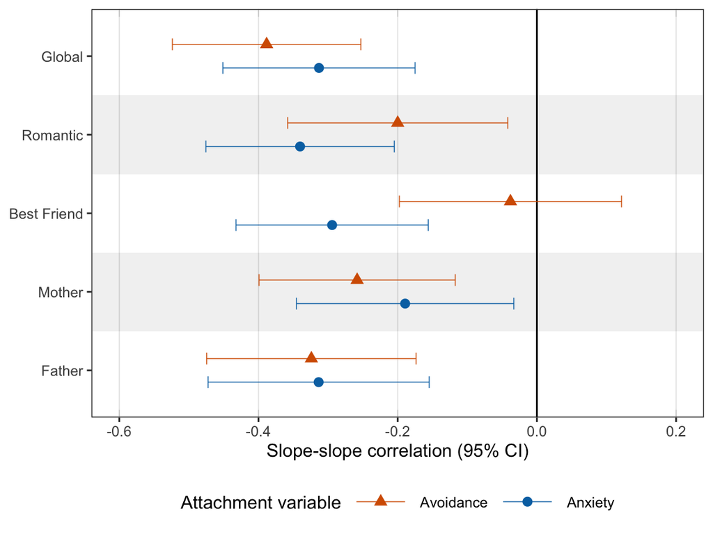

```r
plot_rq3_css
```

This only shows results in the single people’s group. For a (descriptive) group comparison plot, see below in the exploratory analyses.

### 4.3.7 Full model results

#### 4.3.7.1 Avoidance: Global

Full model results for avoidance (global) (in the consistently single people):

```r
broom::tidy(get(paste0("fit_rq3_", outcomes$short[1])), conf.int = TRUE, conf.level = 0.95) %>%
  filter(label != "") %>%
  arrange(label) %>%
  select(term = label, est = estimate, ci_lo = conf.low, ci_hi = conf.high, p_value = p.value, est_std = std.all) %>%
  knitr::kable(digits = 3)
```

| term | est | ci_lo | ci_hi | p_value | est_std |
| --- | --- | --- | --- | --- | --- |
| a0 | 2.945 | 2.886 | 3.003 | 0.000 | 4.157 |
| a1 | -0.343 | -0.427 | -0.259 | 0.000 | -0.463 |
| bia | -0.045 | -0.097 | 0.008 | 0.094 | -0.070 |
| biw | -0.018 | -0.080 | 0.043 | 0.563 | -0.024 |
| bsa | 0.028 | -0.046 | 0.102 | 0.452 | 0.042 |
| bsw | -0.012 | -0.094 | 0.070 | 0.769 | -0.016 |
| cii | -0.193 | -0.246 | -0.140 | 0.000 | -0.327 |
| cis_aw | -0.004 | -0.073 | 0.064 | 0.899 | -0.008 |
| cis_wa | -0.074 | -0.147 | -0.002 | 0.044 | -0.120 |
| cisa | -0.057 | -0.121 | 0.007 | 0.080 | -0.109 |
| cisw | -0.047 | -0.130 | 0.035 | 0.258 | -0.068 |
| css | -0.241 | -0.343 | -0.140 | 0.000 | -0.388 |
| ra00 | 0.199 | 0.172 | 0.226 | 0.000 | 0.284 |
| ra01 | 0.142 | 0.115 | 0.169 | 0.000 | 0.222 |
| ra02 | 0.116 | 0.095 | 0.137 | 0.000 | 0.190 |
| ra03 | 0.134 | 0.111 | 0.158 | 0.000 | 0.213 |
| ra04 | 0.153 | 0.126 | 0.181 | 0.000 | 0.236 |
| ra05 | 0.153 | 0.126 | 0.180 | 0.000 | 0.235 |
| ra06 | 0.151 | 0.124 | 0.178 | 0.000 | 0.232 |
| ra07 | 0.145 | 0.119 | 0.170 | 0.000 | 0.223 |
| ra08 | 0.120 | 0.098 | 0.143 | 0.000 | 0.190 |
| ra09 | 0.112 | 0.091 | 0.133 | 0.000 | 0.178 |
| ra10 | 0.140 | 0.115 | 0.165 | 0.000 | 0.210 |
| ra11 | 0.117 | 0.094 | 0.139 | 0.000 | 0.179 |
| ra12 | 0.106 | 0.085 | 0.128 | 0.000 | 0.163 |
| ra13 | 0.126 | 0.100 | 0.152 | 0.000 | 0.184 |
| ra14 | 0.106 | 0.083 | 0.130 | 0.000 | 0.157 |
| ra15 | 0.100 | 0.075 | 0.124 | 0.000 | 0.145 |
| ra16 | 0.100 | 0.075 | 0.125 | 0.000 | 0.142 |
| ra17 | 0.124 | 0.087 | 0.161 | 0.000 | 0.166 |

[output cut: 78 more lines]

#### 4.3.7.2 Avoidance: Romantic

Full model results for avoidance (romantic) (in the consistently single people):

```r
broom::tidy(get(paste0("fit_rq3_", outcomes$short[2])), conf.int = TRUE, conf.level = 0.95) %>%
  filter(label != "") %>%
  arrange(label) %>%
  select(term = label, est = estimate, ci_lo = conf.low, ci_hi = conf.high, p_value = p.value, est_std = std.all) %>%
  knitr::kable(digits = 3)
```

| term | est | ci_lo | ci_hi | p_value | est_std |
| --- | --- | --- | --- | --- | --- |
| a0 | 2.308 | 2.251 | 2.364 | 0.000 | 3.453 |
| a1 | -0.219 | -0.311 | -0.127 | 0.000 | -0.282 |
| bia | 0.066 | 0.015 | 0.117 | 0.011 | 0.110 |
| biw | -0.018 | -0.080 | 0.043 | 0.558 | -0.024 |
| bsa | -0.081 | -0.162 | -0.001 | 0.047 | -0.116 |
| bsw | -0.011 | -0.093 | 0.071 | 0.794 | -0.014 |
| cii | -0.130 | -0.180 | -0.080 | 0.000 | -0.234 |
| cis_aw | -0.063 | -0.129 | 0.004 | 0.065 | -0.112 |
| cis_wa | -0.016 | -0.095 | 0.063 | 0.683 | -0.026 |
| cisa | -0.051 | -0.119 | 0.017 | 0.141 | -0.099 |
| cisw | -0.048 | -0.130 | 0.034 | 0.253 | -0.068 |
| css | -0.130 | -0.239 | -0.021 | 0.019 | -0.200 |
| ra00 | 0.345 | 0.301 | 0.389 | 0.000 | 0.436 |
| ra01 | 0.216 | 0.176 | 0.256 | 0.000 | 0.327 |
| ra02 | 0.192 | 0.159 | 0.225 | 0.000 | 0.303 |
| ra03 | 0.163 | 0.134 | 0.192 | 0.000 | 0.270 |
| ra04 | 0.171 | 0.139 | 0.202 | 0.000 | 0.278 |
| ra05 | 0.196 | 0.161 | 0.230 | 0.000 | 0.306 |
| ra06 | 0.174 | 0.142 | 0.206 | 0.000 | 0.280 |
| ra07 | 0.193 | 0.158 | 0.227 | 0.000 | 0.298 |
| ra08 | 0.158 | 0.129 | 0.187 | 0.000 | 0.255 |
| ra09 | 0.158 | 0.129 | 0.188 | 0.000 | 0.252 |
| ra10 | 0.133 | 0.108 | 0.158 | 0.000 | 0.217 |
| ra11 | 0.166 | 0.135 | 0.197 | 0.000 | 0.254 |
| ra12 | 0.154 | 0.124 | 0.184 | 0.000 | 0.235 |
| ra13 | 0.139 | 0.110 | 0.167 | 0.000 | 0.212 |
| ra14 | 0.130 | 0.101 | 0.158 | 0.000 | 0.196 |
| ra15 | 0.119 | 0.091 | 0.147 | 0.000 | 0.178 |
| ra16 | 0.124 | 0.092 | 0.156 | 0.000 | 0.180 |
| ra17 | 0.136 | 0.097 | 0.176 | 0.000 | 0.189 |

[output cut: 78 more lines]

#### 4.3.7.3 Avoidance: Best Friend

Full model results for avoidance (best friend) (in the consistently single people):

```r
broom::tidy(get(paste0("fit_rq3_", outcomes$short[3])), conf.int = TRUE, conf.level = 0.95) %>%
  filter(label != "") %>%
  arrange(label) %>%
  select(term = label, est = estimate, ci_lo = conf.low, ci_hi = conf.high, p_value = p.value, est_std = std.all) %>%
  knitr::kable(digits = 3)
```

| term | est | ci_lo | ci_hi | p_value | est_std |
| --- | --- | --- | --- | --- | --- |
| a0 | 2.228 | 2.168 | 2.288 | 0.000 | 3.119 |
| a1 | 0.301 | 0.188 | 0.414 | 0.000 | 0.290 |
| bia | -0.037 | -0.091 | 0.017 | 0.183 | -0.057 |
| biw | -0.019 | -0.080 | 0.043 | 0.552 | -0.025 |
| bsa | -0.073 | -0.172 | 0.026 | 0.150 | -0.078 |
| bsw | -0.009 | -0.091 | 0.074 | 0.838 | -0.011 |
| cii | -0.204 | -0.258 | -0.149 | 0.000 | -0.342 |
| cis_aw | -0.053 | -0.122 | 0.017 | 0.139 | -0.088 |
| cis_wa | -0.005 | -0.103 | 0.092 | 0.912 | -0.006 |
| cisa | -0.099 | -0.186 | -0.011 | 0.028 | -0.134 |
| cisw | -0.047 | -0.129 | 0.035 | 0.261 | -0.067 |
| css | -0.033 | -0.172 | 0.106 | 0.642 | -0.038 |
| ra00 | 0.290 | 0.250 | 0.329 | 0.000 | 0.362 |
| ra01 | 0.196 | 0.158 | 0.234 | 0.000 | 0.280 |
| ra02 | 0.156 | 0.127 | 0.184 | 0.000 | 0.237 |
| ra03 | 0.181 | 0.149 | 0.213 | 0.000 | 0.265 |
| ra04 | 0.230 | 0.187 | 0.272 | 0.000 | 0.313 |
| ra05 | 0.194 | 0.160 | 0.229 | 0.000 | 0.276 |
| ra06 | 0.188 | 0.153 | 0.222 | 0.000 | 0.266 |
| ra07 | 0.208 | 0.171 | 0.245 | 0.000 | 0.283 |
| ra08 | 0.210 | 0.172 | 0.249 | 0.000 | 0.280 |
| ra09 | 0.175 | 0.141 | 0.209 | 0.000 | 0.240 |
| ra10 | 0.148 | 0.120 | 0.176 | 0.000 | 0.206 |
| ra11 | 0.185 | 0.149 | 0.221 | 0.000 | 0.238 |
| ra12 | 0.191 | 0.153 | 0.228 | 0.000 | 0.236 |
| ra13 | 0.123 | 0.096 | 0.149 | 0.000 | 0.160 |
| ra14 | 0.207 | 0.162 | 0.252 | 0.000 | 0.236 |
| ra15 | 0.259 | 0.201 | 0.317 | 0.000 | 0.270 |
| ra16 | 0.210 | 0.159 | 0.261 | 0.000 | 0.222 |
| ra17 | 0.214 | 0.155 | 0.273 | 0.000 | 0.218 |

[output cut: 78 more lines]

#### 4.3.7.4 Avoidance: Mother

Full model results for avoidance (mother) (in the consistently single people):

```r
broom::tidy(get(paste0("fit_rq3_", outcomes$short[4])), conf.int = TRUE, conf.level = 0.95) %>%
  filter(label != "") %>%
  arrange(label) %>%
  select(term = label, est = estimate, ci_lo = conf.low, ci_hi = conf.high, p_value = p.value, est_std = std.all) %>%
  knitr::kable(digits = 3)
```

| term | est | ci_lo | ci_hi | p_value | est_std |
| --- | --- | --- | --- | --- | --- |
| a0 | 3.165 | 3.067 | 3.263 | 0.000 | 2.886 |
| a1 | -0.458 | -0.586 | -0.330 | 0.000 | -0.403 |
| bia | 0.187 | 0.083 | 0.290 | 0.000 | 0.154 |
| biw | -0.062 | -0.143 | 0.019 | 0.135 | -0.066 |
| bsa | -0.141 | -0.276 | -0.005 | 0.042 | -0.112 |
| bsw | 0.041 | -0.073 | 0.155 | 0.482 | 0.041 |
| cii | -0.286 | -0.371 | -0.201 | 0.000 | -0.316 |
| cis_aw | 0.035 | -0.079 | 0.150 | 0.546 | 0.037 |
| cis_wa | -0.008 | -0.115 | 0.100 | 0.890 | -0.008 |
| cisa | -0.325 | -0.467 | -0.183 | 0.000 | -0.266 |
| cisw | -0.070 | -0.163 | 0.023 | 0.142 | -0.094 |
| css | -0.260 | -0.414 | -0.106 | 0.001 | -0.258 |
| ra00 | 0.274 | 0.234 | 0.314 | 0.000 | 0.185 |
| ra01 | 0.179 | 0.140 | 0.217 | 0.000 | 0.132 |
| ra02 | 0.184 | 0.150 | 0.218 | 0.000 | 0.137 |
| ra03 | 0.179 | 0.145 | 0.214 | 0.000 | 0.136 |
| ra04 | 0.154 | 0.124 | 0.184 | 0.000 | 0.120 |
| ra05 | 0.174 | 0.141 | 0.207 | 0.000 | 0.134 |
| ra06 | 0.148 | 0.120 | 0.177 | 0.000 | 0.117 |
| ra07 | 0.123 | 0.099 | 0.147 | 0.000 | 0.100 |
| ra08 | 0.140 | 0.113 | 0.168 | 0.000 | 0.112 |
| ra09 | 0.121 | 0.097 | 0.146 | 0.000 | 0.098 |
| ra10 | 0.121 | 0.097 | 0.144 | 0.000 | 0.098 |
| ra11 | 0.156 | 0.125 | 0.187 | 0.000 | 0.122 |
| ra12 | 0.122 | 0.097 | 0.148 | 0.000 | 0.097 |
| ra13 | 0.093 | 0.071 | 0.115 | 0.000 | 0.075 |
| ra14 | 0.086 | 0.065 | 0.107 | 0.000 | 0.068 |
| ra15 | 0.102 | 0.074 | 0.129 | 0.000 | 0.079 |
| ra16 | 0.122 | 0.088 | 0.155 | 0.000 | 0.091 |
| ra17 | 0.086 | 0.058 | 0.114 | 0.000 | 0.065 |

[output cut: 78 more lines]

#### 4.3.7.5 Avoidance: Father

Full model results for avoidance (father) (in the consistently single people):

```r
broom::tidy(get(paste0("fit_rq3_", outcomes$short[5])), conf.int = TRUE, conf.level = 0.95) %>%
  filter(label != "") %>%
  arrange(label) %>%
  select(term = label, est = estimate, ci_lo = conf.low, ci_hi = conf.high, p_value = p.value, est_std = std.all) %>%
  knitr::kable(digits = 3)
```

| term | est | ci_lo | ci_hi | p_value | est_std |
| --- | --- | --- | --- | --- | --- |
| a0 | 3.422 | 3.322 | 3.522 | 0.000 | 3.413 |
| a1 | -0.304 | -0.427 | -0.180 | 0.000 | -0.321 |
| bia | 0.034 | -0.074 | 0.143 | 0.532 | 0.029 |
| biw | -0.014 | -0.105 | 0.077 | 0.766 | -0.014 |
| bsa | -0.004 | -0.138 | 0.131 | 0.956 | -0.003 |
| bsw | 0.096 | -0.034 | 0.226 | 0.147 | 0.093 |
| cii | -0.232 | -0.314 | -0.149 | 0.000 | -0.277 |
| cis_aw | 0.078 | -0.034 | 0.190 | 0.170 | 0.089 |
| cis_wa | -0.009 | -0.107 | 0.088 | 0.849 | -0.012 |
| cisa | -0.139 | -0.257 | -0.021 | 0.021 | -0.146 |
| cisw | -0.057 | -0.154 | 0.040 | 0.251 | -0.078 |
| css | -0.268 | -0.411 | -0.125 | 0.000 | -0.324 |
| ra00 | 0.225 | 0.190 | 0.260 | 0.000 | 0.183 |
| ra01 | 0.127 | 0.098 | 0.156 | 0.000 | 0.113 |
| ra02 | 0.109 | 0.086 | 0.132 | 0.000 | 0.099 |
| ra03 | 0.157 | 0.126 | 0.188 | 0.000 | 0.137 |
| ra04 | 0.150 | 0.119 | 0.182 | 0.000 | 0.133 |
| ra05 | 0.123 | 0.098 | 0.149 | 0.000 | 0.111 |
| ra06 | 0.132 | 0.105 | 0.160 | 0.000 | 0.118 |
| ra07 | 0.173 | 0.139 | 0.208 | 0.000 | 0.149 |
| ra08 | 0.129 | 0.101 | 0.156 | 0.000 | 0.114 |
| ra09 | 0.121 | 0.095 | 0.148 | 0.000 | 0.108 |
| ra10 | 0.112 | 0.088 | 0.136 | 0.000 | 0.099 |
| ra11 | 0.122 | 0.095 | 0.150 | 0.000 | 0.106 |
| ra12 | 0.077 | 0.059 | 0.096 | 0.000 | 0.069 |
| ra13 | 0.082 | 0.062 | 0.103 | 0.000 | 0.072 |
| ra14 | 0.113 | 0.083 | 0.143 | 0.000 | 0.095 |
| ra15 | 0.096 | 0.068 | 0.124 | 0.000 | 0.080 |
| ra16 | 0.129 | 0.092 | 0.167 | 0.000 | 0.103 |
| ra17 | 0.072 | 0.046 | 0.098 | 0.000 | 0.059 |

[output cut: 78 more lines]

#### 4.3.7.6 Anxiety: Global

Full model results for anxiety (global) (in the consistently single people):

```r
broom::tidy(get(paste0("fit_rq3_", outcomes$short[6])), conf.int = TRUE, conf.level = 0.95) %>%
  filter(label != "") %>%
  arrange(label) %>%
  select(term = label, est = estimate, ci_lo = conf.low, ci_hi = conf.high, p_value = p.value, est_std = std.all) %>%
  knitr::kable(digits = 3)
```

| term | est | ci_lo | ci_hi | p_value | est_std |
| --- | --- | --- | --- | --- | --- |
| a0 | 3.413 | 3.336 | 3.490 | 0.000 | 3.733 |
| a1 | -0.901 | -1.027 | -0.775 | 0.000 | -0.806 |
| bia | -0.004 | -0.072 | 0.065 | 0.919 | -0.004 |
| biw | -0.018 | -0.080 | 0.044 | 0.569 | -0.024 |
| bsa | -0.063 | -0.173 | 0.047 | 0.265 | -0.062 |
| bsw | -0.012 | -0.094 | 0.071 | 0.782 | -0.015 |
| cii | -0.324 | -0.395 | -0.252 | 0.000 | -0.423 |
| cis_aw | 0.100 | 0.009 | 0.191 | 0.031 | 0.130 |
| cis_wa | 0.013 | -0.095 | 0.121 | 0.812 | 0.014 |
| cisa | -0.141 | -0.265 | -0.016 | 0.027 | -0.138 |
| cisw | -0.051 | -0.133 | 0.032 | 0.227 | -0.072 |
| css | -0.294 | -0.441 | -0.147 | 0.000 | -0.313 |
| ra00 | 0.371 | 0.320 | 0.423 | 0.000 | 0.308 |
| ra01 | 0.288 | 0.233 | 0.343 | 0.000 | 0.258 |
| ra02 | 0.256 | 0.211 | 0.301 | 0.000 | 0.237 |
| ra03 | 0.286 | 0.236 | 0.336 | 0.000 | 0.258 |
| ra04 | 0.337 | 0.277 | 0.397 | 0.000 | 0.291 |
| ra05 | 0.325 | 0.268 | 0.382 | 0.000 | 0.283 |
| ra06 | 0.317 | 0.260 | 0.374 | 0.000 | 0.276 |
| ra07 | 0.263 | 0.216 | 0.310 | 0.000 | 0.238 |
| ra08 | 0.255 | 0.208 | 0.302 | 0.000 | 0.230 |
| ra09 | 0.256 | 0.208 | 0.304 | 0.000 | 0.227 |
| ra10 | 0.272 | 0.223 | 0.322 | 0.000 | 0.235 |
| ra11 | 0.225 | 0.181 | 0.268 | 0.000 | 0.198 |
| ra12 | 0.253 | 0.204 | 0.303 | 0.000 | 0.213 |
| ra13 | 0.272 | 0.217 | 0.327 | 0.000 | 0.221 |
| ra14 | 0.261 | 0.205 | 0.316 | 0.000 | 0.208 |
| ra15 | 0.238 | 0.180 | 0.296 | 0.000 | 0.189 |
| ra16 | 0.287 | 0.216 | 0.358 | 0.000 | 0.213 |
| ra17 | 0.225 | 0.160 | 0.291 | 0.000 | 0.170 |

[output cut: 78 more lines]

#### 4.3.7.7 Anxiety: Romantic

Full model results for anxiety (romantic) (in the consistently single people):

```r
broom::tidy(get(paste0("fit_rq3_", outcomes$short[7])), conf.int = TRUE, conf.level = 0.95) %>%
  filter(label != "") %>%
  arrange(label) %>%
  select(term = label, est = estimate, ci_lo = conf.low, ci_hi = conf.high, p_value = p.value, est_std = std.all) %>%
  knitr::kable(digits = 3)
```

| term | est | ci_lo | ci_hi | p_value | est_std |
| --- | --- | --- | --- | --- | --- |
| a0 | 3.285 | 3.203 | 3.366 | 0.000 | 3.390 |
| a1 | -0.783 | -0.922 | -0.645 | 0.000 | -0.617 |
| bia | 0.006 | -0.067 | 0.079 | 0.871 | 0.007 |
| biw | -0.019 | -0.080 | 0.043 | 0.555 | -0.025 |
| bsa | -0.119 | -0.241 | 0.003 | 0.055 | -0.104 |
| bsw | -0.008 | -0.090 | 0.074 | 0.853 | -0.010 |
| cii | -0.288 | -0.363 | -0.214 | 0.000 | -0.356 |
| cis_aw | 0.085 | -0.010 | 0.179 | 0.079 | 0.104 |
| cis_wa | -0.015 | -0.135 | 0.104 | 0.802 | -0.014 |
| cisa | -0.189 | -0.332 | -0.045 | 0.010 | -0.154 |
| cisw | -0.050 | -0.133 | 0.032 | 0.231 | -0.072 |
| css | -0.362 | -0.525 | -0.200 | 0.000 | -0.340 |
| ra00 | 0.562 | 0.488 | 0.636 | 0.000 | 0.375 |
| ra01 | 0.254 | 0.202 | 0.306 | 0.000 | 0.215 |
| ra02 | 0.372 | 0.310 | 0.434 | 0.000 | 0.288 |
| ra03 | 0.296 | 0.243 | 0.349 | 0.000 | 0.244 |
| ra04 | 0.390 | 0.321 | 0.460 | 0.000 | 0.299 |
| ra05 | 0.360 | 0.297 | 0.423 | 0.000 | 0.281 |
| ra06 | 0.291 | 0.237 | 0.345 | 0.000 | 0.239 |
| ra07 | 0.388 | 0.320 | 0.456 | 0.000 | 0.292 |
| ra08 | 0.284 | 0.232 | 0.336 | 0.000 | 0.229 |
| ra09 | 0.296 | 0.241 | 0.351 | 0.000 | 0.233 |
| ra10 | 0.242 | 0.197 | 0.287 | 0.000 | 0.195 |
| ra11 | 0.219 | 0.176 | 0.262 | 0.000 | 0.176 |
| ra12 | 0.239 | 0.191 | 0.287 | 0.000 | 0.184 |
| ra13 | 0.274 | 0.219 | 0.329 | 0.000 | 0.201 |
| ra14 | 0.249 | 0.194 | 0.304 | 0.000 | 0.180 |
| ra15 | 0.240 | 0.183 | 0.297 | 0.000 | 0.170 |
| ra16 | 0.280 | 0.212 | 0.347 | 0.000 | 0.186 |
| ra17 | 0.279 | 0.200 | 0.358 | 0.000 | 0.180 |

[output cut: 78 more lines]

#### 4.3.7.8 Anxiety: Best Friend

Full model results for anxiety (best friend) (in the consistently single people):

```r
broom::tidy(get(paste0("fit_rq3_", outcomes$short[8])), conf.int = TRUE, conf.level = 0.95) %>%
  filter(label != "") %>%
  arrange(label) %>%
  select(term = label, est = estimate, ci_lo = conf.low, ci_hi = conf.high, p_value = p.value, est_std = std.all) %>%
  knitr::kable(digits = 3)
```

| term | est | ci_lo | ci_hi | p_value | est_std |
| --- | --- | --- | --- | --- | --- |
| a0 | 2.326 | 2.245 | 2.406 | 0.000 | 2.399 |
| a1 | -0.218 | -0.351 | -0.084 | 0.001 | -0.174 |
| bia | 0.007 | -0.066 | 0.080 | 0.848 | 0.008 |
| biw | -0.018 | -0.080 | 0.043 | 0.563 | -0.024 |
| bsa | -0.082 | -0.201 | 0.036 | 0.174 | -0.073 |
| bsw | -0.011 | -0.093 | 0.071 | 0.790 | -0.015 |
| cii | -0.296 | -0.370 | -0.222 | 0.000 | -0.365 |
| cis_aw | 0.071 | -0.025 | 0.167 | 0.146 | 0.087 |
| cis_wa | 0.109 | -0.007 | 0.225 | 0.066 | 0.104 |
| cisa | -0.508 | -0.659 | -0.356 | 0.000 | -0.420 |
| cisw | -0.049 | -0.131 | 0.033 | 0.241 | -0.070 |
| css | -0.309 | -0.469 | -0.149 | 0.000 | -0.294 |
| ra00 | 0.483 | 0.419 | 0.548 | 0.000 | 0.340 |
| ra01 | 0.288 | 0.230 | 0.345 | 0.000 | 0.241 |
| ra02 | 0.283 | 0.233 | 0.334 | 0.000 | 0.244 |
| ra03 | 0.342 | 0.283 | 0.401 | 0.000 | 0.287 |
| ra04 | 0.292 | 0.237 | 0.346 | 0.000 | 0.260 |
| ra05 | 0.296 | 0.243 | 0.349 | 0.000 | 0.267 |
| ra06 | 0.256 | 0.208 | 0.303 | 0.000 | 0.243 |
| ra07 | 0.282 | 0.232 | 0.333 | 0.000 | 0.264 |
| ra08 | 0.296 | 0.242 | 0.350 | 0.000 | 0.276 |
| ra09 | 0.316 | 0.258 | 0.375 | 0.000 | 0.290 |
| ra10 | 0.297 | 0.243 | 0.350 | 0.000 | 0.277 |
| ra11 | 0.285 | 0.230 | 0.339 | 0.000 | 0.267 |
| ra12 | 0.195 | 0.154 | 0.236 | 0.000 | 0.199 |
| ra13 | 0.217 | 0.172 | 0.261 | 0.000 | 0.213 |
| ra14 | 0.201 | 0.156 | 0.246 | 0.000 | 0.198 |
| ra15 | 0.281 | 0.216 | 0.347 | 0.000 | 0.253 |
| ra16 | 0.248 | 0.186 | 0.310 | 0.000 | 0.225 |
| ra17 | 0.235 | 0.169 | 0.302 | 0.000 | 0.211 |

[output cut: 78 more lines]

#### 4.3.7.9 Anxiety: Mother

Full model results for anxiety (mother) (in the consistently single people):

```r
broom::tidy(get(paste0("fit_rq3_", outcomes$short[9])), conf.int = TRUE, conf.level = 0.95) %>%
  filter(label != "") %>%
  arrange(label) %>%
  select(term = label, est = estimate, ci_lo = conf.low, ci_hi = conf.high, p_value = p.value, est_std = std.all) %>%
  knitr::kable(digits = 3)
```

| term | est | ci_lo | ci_hi | p_value | est_std |
| --- | --- | --- | --- | --- | --- |
| a0 | 2.054 | 1.967 | 2.141 | 0.000 | 2.107 |
| a1 | -0.314 | -0.433 | -0.194 | 0.000 | -0.322 |
| bia | 0.244 | 0.151 | 0.336 | 0.000 | 0.225 |
| biw | -0.063 | -0.143 | 0.018 | 0.130 | -0.067 |
| bsa | -0.185 | -0.311 | -0.059 | 0.004 | -0.171 |
| bsw | 0.039 | -0.075 | 0.152 | 0.507 | 0.039 |
| cii | -0.269 | -0.345 | -0.193 | 0.000 | -0.340 |
| cis_aw | 0.084 | -0.020 | 0.188 | 0.112 | 0.100 |
| cis_wa | 0.105 | 0.004 | 0.205 | 0.042 | 0.131 |
| cisa | -0.377 | -0.503 | -0.251 | 0.000 | -0.413 |
| cisw | -0.065 | -0.158 | 0.027 | 0.166 | -0.088 |
| css | -0.161 | -0.300 | -0.023 | 0.023 | -0.189 |
| ra00 | 0.424 | 0.366 | 0.483 | 0.000 | 0.309 |
| ra01 | 0.253 | 0.202 | 0.304 | 0.000 | 0.215 |
| ra02 | 0.188 | 0.152 | 0.224 | 0.000 | 0.173 |
| ra03 | 0.210 | 0.170 | 0.250 | 0.000 | 0.194 |
| ra04 | 0.235 | 0.191 | 0.279 | 0.000 | 0.216 |
| ra05 | 0.164 | 0.132 | 0.197 | 0.000 | 0.164 |
| ra06 | 0.116 | 0.092 | 0.140 | 0.000 | 0.124 |
| ra07 | 0.167 | 0.135 | 0.200 | 0.000 | 0.172 |
| ra08 | 0.170 | 0.136 | 0.205 | 0.000 | 0.176 |
| ra09 | 0.156 | 0.124 | 0.187 | 0.000 | 0.165 |
| ra10 | 0.224 | 0.182 | 0.267 | 0.000 | 0.224 |
| ra11 | 0.225 | 0.180 | 0.270 | 0.000 | 0.225 |
| ra12 | 0.133 | 0.104 | 0.162 | 0.000 | 0.147 |
| ra13 | 0.190 | 0.149 | 0.231 | 0.000 | 0.198 |
| ra14 | 0.186 | 0.143 | 0.228 | 0.000 | 0.194 |
| ra15 | 0.156 | 0.115 | 0.196 | 0.000 | 0.167 |
| ra16 | 0.132 | 0.096 | 0.169 | 0.000 | 0.145 |
| ra17 | 0.187 | 0.130 | 0.243 | 0.000 | 0.191 |

[output cut: 78 more lines]

#### 4.3.7.10 Anxiety: Father

Full model results for anxiety (father) (in the consistently single people):

```r
broom::tidy(get(paste0("fit_rq3_", outcomes$short[10])), conf.int = TRUE, conf.level = 0.95) %>%
  filter(label != "") %>%
  arrange(label) %>%
  select(term = label, est = estimate, ci_lo = conf.low, ci_hi = conf.high, p_value = p.value, est_std = std.all) %>%
  knitr::kable(digits = 3)
```

| term | est | ci_lo | ci_hi | p_value | est_std |
| --- | --- | --- | --- | --- | --- |
| a0 | 2.180 | 2.084 | 2.277 | 0.000 | 2.296 |
| a1 | -0.335 | -0.471 | -0.199 | 0.000 | -0.339 |
| bia | 0.099 | -0.005 | 0.203 | 0.063 | 0.088 |
| biw | -0.013 | -0.104 | 0.078 | 0.784 | -0.013 |
| bsa | -0.275 | -0.423 | -0.126 | 0.000 | -0.235 |
| bsw | 0.089 | -0.041 | 0.218 | 0.179 | 0.086 |
| cii | -0.193 | -0.272 | -0.115 | 0.000 | -0.245 |
| cis_aw | 0.180 | 0.073 | 0.288 | 0.001 | 0.218 |
| cis_wa | -0.010 | -0.118 | 0.098 | 0.855 | -0.012 |
| cisa | -0.229 | -0.357 | -0.101 | 0.000 | -0.252 |
| cisw | -0.054 | -0.151 | 0.043 | 0.273 | -0.074 |
| css | -0.264 | -0.412 | -0.116 | 0.000 | -0.314 |
| ra00 | 0.373 | 0.317 | 0.430 | 0.000 | 0.293 |
| ra01 | 0.235 | 0.184 | 0.286 | 0.000 | 0.210 |
| ra02 | 0.246 | 0.198 | 0.295 | 0.000 | 0.220 |
| ra03 | 0.242 | 0.195 | 0.290 | 0.000 | 0.220 |
| ra04 | 0.233 | 0.184 | 0.282 | 0.000 | 0.215 |
| ra05 | 0.197 | 0.156 | 0.237 | 0.000 | 0.189 |
| ra06 | 0.153 | 0.119 | 0.186 | 0.000 | 0.154 |
| ra07 | 0.235 | 0.187 | 0.282 | 0.000 | 0.219 |
| ra08 | 0.199 | 0.157 | 0.241 | 0.000 | 0.192 |
| ra09 | 0.188 | 0.146 | 0.230 | 0.000 | 0.183 |
| ra10 | 0.218 | 0.173 | 0.264 | 0.000 | 0.205 |
| ra11 | 0.217 | 0.170 | 0.265 | 0.000 | 0.203 |
| ra12 | 0.122 | 0.093 | 0.151 | 0.000 | 0.124 |
| ra13 | 0.234 | 0.179 | 0.288 | 0.000 | 0.211 |
| ra14 | 0.234 | 0.175 | 0.292 | 0.000 | 0.208 |
| ra15 | 0.166 | 0.119 | 0.212 | 0.000 | 0.155 |
| ra16 | 0.141 | 0.100 | 0.182 | 0.000 | 0.133 |
| ra17 | 0.130 | 0.084 | 0.175 | 0.000 | 0.121 |

[output cut: 78 more lines]

# 5 Exploratory analyses

## 5.1 RQ2: Changes in Attachment Models (intermittently partnered)

From prereg: “For all attachment models, we will also explore whether consistently single people experience differential changes in attachment compared to intermittently partnered individuals.”

We don’t need to adjust the template. Same as above, we just use different groups.

### 5.1.1 Template loop & extraction

Run loop over all 5 X 2 outcomes

```r
# make factor ordering explicit again:
df_atta_wide_single_partn_i <- df_atta_wide_single_partn_i %>%
  mutate(group_fct = factor(group_fct, levels = c("Consistently single people",
                                                  "Intermittently partnered people"),
                            labels = c("Consistently single", "Intermittently partnered"), ordered = TRUE))

levels(df_atta_wide_single_partn_i$group_fct)

if (params$run_models) { # we can toggle this on/off in the YAML heading

# loop across all attachment outcomes
for (i in 1:length(outcomes$short)) {
#for (i in 1:2) {
  print(paste0("Running outcome: ", outcomes$maj[i]))

  # Outcome-specific missingness indicator -> added this mostly for parent-specific attachment
  missi_var <- paste0(outcomes$short[i], "_missi")

  # Step 1: fill single-group model template for intermittently partnered people
  print("-> Step 1")
  model_rq2 <- stringr::str_replace_all(rq2_template, "outcome", outcomes$short[i])
  fit_rq2_partn_i <- lavaan::growth(model_rq2,
                                     data = df_atta_wide_partn_i %>% filter(.data[[missi_var]] == 0),
                                     missing = "fiml",
                                    em.h1.args = list(max_iter = 5000), # to increase chance that H1 EM algorithm converges properly
                                    verbose = FALSE)
  eval(call("<-", as.name(paste0("fit_rq2_", outcomes$short[i], "_partn_i")), fit_rq2_partn_i))
  saveRDS(fit_rq2_partn_i, file = paste0("models/fit_rq2_", outcomes$short[i], "_partn_i.rds"))

  # Step 2: fill free multigroup model template
  print("-> Step 2")
  model_rq2_multi <- stringr::str_replace_all(rq2_template_multi, "outcome", outcomes$short[i])
  fit_rq2_multi_si <- lavaan::growth(model_rq2_multi,
                                     data = df_atta_wide_single_partn_i %>% filter(.data[[missi_var]] == 0) %>%
                                       arrange(group_fct),
                                     group = "group_fct",
                                     missing = "fiml",
                                     em.h1.args = list(max_iter = 5000), # to increase chance that H1 EM algorithm converges properly
                                     verbose = FALSE)
  eval(call("<-", as.name(paste0("fit_rq2_mg_", outcomes$short[i], "_si")), fit_rq2_multi_si))
  saveRDS(fit_rq2_multi_si, file = paste0("models/fit_rq2_mg_", outcomes$short[i], "_si.rds"))

  # Step 3: fill constrained multigroup model template
  print("-> Step 3")
  model_rq2_multi_constr <- stringr::str_replace_all(rq2_template_multi_constr, "outcome", outcomes$short[i])
  fit_rq2_multi_si_constr <- lavaan::growth(model_rq2_multi_constr,
                                            data = df_atta_wide_single_partn_i %>% filter(.data[[missi_var]] == 0) %>%
                                              arrange(group_fct),
                                            group = "group_fct",
                                            missing = "fiml",
                                            em.h1.args = list(max_iter = 5000), # to increase chance that H1 EM algorithm converges properly
                                            verbose = FALSE)
  eval(call("<-", as.name(paste0("fit_rq2_mg_", outcomes$short[i], "_si_constr")), fit_rq2_multi_si_constr))
  saveRDS(fit_rq2_multi_si_constr, file = paste0("models/fit_rq2_mg_", outcomes$short[i], "_si_constr.rds"))

  # Step 4: likelihood ratio test: free vs constrained slopes
  print("-> Step 4")
  lrt_si <- anova(fit_rq2_multi_si, fit_rq2_multi_si_constr)
  eval(call("<-", as.name(paste0("lrt_rq2_mg_", outcomes$short[i], "_si")), lrt_si))
  saveRDS(lrt_si, file = paste0("models/lrt_rq2_mg_", outcomes$short[i], "_si.rds"))
}
}
```

Create summary table of all effects of interest:

First, parameter extraction

```r
# Load saved models when run_models = FALSE
if (!params$run_models) {
  for (x in outcomes$short) {
    assign(paste0("fit_rq2_", x, "_partn_i"), readRDS(paste0("models/fit_rq2_", x, "_partn_i.rds")))
    assign(paste0("fit_rq2_mg_", x, "_si"), readRDS(paste0("models/fit_rq2_mg_", x, "_si.rds")))
    assign(paste0("fit_rq2_mg_", x, "_si_constr"), readRDS(paste0("models/fit_rq2_mg_", x, "_si_constr.rds")))
    assign(paste0("lrt_rq2_mg_", x, "_si"), readRDS(paste0("models/lrt_rq2_mg_", x, "_si.rds")))
  }
}

### single-group lavaan models:
# custom function for parameter extraction
extract_lav_rq2_partn_i <- function(fit_obj) {
  name_obj <- as.character(substitute(fit_obj))
  name_outc <- name_obj %>%
    str_remove("fit_rq2_") %>%
    str_remove("_partn_i$")
  group_lab <- ifelse(str_detect(name_obj, "partn_i$"),
                      "Intermittently partnered",
                      "Consistently single")
  # use tidy() for extraction
  broom::tidy(fit_obj, conf.int = TRUE, conf.level = 0.95) %>%
    filter(label %in% c("a0", "a1", "cis", "bi", "bs", "vi", "vs")) %>%
    mutate(outc = name_outc,
           group_fct = factor(group_lab,
                            levels = c("Consistently single", "Consistently partnered",
                                       "Intermittently partnered"),
                            labels = c("Consistently single", "Consistently partnered",
                                       "Intermittently partnered"), ordered = TRUE)) %>%
    select(outc, group_fct, term = label, est = estimate, ci_lo = conf.low, ci_hi = conf.high,
           z_value = statistic, p_value = p.value, est_std = std.all)
}

# bind all model outputs together
rq2_summary_partn_i <- bind_rows(
  extract_lav_rq2_partn_i(fit_rq2_avoi_glo_partn_i),
  extract_lav_rq2_partn_i(fit_rq2_avoi_rom_partn_i),
  extract_lav_rq2_partn_i(fit_rq2_avoi_fri_partn_i),
  extract_lav_rq2_partn_i(fit_rq2_avoi_mot_partn_i),
  extract_lav_rq2_partn_i(fit_rq2_avoi_fat_partn_i),
  extract_lav_rq2_partn_i(fit_rq2_anxi_glo_partn_i),
  extract_lav_rq2_partn_i(fit_rq2_anxi_rom_partn_i),
  extract_lav_rq2_partn_i(fit_rq2_anxi_fri_partn_i),
  extract_lav_rq2_partn_i(fit_rq2_anxi_mot_partn_i),
  extract_lav_rq2_partn_i(fit_rq2_anxi_fat_partn_i)
)

# Add labels
rq2_summary_partn_i <- rq2_summary_partn_i %>%
  mutate(outc_fct = factor(outc, levels = outcomes$short, labels = outcomes$maj, ordered = TRUE))#

### multi-group lavaan models
# custom function for parameter extraction
extract_lav_rq2_mg_partn_i <- function(fit_obj, lrt_obj) {
  name_obj <- as.character(substitute(fit_obj))
  name_outc <- str_remove(name_obj, "fit_rq2_mg_") %>%
    str_remove("_si")

  # extract LRT information
  lrt_tab <- as.data.frame(lrt_obj)
  lrt_chi <- lrt_tab$`Chisq diff`[2]
  lrt_df <- lrt_tab$`Df diff`[2]
  lrt_p <- lrt_tab$`Pr(>Chisq)`[2]

  # extract model parameters
  broom::tidy(fit_obj, conf.int = TRUE, conf.level = 0.95) %>%
    filter(label %in% c("a0_s", "a0_p", "a1_s", "a1_p", "cis_s", "cis_p",
                        "bi_s", "bi_p", "bs_s", "bs_p", "vi_s", "vi_p", "vs_s", "vs_p")) %>%
    mutate(outc = name_outc,
           group_fct = case_when(str_detect(label, "_s$") ~ "Consistently single",
                                 str_detect(label, "_p$") ~ "Intermittently partnered", # p = means Intermittently here!
                                 TRUE ~ NA_character_),
      group_fct = factor(group_fct, levels = c("Consistently single", "Consistently partnered",
                                    "Intermittently partnered"), ordered = TRUE),
      lrt_chi = ifelse(str_detect(label, "^a1_"), lrt_chi, NA),
      lrt_df = ifelse(str_detect(label, "^a1_"), lrt_df, NA),
      lrt_p = ifelse(str_detect(label, "^a1_"), lrt_p, NA)) %>%
    select(outc, group_fct, term = label,
           est = estimate, ci_lo = conf.low, ci_hi = conf.high,
           z_value = statistic, p_value = p.value, est_std = std.all,
           lrt_chi, lrt_df, lrt_p)
}

# bind all model outputs together
rq2_summary_mg_partn_i <- bind_rows(
  extract_lav_rq2_mg_partn_i(fit_rq2_mg_avoi_glo_si, lrt_rq2_mg_avoi_glo_si),
  extract_lav_rq2_mg_partn_i(fit_rq2_mg_avoi_rom_si, lrt_rq2_mg_avoi_rom_si),
  extract_lav_rq2_mg_partn_i(fit_rq2_mg_avoi_fri_si, lrt_rq2_mg_avoi_fri_si),
  extract_lav_rq2_mg_partn_i(fit_rq2_mg_avoi_mot_si, lrt_rq2_mg_avoi_mot_si),
  extract_lav_rq2_mg_partn_i(fit_rq2_mg_avoi_fat_si, lrt_rq2_mg_avoi_fat_si),
  extract_lav_rq2_mg_partn_i(fit_rq2_mg_anxi_glo_si, lrt_rq2_mg_anxi_glo_si),
  extract_lav_rq2_mg_partn_i(fit_rq2_mg_anxi_rom_si, lrt_rq2_mg_anxi_rom_si),
  extract_lav_rq2_mg_partn_i(fit_rq2_mg_anxi_fri_si, lrt_rq2_mg_anxi_fri_si),
  extract_lav_rq2_mg_partn_i(fit_rq2_mg_anxi_mot_si, lrt_rq2_mg_anxi_mot_si),
  extract_lav_rq2_mg_partn_i(fit_rq2_mg_anxi_fat_si, lrt_rq2_mg_anxi_fat_si)
)

# Add labels
rq2_summary_mg_partn_i <- rq2_summary_mg_partn_i %>%
  mutate(outc_fct = factor(outc, levels = outcomes$short, labels = outcomes$maj, ordered = TRUE))
```

### 5.1.2 Model fit

Fit statistics: single-group models  
-> These fit indices are very computationally expensive. I put them in a conditional chunk and load them as an RDS object in the next chunk.

```r
if (params$run_expensive) { # only run when we allow this in YAML heading

# model fit statistics: single-group models
rq2_fit_partn_i <- outcomes$short %>%
  purrr::map_dfr(function(x) {
    bind_rows(
      broom::glance(get(paste0("fit_rq2_", x, "_partn_i"))) %>%
        mutate(outc = x, group_fct = "Intermittently partnered"))
  }) %>%
  select(outc, group_fct, nobs, npar, AIC, BIC, cfi, rmsea, srmr) %>%
  mutate(
    outc_fct = factor(outc, levels = outcomes$short, labels = outcomes$maj, ordered = TRUE),
    group_fct = factor(group_fct,
                       levels = c("Intermittently partnered"),
                       ordered = TRUE))

# save externally:
saveRDS(rq2_fit_partn_i, "model_fit/rq2_fit_partn_i.rds")
}
```

Show fit indices table:

```r
rq2_fit_partn_i <- readRDS("model_fit/rq2_fit_partn_i.rds")

rq2_fit_partn_i %>% select(-outc) %>%
  select(outc_fct, group_fct, everything()) %>%
  kable(digits = 3)
```

| outc_fct | group_fct | nobs | npar | AIC | BIC | cfi | rmsea | srmr |
| --- | --- | --- | --- | --- | --- | --- | --- | --- |
| Avoidance: Global | Intermittently partnered | 1329 | 37 | 20420.94 | 20613.05 | 0.941 | 0.041 | 0.095 |
| Avoidance: Romantic | Intermittently partnered | 1329 | 37 | 32058.43 | 32250.54 | 0.848 | 0.045 | 0.138 |
| Avoidance: Best Friend | Intermittently partnered | 1329 | 37 | 26522.91 | 26715.02 | 0.863 | 0.054 | 0.190 |
| Avoidance: Mother | Intermittently partnered | 1223 | 37 | 21261.45 | 21450.48 | 0.949 | 0.047 | 0.071 |
| Avoidance: Father | Intermittently partnered | 1148 | 37 | 18911.11 | 19097.81 | 0.938 | 0.052 | 0.098 |
| Anxiety: Global | Intermittently partnered | 1329 | 37 | 33481.33 | 33673.44 | 0.905 | 0.048 | 0.131 |
| Anxiety: Romantic | Intermittently partnered | 1329 | 37 | 40312.58 | 40504.69 | 0.869 | 0.048 | 0.189 |
| Anxiety: Best Friend | Intermittently partnered | 1329 | 37 | 31304.07 | 31496.18 | 0.903 | 0.044 | 0.125 |
| Anxiety: Mother | Intermittently partnered | 1223 | 37 | 21771.67 | 21960.71 | 0.934 | 0.046 | 0.078 |
| Anxiety: Father | Intermittently partnered | 1148 | 37 | 22125.18 | 22311.88 | 0.935 | 0.045 | 0.081 |

```r
if (params$run_expensive) { # only run when we allow this in YAML heading

# model fit statistics: multi-group models
rq2_fit_mg_partn_i <- outcomes$short %>%
  purrr::map_dfr(function(x) {
    broom::glance(get(paste0("fit_rq2_mg_", x, "_si"))) %>%
      mutate(outc = x)
  }) %>%
  select(outc, nobs, npar, AIC, BIC, cfi, rmsea, srmr) %>%
  mutate(outc_fct = factor(outc, levels = outcomes$short, labels = outcomes$maj, ordered = TRUE))

# save externally:
saveRDS(rq2_fit_mg_partn_i, "model_fit/rq2_fit_mg_partn_i.rds")
}
```

Show fit indices table:

```r
rq2_fit_mg_partn_i <- readRDS("model_fit/rq2_fit_mg_partn_i.rds")

rq2_fit_mg_partn_i %>%
  select(-outc) %>% select(outc_fct, everything()) %>%
  kable(digits = 3)
```

| outc_fct | nobs | npar | AIC | BIC | cfi | rmsea | srmr |
| --- | --- | --- | --- | --- | --- | --- | --- |
| Avoidance: Global | 1951 | 74 | 28294.76 | 28707.39 | 0.935 | 0.043 | 0.097 |
| Avoidance: Romantic | 1951 | 74 | 41216.58 | 41629.22 | 0.863 | 0.048 | 0.131 |
| Avoidance: Best Friend | 1951 | 74 | 36866.95 | 37279.58 | 0.848 | 0.058 | 0.212 |
| Avoidance: Mother | 1767 | 74 | 29275.07 | 29680.37 | 0.935 | 0.052 | 0.090 |
| Avoidance: Father | 1632 | 74 | 25052.00 | 25451.42 | 0.922 | 0.057 | 0.094 |
| Anxiety: Global | 1951 | 74 | 45885.51 | 46298.14 | 0.897 | 0.050 | 0.137 |
| Anxiety: Romantic | 1951 | 74 | 53289.82 | 53702.45 | 0.872 | 0.051 | 0.184 |
| Anxiety: Best Friend | 1951 | 74 | 43931.39 | 44344.02 | 0.897 | 0.046 | 0.133 |
| Anxiety: Mother | 1767 | 74 | 30741.95 | 31147.25 | 0.905 | 0.054 | 0.081 |
| Anxiety: Father | 1632 | 74 | 30362.77 | 30762.19 | 0.910 | 0.053 | 0.091 |

Similar to above or even a bit better. Some domains are still a bit worse than others (e.g., friend-specific avoidance).

### 5.1.3 Model diagnostics

- Did the model converge?
- Did lavaan’s internal check pass?
- Are there inadmissible negative variances?

#### 5.1.3.1 Single-group models

```r
# diagnostics for the single-group RQ2 models (interm. partnered)
rq2_models_partn_i <- c("fit_rq2_avoi_glo_partn_i", "fit_rq2_avoi_rom_partn_i",
                "fit_rq2_avoi_fri_partn_i", "fit_rq2_avoi_mot_partn_i",
                "fit_rq2_avoi_fat_partn_i", "fit_rq2_anxi_glo_partn_i",
                "fit_rq2_anxi_rom_partn_i", "fit_rq2_anxi_fri_partn_i",
                "fit_rq2_anxi_mot_partn_i", "fit_rq2_anxi_fat_partn_i")

rq2_diagnostics_partn_i <- purrr::map_dfr(rq2_models_partn_i, function(x) {
  fit <- get(x)
  tibble(
    model = x,
    converged = lavInspect(fit, "converged"),
    post_check = lavInspect(fit, "post.check"),
    neg_variances = any(parameterEstimates(fit)$op == "~~" &
                          parameterEstimates(fit)$lhs == parameterEstimates(fit)$rhs &
                          parameterEstimates(fit)$est < 0))
})

rq2_diagnostics_partn_i %>% kable(digits = 3)
```

| model | converged | post_check | neg_variances |
| --- | --- | --- | --- |
| fit_rq2_avoi_glo_partn_i | TRUE | TRUE | FALSE |
| fit_rq2_avoi_rom_partn_i | TRUE | TRUE | FALSE |
| fit_rq2_avoi_fri_partn_i | TRUE | TRUE | FALSE |
| fit_rq2_avoi_mot_partn_i | TRUE | TRUE | FALSE |
| fit_rq2_avoi_fat_partn_i | TRUE | TRUE | FALSE |
| fit_rq2_anxi_glo_partn_i | TRUE | TRUE | FALSE |
| fit_rq2_anxi_rom_partn_i | TRUE | TRUE | FALSE |
| fit_rq2_anxi_fri_partn_i | TRUE | TRUE | FALSE |
| fit_rq2_anxi_mot_partn_i | TRUE | TRUE | FALSE |
| fit_rq2_anxi_fat_partn_i | TRUE | TRUE | FALSE |

#### 5.1.3.2 Multi-group models

```r
rq2_mg_models_partn_i <- c("fit_rq2_mg_avoi_glo_si", "fit_rq2_mg_avoi_rom_si",
                   "fit_rq2_mg_avoi_fri_si", "fit_rq2_mg_avoi_mot_si",
                   "fit_rq2_mg_avoi_fat_si", "fit_rq2_mg_anxi_glo_si",
                   "fit_rq2_mg_anxi_rom_si", "fit_rq2_mg_anxi_fri_si",
                   "fit_rq2_mg_anxi_mot_si", "fit_rq2_mg_anxi_fat_si")

rq2_mg_diagnostics_partn_i <- purrr::map_dfr(rq2_mg_models_partn_i, function(x) {
  fit <- get(x)
  pe <- parameterEstimates(fit)
  tibble(
    model = x,
    converged = lavInspect(fit, "converged"),
    post_check = lavInspect(fit, "post.check"),
    neg_variances = any(pe$op == "~~" &
                          pe$lhs == pe$rhs &
                          pe$est < 0))
})

rq2_mg_diagnostics_partn_i %>% kable(digits = 3)
```

| model | converged | post_check | neg_variances |
| --- | --- | --- | --- |
| fit_rq2_mg_avoi_glo_si | TRUE | TRUE | FALSE |
| fit_rq2_mg_avoi_rom_si | TRUE | TRUE | FALSE |
| fit_rq2_mg_avoi_fri_si | TRUE | TRUE | FALSE |
| fit_rq2_mg_avoi_mot_si | TRUE | TRUE | FALSE |
| fit_rq2_mg_avoi_fat_si | TRUE | TRUE | FALSE |
| fit_rq2_mg_anxi_glo_si | TRUE | TRUE | FALSE |
| fit_rq2_mg_anxi_rom_si | TRUE | TRUE | FALSE |
| fit_rq2_mg_anxi_fri_si | TRUE | TRUE | FALSE |
| fit_rq2_mg_anxi_mot_si | TRUE | TRUE | FALSE |
| fit_rq2_mg_anxi_fat_si | TRUE | TRUE | FALSE |

All looking good.

### 5.1.4 Summary tables

#### 5.1.4.1 Single-group models

Not so interesting by themselves but I include the single-group results here, too. See below for comparison with singles in the multi-group models.

Latent intercept and slope factors: “alpha0” (a0) & “alpha1” (a1):

```r
rq2_table_partn_i_a <- rq2_summary_partn_i %>%
  filter(term=="a0" | term=="a1") %>%
  arrange(outc_fct, group_fct, term) %>%
  mutate(sig = case_when(p_value < .001 ~ "***", p_value < .01 ~ "**", p_value < .05 ~ "*", TRUE ~ "")) %>%
  select(outc_fct, group_fct, term, est, ci_lo, ci_hi, p_value, sig, est_std)

rq2_table_partn_i_a %>%
  knitr::kable(digits = 3, format = "html") %>%
  kableExtra::kable_styling(full_width = FALSE, bootstrap_options = c("bordered")) %>%
  kableExtra::row_spec(which(rep(c(TRUE, FALSE), each = 2, length.out = nrow(rq2_table_partn_i_a))),
                       background = "lightgrey")
```

| outc_fct | group_fct | term | est | ci_lo | ci_hi | p_value | sig | est_std |
| --- | --- | --- | --- | --- | --- | --- | --- | --- |
| Avoidance: Global | Intermittently partnered | a0 | 2.565 | 2.524 | 2.605 | 0.00 | *** | 3.668 |
| Avoidance: Global | Intermittently partnered | a1 | -0.231 | -0.282 | -0.180 | 0.00 | *** | -0.335 |
| Avoidance: Romantic | Intermittently partnered | a0 | 2.352 | 2.314 | 2.391 | 0.00 | *** | 3.784 |
| Avoidance: Romantic | Intermittently partnered | a1 | -0.459 | -0.528 | -0.390 | 0.00 | *** | -0.504 |
| Avoidance: Best Friend | Intermittently partnered | a0 | 1.929 | 1.890 | 1.968 | 0.00 | *** | 2.941 |
| Avoidance: Best Friend | Intermittently partnered | a1 | 0.235 | 0.169 | 0.302 | 0.00 | *** | 0.249 |
| Avoidance: Mother | Intermittently partnered | a0 | 3.083 | 3.014 | 3.152 | 0.00 | *** | 2.754 |
| Avoidance: Mother | Intermittently partnered | a1 | -0.258 | -0.333 | -0.183 | 0.00 | *** | -0.252 |
| Avoidance: Father | Intermittently partnered | a0 | 3.257 | 3.186 | 3.327 | 0.00 | *** | 3.029 |
| Avoidance: Father | Intermittently partnered | a1 | -0.309 | -0.386 | -0.232 | 0.00 | *** | -0.314 |
| Anxiety: Global | Intermittently partnered | a0 | 3.221 | 3.166 | 3.276 | 0.00 | *** | 3.493 |
| Anxiety: Global | Intermittently partnered | a1 | -0.913 | -0.997 | -0.830 | 0.00 | *** | -0.797 |
| Anxiety: Romantic | Intermittently partnered | a0 | 3.162 | 3.103 | 3.221 | 0.00 | *** | 3.296 |
| Anxiety: Romantic | Intermittently partnered | a1 | -1.086 | -1.193 | -0.980 | 0.00 | *** | -0.727 |
| Anxiety: Best Friend | Intermittently partnered | a0 | 1.959 | 1.910 | 2.007 | 0.00 | *** | 2.381 |
| Anxiety: Best Friend | Intermittently partnered | a1 | -0.093 | -0.171 | -0.015 | 0.02 | * | -0.084 |
| Anxiety: Mother | Intermittently partnered | a0 | 1.872 | 1.815 | 1.930 | 0.00 | *** | 2.042 |
| Anxiety: Mother | Intermittently partnered | a1 | -0.297 | -0.363 | -0.231 | 0.00 | *** | -0.352 |
| Anxiety: Father | Intermittently partnered | a0 | 2.049 | 1.982 | 2.115 | 0.00 | *** | 2.055 |
| Anxiety: Father | Intermittently partnered | a1 | -0.336 | -0.417 | -0.256 | 0.00 | *** | -0.341 |

Latent intercept-slope covariance: (cis)

```r
rq2_summary_partn_i %>%
  filter(term=="cis") %>%
  arrange(outc_fct, group_fct) %>%
  mutate(sig = case_when(p_value < .001 ~ "***", p_value < .01 ~ "**", p_value < .05 ~ "*", TRUE ~ "")) %>%
  select(outc_fct, group_fct, term, est, ci_lo, ci_hi, p_value, sig, est_std) %>%
  knitr::kable(digits = 3)
```

| outc_fct | group_fct | term | est | ci_lo | ci_hi | p_value | sig | est_std |
| --- | --- | --- | --- | --- | --- | --- | --- | --- |
| Avoidance: Global | Intermittently partnered | cis | -0.156 | -0.194 | -0.117 | 0 | *** | -0.324 |
| Avoidance: Romantic | Intermittently partnered | cis | -0.258 | -0.311 | -0.205 | 0 | *** | -0.463 |
| Avoidance: Best Friend | Intermittently partnered | cis | -0.232 | -0.281 | -0.183 | 0 | *** | -0.375 |
| Avoidance: Mother | Intermittently partnered | cis | -0.374 | -0.458 | -0.291 | 0 | *** | -0.327 |
| Avoidance: Father | Intermittently partnered | cis | -0.289 | -0.369 | -0.210 | 0 | *** | -0.274 |
| Anxiety: Global | Intermittently partnered | cis | -0.342 | -0.425 | -0.259 | 0 | *** | -0.326 |
| Anxiety: Romantic | Intermittently partnered | cis | -0.667 | -0.788 | -0.547 | 0 | *** | -0.466 |
| Anxiety: Best Friend | Intermittently partnered | cis | -0.443 | -0.518 | -0.367 | 0 | *** | -0.492 |
| Anxiety: Mother | Intermittently partnered | cis | -0.378 | -0.443 | -0.312 | 0 | *** | -0.494 |
| Anxiety: Father | Intermittently partnered | cis | -0.440 | -0.525 | -0.356 | 0 | *** | -0.449 |

Variances of the latent intercept and slope factors: (vi) & (vs)

```r
rq2_table_partn_i_v <- rq2_summary_partn_i %>%
  filter(stringr::str_starts(term, "v")) %>%
  arrange(outc_fct, group_fct, term) %>%
  mutate(sig = case_when(p_value < .001 ~ "***", p_value < .01 ~ "**", p_value < .05 ~ "*", TRUE ~ "")) %>%
  select(outc_fct, group_fct, term, est, ci_lo, ci_hi)

rq2_table_partn_i_v %>%
  knitr::kable(digits = 3, format = "html") %>%
  kableExtra::kable_styling(full_width = FALSE, bootstrap_options = c("bordered")) %>%
  kableExtra::row_spec(which(rep(c(TRUE, FALSE), each = 2, length.out = nrow(rq2_table_partn_i_v))),
                       background = "lightgrey")
```

| outc_fct | group_fct | term | est | ci_lo | ci_hi |
| --- | --- | --- | --- | --- | --- |
| Avoidance: Global | Intermittently partnered | vi | 0.484 | 0.444 | 0.525 |
| Avoidance: Global | Intermittently partnered | vs | 0.476 | 0.410 | 0.541 |
| Avoidance: Romantic | Intermittently partnered | vi | 0.380 | 0.342 | 0.417 |
| Avoidance: Romantic | Intermittently partnered | vs | 0.818 | 0.700 | 0.937 |
| Avoidance: Best Friend | Intermittently partnered | vi | 0.427 | 0.389 | 0.465 |
| Avoidance: Best Friend | Intermittently partnered | vs | 0.895 | 0.779 | 1.011 |
| Avoidance: Mother | Intermittently partnered | vi | 1.244 | 1.141 | 1.347 |
| Avoidance: Mother | Intermittently partnered | vs | 1.052 | 0.930 | 1.175 |
| Avoidance: Father | Intermittently partnered | vi | 1.156 | 1.057 | 1.255 |
| Avoidance: Father | Intermittently partnered | vs | 0.964 | 0.845 | 1.083 |
| Anxiety: Global | Intermittently partnered | vi | 0.837 | 0.764 | 0.911 |
| Anxiety: Global | Intermittently partnered | vs | 1.312 | 1.143 | 1.480 |
| Anxiety: Romantic | Intermittently partnered | vi | 0.917 | 0.833 | 1.001 |
| Anxiety: Romantic | Intermittently partnered | vs | 2.233 | 1.945 | 2.521 |
| Anxiety: Best Friend | Intermittently partnered | vi | 0.661 | 0.603 | 0.720 |
| Anxiety: Best Friend | Intermittently partnered | vs | 1.225 | 1.066 | 1.385 |
| Anxiety: Mother | Intermittently partnered | vi | 0.831 | 0.759 | 0.902 |
| Anxiety: Mother | Intermittently partnered | vs | 0.703 | 0.607 | 0.799 |
| Anxiety: Father | Intermittently partnered | vi | 0.991 | 0.903 | 1.080 |
| Anxiety: Father | Intermittently partnered | vs | 0.969 | 0.840 | 1.099 |

Age moderation of latent intercept and slope factors: (bi) & (bs)

```r
rq2_table_partn_i_b <- rq2_summary_partn_i %>%
  filter(term=="bi" | term=="bs") %>%
  arrange(outc_fct, group_fct, term) %>%
  mutate(sig = case_when(p_value < .001 ~ "***", p_value < .01 ~ "**", p_value < .05 ~ "*", TRUE ~ "")) %>%
  select(outc_fct, group_fct, term, est, ci_lo, ci_hi, p_value, sig, est_std)

rq2_table_partn_i_b %>%
  knitr::kable(digits = 3, format = "html") %>%
  kableExtra::kable_styling(full_width = FALSE, bootstrap_options = c("bordered")) %>%
  kableExtra::row_spec(which(rep(c(TRUE, FALSE), each = 2, length.out = nrow(rq2_table_partn_i_b))),
                       background = "lightgrey")
```

| outc_fct | group_fct | term | est | ci_lo | ci_hi | p_value | sig | est_std |
| --- | --- | --- | --- | --- | --- | --- | --- | --- |
| Avoidance: Global | Intermittently partnered | bi | -0.076 | -0.120 | -0.032 | 0.001 | *** | -0.097 |
| Avoidance: Global | Intermittently partnered | bs | 0.019 | -0.035 | 0.074 | 0.489 |  | 0.025 |
| Avoidance: Romantic | Intermittently partnered | bi | 0.093 | 0.051 | 0.135 | 0.000 | *** | 0.133 |
| Avoidance: Romantic | Intermittently partnered | bs | -0.114 | -0.188 | -0.040 | 0.003 | ** | -0.111 |
| Avoidance: Best Friend | Intermittently partnered | bi | -0.065 | -0.108 | -0.023 | 0.003 | ** | -0.088 |
| Avoidance: Best Friend | Intermittently partnered | bs | -0.032 | -0.103 | 0.040 | 0.386 |  | -0.030 |
| Avoidance: Mother | Intermittently partnered | bi | 0.123 | 0.044 | 0.203 | 0.002 | ** | 0.089 |
| Avoidance: Mother | Intermittently partnered | bs | 0.019 | -0.066 | 0.105 | 0.658 |  | 0.015 |
| Avoidance: Father | Intermittently partnered | bi | -0.005 | -0.089 | 0.079 | 0.911 |  | -0.003 |
| Avoidance: Father | Intermittently partnered | bs | -0.057 | -0.148 | 0.034 | 0.220 |  | -0.044 |
| Anxiety: Global | Intermittently partnered | bi | -0.127 | -0.186 | -0.068 | 0.000 | *** | -0.123 |
| Anxiety: Global | Intermittently partnered | bs | 0.003 | -0.086 | 0.091 | 0.953 |  | 0.002 |
| Anxiety: Romantic | Intermittently partnered | bi | -0.066 | -0.129 | -0.002 | 0.043 | * | -0.061 |
| Anxiety: Romantic | Intermittently partnered | bs | -0.041 | -0.154 | 0.072 | 0.479 |  | -0.024 |
| Anxiety: Best Friend | Intermittently partnered | bi | -0.140 | -0.193 | -0.087 | 0.000 | *** | -0.151 |
| Anxiety: Best Friend | Intermittently partnered | bs | 0.091 | 0.007 | 0.175 | 0.034 | * | 0.073 |
| Anxiety: Mother | Intermittently partnered | bi | 0.124 | 0.058 | 0.190 | 0.000 | *** | 0.109 |
| Anxiety: Mother | Intermittently partnered | bs | -0.103 | -0.179 | -0.028 | 0.007 | ** | -0.099 |
| Anxiety: Father | Intermittently partnered | bi | 0.066 | -0.013 | 0.145 | 0.101 |  | 0.050 |
| Anxiety: Father | Intermittently partnered | bs | -0.104 | -0.199 | -0.009 | 0.031 | * | -0.080 |

#### 5.1.4.2 Multi-group models

Latent intercept and slope factors: “alpha0” (a0) & “alpha1” (a1)

–> “_s” for single, “_p” for partnered

```r
rq2_table_mg_partn_i_a <- rq2_summary_mg_partn_i %>%
  filter(stringr::str_starts(term, "a")) %>%
  arrange(outc_fct, group_fct, term) %>%
  mutate(sig = case_when(p_value < .001 ~ "***", p_value < .01 ~ "**", p_value < .05 ~ "*", TRUE ~ "")) %>%
  select(outc_fct, group_fct, term, est, ci_lo, ci_hi, p_value, sig, lrt_chi, lrt_p)

rq2_table_mg_partn_i_a %>%
  knitr::kable(digits = 3, format = "html") %>%
  kableExtra::kable_styling(full_width = FALSE, bootstrap_options = c("bordered")) %>%
  kableExtra::row_spec(which(rep(c(TRUE, FALSE), each = 4, length.out = nrow(rq2_table_mg_partn_i_a))),
                       background = "lightgrey")
```

| outc_fct | group_fct | term | est | ci_lo | ci_hi | p_value | sig | lrt_chi | lrt_p |
| --- | --- | --- | --- | --- | --- | --- | --- | --- | --- |
| Avoidance: Global | Consistently single | a0_s | 2.943 | 2.884 | 3.001 | 0.000 | *** | NA | NA |
| Avoidance: Global | Consistently single | a1_s | -0.340 | -0.425 | -0.256 | 0.000 | *** | 4.758 | 0.029 |
| Avoidance: Global | Intermittently partnered | a0_p | 2.565 | 2.524 | 2.605 | 0.000 | *** | NA | NA |
| Avoidance: Global | Intermittently partnered | a1_p | -0.231 | -0.282 | -0.180 | 0.000 | *** | 4.758 | 0.029 |
| Avoidance: Romantic | Consistently single | a0_s | 2.309 | 2.253 | 2.365 | 0.000 | *** | NA | NA |
| Avoidance: Romantic | Consistently single | a1_s | -0.222 | -0.314 | -0.131 | 0.000 | *** | 16.007 | 0.000 |
| Avoidance: Romantic | Intermittently partnered | a0_p | 2.352 | 2.314 | 2.391 | 0.000 | *** | NA | NA |
| Avoidance: Romantic | Intermittently partnered | a1_p | -0.459 | -0.528 | -0.390 | 0.000 | *** | 16.007 | 0.000 |
| Avoidance: Best Friend | Consistently single | a0_s | 2.229 | 2.168 | 2.289 | 0.000 | *** | NA | NA |
| Avoidance: Best Friend | Consistently single | a1_s | 0.300 | 0.188 | 0.412 | 0.000 | *** | 0.940 | 0.332 |
| Avoidance: Best Friend | Intermittently partnered | a0_p | 1.929 | 1.890 | 1.968 | 0.000 | *** | NA | NA |
| Avoidance: Best Friend | Intermittently partnered | a1_p | 0.235 | 0.169 | 0.302 | 0.000 | *** | 0.940 | 0.332 |
| Avoidance: Mother | Consistently single | a0_s | 3.163 | 3.065 | 3.261 | 0.000 | *** | NA | NA |
| Avoidance: Mother | Consistently single | a1_s | -0.454 | -0.582 | -0.326 | 0.000 | *** | 6.705 | 0.010 |
| Avoidance: Mother | Intermittently partnered | a0_p | 3.083 | 3.014 | 3.152 | 0.000 | *** | NA | NA |
| Avoidance: Mother | Intermittently partnered | a1_p | -0.258 | -0.333 | -0.183 | 0.000 | *** | 6.705 | 0.010 |
| Avoidance: Father | Consistently single | a0_s | 3.423 | 3.323 | 3.523 | 0.000 | *** | NA | NA |
| Avoidance: Father | Consistently single | a1_s | -0.300 | -0.423 | -0.177 | 0.000 | *** | 0.014 | 0.907 |
| Avoidance: Father | Intermittently partnered | a0_p | 3.257 | 3.186 | 3.327 | 0.000 | *** | NA | NA |
| Avoidance: Father | Intermittently partnered | a1_p | -0.309 | -0.386 | -0.232 | 0.000 | *** | 0.014 | 0.907 |
| Anxiety: Global | Consistently single | a0_s | 3.415 | 3.339 | 3.492 | 0.000 | *** | NA | NA |
| Anxiety: Global | Consistently single | a1_s | -0.905 | -1.030 | -0.779 | 0.000 | *** | 0.012 | 0.912 |
| Anxiety: Global | Intermittently partnered | a0_p | 3.221 | 3.166 | 3.276 | 0.000 | *** | NA | NA |
| Anxiety: Global | Intermittently partnered | a1_p | -0.913 | -0.997 | -0.830 | 0.000 | *** | 0.012 | 0.912 |
| Anxiety: Romantic | Consistently single | a0_s | 3.285 | 3.204 | 3.366 | 0.000 | *** | NA | NA |
| Anxiety: Romantic | Consistently single | a1_s | -0.783 | -0.922 | -0.645 | 0.000 | *** | 11.436 | 0.001 |
| Anxiety: Romantic | Intermittently partnered | a0_p | 3.162 | 3.103 | 3.221 | 0.000 | *** | NA | NA |
| Anxiety: Romantic | Intermittently partnered | a1_p | -1.086 | -1.193 | -0.980 | 0.000 | *** | 11.436 | 0.001 |
| Anxiety: Best Friend | Consistently single | a0_s | 2.324 | 2.244 | 2.405 | 0.000 | *** | NA | NA |
| Anxiety: Best Friend | Consistently single | a1_s | -0.213 | -0.346 | -0.080 | 0.002 | ** | 2.331 | 0.127 |
| Anxiety: Best Friend | Intermittently partnered | a0_p | 1.959 | 1.910 | 2.007 | 0.000 | *** | NA | NA |
| Anxiety: Best Friend | Intermittently partnered | a1_p | -0.093 | -0.171 | -0.015 | 0.020 | * | 2.331 | 0.127 |
| Anxiety: Mother | Consistently single | a0_s | 2.054 | 1.966 | 2.141 | 0.000 | *** | NA | NA |
| Anxiety: Mother | Consistently single | a1_s | -0.314 | -0.434 | -0.194 | 0.000 | *** | 0.059 | 0.807 |
| Anxiety: Mother | Intermittently partnered | a0_p | 1.872 | 1.815 | 1.930 | 0.000 | *** | NA | NA |
| Anxiety: Mother | Intermittently partnered | a1_p | -0.297 | -0.363 | -0.231 | 0.000 | *** | 0.059 | 0.807 |
| Anxiety: Father | Consistently single | a0_s | 2.180 | 2.084 | 2.277 | 0.000 | *** | NA | NA |
| Anxiety: Father | Consistently single | a1_s | -0.334 | -0.470 | -0.198 | 0.000 | *** | 0.001 | 0.974 |
| Anxiety: Father | Intermittently partnered | a0_p | 2.049 | 1.982 | 2.115 | 0.000 | *** | NA | NA |
| Anxiety: Father | Intermittently partnered | a1_p | -0.336 | -0.417 | -0.256 | 0.000 | *** | 0.001 | 0.974 |

Compared to consistently single people, intermittently partnered people decreased to a greater extent in romantic attachment avoidance (while both starting in similar places). Both groups decreased significantly over time, but this decrease was more pronounced in the intermittently partnered people. This is similar to romantic attachment anxiety, where intermittently partnered people also decreased more, while starting at similar levels.

It looks a bit different for mother-specific attachment avoidance: here, consistently single people decreased more over time than intermittently partnered people did. However, overall both groups are quite close to each other throughout (see confidence bands). This is also quite similar to our result comparing consistently single to consistently partnered people.

In addition, there’s a slight difference for change in global attachment avoidance: single people decrease to a slightly larger extent compared to partnered people (not enough to offset the baseline gap, though; see plot below).

No significant differences in slopes among the other domains. Level differences are quite pronounced for global avoidance (anxiety a bit less so) as well as friend-specific avoidance and anxiety.

Latent intercept-slope covariance: (cis)

–> “_s” for single, “_p” for partnered

```r
rq2_table_mg_partn_i_cis <- rq2_summary_mg_partn_i %>%
  filter(stringr::str_starts(term, "cis")) %>%
  arrange(outc_fct, group_fct, term) %>%
  mutate(sig = case_when(p_value < .001 ~ "***", p_value < .01 ~ "**", p_value < .05 ~ "*", TRUE ~ "")) %>%
  select(outc_fct, group_fct, term, est, ci_lo, ci_hi, p_value, sig, est_std)

rq2_table_mg_partn_i_cis %>%
  knitr::kable(digits = 3, format = "html") %>%
  kableExtra::kable_styling(full_width = FALSE, bootstrap_options = c("bordered")) %>%
  kableExtra::row_spec(which(rep(c(TRUE, FALSE), each = 2, length.out = nrow(rq2_table_mg_partn_i_cis))),
                       background = "lightgrey")
```

| outc_fct | group_fct | term | est | ci_lo | ci_hi | p_value | sig | est_std |
| --- | --- | --- | --- | --- | --- | --- | --- | --- |
| Avoidance: Global | Consistently single | cis_s | -0.062 | -0.127 | 0.002 | 0.059 |  | -0.118 |
| Avoidance: Global | Intermittently partnered | cis_p | -0.156 | -0.194 | -0.117 | 0.000 | *** | -0.324 |
| Avoidance: Romantic | Consistently single | cis_s | -0.048 | -0.116 | 0.020 | 0.163 |  | -0.094 |
| Avoidance: Romantic | Intermittently partnered | cis_p | -0.258 | -0.311 | -0.205 | 0.000 | *** | -0.463 |
| Avoidance: Best Friend | Consistently single | cis_s | -0.099 | -0.186 | -0.011 | 0.027 | * | -0.135 |
| Avoidance: Best Friend | Intermittently partnered | cis_p | -0.232 | -0.281 | -0.183 | 0.000 | *** | -0.375 |
| Avoidance: Mother | Consistently single | cis_s | -0.327 | -0.470 | -0.185 | 0.000 | *** | -0.267 |
| Avoidance: Mother | Intermittently partnered | cis_p | -0.374 | -0.458 | -0.291 | 0.000 | *** | -0.327 |
| Avoidance: Father | Consistently single | cis_s | -0.134 | -0.252 | -0.017 | 0.025 | * | -0.142 |
| Avoidance: Father | Intermittently partnered | cis_p | -0.289 | -0.369 | -0.210 | 0.000 | *** | -0.274 |
| Anxiety: Global | Consistently single | cis_s | -0.136 | -0.260 | -0.012 | 0.032 | * | -0.134 |
| Anxiety: Global | Intermittently partnered | cis_p | -0.342 | -0.425 | -0.259 | 0.000 | *** | -0.326 |
| Anxiety: Romantic | Consistently single | cis_s | -0.175 | -0.318 | -0.032 | 0.017 | * | -0.143 |
| Anxiety: Romantic | Intermittently partnered | cis_p | -0.667 | -0.788 | -0.547 | 0.000 | *** | -0.466 |
| Anxiety: Best Friend | Consistently single | cis_s | -0.506 | -0.658 | -0.355 | 0.000 | *** | -0.419 |
| Anxiety: Best Friend | Intermittently partnered | cis_p | -0.443 | -0.518 | -0.367 | 0.000 | *** | -0.492 |
| Anxiety: Mother | Consistently single | cis_s | -0.377 | -0.503 | -0.250 | 0.000 | *** | -0.411 |
| Anxiety: Mother | Intermittently partnered | cis_p | -0.378 | -0.443 | -0.312 | 0.000 | *** | -0.494 |
| Anxiety: Father | Consistently single | cis_s | -0.221 | -0.349 | -0.092 | 0.001 | *** | -0.242 |
| Anxiety: Father | Intermittently partnered | cis_p | -0.440 | -0.525 | -0.356 | 0.000 | *** | -0.449 |

For most domains, these intercept-slope covariance are larger and more consistently significant in the intermittently partnered people compared to the single people. This may reflect a greater presence and influence of different starting points in this group, e.g., after amicable break-up or unhappy relationships, people differ more in how they change depending on their baseline (?). But not that relevant for us…

Variances of the latent intercept and slope factors: (vi) & (vs)

–> “_s” for single, “_p” for partnered

```r
rq2_table_mg_partn_i_v <- rq2_summary_mg_partn_i %>%
  filter(stringr::str_starts(term, "v")) %>%
  arrange(outc_fct, group_fct, term) %>%
  mutate(sig = case_when(p_value < .001 ~ "***", p_value < .01 ~ "**", p_value < .05 ~ "*", TRUE ~ "")) %>%
  select(outc_fct, group_fct, term, est, ci_lo, ci_hi)

rq2_table_mg_partn_i_v %>%
  knitr::kable(digits = 3, format = "html") %>%
  kableExtra::kable_styling(full_width = FALSE, bootstrap_options = c("bordered")) %>%
  kableExtra::row_spec(which(rep(c(TRUE, FALSE), each = 4, length.out = nrow(rq2_table_mg_partn_i_v))),
                       background = "lightgrey")
```

| outc_fct | group_fct | term | est | ci_lo | ci_hi |
| --- | --- | --- | --- | --- | --- |
| Avoidance: Global | Consistently single | vi_s | 0.502 | 0.440 | 0.564 |
| Avoidance: Global | Consistently single | vs_s | 0.554 | 0.431 | 0.677 |
| Avoidance: Global | Intermittently partnered | vi_p | 0.484 | 0.444 | 0.525 |
| Avoidance: Global | Intermittently partnered | vs_p | 0.476 | 0.410 | 0.541 |
| Avoidance: Romantic | Consistently single | vi_s | 0.439 | 0.383 | 0.496 |
| Avoidance: Romantic | Consistently single | vs_s | 0.597 | 0.450 | 0.743 |
| Avoidance: Romantic | Intermittently partnered | vi_p | 0.380 | 0.342 | 0.417 |
| Avoidance: Romantic | Intermittently partnered | vs_p | 0.818 | 0.700 | 0.937 |
| Avoidance: Best Friend | Consistently single | vi_s | 0.509 | 0.444 | 0.573 |
| Avoidance: Best Friend | Consistently single | vs_s | 1.060 | 0.811 | 1.308 |
| Avoidance: Best Friend | Intermittently partnered | vi_p | 0.427 | 0.389 | 0.465 |
| Avoidance: Best Friend | Intermittently partnered | vs_p | 0.895 | 0.779 | 1.011 |
| Avoidance: Mother | Consistently single | vi_s | 1.176 | 1.028 | 1.323 |
| Avoidance: Mother | Consistently single | vs_s | 1.275 | 1.024 | 1.527 |
| Avoidance: Mother | Intermittently partnered | vi_p | 1.244 | 1.141 | 1.347 |
| Avoidance: Mother | Intermittently partnered | vs_p | 1.052 | 0.930 | 1.175 |
| Avoidance: Father | Consistently single | vi_s | 1.003 | 0.870 | 1.136 |
| Avoidance: Father | Consistently single | vs_s | 0.890 | 0.692 | 1.088 |
| Avoidance: Father | Intermittently partnered | vi_p | 1.156 | 1.057 | 1.255 |
| Avoidance: Father | Intermittently partnered | vs_p | 0.964 | 0.845 | 1.083 |
| Anxiety: Global | Consistently single | vi_s | 0.836 | 0.731 | 0.941 |
| Anxiety: Global | Consistently single | vs_s | 1.238 | 0.980 | 1.497 |
| Anxiety: Global | Intermittently partnered | vi_p | 0.837 | 0.764 | 0.911 |
| Anxiety: Global | Intermittently partnered | vs_p | 1.312 | 1.143 | 1.480 |
| Anxiety: Romantic | Consistently single | vi_s | 0.935 | 0.817 | 1.052 |
| Anxiety: Romantic | Consistently single | vs_s | 1.588 | 1.265 | 1.910 |
| Anxiety: Romantic | Intermittently partnered | vi_p | 0.917 | 0.833 | 1.001 |
| Anxiety: Romantic | Intermittently partnered | vs_p | 2.233 | 1.945 | 2.521 |
| Anxiety: Best Friend | Consistently single | vi_s | 0.940 | 0.823 | 1.057 |
| Anxiety: Best Friend | Consistently single | vs_s | 1.553 | 1.236 | 1.869 |
| Anxiety: Best Friend | Intermittently partnered | vi_p | 0.661 | 0.603 | 0.720 |
| Anxiety: Best Friend | Intermittently partnered | vs_p | 1.225 | 1.066 | 1.385 |
| Anxiety: Mother | Consistently single | vi_s | 0.903 | 0.785 | 1.021 |
| Anxiety: Mother | Consistently single | vs_s | 0.932 | 0.719 | 1.145 |
| Anxiety: Mother | Intermittently partnered | vi_p | 0.831 | 0.759 | 0.902 |
| Anxiety: Mother | Intermittently partnered | vs_p | 0.703 | 0.607 | 0.799 |
| Anxiety: Father | Consistently single | vi_s | 0.894 | 0.770 | 1.017 |
| Anxiety: Father | Consistently single | vs_s | 0.929 | 0.704 | 1.153 |
| Anxiety: Father | Intermittently partnered | vi_p | 0.991 | 0.903 | 1.080 |
| Anxiety: Father | Intermittently partnered | vs_p | 0.969 | 0.840 | 1.099 |

Age moderation of latent intercept and slope factors: (bi) & (bs)

–> “_s” for single, “_p” for partnered

```r
rq2_table_mg_partn_i_b <- rq2_summary_mg_partn_i %>%
  filter(stringr::str_starts(term, "b")) %>%
  arrange(outc_fct, group_fct, term) %>%
  mutate(sig = case_when(p_value < .001 ~ "***", p_value < .01 ~ "**", p_value < .05 ~ "*", TRUE ~ "")) %>%
  select(outc_fct, group_fct, term, est, ci_lo, ci_hi, p_value, sig, est_std)

rq2_table_mg_partn_i_b %>%
  knitr::kable(digits = 3, format = "html") %>%
  kableExtra::kable_styling(full_width = FALSE, bootstrap_options = c("bordered")) %>%
  kableExtra::row_spec(which(rep(c(TRUE, FALSE), each = 4, length.out = nrow(rq2_table_mg_partn_i_b))),
                       background = "lightgrey")
```

| outc_fct | group_fct | term | est | ci_lo | ci_hi | p_value | sig | est_std |
| --- | --- | --- | --- | --- | --- | --- | --- | --- |
| Avoidance: Global | Consistently single | bi_s | -0.045 | -0.098 | 0.007 | 0.093 |  | -0.071 |
| Avoidance: Global | Consistently single | bs_s | 0.029 | -0.045 | 0.104 | 0.440 |  | 0.044 |
| Avoidance: Global | Intermittently partnered | bi_p | -0.076 | -0.120 | -0.032 | 0.001 | *** | -0.097 |
| Avoidance: Global | Intermittently partnered | bs_p | 0.019 | -0.035 | 0.074 | 0.489 |  | 0.025 |
| Avoidance: Romantic | Consistently single | bi_s | 0.066 | 0.016 | 0.117 | 0.010 | * | 0.110 |
| Avoidance: Romantic | Consistently single | bs_s | -0.082 | -0.163 | -0.002 | 0.045 | * | -0.117 |
| Avoidance: Romantic | Intermittently partnered | bi_p | 0.093 | 0.051 | 0.135 | 0.000 | *** | 0.133 |
| Avoidance: Romantic | Intermittently partnered | bs_p | -0.114 | -0.188 | -0.040 | 0.003 | ** | -0.111 |
| Avoidance: Best Friend | Consistently single | bi_s | -0.037 | -0.091 | 0.017 | 0.184 |  | -0.057 |
| Avoidance: Best Friend | Consistently single | bs_s | -0.075 | -0.174 | 0.024 | 0.138 |  | -0.081 |
| Avoidance: Best Friend | Intermittently partnered | bi_p | -0.065 | -0.108 | -0.023 | 0.003 | ** | -0.088 |
| Avoidance: Best Friend | Intermittently partnered | bs_p | -0.032 | -0.103 | 0.040 | 0.386 |  | -0.030 |
| Avoidance: Mother | Consistently single | bi_s | 0.186 | 0.083 | 0.290 | 0.000 | *** | 0.153 |
| Avoidance: Mother | Consistently single | bs_s | -0.139 | -0.275 | -0.004 | 0.044 | * | -0.110 |
| Avoidance: Mother | Intermittently partnered | bi_p | 0.123 | 0.044 | 0.203 | 0.002 | ** | 0.089 |
| Avoidance: Mother | Intermittently partnered | bs_p | 0.019 | -0.066 | 0.105 | 0.658 |  | 0.015 |
| Avoidance: Father | Consistently single | bi_s | 0.035 | -0.073 | 0.143 | 0.530 |  | 0.029 |
| Avoidance: Father | Consistently single | bs_s | -0.005 | -0.139 | 0.129 | 0.939 |  | -0.005 |
| Avoidance: Father | Intermittently partnered | bi_p | -0.005 | -0.089 | 0.079 | 0.911 |  | -0.003 |
| Avoidance: Father | Intermittently partnered | bs_p | -0.057 | -0.148 | 0.034 | 0.220 |  | -0.044 |
| Anxiety: Global | Consistently single | bi_s | 0.000 | -0.069 | 0.068 | 0.993 |  | 0.000 |
| Anxiety: Global | Consistently single | bs_s | -0.072 | -0.182 | 0.038 | 0.198 |  | -0.072 |
| Anxiety: Global | Intermittently partnered | bi_p | -0.127 | -0.186 | -0.068 | 0.000 | *** | -0.123 |
| Anxiety: Global | Intermittently partnered | bs_p | 0.003 | -0.086 | 0.091 | 0.953 |  | 0.002 |
| Anxiety: Romantic | Consistently single | bi_s | 0.008 | -0.065 | 0.081 | 0.836 |  | 0.009 |
| Anxiety: Romantic | Consistently single | bs_s | -0.123 | -0.245 | -0.001 | 0.047 | * | -0.108 |
| Anxiety: Romantic | Intermittently partnered | bi_p | -0.066 | -0.129 | -0.002 | 0.043 | * | -0.061 |
| Anxiety: Romantic | Intermittently partnered | bs_p | -0.041 | -0.154 | 0.072 | 0.479 |  | -0.024 |
| Anxiety: Best Friend | Consistently single | bi_s | 0.009 | -0.063 | 0.082 | 0.800 |  | 0.011 |
| Anxiety: Best Friend | Consistently single | bs_s | -0.088 | -0.206 | 0.030 | 0.146 |  | -0.078 |
| Anxiety: Best Friend | Intermittently partnered | bi_p | -0.140 | -0.193 | -0.087 | 0.000 | *** | -0.151 |
| Anxiety: Best Friend | Intermittently partnered | bs_p | 0.091 | 0.007 | 0.175 | 0.034 | * | 0.073 |
| Anxiety: Mother | Consistently single | bi_s | 0.245 | 0.153 | 0.338 | 0.000 | *** | 0.227 |
| Anxiety: Mother | Consistently single | bs_s | -0.189 | -0.315 | -0.062 | 0.003 | ** | -0.174 |
| Anxiety: Mother | Intermittently partnered | bi_p | 0.124 | 0.058 | 0.190 | 0.000 | *** | 0.109 |
| Anxiety: Mother | Intermittently partnered | bs_p | -0.103 | -0.179 | -0.028 | 0.007 | ** | -0.099 |
| Anxiety: Father | Consistently single | bi_s | 0.100 | -0.005 | 0.204 | 0.061 |  | 0.089 |
| Anxiety: Father | Consistently single | bs_s | -0.273 | -0.421 | -0.124 | 0.000 | *** | -0.233 |
| Anxiety: Father | Intermittently partnered | bi_p | 0.066 | -0.013 | 0.145 | 0.101 |  | 0.050 |
| Anxiety: Father | Intermittently partnered | bs_p | -0.104 | -0.199 | -0.009 | 0.031 | * | -0.080 |

### 5.1.5 Summary plot

Create plots for manuscript: start with extracting the parameters

```r
# Custom function to extract model-implied trajectories from lavaan defined parameters
extract_rq2_plot_traject_partn_i <- function(fit, outcome_label) {
  parameterEstimates(fit, ci = TRUE) %>%
    as_tibble() %>%
    filter(op == ":=") %>%
    mutate(group = case_when(str_detect(lhs, "_s$") ~ "Consistently single",
                             str_detect(lhs, "_p$") ~ "Intermittently partnered"),
           month = as.numeric(str_extract(lhs, "(?<=t)\\d+")),
           time_years = month / 12,
           outcome = outcome_label) %>%
    select(outcome, group, month, time_years, estimate = est, ci_low = ci.lower, ci_high = ci.upper)
}

# Extract trajectories from all multi-group RQ2 models
plot_traject_list_rq2_partn_i <- list()
for (i in 1:length(outcomes$short)) {
  fit <- readRDS(paste0("models/fit_rq2_mg_", outcomes$short[i], "_si.rds"))
  plot_traject_list_rq2_partn_i[[i]] <- extract_rq2_plot_traject_partn_i(fit, outcomes$maj[i])
}
plot_traject_df_rq2_partn_i <- bind_rows(plot_traject_list_rq2_partn_i)

# Check extracted plotting dataframe
head(plot_traject_df_rq2_partn_i)
```

```
# A tibble: 6 × 7
  outcome           group               month time_years estimate ci_low ci_high
  <chr>             <chr>               <dbl>      <dbl>    <dbl>  <dbl>   <dbl>
1 Avoidance: Global Consistently single     0     0          2.94   2.88    3.00
2 Avoidance: Global Intermittently par…     0     0          2.56   2.52    2.61
3 Avoidance: Global Consistently single     1     0.0833     2.93   2.87    2.99
4 Avoidance: Global Intermittently par…     1     0.0833     2.56   2.52    2.60
5 Avoidance: Global Consistently single     2     0.167      2.92   2.86    2.98
6 Avoidance: Global Intermittently par…     2     0.167      2.55   2.51    2.59
```

```r
table(plot_traject_df_rq2_partn_i$outcome, plot_traject_df_rq2_partn_i$group)
```

```
                         Consistently single Intermittently partnered
  Anxiety: Best Friend                    30                       30
  Anxiety: Father                         30                       30
  Anxiety: Global                         30                       30
  Anxiety: Mother                         30                       30
  Anxiety: Romantic                       30                       30
  Avoidance: Best Friend                  30                       30
  Avoidance: Father                       30                       30
  Avoidance: Global                       30                       30
  Avoidance: Mother                       30                       30
  Avoidance: Romantic                     30                       30
```

```r
# create factor variables:
plot_traject_df_rq2_partn_i <- plot_traject_df_rq2_partn_i %>%
  mutate(outc_fct = factor(outcome, levels = outcomes$maj, labels = outcomes$maj, ordered = TRUE),
         group_fct = factor(group, levels = c("Consistently single", "Intermittently partnered"), ordered = TRUE))

# a bit tricky: handling variable y-axis ranges...
# Define common y-axis width across facets
y_range_rq2 <- 1.7
# Calculate facet-specific y-axis limits with equal zoom
plot_traject_limits_rq2_partn_i <- plot_traject_df_rq2_partn_i %>%
  group_by(outc_fct) %>%
  summarise(y_mid = mean(range(c(ci_low, ci_high)))) %>%
  mutate(y_lower = y_mid - y_range_rq2 / 2,
         y_upper = y_mid + y_range_rq2 / 2)
# Create facet-specific y-axis scales with half-point breaks
y_scales_rq2_partn_i <- lapply(1:nrow(plot_traject_limits_rq2_partn_i), function(i) {
  scale_y_continuous(limits = c(plot_traject_limits_rq2_partn_i$y_lower[i],
                                plot_traject_limits_rq2_partn_i$y_upper[i]),
                     breaks = seq(floor(plot_traject_limits_rq2_partn_i$y_lower[i] * 2) / 2,
                                  ceiling(plot_traject_limits_rq2_partn_i$y_upper[i] * 2) / 2,
                                  by = 0.5),
                     labels = scales::label_number(accuracy = 0.1))
})

# Create significance labels from LRT p-values
rq2_sig_labels_partn_i <- rq2_table_mg_partn_i_a %>%
  filter(term == "a1_s") %>%
  mutate(sig = case_when(lrt_p < .001 ~ "***",
                         lrt_p < .01 ~ "**",
                         lrt_p < .05 ~ "*",
                         TRUE ~ "")) %>%
  select(outc_fct, sig) %>%
  mutate(outc_label = ifelse(sig == "", as.character(outc_fct), paste0(as.character(outc_fct), " (", sig, ")")))
# Add labelled outcome factor for plotting
plot_traject_df_rq2_partn_i <- plot_traject_df_rq2_partn_i %>%
  left_join(rq2_sig_labels_partn_i %>% select(outc_fct, outc_label), by = "outc_fct") %>%
  mutate(outc_fct_label = factor(outc_label, levels = unique(outc_label))) %>%
  mutate(outc_fct_label = factor(outc_fct_label, levels = unique(outc_fct_label), ordered = TRUE))
```

Create and save plot:

```r
# Define custom group colours and linetypes
group_colors <- c("Consistently single" = "#008837", "Intermittently partnered" = "#6A3D9A")
group_linetypes <- c("Consistently single" = "solid", "Intermittently partnered" = "dotdash")

# Plot RQ2 model-implied trajectories with 95% confidence bands
plot_rq2_traject_partn_i <- ggplot(plot_traject_df_rq2_partn_i, aes(x = time_years, y = estimate,
                                                     colour = group_fct, fill = group_fct,
                                                     linetype = group_fct)) +
  geom_ribbon(aes(ymin = ci_low, ymax = ci_high), alpha = .20, colour = NA) +
  geom_line(linewidth = 1) +
  scale_colour_manual(values = group_colors) +
  scale_fill_manual(values = group_colors) +
  scale_linetype_manual(values = group_linetypes) +
  facet_wrap(~outc_fct_label, ncol = 2, nrow = 5, scales = "free_y", dir = "v") +
  ggh4x::facetted_pos_scales(y = y_scales_rq2_partn_i) +
  labs(x = "Years since baseline", y = "Attachment domain (model-implied; 95% CI-band)",
       colour = NULL, fill = NULL, linetype = NULL) +
  guides(colour = guide_legend(title = "Group"),
         fill = guide_legend(title = "Group"),
         linetype = guide_legend(title = "Group")) +
  theme_bw() +
  theme(strip.text = element_text(size = 10),
        strip.background = element_rect(fill = "grey95"),
        legend.position = "bottom",
        legend.key.width = unit(1.3, "cm"),
        panel.grid.major.y = element_line(color = "grey80", linewidth = 0.3),
        panel.grid.minor.y = element_blank(),
        panel.grid.major.x = element_blank(),
        panel.grid.minor.x = element_blank())

# save as pdf
pdf(width = 6.5, height = 7.5, "figures/rq2_traject_expl.pdf")
plot_rq2_traject_partn_i
dev.off()
```

Show plot:

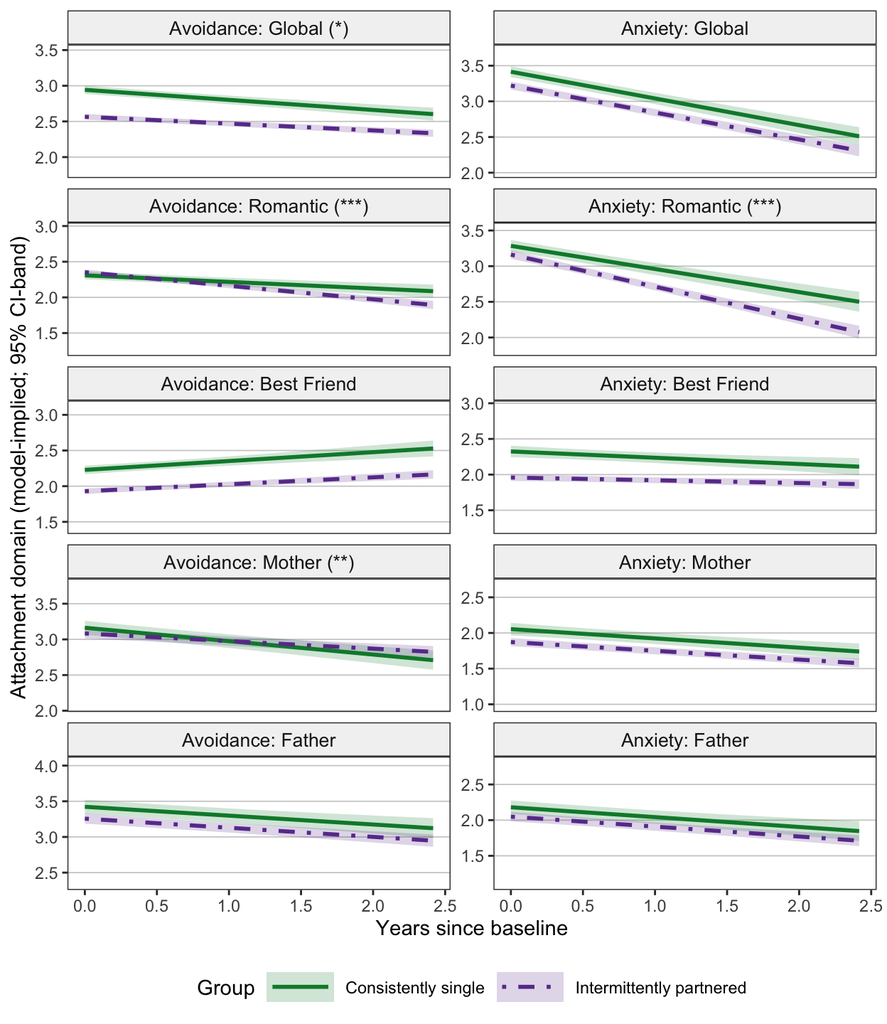

```r
plot_rq2_traject_partn_i
```

Additionally, there’s the same effect we saw in the confirmatory comparison for mother-specific avoidance. Not sure if this should be interpreted that strongly…

And we see consistently single people decrease slightly more strongly in global avoidance that the intermittently partnered people. However, this is only a slight difference and not sufficient to “close the gap” over time.

### 5.1.6 Full model results

#### 5.1.6.1 Single-group models

##### 5.1.6.1.1 Avoidance: Global

Full model results for avoidance (global) (in the intermittently partnered people):

```r
broom::tidy(get(paste0("fit_rq2_", outcomes$short[1], "_partn_i")), conf.int = TRUE, conf.level = 0.95) %>%
  filter(label != "") %>%
  arrange(label) %>%
  select(term = label, est = estimate, ci_lo = conf.low, ci_hi = conf.high, p_value = p.value, est_std = std.all) %>%
  knitr::kable(digits = 3)
```

| term | est | ci_lo | ci_hi | p_value | est_std |
| --- | --- | --- | --- | --- | --- |
| a0 | 2.565 | 2.524 | 2.605 | 0.000 | 3.668 |
| a1 | -0.231 | -0.282 | -0.180 | 0.000 | -0.335 |
| bi | -0.076 | -0.120 | -0.032 | 0.001 | -0.097 |
| bs | 0.019 | -0.035 | 0.074 | 0.489 | 0.025 |
| cis | -0.156 | -0.194 | -0.117 | 0.000 | -0.324 |
| pred_t00 | 2.565 | 2.524 | 2.605 | 0.000 | 3.668 |
| pred_t01 | 2.557 | 2.517 | 2.597 | 0.000 | 3.656 |
| pred_t02 | 2.549 | 2.510 | 2.588 | 0.000 | 3.645 |
| pred_t03 | 2.541 | 2.502 | 2.580 | 0.000 | 3.633 |
| pred_t04 | 2.533 | 2.495 | 2.571 | 0.000 | 3.622 |
| pred_t05 | 2.525 | 2.487 | 2.563 | 0.000 | 3.610 |
| pred_t06 | 2.517 | 2.479 | 2.555 | 0.000 | 3.599 |
| pred_t07 | 2.509 | 2.472 | 2.547 | 0.000 | 3.587 |
| pred_t08 | 2.501 | 2.464 | 2.539 | 0.000 | 3.576 |
| pred_t09 | 2.493 | 2.456 | 2.531 | 0.000 | 3.564 |
| pred_t10 | 2.485 | 2.448 | 2.523 | 0.000 | 3.552 |
| pred_t11 | 2.477 | 2.440 | 2.515 | 0.000 | 3.541 |
| pred_t12 | 2.469 | 2.432 | 2.507 | 0.000 | 3.529 |
| pred_t13 | 2.461 | 2.423 | 2.499 | 0.000 | 3.518 |
| pred_t14 | 2.453 | 2.415 | 2.492 | 0.000 | 3.506 |
| pred_t15 | 2.446 | 2.407 | 2.484 | 0.000 | 3.495 |
| pred_t16 | 2.438 | 2.398 | 2.477 | 0.000 | 3.483 |
| pred_t17 | 2.430 | 2.390 | 2.469 | 0.000 | 3.472 |
| pred_t18 | 2.422 | 2.381 | 2.462 | 0.000 | 3.460 |
| pred_t19 | 2.414 | 2.373 | 2.455 | 0.000 | 3.449 |
| pred_t20 | 2.406 | 2.364 | 2.448 | 0.000 | 3.437 |
| pred_t21 | 2.398 | 2.355 | 2.441 | 0.000 | 3.426 |
| pred_t22 | 2.390 | 2.346 | 2.433 | 0.000 | 3.414 |
| pred_t23 | 2.382 | 2.337 | 2.426 | 0.000 | 3.402 |
| pred_t24 | 2.374 | 2.328 | 2.419 | 0.000 | 3.391 |
| pred_t25 | 2.366 | 2.319 | 2.413 | 0.000 | 3.379 |
| pred_t26 | 2.358 | 2.310 | 2.406 | 0.000 | 3.368 |
| pred_t27 | 2.350 | 2.301 | 2.399 | 0.000 | 3.356 |
| pred_t28 | 2.342 | 2.292 | 2.392 | 0.000 | 3.345 |
| pred_t29 | 2.334 | 2.283 | 2.385 | 0.000 | 3.333 |
| res_00 | 0.222 | 0.201 | 0.242 | 0.000 | 0.312 |
| res_01 | 0.162 | 0.141 | 0.183 | 0.000 | 0.252 |
| res_02 | 0.156 | 0.137 | 0.175 | 0.000 | 0.249 |
| res_03 | 0.153 | 0.134 | 0.172 | 0.000 | 0.249 |
| res_04 | 0.137 | 0.119 | 0.154 | 0.000 | 0.231 |
| res_05 | 0.126 | 0.110 | 0.141 | 0.000 | 0.219 |
| res_06 | 0.141 | 0.124 | 0.159 | 0.000 | 0.241 |
| res_07 | 0.136 | 0.120 | 0.152 | 0.000 | 0.236 |
| res_08 | 0.127 | 0.111 | 0.142 | 0.000 | 0.224 |
| res_09 | 0.133 | 0.117 | 0.149 | 0.000 | 0.233 |
| res_10 | 0.146 | 0.129 | 0.163 | 0.000 | 0.250 |
| res_11 | 0.137 | 0.119 | 0.154 | 0.000 | 0.237 |
| res_12 | 0.152 | 0.134 | 0.170 | 0.000 | 0.256 |
| res_13 | 0.143 | 0.125 | 0.160 | 0.000 | 0.243 |
| res_14 | 0.150 | 0.131 | 0.169 | 0.000 | 0.250 |
| res_15 | 0.113 | 0.097 | 0.128 | 0.000 | 0.199 |
| res_16 | 0.120 | 0.103 | 0.138 | 0.000 | 0.207 |
| res_17 | 0.122 | 0.104 | 0.140 | 0.000 | 0.206 |
| res_18 | 0.150 | 0.126 | 0.174 | 0.000 | 0.239 |
| res_19 | 0.129 | 0.109 | 0.149 | 0.000 | 0.209 |
| res_20 | 0.148 | 0.125 | 0.170 | 0.000 | 0.228 |
| res_21 | 0.131 | 0.110 | 0.152 | 0.000 | 0.204 |
| res_22 | 0.139 | 0.117 | 0.161 | 0.000 | 0.210 |
| res_23 | 0.130 | 0.109 | 0.151 | 0.000 | 0.194 |
| res_24 | 0.135 | 0.113 | 0.157 | 0.000 | 0.196 |
| res_25 | 0.127 | 0.105 | 0.149 | 0.000 | 0.182 |
| res_26 | 0.126 | 0.102 | 0.150 | 0.000 | 0.176 |
| res_27 | 0.121 | 0.096 | 0.146 | 0.000 | 0.166 |
| res_28 | 0.127 | 0.098 | 0.156 | 0.000 | 0.168 |
| res_29 | 0.143 | 0.109 | 0.177 | 0.000 | 0.180 |
| vi | 0.484 | 0.444 | 0.525 | 0.000 | 0.991 |
| vs | 0.476 | 0.410 | 0.541 | 0.000 | 0.999 |

##### 5.1.6.1.2 Avoidance: Romantic

Full model results for avoidance (romantic) (in the intermittently partnered people):

```r
broom::tidy(get(paste0("fit_rq2_", outcomes$short[2], "_partn_i")), conf.int = TRUE, conf.level = 0.95) %>%
  filter(label != "") %>%
  arrange(label) %>%
  select(term = label, est = estimate, ci_lo = conf.low, ci_hi = conf.high, p_value = p.value, est_std = std.all) %>%
  knitr::kable(digits = 3)
```

| term | est | ci_lo | ci_hi | p_value | est_std |
| --- | --- | --- | --- | --- | --- |
| a0 | 2.352 | 2.314 | 2.391 | 0.000 | 3.784 |
| a1 | -0.459 | -0.528 | -0.390 | 0.000 | -0.504 |
| bi | 0.093 | 0.051 | 0.135 | 0.000 | 0.133 |
| bs | -0.114 | -0.188 | -0.040 | 0.003 | -0.111 |
| cis | -0.258 | -0.311 | -0.205 | 0.000 | -0.463 |
| pred_t00 | 2.352 | 2.314 | 2.391 | 0.000 | 3.784 |
| pred_t01 | 2.337 | 2.299 | 2.374 | 0.000 | 3.766 |
| pred_t02 | 2.321 | 2.284 | 2.357 | 0.000 | 3.749 |
| pred_t03 | 2.305 | 2.270 | 2.340 | 0.000 | 3.732 |
| pred_t04 | 2.289 | 2.255 | 2.324 | 0.000 | 3.714 |
| pred_t05 | 2.273 | 2.240 | 2.307 | 0.000 | 3.697 |
| pred_t06 | 2.257 | 2.224 | 2.291 | 0.000 | 3.679 |
| pred_t07 | 2.242 | 2.209 | 2.274 | 0.000 | 3.662 |
| pred_t08 | 2.226 | 2.193 | 2.258 | 0.000 | 3.645 |
| pred_t09 | 2.210 | 2.178 | 2.242 | 0.000 | 3.627 |
| pred_t10 | 2.194 | 2.162 | 2.227 | 0.000 | 3.610 |
| pred_t11 | 2.178 | 2.146 | 2.211 | 0.000 | 3.592 |
| pred_t12 | 2.163 | 2.129 | 2.196 | 0.000 | 3.575 |
| pred_t13 | 2.147 | 2.113 | 2.180 | 0.000 | 3.558 |
| pred_t14 | 2.131 | 2.096 | 2.165 | 0.000 | 3.540 |
| pred_t15 | 2.115 | 2.080 | 2.150 | 0.000 | 3.523 |
| pred_t16 | 2.099 | 2.063 | 2.136 | 0.000 | 3.506 |
| pred_t17 | 2.083 | 2.046 | 2.121 | 0.000 | 3.488 |
| pred_t18 | 2.068 | 2.029 | 2.106 | 0.000 | 3.471 |
| pred_t19 | 2.052 | 2.012 | 2.092 | 0.000 | 3.453 |
| pred_t20 | 2.036 | 1.994 | 2.078 | 0.000 | 3.436 |
| pred_t21 | 2.020 | 1.977 | 2.063 | 0.000 | 3.419 |
| pred_t22 | 2.004 | 1.959 | 2.049 | 0.000 | 3.401 |
| pred_t23 | 1.988 | 1.942 | 2.035 | 0.000 | 3.384 |
| pred_t24 | 1.973 | 1.924 | 2.021 | 0.000 | 3.366 |
| pred_t25 | 1.957 | 1.907 | 2.007 | 0.000 | 3.349 |
| pred_t26 | 1.941 | 1.889 | 1.993 | 0.000 | 3.332 |
| pred_t27 | 1.925 | 1.871 | 1.979 | 0.000 | 3.314 |
| pred_t28 | 1.909 | 1.854 | 1.965 | 0.000 | 3.297 |
| pred_t29 | 1.894 | 1.836 | 1.951 | 0.000 | 3.280 |
| res_00 | 0.382 | 0.346 | 0.418 | 0.000 | 0.497 |
| res_01 | 0.348 | 0.303 | 0.392 | 0.000 | 0.485 |
| res_02 | 0.370 | 0.326 | 0.414 | 0.000 | 0.511 |
| res_03 | 0.346 | 0.304 | 0.388 | 0.000 | 0.504 |
| res_04 | 0.339 | 0.297 | 0.381 | 0.000 | 0.507 |
| res_05 | 0.381 | 0.336 | 0.425 | 0.000 | 0.544 |
| res_06 | 0.339 | 0.298 | 0.381 | 0.000 | 0.521 |
| res_07 | 0.433 | 0.384 | 0.482 | 0.000 | 0.586 |
| res_08 | 0.369 | 0.325 | 0.414 | 0.000 | 0.550 |
| res_09 | 0.350 | 0.309 | 0.392 | 0.000 | 0.538 |
| res_10 | 0.338 | 0.299 | 0.378 | 0.000 | 0.529 |
| res_11 | 0.301 | 0.263 | 0.339 | 0.000 | 0.497 |
| res_12 | 0.341 | 0.301 | 0.382 | 0.000 | 0.526 |
| res_13 | 0.308 | 0.271 | 0.345 | 0.000 | 0.495 |
| res_14 | 0.346 | 0.302 | 0.390 | 0.000 | 0.517 |
| res_15 | 0.269 | 0.232 | 0.307 | 0.000 | 0.447 |
| res_16 | 0.253 | 0.217 | 0.289 | 0.000 | 0.423 |
| res_17 | 0.292 | 0.248 | 0.336 | 0.000 | 0.448 |
| res_18 | 0.329 | 0.278 | 0.381 | 0.000 | 0.467 |
| res_19 | 0.287 | 0.242 | 0.331 | 0.000 | 0.422 |
| res_20 | 0.358 | 0.303 | 0.413 | 0.000 | 0.464 |
| res_21 | 0.277 | 0.232 | 0.322 | 0.000 | 0.389 |
| res_22 | 0.254 | 0.213 | 0.295 | 0.000 | 0.356 |
| res_23 | 0.262 | 0.219 | 0.305 | 0.000 | 0.350 |
| res_24 | 0.285 | 0.239 | 0.331 | 0.000 | 0.357 |
| res_25 | 0.207 | 0.169 | 0.245 | 0.000 | 0.276 |
| res_26 | 0.279 | 0.227 | 0.331 | 0.000 | 0.327 |
| res_27 | 0.276 | 0.219 | 0.332 | 0.000 | 0.312 |
| res_28 | 0.363 | 0.286 | 0.440 | 0.000 | 0.360 |
| res_29 | 0.366 | 0.282 | 0.450 | 0.000 | 0.349 |
| vi | 0.380 | 0.342 | 0.417 | 0.000 | 0.982 |
| vs | 0.818 | 0.700 | 0.937 | 0.000 | 0.988 |

##### 5.1.6.1.3 Avoidance: Best Friend

Full model results for avoidance (best friend) (in the intermittently partnered people):

```r
broom::tidy(get(paste0("fit_rq2_", outcomes$short[3], "_partn_i")), conf.int = TRUE, conf.level = 0.95) %>%
  filter(label != "") %>%
  arrange(label) %>%
  select(term = label, est = estimate, ci_lo = conf.low, ci_hi = conf.high, p_value = p.value, est_std = std.all) %>%
  knitr::kable(digits = 3)
```

| term | est | ci_lo | ci_hi | p_value | est_std |
| --- | --- | --- | --- | --- | --- |
| a0 | 1.929 | 1.890 | 1.968 | 0.000 | 2.941 |
| a1 | 0.235 | 0.169 | 0.302 | 0.000 | 0.249 |
| bi | -0.065 | -0.108 | -0.023 | 0.003 | -0.088 |
| bs | -0.032 | -0.103 | 0.040 | 0.386 | -0.030 |
| cis | -0.232 | -0.281 | -0.183 | 0.000 | -0.375 |
| pred_t00 | 1.929 | 1.890 | 1.968 | 0.000 | 2.941 |
| pred_t01 | 1.937 | 1.899 | 1.975 | 0.000 | 2.949 |
| pred_t02 | 1.945 | 1.908 | 1.983 | 0.000 | 2.958 |
| pred_t03 | 1.954 | 1.917 | 1.990 | 0.000 | 2.966 |
| pred_t04 | 1.962 | 1.926 | 1.998 | 0.000 | 2.975 |
| pred_t05 | 1.970 | 1.934 | 2.005 | 0.000 | 2.983 |
| pred_t06 | 1.978 | 1.943 | 2.013 | 0.000 | 2.992 |
| pred_t07 | 1.986 | 1.951 | 2.021 | 0.000 | 3.001 |
| pred_t08 | 1.994 | 1.959 | 2.029 | 0.000 | 3.009 |
| pred_t09 | 2.002 | 1.967 | 2.037 | 0.000 | 3.018 |
| pred_t10 | 2.010 | 1.975 | 2.046 | 0.000 | 3.026 |
| pred_t11 | 2.018 | 1.983 | 2.054 | 0.000 | 3.035 |
| pred_t12 | 2.027 | 1.990 | 2.063 | 0.000 | 3.043 |
| pred_t13 | 2.035 | 1.998 | 2.072 | 0.000 | 3.052 |
| pred_t14 | 2.043 | 2.005 | 2.081 | 0.000 | 3.061 |
| pred_t15 | 2.051 | 2.012 | 2.090 | 0.000 | 3.069 |
| pred_t16 | 2.059 | 2.019 | 2.099 | 0.000 | 3.078 |
| pred_t17 | 2.067 | 2.026 | 2.108 | 0.000 | 3.086 |
| pred_t18 | 2.075 | 2.033 | 2.117 | 0.000 | 3.095 |
| pred_t19 | 2.083 | 2.040 | 2.127 | 0.000 | 3.104 |
| pred_t20 | 2.092 | 2.047 | 2.136 | 0.000 | 3.112 |
| pred_t21 | 2.100 | 2.053 | 2.146 | 0.000 | 3.121 |
| pred_t22 | 2.108 | 2.060 | 2.156 | 0.000 | 3.129 |
| pred_t23 | 2.116 | 2.066 | 2.165 | 0.000 | 3.138 |
| pred_t24 | 2.124 | 2.073 | 2.175 | 0.000 | 3.146 |
| pred_t25 | 2.132 | 2.079 | 2.185 | 0.000 | 3.155 |
| pred_t26 | 2.140 | 2.085 | 2.195 | 0.000 | 3.164 |
| pred_t27 | 2.148 | 2.092 | 2.205 | 0.000 | 3.172 |
| pred_t28 | 2.156 | 2.098 | 2.215 | 0.000 | 3.181 |
| pred_t29 | 2.165 | 2.104 | 2.225 | 0.000 | 3.189 |
| res_00 | 0.240 | 0.216 | 0.263 | 0.000 | 0.358 |
| res_01 | 0.183 | 0.158 | 0.208 | 0.000 | 0.306 |
| res_02 | 0.168 | 0.146 | 0.189 | 0.000 | 0.294 |
| res_03 | 0.220 | 0.193 | 0.247 | 0.000 | 0.360 |
| res_04 | 0.211 | 0.185 | 0.237 | 0.000 | 0.355 |
| res_05 | 0.221 | 0.194 | 0.247 | 0.000 | 0.369 |
| res_06 | 0.242 | 0.213 | 0.272 | 0.000 | 0.394 |
| res_07 | 0.266 | 0.236 | 0.297 | 0.000 | 0.418 |
| res_08 | 0.242 | 0.213 | 0.272 | 0.000 | 0.395 |
| res_09 | 0.272 | 0.240 | 0.304 | 0.000 | 0.421 |
| res_10 | 0.217 | 0.191 | 0.243 | 0.000 | 0.365 |
| res_11 | 0.227 | 0.198 | 0.256 | 0.000 | 0.371 |
| res_12 | 0.239 | 0.210 | 0.268 | 0.000 | 0.378 |
| res_13 | 0.217 | 0.191 | 0.243 | 0.000 | 0.349 |
| res_14 | 0.216 | 0.188 | 0.244 | 0.000 | 0.341 |
| res_15 | 0.222 | 0.192 | 0.253 | 0.000 | 0.340 |
| res_16 | 0.228 | 0.196 | 0.261 | 0.000 | 0.337 |
| res_17 | 0.187 | 0.158 | 0.216 | 0.000 | 0.285 |
| res_18 | 0.210 | 0.177 | 0.244 | 0.000 | 0.300 |
| res_19 | 0.242 | 0.206 | 0.279 | 0.000 | 0.321 |
| res_20 | 0.201 | 0.170 | 0.232 | 0.000 | 0.272 |
| res_21 | 0.183 | 0.153 | 0.212 | 0.000 | 0.244 |
| res_22 | 0.171 | 0.143 | 0.198 | 0.000 | 0.222 |
| res_23 | 0.154 | 0.129 | 0.180 | 0.000 | 0.197 |
| res_24 | 0.188 | 0.157 | 0.219 | 0.000 | 0.221 |
| res_25 | 0.222 | 0.184 | 0.260 | 0.000 | 0.241 |
| res_26 | 0.177 | 0.143 | 0.211 | 0.000 | 0.194 |
| res_27 | 0.193 | 0.152 | 0.234 | 0.000 | 0.199 |
| res_28 | 0.241 | 0.189 | 0.292 | 0.000 | 0.227 |
| res_29 | 0.173 | 0.130 | 0.216 | 0.000 | 0.167 |
| vi | 0.427 | 0.389 | 0.465 | 0.000 | 0.992 |
| vs | 0.895 | 0.779 | 1.011 | 0.000 | 0.999 |

##### 5.1.6.1.4 Avoidance: Mother

Full model results for avoidance (mother) (in the intermittently partnered people):

```r
broom::tidy(get(paste0("fit_rq2_", outcomes$short[4], "_partn_i")), conf.int = TRUE, conf.level = 0.95) %>%
  filter(label != "") %>%
  arrange(label) %>%
  select(term = label, est = estimate, ci_lo = conf.low, ci_hi = conf.high, p_value = p.value, est_std = std.all) %>%
  knitr::kable(digits = 3)
```

| term | est | ci_lo | ci_hi | p_value | est_std |
| --- | --- | --- | --- | --- | --- |
| a0 | 3.083 | 3.014 | 3.152 | 0.000 | 2.754 |
| a1 | -0.258 | -0.333 | -0.183 | 0.000 | -0.252 |
| bi | 0.123 | 0.044 | 0.203 | 0.002 | 0.089 |
| bs | 0.019 | -0.066 | 0.105 | 0.658 | 0.015 |
| cis | -0.374 | -0.458 | -0.291 | 0.000 | -0.327 |
| pred_t00 | 3.083 | 3.014 | 3.152 | 0.000 | 2.754 |
| pred_t01 | 3.074 | 3.006 | 3.142 | 0.000 | 2.745 |
| pred_t02 | 3.065 | 2.998 | 3.132 | 0.000 | 2.736 |
| pred_t03 | 3.056 | 2.990 | 3.123 | 0.000 | 2.727 |
| pred_t04 | 3.047 | 2.982 | 3.113 | 0.000 | 2.719 |
| pred_t05 | 3.038 | 2.973 | 3.104 | 0.000 | 2.710 |
| pred_t06 | 3.030 | 2.965 | 3.094 | 0.000 | 2.701 |
| pred_t07 | 3.021 | 2.956 | 3.085 | 0.000 | 2.693 |
| pred_t08 | 3.012 | 2.947 | 3.076 | 0.000 | 2.684 |
| pred_t09 | 3.003 | 2.939 | 3.067 | 0.000 | 2.675 |
| pred_t10 | 2.994 | 2.930 | 3.058 | 0.000 | 2.667 |
| pred_t11 | 2.985 | 2.921 | 3.049 | 0.000 | 2.658 |
| pred_t12 | 2.976 | 2.912 | 3.041 | 0.000 | 2.649 |
| pred_t13 | 2.967 | 2.902 | 3.032 | 0.000 | 2.641 |
| pred_t14 | 2.958 | 2.893 | 3.024 | 0.000 | 2.632 |
| pred_t15 | 2.949 | 2.884 | 3.015 | 0.000 | 2.623 |
| pred_t16 | 2.941 | 2.874 | 3.007 | 0.000 | 2.615 |
| pred_t17 | 2.932 | 2.865 | 2.999 | 0.000 | 2.606 |
| pred_t18 | 2.923 | 2.855 | 2.991 | 0.000 | 2.597 |
| pred_t19 | 2.914 | 2.845 | 2.983 | 0.000 | 2.589 |
| pred_t20 | 2.905 | 2.835 | 2.975 | 0.000 | 2.580 |
| pred_t21 | 2.896 | 2.825 | 2.967 | 0.000 | 2.571 |
| pred_t22 | 2.887 | 2.815 | 2.959 | 0.000 | 2.563 |
| pred_t23 | 2.878 | 2.805 | 2.951 | 0.000 | 2.554 |
| pred_t24 | 2.869 | 2.795 | 2.944 | 0.000 | 2.545 |
| pred_t25 | 2.860 | 2.785 | 2.936 | 0.000 | 2.537 |
| pred_t26 | 2.852 | 2.774 | 2.929 | 0.000 | 2.528 |
| pred_t27 | 2.843 | 2.764 | 2.921 | 0.000 | 2.519 |
| pred_t28 | 2.834 | 2.754 | 2.914 | 0.000 | 2.511 |
| pred_t29 | 2.825 | 2.743 | 2.906 | 0.000 | 2.502 |
| res_00 | 0.247 | 0.222 | 0.272 | 0.000 | 0.165 |
| res_01 | 0.208 | 0.180 | 0.236 | 0.000 | 0.145 |
| res_02 | 0.162 | 0.140 | 0.183 | 0.000 | 0.118 |
| res_03 | 0.132 | 0.114 | 0.150 | 0.000 | 0.100 |
| res_04 | 0.144 | 0.124 | 0.163 | 0.000 | 0.109 |
| res_05 | 0.148 | 0.129 | 0.166 | 0.000 | 0.113 |
| res_06 | 0.144 | 0.125 | 0.163 | 0.000 | 0.112 |
| res_07 | 0.154 | 0.135 | 0.174 | 0.000 | 0.120 |
| res_08 | 0.156 | 0.136 | 0.177 | 0.000 | 0.122 |
| res_09 | 0.169 | 0.148 | 0.191 | 0.000 | 0.131 |
| res_10 | 0.169 | 0.148 | 0.190 | 0.000 | 0.131 |
| res_11 | 0.162 | 0.140 | 0.184 | 0.000 | 0.126 |
| res_12 | 0.159 | 0.139 | 0.180 | 0.000 | 0.124 |
| res_13 | 0.142 | 0.124 | 0.160 | 0.000 | 0.111 |
| res_14 | 0.161 | 0.139 | 0.182 | 0.000 | 0.124 |
| res_15 | 0.116 | 0.099 | 0.133 | 0.000 | 0.092 |
| res_16 | 0.138 | 0.117 | 0.160 | 0.000 | 0.106 |
| res_17 | 0.115 | 0.096 | 0.133 | 0.000 | 0.089 |
| res_18 | 0.118 | 0.098 | 0.138 | 0.000 | 0.090 |
| res_19 | 0.157 | 0.132 | 0.182 | 0.000 | 0.114 |
| res_20 | 0.147 | 0.123 | 0.171 | 0.000 | 0.106 |
| res_21 | 0.115 | 0.095 | 0.135 | 0.000 | 0.084 |
| res_22 | 0.125 | 0.104 | 0.146 | 0.000 | 0.088 |
| res_23 | 0.109 | 0.090 | 0.128 | 0.000 | 0.076 |
| res_24 | 0.135 | 0.112 | 0.158 | 0.000 | 0.090 |
| res_25 | 0.083 | 0.066 | 0.100 | 0.000 | 0.056 |
| res_26 | 0.142 | 0.114 | 0.170 | 0.000 | 0.090 |
| res_27 | 0.179 | 0.142 | 0.217 | 0.000 | 0.109 |
| res_28 | 0.145 | 0.111 | 0.179 | 0.000 | 0.087 |
| res_29 | 0.195 | 0.148 | 0.243 | 0.000 | 0.111 |
| vi | 1.244 | 1.141 | 1.347 | 0.000 | 0.992 |
| vs | 1.052 | 0.930 | 1.175 | 0.000 | 1.000 |

##### 5.1.6.1.5 Avoidance: Father

Full model results for avoidance (father) (in the intermittently partnered people):

```r
broom::tidy(get(paste0("fit_rq2_", outcomes$short[5], "_partn_i")), conf.int = TRUE, conf.level = 0.95) %>%
  filter(label != "") %>%
  arrange(label) %>%
  select(term = label, est = estimate, ci_lo = conf.low, ci_hi = conf.high, p_value = p.value, est_std = std.all) %>%
  knitr::kable(digits = 3)
```

| term | est | ci_lo | ci_hi | p_value | est_std |
| --- | --- | --- | --- | --- | --- |
| a0 | 3.257 | 3.186 | 3.327 | 0.000 | 3.029 |
| a1 | -0.309 | -0.386 | -0.232 | 0.000 | -0.314 |
| bi | -0.005 | -0.089 | 0.079 | 0.911 | -0.003 |
| bs | -0.057 | -0.148 | 0.034 | 0.220 | -0.044 |
| cis | -0.289 | -0.369 | -0.210 | 0.000 | -0.274 |
| pred_t00 | 3.257 | 3.186 | 3.327 | 0.000 | 3.029 |
| pred_t01 | 3.246 | 3.176 | 3.316 | 0.000 | 3.018 |
| pred_t02 | 3.235 | 3.166 | 3.304 | 0.000 | 3.007 |
| pred_t03 | 3.225 | 3.156 | 3.293 | 0.000 | 2.996 |
| pred_t04 | 3.214 | 3.146 | 3.282 | 0.000 | 2.986 |
| pred_t05 | 3.203 | 3.136 | 3.271 | 0.000 | 2.975 |
| pred_t06 | 3.193 | 3.126 | 3.260 | 0.000 | 2.964 |
| pred_t07 | 3.182 | 3.115 | 3.249 | 0.000 | 2.953 |
| pred_t08 | 3.172 | 3.105 | 3.238 | 0.000 | 2.942 |
| pred_t09 | 3.161 | 3.094 | 3.228 | 0.000 | 2.931 |
| pred_t10 | 3.150 | 3.083 | 3.217 | 0.000 | 2.921 |
| pred_t11 | 3.140 | 3.072 | 3.207 | 0.000 | 2.910 |
| pred_t12 | 3.129 | 3.061 | 3.197 | 0.000 | 2.899 |
| pred_t13 | 3.118 | 3.050 | 3.186 | 0.000 | 2.888 |
| pred_t14 | 3.108 | 3.039 | 3.176 | 0.000 | 2.877 |
| pred_t15 | 3.097 | 3.028 | 3.166 | 0.000 | 2.866 |
| pred_t16 | 3.086 | 3.017 | 3.156 | 0.000 | 2.856 |
| pred_t17 | 3.076 | 3.005 | 3.146 | 0.000 | 2.845 |
| pred_t18 | 3.065 | 2.993 | 3.137 | 0.000 | 2.834 |
| pred_t19 | 3.054 | 2.982 | 3.127 | 0.000 | 2.823 |
| pred_t20 | 3.044 | 2.970 | 3.117 | 0.000 | 2.812 |
| pred_t21 | 3.033 | 2.958 | 3.108 | 0.000 | 2.801 |
| pred_t22 | 3.022 | 2.946 | 3.098 | 0.000 | 2.791 |
| pred_t23 | 3.012 | 2.935 | 3.089 | 0.000 | 2.780 |
| pred_t24 | 3.001 | 2.923 | 3.080 | 0.000 | 2.769 |
| pred_t25 | 2.991 | 2.910 | 3.071 | 0.000 | 2.758 |
| pred_t26 | 2.980 | 2.898 | 3.061 | 0.000 | 2.747 |
| pred_t27 | 2.969 | 2.886 | 3.052 | 0.000 | 2.736 |
| pred_t28 | 2.959 | 2.874 | 3.043 | 0.000 | 2.725 |
| pred_t29 | 2.948 | 2.862 | 3.034 | 0.000 | 2.715 |
| res_00 | 0.266 | 0.239 | 0.293 | 0.000 | 0.187 |
| res_01 | 0.153 | 0.131 | 0.176 | 0.000 | 0.119 |
| res_02 | 0.174 | 0.151 | 0.198 | 0.000 | 0.134 |
| res_03 | 0.139 | 0.120 | 0.158 | 0.000 | 0.112 |
| res_04 | 0.118 | 0.102 | 0.135 | 0.000 | 0.098 |
| res_05 | 0.139 | 0.121 | 0.158 | 0.000 | 0.114 |
| res_06 | 0.136 | 0.118 | 0.155 | 0.000 | 0.112 |
| res_07 | 0.139 | 0.121 | 0.156 | 0.000 | 0.114 |
| res_08 | 0.158 | 0.137 | 0.179 | 0.000 | 0.129 |
| res_09 | 0.180 | 0.157 | 0.202 | 0.000 | 0.144 |
| res_10 | 0.152 | 0.132 | 0.172 | 0.000 | 0.124 |
| res_11 | 0.134 | 0.116 | 0.153 | 0.000 | 0.111 |
| res_12 | 0.158 | 0.138 | 0.179 | 0.000 | 0.128 |
| res_13 | 0.125 | 0.108 | 0.141 | 0.000 | 0.102 |
| res_14 | 0.127 | 0.108 | 0.145 | 0.000 | 0.103 |
| res_15 | 0.123 | 0.104 | 0.142 | 0.000 | 0.099 |
| res_16 | 0.115 | 0.095 | 0.134 | 0.000 | 0.092 |
| res_17 | 0.137 | 0.114 | 0.160 | 0.000 | 0.106 |
| res_18 | 0.099 | 0.081 | 0.117 | 0.000 | 0.078 |
| res_19 | 0.110 | 0.091 | 0.129 | 0.000 | 0.084 |
| res_20 | 0.144 | 0.119 | 0.168 | 0.000 | 0.106 |
| res_21 | 0.132 | 0.109 | 0.156 | 0.000 | 0.096 |
| res_22 | 0.105 | 0.086 | 0.124 | 0.000 | 0.076 |
| res_23 | 0.111 | 0.091 | 0.130 | 0.000 | 0.078 |
| res_24 | 0.184 | 0.152 | 0.215 | 0.000 | 0.121 |
| res_25 | 0.097 | 0.077 | 0.117 | 0.000 | 0.066 |
| res_26 | 0.091 | 0.071 | 0.111 | 0.000 | 0.060 |
| res_27 | 0.119 | 0.093 | 0.146 | 0.000 | 0.076 |
| res_28 | 0.125 | 0.093 | 0.156 | 0.000 | 0.077 |
| res_29 | 0.154 | 0.114 | 0.195 | 0.000 | 0.091 |
| vi | 1.156 | 1.057 | 1.255 | 0.000 | 1.000 |
| vs | 0.964 | 0.845 | 1.083 | 0.000 | 0.998 |

##### 5.1.6.1.6 Anxiety: Global

Full model results for anxiety (global) (in the intermittently partnered people):

```r
broom::tidy(get(paste0("fit_rq2_", outcomes$short[6], "_partn_i")), conf.int = TRUE, conf.level = 0.95) %>%
  filter(label != "") %>%
  arrange(label) %>%
  select(term = label, est = estimate, ci_lo = conf.low, ci_hi = conf.high, p_value = p.value, est_std = std.all) %>%
  knitr::kable(digits = 3)
```

| term | est | ci_lo | ci_hi | p_value | est_std |
| --- | --- | --- | --- | --- | --- |
| a0 | 3.221 | 3.166 | 3.276 | 0.000 | 3.493 |
| a1 | -0.913 | -0.997 | -0.830 | 0.000 | -0.797 |
| bi | -0.127 | -0.186 | -0.068 | 0.000 | -0.123 |
| bs | 0.003 | -0.086 | 0.091 | 0.953 | 0.002 |
| cis | -0.342 | -0.425 | -0.259 | 0.000 | -0.326 |
| pred_t00 | 3.221 | 3.166 | 3.276 | 0.000 | 3.493 |
| pred_t01 | 3.190 | 3.136 | 3.243 | 0.000 | 3.466 |
| pred_t02 | 3.158 | 3.106 | 3.210 | 0.000 | 3.438 |
| pred_t03 | 3.127 | 3.075 | 3.178 | 0.000 | 3.411 |
| pred_t04 | 3.095 | 3.044 | 3.146 | 0.000 | 3.383 |
| pred_t05 | 3.064 | 3.013 | 3.114 | 0.000 | 3.356 |
| pred_t06 | 3.032 | 2.982 | 3.082 | 0.000 | 3.328 |
| pred_t07 | 3.001 | 2.951 | 3.050 | 0.000 | 3.301 |
| pred_t08 | 2.969 | 2.920 | 3.019 | 0.000 | 3.273 |
| pred_t09 | 2.938 | 2.888 | 2.987 | 0.000 | 3.246 |
| pred_t10 | 2.906 | 2.856 | 2.956 | 0.000 | 3.218 |
| pred_t11 | 2.875 | 2.824 | 2.925 | 0.000 | 3.191 |
| pred_t12 | 2.843 | 2.792 | 2.894 | 0.000 | 3.163 |
| pred_t13 | 2.812 | 2.760 | 2.863 | 0.000 | 3.136 |
| pred_t14 | 2.780 | 2.728 | 2.832 | 0.000 | 3.108 |
| pred_t15 | 2.749 | 2.695 | 2.802 | 0.000 | 3.081 |
| pred_t16 | 2.717 | 2.663 | 2.772 | 0.000 | 3.053 |
| pred_t17 | 2.686 | 2.630 | 2.741 | 0.000 | 3.026 |
| pred_t18 | 2.654 | 2.597 | 2.711 | 0.000 | 2.998 |
| pred_t19 | 2.623 | 2.564 | 2.681 | 0.000 | 2.971 |
| pred_t20 | 2.591 | 2.531 | 2.651 | 0.000 | 2.943 |
| pred_t21 | 2.560 | 2.498 | 2.622 | 0.000 | 2.916 |
| pred_t22 | 2.528 | 2.464 | 2.592 | 0.000 | 2.888 |
| pred_t23 | 2.497 | 2.431 | 2.562 | 0.000 | 2.861 |
| pred_t24 | 2.465 | 2.398 | 2.533 | 0.000 | 2.833 |
| pred_t25 | 2.434 | 2.364 | 2.503 | 0.000 | 2.806 |
| pred_t26 | 2.402 | 2.331 | 2.474 | 0.000 | 2.778 |
| pred_t27 | 2.371 | 2.297 | 2.444 | 0.000 | 2.751 |
| pred_t28 | 2.339 | 2.263 | 2.415 | 0.000 | 2.723 |
| pred_t29 | 2.308 | 2.230 | 2.386 | 0.000 | 2.696 |
| res_00 | 0.534 | 0.485 | 0.583 | 0.000 | 0.386 |
| res_01 | 0.416 | 0.363 | 0.469 | 0.000 | 0.335 |
| res_02 | 0.356 | 0.312 | 0.400 | 0.000 | 0.305 |
| res_03 | 0.334 | 0.292 | 0.375 | 0.000 | 0.296 |
| res_04 | 0.330 | 0.288 | 0.371 | 0.000 | 0.297 |
| res_05 | 0.340 | 0.300 | 0.381 | 0.000 | 0.306 |
| res_06 | 0.344 | 0.302 | 0.387 | 0.000 | 0.310 |
| res_07 | 0.311 | 0.274 | 0.347 | 0.000 | 0.290 |
| res_08 | 0.313 | 0.274 | 0.352 | 0.000 | 0.292 |
| res_09 | 0.323 | 0.284 | 0.361 | 0.000 | 0.297 |
| res_10 | 0.338 | 0.298 | 0.378 | 0.000 | 0.305 |
| res_11 | 0.329 | 0.288 | 0.371 | 0.000 | 0.297 |
| res_12 | 0.291 | 0.255 | 0.327 | 0.000 | 0.269 |
| res_13 | 0.294 | 0.258 | 0.330 | 0.000 | 0.267 |
| res_14 | 0.292 | 0.254 | 0.330 | 0.000 | 0.261 |
| res_15 | 0.305 | 0.263 | 0.347 | 0.000 | 0.265 |
| res_16 | 0.291 | 0.249 | 0.333 | 0.000 | 0.250 |
| res_17 | 0.290 | 0.247 | 0.334 | 0.000 | 0.244 |
| res_18 | 0.371 | 0.313 | 0.429 | 0.000 | 0.285 |
| res_19 | 0.310 | 0.263 | 0.358 | 0.000 | 0.243 |
| res_20 | 0.271 | 0.228 | 0.314 | 0.000 | 0.213 |
| res_21 | 0.288 | 0.241 | 0.334 | 0.000 | 0.216 |
| res_22 | 0.269 | 0.226 | 0.312 | 0.000 | 0.199 |
| res_23 | 0.296 | 0.249 | 0.343 | 0.000 | 0.207 |
| res_24 | 0.305 | 0.256 | 0.354 | 0.000 | 0.205 |
| res_25 | 0.236 | 0.193 | 0.278 | 0.000 | 0.160 |
| res_26 | 0.280 | 0.227 | 0.332 | 0.000 | 0.178 |
| res_27 | 0.288 | 0.229 | 0.347 | 0.000 | 0.176 |
| res_28 | 0.259 | 0.199 | 0.319 | 0.000 | 0.155 |
| res_29 | 0.217 | 0.160 | 0.273 | 0.000 | 0.128 |
| vi | 0.837 | 0.764 | 0.911 | 0.000 | 0.985 |
| vs | 1.312 | 1.143 | 1.480 | 0.000 | 1.000 |

##### 5.1.6.1.7 Anxiety: Romantic

Full model results for anxiety (romantic) (in the intermittently partnered people):

```r
broom::tidy(get(paste0("fit_rq2_", outcomes$short[7], "_partn_i")), conf.int = TRUE, conf.level = 0.95) %>%
  filter(label != "") %>%
  arrange(label) %>%
  select(term = label, est = estimate, ci_lo = conf.low, ci_hi = conf.high, p_value = p.value, est_std = std.all) %>%
  knitr::kable(digits = 3)
```

| term | est | ci_lo | ci_hi | p_value | est_std |
| --- | --- | --- | --- | --- | --- |
| a0 | 3.162 | 3.103 | 3.221 | 0.000 | 3.296 |
| a1 | -1.086 | -1.193 | -0.980 | 0.000 | -0.727 |
| bi | -0.066 | -0.129 | -0.002 | 0.043 | -0.061 |
| bs | -0.041 | -0.154 | 0.072 | 0.479 | -0.024 |
| cis | -0.667 | -0.788 | -0.547 | 0.000 | -0.466 |
| pred_t00 | 3.162 | 3.103 | 3.221 | 0.000 | 3.296 |
| pred_t01 | 3.125 | 3.068 | 3.181 | 0.000 | 3.271 |
| pred_t02 | 3.087 | 3.032 | 3.142 | 0.000 | 3.245 |
| pred_t03 | 3.050 | 2.996 | 3.103 | 0.000 | 3.220 |
| pred_t04 | 3.012 | 2.960 | 3.064 | 0.000 | 3.195 |
| pred_t05 | 2.975 | 2.924 | 3.026 | 0.000 | 3.170 |
| pred_t06 | 2.937 | 2.887 | 2.988 | 0.000 | 3.145 |
| pred_t07 | 2.900 | 2.850 | 2.950 | 0.000 | 3.120 |
| pred_t08 | 2.862 | 2.813 | 2.912 | 0.000 | 3.095 |
| pred_t09 | 2.825 | 2.776 | 2.874 | 0.000 | 3.070 |
| pred_t10 | 2.787 | 2.738 | 2.837 | 0.000 | 3.045 |
| pred_t11 | 2.750 | 2.700 | 2.800 | 0.000 | 3.020 |
| pred_t12 | 2.713 | 2.662 | 2.763 | 0.000 | 2.995 |
| pred_t13 | 2.675 | 2.623 | 2.727 | 0.000 | 2.970 |
| pred_t14 | 2.638 | 2.584 | 2.691 | 0.000 | 2.945 |
| pred_t15 | 2.600 | 2.546 | 2.655 | 0.000 | 2.920 |
| pred_t16 | 2.563 | 2.506 | 2.619 | 0.000 | 2.895 |
| pred_t17 | 2.525 | 2.467 | 2.583 | 0.000 | 2.870 |
| pred_t18 | 2.488 | 2.428 | 2.548 | 0.000 | 2.845 |
| pred_t19 | 2.450 | 2.388 | 2.513 | 0.000 | 2.819 |
| pred_t20 | 2.413 | 2.348 | 2.478 | 0.000 | 2.794 |
| pred_t21 | 2.375 | 2.308 | 2.443 | 0.000 | 2.769 |
| pred_t22 | 2.338 | 2.268 | 2.408 | 0.000 | 2.744 |
| pred_t23 | 2.301 | 2.228 | 2.373 | 0.000 | 2.719 |
| pred_t24 | 2.263 | 2.188 | 2.338 | 0.000 | 2.694 |
| pred_t25 | 2.226 | 2.148 | 2.303 | 0.000 | 2.669 |
| pred_t26 | 2.188 | 2.108 | 2.269 | 0.000 | 2.644 |
| pred_t27 | 2.151 | 2.067 | 2.234 | 0.000 | 2.619 |
| pred_t28 | 2.113 | 2.027 | 2.200 | 0.000 | 2.594 |
| pred_t29 | 2.076 | 1.986 | 2.165 | 0.000 | 2.569 |
| res_00 | 0.783 | 0.710 | 0.856 | 0.000 | 0.460 |
| res_01 | 0.533 | 0.461 | 0.604 | 0.000 | 0.378 |
| res_02 | 0.572 | 0.502 | 0.643 | 0.000 | 0.405 |
| res_03 | 0.565 | 0.495 | 0.635 | 0.000 | 0.412 |
| res_04 | 0.538 | 0.471 | 0.605 | 0.000 | 0.408 |
| res_05 | 0.581 | 0.512 | 0.649 | 0.000 | 0.434 |
| res_06 | 0.545 | 0.478 | 0.613 | 0.000 | 0.424 |
| res_07 | 0.560 | 0.495 | 0.625 | 0.000 | 0.434 |
| res_08 | 0.485 | 0.425 | 0.546 | 0.000 | 0.401 |
| res_09 | 0.543 | 0.478 | 0.608 | 0.000 | 0.429 |
| res_10 | 0.530 | 0.467 | 0.593 | 0.000 | 0.421 |
| res_11 | 0.501 | 0.437 | 0.565 | 0.000 | 0.404 |
| res_12 | 0.499 | 0.438 | 0.559 | 0.000 | 0.398 |
| res_13 | 0.501 | 0.439 | 0.562 | 0.000 | 0.393 |
| res_14 | 0.492 | 0.428 | 0.555 | 0.000 | 0.381 |
| res_15 | 0.531 | 0.459 | 0.603 | 0.000 | 0.390 |
| res_16 | 0.422 | 0.361 | 0.483 | 0.000 | 0.327 |
| res_17 | 0.454 | 0.387 | 0.522 | 0.000 | 0.333 |
| res_18 | 0.477 | 0.401 | 0.553 | 0.000 | 0.333 |
| res_19 | 0.448 | 0.378 | 0.518 | 0.000 | 0.307 |
| res_20 | 0.461 | 0.388 | 0.534 | 0.000 | 0.302 |
| res_21 | 0.512 | 0.429 | 0.595 | 0.000 | 0.312 |
| res_22 | 0.391 | 0.328 | 0.455 | 0.000 | 0.246 |
| res_23 | 0.416 | 0.349 | 0.484 | 0.000 | 0.247 |
| res_24 | 0.471 | 0.394 | 0.548 | 0.000 | 0.259 |
| res_25 | 0.418 | 0.343 | 0.493 | 0.000 | 0.226 |
| res_26 | 0.373 | 0.300 | 0.446 | 0.000 | 0.197 |
| res_27 | 0.371 | 0.292 | 0.451 | 0.000 | 0.187 |
| res_28 | 0.488 | 0.380 | 0.596 | 0.000 | 0.221 |
| res_29 | 0.645 | 0.499 | 0.792 | 0.000 | 0.261 |
| vi | 0.917 | 0.833 | 1.001 | 0.000 | 0.996 |
| vs | 2.233 | 1.945 | 2.521 | 0.000 | 0.999 |

##### 5.1.6.1.8 Anxiety: Best Friend

Full model results for anxiety (best friend) (in the intermittently partnered people):

```r
broom::tidy(get(paste0("fit_rq2_", outcomes$short[8], "_partn_i")), conf.int = TRUE, conf.level = 0.95) %>%
  filter(label != "") %>%
  arrange(label) %>%
  select(term = label, est = estimate, ci_lo = conf.low, ci_hi = conf.high, p_value = p.value, est_std = std.all) %>%
  knitr::kable(digits = 3)
```

| term | est | ci_lo | ci_hi | p_value | est_std |
| --- | --- | --- | --- | --- | --- |
| a0 | 1.959 | 1.910 | 2.007 | 0.000 | 2.381 |
| a1 | -0.093 | -0.171 | -0.015 | 0.020 | -0.084 |
| bi | -0.140 | -0.193 | -0.087 | 0.000 | -0.151 |
| bs | 0.091 | 0.007 | 0.175 | 0.034 | 0.073 |
| cis | -0.443 | -0.518 | -0.367 | 0.000 | -0.492 |
| pred_t00 | 1.959 | 1.910 | 2.007 | 0.000 | 2.381 |
| pred_t01 | 1.956 | 1.909 | 2.003 | 0.000 | 2.378 |
| pred_t02 | 1.953 | 1.907 | 1.998 | 0.000 | 2.375 |
| pred_t03 | 1.949 | 1.905 | 1.994 | 0.000 | 2.372 |
| pred_t04 | 1.946 | 1.902 | 1.990 | 0.000 | 2.369 |
| pred_t05 | 1.943 | 1.900 | 1.986 | 0.000 | 2.367 |
| pred_t06 | 1.940 | 1.898 | 1.982 | 0.000 | 2.364 |
| pred_t07 | 1.937 | 1.895 | 1.978 | 0.000 | 2.361 |
| pred_t08 | 1.933 | 1.892 | 1.975 | 0.000 | 2.358 |
| pred_t09 | 1.930 | 1.889 | 1.971 | 0.000 | 2.355 |
| pred_t10 | 1.927 | 1.886 | 1.968 | 0.000 | 2.352 |
| pred_t11 | 1.924 | 1.883 | 1.965 | 0.000 | 2.349 |
| pred_t12 | 1.921 | 1.879 | 1.962 | 0.000 | 2.346 |
| pred_t13 | 1.917 | 1.875 | 1.959 | 0.000 | 2.343 |
| pred_t14 | 1.914 | 1.872 | 1.957 | 0.000 | 2.341 |
| pred_t15 | 1.911 | 1.868 | 1.954 | 0.000 | 2.338 |
| pred_t16 | 1.908 | 1.863 | 1.952 | 0.000 | 2.335 |
| pred_t17 | 1.905 | 1.859 | 1.950 | 0.000 | 2.332 |
| pred_t18 | 1.901 | 1.855 | 1.948 | 0.000 | 2.329 |
| pred_t19 | 1.898 | 1.850 | 1.946 | 0.000 | 2.326 |
| pred_t20 | 1.895 | 1.845 | 1.944 | 0.000 | 2.323 |
| pred_t21 | 1.892 | 1.841 | 1.943 | 0.000 | 2.320 |
| pred_t22 | 1.889 | 1.836 | 1.941 | 0.000 | 2.317 |
| pred_t23 | 1.885 | 1.831 | 1.940 | 0.000 | 2.315 |
| pred_t24 | 1.882 | 1.826 | 1.938 | 0.000 | 2.312 |
| pred_t25 | 1.879 | 1.821 | 1.937 | 0.000 | 2.309 |
| pred_t26 | 1.876 | 1.816 | 1.936 | 0.000 | 2.306 |
| pred_t27 | 1.873 | 1.811 | 1.934 | 0.000 | 2.303 |
| pred_t28 | 1.869 | 1.805 | 1.933 | 0.000 | 2.300 |
| pred_t29 | 1.866 | 1.800 | 1.932 | 0.000 | 2.297 |
| res_00 | 0.464 | 0.421 | 0.507 | 0.000 | 0.407 |
| res_01 | 0.284 | 0.246 | 0.322 | 0.000 | 0.305 |
| res_02 | 0.275 | 0.241 | 0.310 | 0.000 | 0.307 |
| res_03 | 0.294 | 0.258 | 0.331 | 0.000 | 0.330 |
| res_04 | 0.302 | 0.264 | 0.339 | 0.000 | 0.344 |
| res_05 | 0.302 | 0.266 | 0.338 | 0.000 | 0.351 |
| res_06 | 0.283 | 0.248 | 0.318 | 0.000 | 0.343 |
| res_07 | 0.343 | 0.304 | 0.383 | 0.000 | 0.393 |
| res_08 | 0.278 | 0.244 | 0.313 | 0.000 | 0.348 |
| res_09 | 0.297 | 0.261 | 0.332 | 0.000 | 0.366 |
| res_10 | 0.292 | 0.257 | 0.327 | 0.000 | 0.364 |
| res_11 | 0.316 | 0.276 | 0.356 | 0.000 | 0.382 |
| res_12 | 0.318 | 0.280 | 0.356 | 0.000 | 0.383 |
| res_13 | 0.309 | 0.272 | 0.346 | 0.000 | 0.373 |
| res_14 | 0.272 | 0.237 | 0.307 | 0.000 | 0.341 |
| res_15 | 0.297 | 0.257 | 0.337 | 0.000 | 0.355 |
| res_16 | 0.259 | 0.222 | 0.296 | 0.000 | 0.319 |
| res_17 | 0.241 | 0.204 | 0.278 | 0.000 | 0.297 |
| res_18 | 0.288 | 0.243 | 0.333 | 0.000 | 0.328 |
| res_19 | 0.264 | 0.224 | 0.305 | 0.000 | 0.301 |
| res_20 | 0.298 | 0.252 | 0.344 | 0.000 | 0.318 |
| res_21 | 0.221 | 0.185 | 0.257 | 0.000 | 0.249 |
| res_22 | 0.240 | 0.202 | 0.277 | 0.000 | 0.255 |
| res_23 | 0.199 | 0.166 | 0.232 | 0.000 | 0.213 |
| res_24 | 0.199 | 0.165 | 0.233 | 0.000 | 0.205 |
| res_25 | 0.258 | 0.213 | 0.303 | 0.000 | 0.241 |
| res_26 | 0.193 | 0.155 | 0.231 | 0.000 | 0.184 |
| res_27 | 0.280 | 0.223 | 0.336 | 0.000 | 0.237 |
| res_28 | 0.319 | 0.250 | 0.387 | 0.000 | 0.251 |
| res_29 | 0.224 | 0.168 | 0.279 | 0.000 | 0.182 |
| vi | 0.661 | 0.603 | 0.720 | 0.000 | 0.977 |
| vs | 1.225 | 1.066 | 1.385 | 0.000 | 0.995 |

##### 5.1.6.1.9 Anxiety: Mother

Full model results for anxiety (mother) (in the intermittently partnered people):

```r
broom::tidy(get(paste0("fit_rq2_", outcomes$short[9], "_partn_i")), conf.int = TRUE, conf.level = 0.95) %>%
  filter(label != "") %>%
  arrange(label) %>%
  select(term = label, est = estimate, ci_lo = conf.low, ci_hi = conf.high, p_value = p.value, est_std = std.all) %>%
  knitr::kable(digits = 3)
```

| term | est | ci_lo | ci_hi | p_value | est_std |
| --- | --- | --- | --- | --- | --- |
| a0 | 1.872 | 1.815 | 1.930 | 0.000 | 2.042 |
| a1 | -0.297 | -0.363 | -0.231 | 0.000 | -0.352 |
| bi | 0.124 | 0.058 | 0.190 | 0.000 | 0.109 |
| bs | -0.103 | -0.179 | -0.028 | 0.007 | -0.099 |
| cis | -0.378 | -0.443 | -0.312 | 0.000 | -0.494 |
| pred_t00 | 1.872 | 1.815 | 1.930 | 0.000 | 2.042 |
| pred_t01 | 1.862 | 1.806 | 1.918 | 0.000 | 2.030 |
| pred_t02 | 1.852 | 1.797 | 1.907 | 0.000 | 2.018 |
| pred_t03 | 1.842 | 1.788 | 1.896 | 0.000 | 2.006 |
| pred_t04 | 1.832 | 1.778 | 1.885 | 0.000 | 1.994 |
| pred_t05 | 1.821 | 1.769 | 1.874 | 0.000 | 1.982 |
| pred_t06 | 1.811 | 1.759 | 1.863 | 0.000 | 1.970 |
| pred_t07 | 1.801 | 1.750 | 1.852 | 0.000 | 1.957 |
| pred_t08 | 1.791 | 1.740 | 1.841 | 0.000 | 1.945 |
| pred_t09 | 1.780 | 1.730 | 1.830 | 0.000 | 1.933 |
| pred_t10 | 1.770 | 1.720 | 1.820 | 0.000 | 1.921 |
| pred_t11 | 1.760 | 1.710 | 1.809 | 0.000 | 1.909 |
| pred_t12 | 1.750 | 1.700 | 1.799 | 0.000 | 1.897 |
| pred_t13 | 1.739 | 1.690 | 1.789 | 0.000 | 1.885 |
| pred_t14 | 1.729 | 1.680 | 1.778 | 0.000 | 1.872 |
| pred_t15 | 1.719 | 1.669 | 1.768 | 0.000 | 1.860 |
| pred_t16 | 1.709 | 1.659 | 1.758 | 0.000 | 1.848 |
| pred_t17 | 1.698 | 1.648 | 1.749 | 0.000 | 1.836 |
| pred_t18 | 1.688 | 1.638 | 1.739 | 0.000 | 1.824 |
| pred_t19 | 1.678 | 1.627 | 1.729 | 0.000 | 1.812 |
| pred_t20 | 1.668 | 1.616 | 1.720 | 0.000 | 1.800 |
| pred_t21 | 1.658 | 1.605 | 1.710 | 0.000 | 1.787 |
| pred_t22 | 1.647 | 1.594 | 1.701 | 0.000 | 1.775 |
| pred_t23 | 1.637 | 1.583 | 1.691 | 0.000 | 1.763 |
| pred_t24 | 1.627 | 1.571 | 1.682 | 0.000 | 1.751 |
| pred_t25 | 1.617 | 1.560 | 1.673 | 0.000 | 1.739 |
| pred_t26 | 1.606 | 1.549 | 1.664 | 0.000 | 1.727 |
| pred_t27 | 1.596 | 1.537 | 1.655 | 0.000 | 1.715 |
| pred_t28 | 1.586 | 1.526 | 1.646 | 0.000 | 1.702 |
| pred_t29 | 1.576 | 1.514 | 1.637 | 0.000 | 1.690 |
| res_00 | 0.420 | 0.381 | 0.459 | 0.000 | 0.333 |
| res_01 | 0.272 | 0.236 | 0.307 | 0.000 | 0.250 |
| res_02 | 0.237 | 0.207 | 0.268 | 0.000 | 0.231 |
| res_03 | 0.190 | 0.166 | 0.215 | 0.000 | 0.199 |
| res_04 | 0.169 | 0.146 | 0.192 | 0.000 | 0.184 |
| res_05 | 0.165 | 0.144 | 0.186 | 0.000 | 0.185 |
| res_06 | 0.164 | 0.143 | 0.185 | 0.000 | 0.187 |
| res_07 | 0.126 | 0.110 | 0.142 | 0.000 | 0.153 |
| res_08 | 0.153 | 0.132 | 0.173 | 0.000 | 0.183 |
| res_09 | 0.183 | 0.160 | 0.205 | 0.000 | 0.214 |
| res_10 | 0.161 | 0.141 | 0.182 | 0.000 | 0.197 |
| res_11 | 0.162 | 0.141 | 0.184 | 0.000 | 0.200 |
| res_12 | 0.170 | 0.149 | 0.191 | 0.000 | 0.209 |
| res_13 | 0.164 | 0.143 | 0.185 | 0.000 | 0.205 |
| res_14 | 0.166 | 0.144 | 0.188 | 0.000 | 0.208 |
| res_15 | 0.107 | 0.091 | 0.122 | 0.000 | 0.145 |
| res_16 | 0.117 | 0.099 | 0.135 | 0.000 | 0.156 |
| res_17 | 0.161 | 0.136 | 0.186 | 0.000 | 0.203 |
| res_18 | 0.145 | 0.121 | 0.170 | 0.000 | 0.186 |
| res_19 | 0.145 | 0.121 | 0.168 | 0.000 | 0.184 |
| res_20 | 0.172 | 0.144 | 0.200 | 0.000 | 0.210 |
| res_21 | 0.122 | 0.101 | 0.142 | 0.000 | 0.157 |
| res_22 | 0.116 | 0.096 | 0.136 | 0.000 | 0.149 |
| res_23 | 0.126 | 0.105 | 0.148 | 0.000 | 0.158 |
| res_24 | 0.127 | 0.104 | 0.149 | 0.000 | 0.156 |
| res_25 | 0.110 | 0.089 | 0.131 | 0.000 | 0.135 |
| res_26 | 0.125 | 0.100 | 0.151 | 0.000 | 0.148 |
| res_27 | 0.145 | 0.113 | 0.176 | 0.000 | 0.164 |
| res_28 | 0.208 | 0.161 | 0.255 | 0.000 | 0.215 |
| res_29 | 0.162 | 0.121 | 0.203 | 0.000 | 0.172 |
| vi | 0.831 | 0.759 | 0.902 | 0.000 | 0.988 |
| vs | 0.703 | 0.607 | 0.799 | 0.000 | 0.990 |

##### 5.1.6.1.10 Anxiety: Father

Full model results for anxiety (father) (in the intermittently partnered people):

```r
broom::tidy(get(paste0("fit_rq2_", outcomes$short[10], "_partn_i")), conf.int = TRUE, conf.level = 0.95) %>%
  filter(label != "") %>%
  arrange(label) %>%
  select(term = label, est = estimate, ci_lo = conf.low, ci_hi = conf.high, p_value = p.value, est_std = std.all) %>%
  knitr::kable(digits = 3)
```

| term | est | ci_lo | ci_hi | p_value | est_std |
| --- | --- | --- | --- | --- | --- |
| a0 | 2.049 | 1.982 | 2.115 | 0.000 | 2.055 |
| a1 | -0.336 | -0.417 | -0.256 | 0.000 | -0.341 |
| bi | 0.066 | -0.013 | 0.145 | 0.101 | 0.050 |
| bs | -0.104 | -0.199 | -0.009 | 0.031 | -0.080 |
| cis | -0.440 | -0.525 | -0.356 | 0.000 | -0.449 |
| pred_t00 | 2.049 | 1.982 | 2.115 | 0.000 | 2.055 |
| pred_t01 | 2.037 | 1.972 | 2.102 | 0.000 | 2.043 |
| pred_t02 | 2.025 | 1.961 | 2.089 | 0.000 | 2.031 |
| pred_t03 | 2.014 | 1.951 | 2.077 | 0.000 | 2.020 |
| pred_t04 | 2.002 | 1.940 | 2.064 | 0.000 | 2.008 |
| pred_t05 | 1.991 | 1.930 | 2.052 | 0.000 | 1.996 |
| pred_t06 | 1.979 | 1.919 | 2.039 | 0.000 | 1.984 |
| pred_t07 | 1.967 | 1.908 | 2.027 | 0.000 | 1.973 |
| pred_t08 | 1.956 | 1.897 | 2.015 | 0.000 | 1.961 |
| pred_t09 | 1.944 | 1.885 | 2.003 | 0.000 | 1.949 |
| pred_t10 | 1.933 | 1.874 | 1.991 | 0.000 | 1.937 |
| pred_t11 | 1.921 | 1.863 | 1.979 | 0.000 | 1.926 |
| pred_t12 | 1.909 | 1.851 | 1.968 | 0.000 | 1.914 |
| pred_t13 | 1.898 | 1.839 | 1.956 | 0.000 | 1.902 |
| pred_t14 | 1.886 | 1.827 | 1.945 | 0.000 | 1.890 |
| pred_t15 | 1.875 | 1.815 | 1.934 | 0.000 | 1.879 |
| pred_t16 | 1.863 | 1.803 | 1.923 | 0.000 | 1.867 |
| pred_t17 | 1.851 | 1.791 | 1.912 | 0.000 | 1.855 |
| pred_t18 | 1.840 | 1.779 | 1.901 | 0.000 | 1.843 |
| pred_t19 | 1.828 | 1.766 | 1.890 | 0.000 | 1.832 |
| pred_t20 | 1.817 | 1.753 | 1.880 | 0.000 | 1.820 |
| pred_t21 | 1.805 | 1.741 | 1.869 | 0.000 | 1.808 |
| pred_t22 | 1.793 | 1.728 | 1.859 | 0.000 | 1.796 |
| pred_t23 | 1.782 | 1.715 | 1.848 | 0.000 | 1.785 |
| pred_t24 | 1.770 | 1.702 | 1.838 | 0.000 | 1.773 |
| pred_t25 | 1.759 | 1.689 | 1.828 | 0.000 | 1.761 |
| pred_t26 | 1.747 | 1.676 | 1.818 | 0.000 | 1.749 |
| pred_t27 | 1.735 | 1.663 | 1.808 | 0.000 | 1.738 |
| pred_t28 | 1.724 | 1.649 | 1.798 | 0.000 | 1.726 |
| pred_t29 | 1.712 | 1.636 | 1.788 | 0.000 | 1.714 |
| res_00 | 0.416 | 0.375 | 0.457 | 0.000 | 0.295 |
| res_01 | 0.274 | 0.236 | 0.312 | 0.000 | 0.221 |
| res_02 | 0.280 | 0.243 | 0.317 | 0.000 | 0.230 |
| res_03 | 0.201 | 0.173 | 0.229 | 0.000 | 0.181 |
| res_04 | 0.221 | 0.191 | 0.251 | 0.000 | 0.199 |
| res_05 | 0.196 | 0.170 | 0.222 | 0.000 | 0.184 |
| res_06 | 0.198 | 0.170 | 0.225 | 0.000 | 0.188 |
| res_07 | 0.181 | 0.158 | 0.205 | 0.000 | 0.178 |
| res_08 | 0.213 | 0.185 | 0.242 | 0.000 | 0.206 |
| res_09 | 0.204 | 0.178 | 0.231 | 0.000 | 0.201 |
| res_10 | 0.190 | 0.165 | 0.214 | 0.000 | 0.191 |
| res_11 | 0.191 | 0.165 | 0.217 | 0.000 | 0.193 |
| res_12 | 0.216 | 0.188 | 0.244 | 0.000 | 0.214 |
| res_13 | 0.174 | 0.151 | 0.198 | 0.000 | 0.181 |
| res_14 | 0.160 | 0.137 | 0.184 | 0.000 | 0.168 |
| res_15 | 0.138 | 0.116 | 0.159 | 0.000 | 0.148 |
| res_16 | 0.191 | 0.160 | 0.223 | 0.000 | 0.193 |
| res_17 | 0.131 | 0.109 | 0.153 | 0.000 | 0.139 |
| res_18 | 0.147 | 0.121 | 0.173 | 0.000 | 0.153 |
| res_19 | 0.162 | 0.135 | 0.189 | 0.000 | 0.163 |
| res_20 | 0.175 | 0.145 | 0.205 | 0.000 | 0.172 |
| res_21 | 0.140 | 0.115 | 0.164 | 0.000 | 0.139 |
| res_22 | 0.146 | 0.120 | 0.171 | 0.000 | 0.142 |
| res_23 | 0.124 | 0.102 | 0.147 | 0.000 | 0.121 |
| res_24 | 0.147 | 0.121 | 0.174 | 0.000 | 0.137 |
| res_25 | 0.118 | 0.095 | 0.142 | 0.000 | 0.111 |
| res_26 | 0.107 | 0.084 | 0.131 | 0.000 | 0.099 |
| res_27 | 0.119 | 0.091 | 0.147 | 0.000 | 0.105 |
| res_28 | 0.193 | 0.146 | 0.240 | 0.000 | 0.156 |
| res_29 | 0.141 | 0.102 | 0.181 | 0.000 | 0.116 |
| vi | 0.991 | 0.903 | 1.080 | 0.000 | 0.997 |
| vs | 0.969 | 0.840 | 1.099 | 0.000 | 0.994 |

#### 5.1.6.2 Multi-group models

##### 5.1.6.2.1 Avoidance: Global

Full model results for avoidance (global) (comparing consistently single & intermittently partnered people):

```r
broom::tidy(get(paste0("fit_rq2_mg_", outcomes$short[1], "_si")), conf.int = TRUE, conf.level = 0.95) %>%
  filter(label != "") %>%
  arrange(label) %>%
  select(term = label, est = estimate, ci_lo = conf.low, ci_hi = conf.high, p_value = p.value, est_std = std.all) %>%
  knitr::kable(digits = 3)
```

| term | est | ci_lo | ci_hi | p_value | est_std |
| --- | --- | --- | --- | --- | --- |
| a0_p | 2.565 | 2.524 | 2.605 | 0.000 | 3.668 |
| a0_s | 2.943 | 2.884 | 3.001 | 0.000 | 4.143 |
| a1_p | -0.231 | -0.282 | -0.180 | 0.000 | -0.335 |
| a1_s | -0.340 | -0.425 | -0.256 | 0.000 | -0.457 |
| bi_p | -0.076 | -0.120 | -0.032 | 0.001 | -0.097 |
| bi_s | -0.045 | -0.098 | 0.007 | 0.093 | -0.071 |
| bs_p | 0.019 | -0.035 | 0.074 | 0.489 | 0.025 |
| bs_s | 0.029 | -0.045 | 0.104 | 0.440 | 0.044 |
| cis_p | -0.156 | -0.194 | -0.117 | 0.000 | -0.324 |
| cis_s | -0.062 | -0.127 | 0.002 | 0.059 | -0.118 |
| pred_t00_p | 2.565 | 2.524 | 2.605 | 0.000 | 3.668 |
| pred_t00_s | 2.943 | 2.884 | 3.001 | 0.000 | 4.143 |
| pred_t01_p | 2.557 | 2.517 | 2.597 | 0.000 | 3.656 |
| pred_t01_s | 2.931 | 2.873 | 2.989 | 0.000 | 4.127 |
| pred_t02_p | 2.549 | 2.510 | 2.588 | 0.000 | 3.645 |
| pred_t02_s | 2.919 | 2.862 | 2.977 | 0.000 | 4.112 |
| pred_t03_p | 2.541 | 2.502 | 2.580 | 0.000 | 3.633 |
| pred_t03_s | 2.908 | 2.850 | 2.965 | 0.000 | 4.096 |
| pred_t04_p | 2.533 | 2.495 | 2.571 | 0.000 | 3.622 |
| pred_t04_s | 2.896 | 2.839 | 2.953 | 0.000 | 4.080 |
| pred_t05_p | 2.525 | 2.487 | 2.563 | 0.000 | 3.610 |
| pred_t05_s | 2.884 | 2.827 | 2.941 | 0.000 | 4.064 |
| pred_t06_p | 2.517 | 2.479 | 2.555 | 0.000 | 3.599 |
| pred_t06_s | 2.872 | 2.815 | 2.929 | 0.000 | 4.049 |
| pred_t07_p | 2.509 | 2.472 | 2.547 | 0.000 | 3.587 |
| pred_t07_s | 2.861 | 2.803 | 2.918 | 0.000 | 4.033 |
| pred_t08_p | 2.501 | 2.464 | 2.539 | 0.000 | 3.576 |
| pred_t08_s | 2.849 | 2.791 | 2.906 | 0.000 | 4.017 |
| pred_t09_p | 2.493 | 2.456 | 2.531 | 0.000 | 3.564 |
| pred_t09_s | 2.837 | 2.779 | 2.895 | 0.000 | 4.001 |

[output cut: 104 more lines]

##### 5.1.6.2.2 Avoidance: Romantic

Full model results for avoidance (romantic) (comparing consistently single & intermittently partnered people):

```r
broom::tidy(get(paste0("fit_rq2_mg_", outcomes$short[2], "_si")), conf.int = TRUE, conf.level = 0.95) %>%
  filter(label != "") %>%
  arrange(label) %>%
  select(term = label, est = estimate, ci_lo = conf.low, ci_hi = conf.high, p_value = p.value, est_std = std.all) %>%
  knitr::kable(digits = 3)
```

| term | est | ci_lo | ci_hi | p_value | est_std |
| --- | --- | --- | --- | --- | --- |
| a0_p | 2.352 | 2.314 | 2.391 | 0.000 | 3.784 |
| a0_s | 2.309 | 2.253 | 2.365 | 0.000 | 3.462 |
| a1_p | -0.459 | -0.528 | -0.390 | 0.000 | -0.504 |
| a1_s | -0.222 | -0.314 | -0.131 | 0.000 | -0.286 |
| bi_p | 0.093 | 0.051 | 0.135 | 0.000 | 0.133 |
| bi_s | 0.066 | 0.016 | 0.117 | 0.010 | 0.110 |
| bs_p | -0.114 | -0.188 | -0.040 | 0.003 | -0.111 |
| bs_s | -0.082 | -0.163 | -0.002 | 0.045 | -0.117 |
| cis_p | -0.258 | -0.311 | -0.205 | 0.000 | -0.463 |
| cis_s | -0.048 | -0.116 | 0.020 | 0.163 | -0.094 |
| pred_t00_p | 2.352 | 2.314 | 2.391 | 0.000 | 3.784 |
| pred_t00_s | 2.309 | 2.253 | 2.365 | 0.000 | 3.462 |
| pred_t01_p | 2.337 | 2.299 | 2.374 | 0.000 | 3.766 |
| pred_t01_s | 2.301 | 2.246 | 2.357 | 0.000 | 3.452 |
| pred_t02_p | 2.321 | 2.284 | 2.357 | 0.000 | 3.749 |
| pred_t02_s | 2.294 | 2.239 | 2.349 | 0.000 | 3.442 |
| pred_t03_p | 2.305 | 2.270 | 2.340 | 0.000 | 3.732 |
| pred_t03_s | 2.286 | 2.231 | 2.341 | 0.000 | 3.432 |
| pred_t04_p | 2.289 | 2.255 | 2.324 | 0.000 | 3.714 |
| pred_t04_s | 2.278 | 2.224 | 2.333 | 0.000 | 3.422 |
| pred_t05_p | 2.273 | 2.240 | 2.307 | 0.000 | 3.697 |
| pred_t05_s | 2.271 | 2.216 | 2.325 | 0.000 | 3.413 |
| pred_t06_p | 2.257 | 2.224 | 2.291 | 0.000 | 3.679 |
| pred_t06_s | 2.263 | 2.209 | 2.317 | 0.000 | 3.403 |
| pred_t07_p | 2.242 | 2.209 | 2.274 | 0.000 | 3.662 |
| pred_t07_s | 2.255 | 2.201 | 2.310 | 0.000 | 3.393 |
| pred_t08_p | 2.226 | 2.193 | 2.258 | 0.000 | 3.645 |
| pred_t08_s | 2.248 | 2.192 | 2.303 | 0.000 | 3.383 |
| pred_t09_p | 2.210 | 2.178 | 2.242 | 0.000 | 3.627 |
| pred_t09_s | 2.240 | 2.184 | 2.296 | 0.000 | 3.373 |

[output cut: 104 more lines]

##### 5.1.6.2.3 Avoidance: Best Friend

Full model results for avoidance (best friend) (comparing consistently single & intermittently partnered people):

```r
broom::tidy(get(paste0("fit_rq2_mg_", outcomes$short[3], "_si")), conf.int = TRUE, conf.level = 0.95) %>%
  filter(label != "") %>%
  arrange(label) %>%
  select(term = label, est = estimate, ci_lo = conf.low, ci_hi = conf.high, p_value = p.value, est_std = std.all) %>%
  knitr::kable(digits = 3)
```

| term | est | ci_lo | ci_hi | p_value | est_std |
| --- | --- | --- | --- | --- | --- |
| a0_p | 1.929 | 1.890 | 1.968 | 0.000 | 2.941 |
| a0_s | 2.229 | 2.168 | 2.289 | 0.000 | 3.119 |
| a1_p | 0.235 | 0.169 | 0.302 | 0.000 | 0.249 |
| a1_s | 0.300 | 0.188 | 0.412 | 0.000 | 0.290 |
| bi_p | -0.065 | -0.108 | -0.023 | 0.003 | -0.088 |
| bi_s | -0.037 | -0.091 | 0.017 | 0.184 | -0.057 |
| bs_p | -0.032 | -0.103 | 0.040 | 0.386 | -0.030 |
| bs_s | -0.075 | -0.174 | 0.024 | 0.138 | -0.081 |
| cis_p | -0.232 | -0.281 | -0.183 | 0.000 | -0.375 |
| cis_s | -0.099 | -0.186 | -0.011 | 0.027 | -0.135 |
| pred_t00_p | 1.929 | 1.890 | 1.968 | 0.000 | 2.941 |
| pred_t00_s | 2.229 | 2.168 | 2.289 | 0.000 | 3.119 |
| pred_t01_p | 1.937 | 1.899 | 1.975 | 0.000 | 2.949 |
| pred_t01_s | 2.239 | 2.180 | 2.298 | 0.000 | 3.129 |
| pred_t02_p | 1.945 | 1.908 | 1.983 | 0.000 | 2.958 |
| pred_t02_s | 2.249 | 2.191 | 2.308 | 0.000 | 3.139 |
| pred_t03_p | 1.954 | 1.917 | 1.990 | 0.000 | 2.966 |
| pred_t03_s | 2.260 | 2.201 | 2.318 | 0.000 | 3.149 |
| pred_t04_p | 1.962 | 1.926 | 1.998 | 0.000 | 2.975 |
| pred_t04_s | 2.270 | 2.212 | 2.328 | 0.000 | 3.159 |
| pred_t05_p | 1.970 | 1.934 | 2.005 | 0.000 | 2.983 |
| pred_t05_s | 2.280 | 2.222 | 2.338 | 0.000 | 3.169 |
| pred_t06_p | 1.978 | 1.943 | 2.013 | 0.000 | 2.992 |
| pred_t06_s | 2.291 | 2.232 | 2.349 | 0.000 | 3.179 |
| pred_t07_p | 1.986 | 1.951 | 2.021 | 0.000 | 3.001 |
| pred_t07_s | 2.301 | 2.242 | 2.360 | 0.000 | 3.189 |
| pred_t08_p | 1.994 | 1.959 | 2.029 | 0.000 | 3.009 |
| pred_t08_s | 2.311 | 2.252 | 2.371 | 0.000 | 3.199 |
| pred_t09_p | 2.002 | 1.967 | 2.037 | 0.000 | 3.018 |
| pred_t09_s | 2.322 | 2.261 | 2.382 | 0.000 | 3.209 |

[output cut: 104 more lines]

##### 5.1.6.2.4 Avoidance: Mother

Full model results for avoidance (mother) (comparing consistently single & intermittently partnered people):

```r
broom::tidy(get(paste0("fit_rq2_mg_", outcomes$short[4], "_si")), conf.int = TRUE, conf.level = 0.95) %>%
  filter(label != "") %>%
  arrange(label) %>%
  select(term = label, est = estimate, ci_lo = conf.low, ci_hi = conf.high, p_value = p.value, est_std = std.all) %>%
  knitr::kable(digits = 3)
```

| term | est | ci_lo | ci_hi | p_value | est_std |
| --- | --- | --- | --- | --- | --- |
| a0_p | 3.083 | 3.014 | 3.152 | 0.000 | 2.754 |
| a0_s | 3.163 | 3.065 | 3.261 | 0.000 | 2.883 |
| a1_p | -0.258 | -0.333 | -0.183 | 0.000 | -0.252 |
| a1_s | -0.454 | -0.582 | -0.326 | 0.000 | -0.400 |
| bi_p | 0.123 | 0.044 | 0.203 | 0.002 | 0.089 |
| bi_s | 0.186 | 0.083 | 0.290 | 0.000 | 0.153 |
| bs_p | 0.019 | -0.066 | 0.105 | 0.658 | 0.015 |
| bs_s | -0.139 | -0.275 | -0.004 | 0.044 | -0.110 |
| cis_p | -0.374 | -0.458 | -0.291 | 0.000 | -0.327 |
| cis_s | -0.327 | -0.470 | -0.185 | 0.000 | -0.267 |
| pred_t00_p | 3.083 | 3.014 | 3.152 | 0.000 | 2.754 |
| pred_t00_s | 3.163 | 3.065 | 3.261 | 0.000 | 2.883 |
| pred_t01_p | 3.074 | 3.006 | 3.142 | 0.000 | 2.745 |
| pred_t01_s | 3.147 | 3.051 | 3.244 | 0.000 | 2.869 |
| pred_t02_p | 3.065 | 2.998 | 3.132 | 0.000 | 2.736 |
| pred_t02_s | 3.132 | 3.036 | 3.228 | 0.000 | 2.855 |
| pred_t03_p | 3.056 | 2.990 | 3.123 | 0.000 | 2.727 |
| pred_t03_s | 3.116 | 3.021 | 3.211 | 0.000 | 2.841 |
| pred_t04_p | 3.047 | 2.982 | 3.113 | 0.000 | 2.719 |
| pred_t04_s | 3.100 | 3.006 | 3.195 | 0.000 | 2.828 |
| pred_t05_p | 3.038 | 2.973 | 3.104 | 0.000 | 2.710 |
| pred_t05_s | 3.085 | 2.991 | 3.178 | 0.000 | 2.814 |
| pred_t06_p | 3.030 | 2.965 | 3.094 | 0.000 | 2.701 |
| pred_t06_s | 3.069 | 2.976 | 3.163 | 0.000 | 2.800 |
| pred_t07_p | 3.021 | 2.956 | 3.085 | 0.000 | 2.693 |
| pred_t07_s | 3.053 | 2.960 | 3.147 | 0.000 | 2.786 |
| pred_t08_p | 3.012 | 2.947 | 3.076 | 0.000 | 2.684 |
| pred_t08_s | 3.038 | 2.944 | 3.131 | 0.000 | 2.773 |
| pred_t09_p | 3.003 | 2.939 | 3.067 | 0.000 | 2.675 |
| pred_t09_s | 3.022 | 2.928 | 3.116 | 0.000 | 2.759 |

[output cut: 104 more lines]

##### 5.1.6.2.5 Avoidance: Father

Full model results for avoidance (father) (comparing consistently single & intermittently partnered people):

```r
broom::tidy(get(paste0("fit_rq2_mg_", outcomes$short[5], "_si")), conf.int = TRUE, conf.level = 0.95) %>%
  filter(label != "") %>%
  arrange(label) %>%
  select(term = label, est = estimate, ci_lo = conf.low, ci_hi = conf.high, p_value = p.value, est_std = std.all) %>%
  knitr::kable(digits = 3)
```

| term | est | ci_lo | ci_hi | p_value | est_std |
| --- | --- | --- | --- | --- | --- |
| a0_p | 3.257 | 3.186 | 3.327 | 0.000 | 3.029 |
| a0_s | 3.423 | 3.323 | 3.523 | 0.000 | 3.416 |
| a1_p | -0.309 | -0.386 | -0.232 | 0.000 | -0.314 |
| a1_s | -0.300 | -0.423 | -0.177 | 0.000 | -0.318 |
| bi_p | -0.005 | -0.089 | 0.079 | 0.911 | -0.003 |
| bi_s | 0.035 | -0.073 | 0.143 | 0.530 | 0.029 |
| bs_p | -0.057 | -0.148 | 0.034 | 0.220 | -0.044 |
| bs_s | -0.005 | -0.139 | 0.129 | 0.939 | -0.005 |
| cis_p | -0.289 | -0.369 | -0.210 | 0.000 | -0.274 |
| cis_s | -0.134 | -0.252 | -0.017 | 0.025 | -0.142 |
| pred_t00_p | 3.257 | 3.186 | 3.327 | 0.000 | 3.029 |
| pred_t00_s | 3.423 | 3.323 | 3.523 | 0.000 | 3.416 |
| pred_t01_p | 3.246 | 3.176 | 3.316 | 0.000 | 3.018 |
| pred_t01_s | 3.413 | 3.314 | 3.511 | 0.000 | 3.405 |
| pred_t02_p | 3.235 | 3.166 | 3.304 | 0.000 | 3.007 |
| pred_t02_s | 3.402 | 3.304 | 3.501 | 0.000 | 3.394 |
| pred_t03_p | 3.225 | 3.156 | 3.293 | 0.000 | 2.996 |
| pred_t03_s | 3.392 | 3.294 | 3.490 | 0.000 | 3.383 |
| pred_t04_p | 3.214 | 3.146 | 3.282 | 0.000 | 2.986 |
| pred_t04_s | 3.381 | 3.284 | 3.479 | 0.000 | 3.372 |
| pred_t05_p | 3.203 | 3.136 | 3.271 | 0.000 | 2.975 |
| pred_t05_s | 3.371 | 3.274 | 3.469 | 0.000 | 3.361 |
| pred_t06_p | 3.193 | 3.126 | 3.260 | 0.000 | 2.964 |
| pred_t06_s | 3.361 | 3.263 | 3.458 | 0.000 | 3.350 |
| pred_t07_p | 3.182 | 3.115 | 3.249 | 0.000 | 2.953 |
| pred_t07_s | 3.350 | 3.253 | 3.448 | 0.000 | 3.340 |
| pred_t08_p | 3.172 | 3.105 | 3.238 | 0.000 | 2.942 |
| pred_t08_s | 3.340 | 3.242 | 3.438 | 0.000 | 3.329 |
| pred_t09_p | 3.161 | 3.094 | 3.228 | 0.000 | 2.931 |
| pred_t09_s | 3.330 | 3.231 | 3.429 | 0.000 | 3.318 |

[output cut: 104 more lines]

##### 5.1.6.2.6 Anxiety: Global

Full model results for anxiety (global) (comparing consistently single & intermittently partnered people):

```r
broom::tidy(get(paste0("fit_rq2_mg_", outcomes$short[6], "_si")), conf.int = TRUE, conf.level = 0.95) %>%
  filter(label != "") %>%
  arrange(label) %>%
  select(term = label, est = estimate, ci_lo = conf.low, ci_hi = conf.high, p_value = p.value, est_std = std.all) %>%
  knitr::kable(digits = 3)
```

| term | est | ci_lo | ci_hi | p_value | est_std |
| --- | --- | --- | --- | --- | --- |
| a0_p | 3.221 | 3.166 | 3.276 | 0.000 | 3.493 |
| a0_s | 3.415 | 3.339 | 3.492 | 0.000 | 3.735 |
| a1_p | -0.913 | -0.997 | -0.830 | 0.000 | -0.797 |
| a1_s | -0.905 | -1.030 | -0.779 | 0.000 | -0.811 |
| bi_p | -0.127 | -0.186 | -0.068 | 0.000 | -0.123 |
| bi_s | 0.000 | -0.069 | 0.068 | 0.993 | 0.000 |
| bs_p | 0.003 | -0.086 | 0.091 | 0.953 | 0.002 |
| bs_s | -0.072 | -0.182 | 0.038 | 0.198 | -0.072 |
| cis_p | -0.342 | -0.425 | -0.259 | 0.000 | -0.326 |
| cis_s | -0.136 | -0.260 | -0.012 | 0.032 | -0.134 |
| pred_t00_p | 3.221 | 3.166 | 3.276 | 0.000 | 3.493 |
| pred_t00_s | 3.415 | 3.339 | 3.492 | 0.000 | 3.735 |
| pred_t01_p | 3.190 | 3.136 | 3.243 | 0.000 | 3.466 |
| pred_t01_s | 3.384 | 3.308 | 3.459 | 0.000 | 3.707 |
| pred_t02_p | 3.158 | 3.106 | 3.210 | 0.000 | 3.438 |
| pred_t02_s | 3.353 | 3.278 | 3.427 | 0.000 | 3.679 |
| pred_t03_p | 3.127 | 3.075 | 3.178 | 0.000 | 3.411 |
| pred_t03_s | 3.322 | 3.247 | 3.396 | 0.000 | 3.651 |
| pred_t04_p | 3.095 | 3.044 | 3.146 | 0.000 | 3.383 |
| pred_t04_s | 3.290 | 3.217 | 3.364 | 0.000 | 3.623 |
| pred_t05_p | 3.064 | 3.013 | 3.114 | 0.000 | 3.356 |
| pred_t05_s | 3.259 | 3.185 | 3.333 | 0.000 | 3.595 |
| pred_t06_p | 3.032 | 2.982 | 3.082 | 0.000 | 3.328 |
| pred_t06_s | 3.228 | 3.154 | 3.302 | 0.000 | 3.567 |
| pred_t07_p | 3.001 | 2.951 | 3.050 | 0.000 | 3.301 |
| pred_t07_s | 3.197 | 3.122 | 3.271 | 0.000 | 3.539 |
| pred_t08_p | 2.969 | 2.920 | 3.019 | 0.000 | 3.273 |
| pred_t08_s | 3.166 | 3.090 | 3.241 | 0.000 | 3.511 |
| pred_t09_p | 2.938 | 2.888 | 2.987 | 0.000 | 3.246 |
| pred_t09_s | 3.134 | 3.058 | 3.210 | 0.000 | 3.483 |

[output cut: 104 more lines]

##### 5.1.6.2.7 Anxiety: Romantic

Full model results for anxiety (romantic) (comparing consistently single & intermittently partnered people):

```r
broom::tidy(get(paste0("fit_rq2_mg_", outcomes$short[7], "_si")), conf.int = TRUE, conf.level = 0.95) %>%
  filter(label != "") %>%
  arrange(label) %>%
  select(term = label, est = estimate, ci_lo = conf.low, ci_hi = conf.high, p_value = p.value, est_std = std.all) %>%
  knitr::kable(digits = 3)
```

| term | est | ci_lo | ci_hi | p_value | est_std |
| --- | --- | --- | --- | --- | --- |
| a0_p | 3.162 | 3.103 | 3.221 | 0.000 | 3.296 |
| a0_s | 3.285 | 3.204 | 3.366 | 0.000 | 3.397 |
| a1_p | -1.086 | -1.193 | -0.980 | 0.000 | -0.727 |
| a1_s | -0.783 | -0.922 | -0.645 | 0.000 | -0.618 |
| bi_p | -0.066 | -0.129 | -0.002 | 0.043 | -0.061 |
| bi_s | 0.008 | -0.065 | 0.081 | 0.836 | 0.009 |
| bs_p | -0.041 | -0.154 | 0.072 | 0.479 | -0.024 |
| bs_s | -0.123 | -0.245 | -0.001 | 0.047 | -0.108 |
| cis_p | -0.667 | -0.788 | -0.547 | 0.000 | -0.466 |
| cis_s | -0.175 | -0.318 | -0.032 | 0.017 | -0.143 |
| pred_t00_p | 3.162 | 3.103 | 3.221 | 0.000 | 3.296 |
| pred_t00_s | 3.285 | 3.204 | 3.366 | 0.000 | 3.397 |
| pred_t01_p | 3.125 | 3.068 | 3.181 | 0.000 | 3.271 |
| pred_t01_s | 3.258 | 3.178 | 3.338 | 0.000 | 3.376 |
| pred_t02_p | 3.087 | 3.032 | 3.142 | 0.000 | 3.245 |
| pred_t02_s | 3.231 | 3.152 | 3.310 | 0.000 | 3.355 |
| pred_t03_p | 3.050 | 2.996 | 3.103 | 0.000 | 3.220 |
| pred_t03_s | 3.204 | 3.125 | 3.282 | 0.000 | 3.333 |
| pred_t04_p | 3.012 | 2.960 | 3.064 | 0.000 | 3.195 |
| pred_t04_s | 3.177 | 3.099 | 3.255 | 0.000 | 3.312 |
| pred_t05_p | 2.975 | 2.924 | 3.026 | 0.000 | 3.170 |
| pred_t05_s | 3.150 | 3.072 | 3.228 | 0.000 | 3.291 |
| pred_t06_p | 2.937 | 2.887 | 2.988 | 0.000 | 3.145 |
| pred_t06_s | 3.123 | 3.044 | 3.201 | 0.000 | 3.269 |
| pred_t07_p | 2.900 | 2.850 | 2.950 | 0.000 | 3.120 |
| pred_t07_s | 3.096 | 3.017 | 3.174 | 0.000 | 3.248 |
| pred_t08_p | 2.862 | 2.813 | 2.912 | 0.000 | 3.095 |
| pred_t08_s | 3.069 | 2.989 | 3.148 | 0.000 | 3.227 |
| pred_t09_p | 2.825 | 2.776 | 2.874 | 0.000 | 3.070 |
| pred_t09_s | 3.042 | 2.961 | 3.122 | 0.000 | 3.205 |

[output cut: 104 more lines]

##### 5.1.6.2.8 Anxiety: Best Friend

Full model results for anxiety (best friend) (comparing consistently single & intermittently partnered people):

```r
broom::tidy(get(paste0("fit_rq2_mg_", outcomes$short[8], "_si")), conf.int = TRUE, conf.level = 0.95) %>%
  filter(label != "") %>%
  arrange(label) %>%
  select(term = label, est = estimate, ci_lo = conf.low, ci_hi = conf.high, p_value = p.value, est_std = std.all) %>%
  knitr::kable(digits = 3)
```

| term | est | ci_lo | ci_hi | p_value | est_std |
| --- | --- | --- | --- | --- | --- |
| a0_p | 1.959 | 1.910 | 2.007 | 0.000 | 2.381 |
| a0_s | 2.324 | 2.244 | 2.405 | 0.000 | 2.397 |
| a1_p | -0.093 | -0.171 | -0.015 | 0.020 | -0.084 |
| a1_s | -0.213 | -0.346 | -0.080 | 0.002 | -0.171 |
| bi_p | -0.140 | -0.193 | -0.087 | 0.000 | -0.151 |
| bi_s | 0.009 | -0.063 | 0.082 | 0.800 | 0.011 |
| bs_p | 0.091 | 0.007 | 0.175 | 0.034 | 0.073 |
| bs_s | -0.088 | -0.206 | 0.030 | 0.146 | -0.078 |
| cis_p | -0.443 | -0.518 | -0.367 | 0.000 | -0.492 |
| cis_s | -0.506 | -0.658 | -0.355 | 0.000 | -0.419 |
| pred_t00_p | 1.959 | 1.910 | 2.007 | 0.000 | 2.381 |
| pred_t00_s | 2.324 | 2.244 | 2.405 | 0.000 | 2.397 |
| pred_t01_p | 1.956 | 1.909 | 2.003 | 0.000 | 2.378 |
| pred_t01_s | 2.317 | 2.238 | 2.396 | 0.000 | 2.392 |
| pred_t02_p | 1.953 | 1.907 | 1.998 | 0.000 | 2.375 |
| pred_t02_s | 2.310 | 2.233 | 2.387 | 0.000 | 2.386 |
| pred_t03_p | 1.949 | 1.905 | 1.994 | 0.000 | 2.372 |
| pred_t03_s | 2.302 | 2.227 | 2.378 | 0.000 | 2.380 |
| pred_t04_p | 1.946 | 1.902 | 1.990 | 0.000 | 2.369 |
| pred_t04_s | 2.295 | 2.221 | 2.369 | 0.000 | 2.374 |
| pred_t05_p | 1.943 | 1.900 | 1.986 | 0.000 | 2.367 |
| pred_t05_s | 2.288 | 2.214 | 2.361 | 0.000 | 2.368 |
| pred_t06_p | 1.940 | 1.898 | 1.982 | 0.000 | 2.364 |
| pred_t06_s | 2.280 | 2.208 | 2.353 | 0.000 | 2.362 |
| pred_t07_p | 1.937 | 1.895 | 1.978 | 0.000 | 2.361 |
| pred_t07_s | 2.273 | 2.201 | 2.345 | 0.000 | 2.356 |
| pred_t08_p | 1.933 | 1.892 | 1.975 | 0.000 | 2.358 |
| pred_t08_s | 2.266 | 2.194 | 2.338 | 0.000 | 2.350 |
| pred_t09_p | 1.930 | 1.889 | 1.971 | 0.000 | 2.355 |
| pred_t09_s | 2.258 | 2.186 | 2.330 | 0.000 | 2.344 |

[output cut: 104 more lines]

##### 5.1.6.2.9 Anxiety: Mother

Full model results for anxiety (mother) (comparing consistently single & intermittently partnered people):

```r
broom::tidy(get(paste0("fit_rq2_mg_", outcomes$short[9], "_si")), conf.int = TRUE, conf.level = 0.95) %>%
  filter(label != "") %>%
  arrange(label) %>%
  select(term = label, est = estimate, ci_lo = conf.low, ci_hi = conf.high, p_value = p.value, est_std = std.all) %>%
  knitr::kable(digits = 3)
```

| term | est | ci_lo | ci_hi | p_value | est_std |
| --- | --- | --- | --- | --- | --- |
| a0_p | 1.872 | 1.815 | 1.930 | 0.000 | 2.042 |
| a0_s | 2.054 | 1.966 | 2.141 | 0.000 | 2.105 |
| a1_p | -0.297 | -0.363 | -0.231 | 0.000 | -0.352 |
| a1_s | -0.314 | -0.434 | -0.194 | 0.000 | -0.320 |
| bi_p | 0.124 | 0.058 | 0.190 | 0.000 | 0.109 |
| bi_s | 0.245 | 0.153 | 0.338 | 0.000 | 0.227 |
| bs_p | -0.103 | -0.179 | -0.028 | 0.007 | -0.099 |
| bs_s | -0.189 | -0.315 | -0.062 | 0.003 | -0.174 |
| cis_p | -0.378 | -0.443 | -0.312 | 0.000 | -0.494 |
| cis_s | -0.377 | -0.503 | -0.250 | 0.000 | -0.411 |
| pred_t00_p | 1.872 | 1.815 | 1.930 | 0.000 | 2.042 |
| pred_t00_s | 2.054 | 1.966 | 2.141 | 0.000 | 2.105 |
| pred_t01_p | 1.862 | 1.806 | 1.918 | 0.000 | 2.030 |
| pred_t01_s | 2.043 | 1.957 | 2.128 | 0.000 | 2.094 |
| pred_t02_p | 1.852 | 1.797 | 1.907 | 0.000 | 2.018 |
| pred_t02_s | 2.032 | 1.948 | 2.116 | 0.000 | 2.083 |
| pred_t03_p | 1.842 | 1.788 | 1.896 | 0.000 | 2.006 |
| pred_t03_s | 2.021 | 1.938 | 2.104 | 0.000 | 2.072 |
| pred_t04_p | 1.832 | 1.778 | 1.885 | 0.000 | 1.994 |
| pred_t04_s | 2.010 | 1.929 | 2.092 | 0.000 | 2.061 |
| pred_t05_p | 1.821 | 1.769 | 1.874 | 0.000 | 1.982 |
| pred_t05_s | 1.999 | 1.919 | 2.080 | 0.000 | 2.050 |
| pred_t06_p | 1.811 | 1.759 | 1.863 | 0.000 | 1.970 |
| pred_t06_s | 1.989 | 1.909 | 2.068 | 0.000 | 2.039 |
| pred_t07_p | 1.801 | 1.750 | 1.852 | 0.000 | 1.957 |
| pred_t07_s | 1.978 | 1.898 | 2.057 | 0.000 | 2.028 |
| pred_t08_p | 1.791 | 1.740 | 1.841 | 0.000 | 1.945 |
| pred_t08_s | 1.967 | 1.888 | 2.046 | 0.000 | 2.016 |
| pred_t09_p | 1.780 | 1.730 | 1.830 | 0.000 | 1.933 |
| pred_t09_s | 1.956 | 1.877 | 2.035 | 0.000 | 2.005 |

[output cut: 104 more lines]

##### 5.1.6.2.10 Anxiety: Father

Full model results for anxiety (father) (comparing consistently single & intermittently partnered people):

```r
broom::tidy(get(paste0("fit_rq2_mg_", outcomes$short[10], "_si")), conf.int = TRUE, conf.level = 0.95) %>%
  filter(label != "") %>%
  arrange(label) %>%
  select(term = label, est = estimate, ci_lo = conf.low, ci_hi = conf.high, p_value = p.value, est_std = std.all) %>%
  knitr::kable(digits = 3)
```

| term | est | ci_lo | ci_hi | p_value | est_std |
| --- | --- | --- | --- | --- | --- |
| a0_p | 2.049 | 1.982 | 2.115 | 0.000 | 2.055 |
| a0_s | 2.180 | 2.084 | 2.277 | 0.000 | 2.297 |
| a1_p | -0.336 | -0.417 | -0.256 | 0.000 | -0.341 |
| a1_s | -0.334 | -0.470 | -0.198 | 0.000 | -0.337 |
| bi_p | 0.066 | -0.013 | 0.145 | 0.101 | 0.050 |
| bi_s | 0.100 | -0.005 | 0.204 | 0.061 | 0.089 |
| bs_p | -0.104 | -0.199 | -0.009 | 0.031 | -0.080 |
| bs_s | -0.273 | -0.421 | -0.124 | 0.000 | -0.233 |
| cis_p | -0.440 | -0.525 | -0.356 | 0.000 | -0.449 |
| cis_s | -0.221 | -0.349 | -0.092 | 0.001 | -0.242 |
| pred_t00_p | 2.049 | 1.982 | 2.115 | 0.000 | 2.055 |
| pred_t00_s | 2.180 | 2.084 | 2.277 | 0.000 | 2.297 |
| pred_t01_p | 2.037 | 1.972 | 2.102 | 0.000 | 2.043 |
| pred_t01_s | 2.169 | 2.074 | 2.264 | 0.000 | 2.286 |
| pred_t02_p | 2.025 | 1.961 | 2.089 | 0.000 | 2.031 |
| pred_t02_s | 2.157 | 2.064 | 2.251 | 0.000 | 2.274 |
| pred_t03_p | 2.014 | 1.951 | 2.077 | 0.000 | 2.020 |
| pred_t03_s | 2.146 | 2.053 | 2.239 | 0.000 | 2.262 |
| pred_t04_p | 2.002 | 1.940 | 2.064 | 0.000 | 2.008 |
| pred_t04_s | 2.134 | 2.042 | 2.226 | 0.000 | 2.251 |
| pred_t05_p | 1.991 | 1.930 | 2.052 | 0.000 | 1.996 |
| pred_t05_s | 2.123 | 2.031 | 2.214 | 0.000 | 2.239 |
| pred_t06_p | 1.979 | 1.919 | 2.039 | 0.000 | 1.984 |
| pred_t06_s | 2.111 | 2.020 | 2.203 | 0.000 | 2.228 |
| pred_t07_p | 1.967 | 1.908 | 2.027 | 0.000 | 1.973 |
| pred_t07_s | 2.100 | 2.009 | 2.191 | 0.000 | 2.216 |
| pred_t08_p | 1.956 | 1.897 | 2.015 | 0.000 | 1.961 |
| pred_t08_s | 2.088 | 1.997 | 2.180 | 0.000 | 2.204 |
| pred_t09_p | 1.944 | 1.885 | 2.003 | 0.000 | 1.949 |
| pred_t09_s | 2.077 | 1.985 | 2.169 | 0.000 | 2.193 |

[output cut: 104 more lines]

## 5.2 RQ3: Co-Development of Attachment and Life Satisfaction (consistently & intermittently partnered)

From prereg: “In addition, for all attachment models, we will explore co-development between attachment and life satisfaction in (1) consistently partnered individuals and (2) intermittently partnered individuals.”

We don’t need to adjust the template. Same as above, we just use different groups.

### 5.2.1 Template loop & extraction

Run loop over all 5 X 2 outcomes

(Here, I suppress lavaan warnings in the html output, but they are very similar to the ones shown above for the example model. Below, I go into model diagnostics more systematically.)

```r
if (params$run_models) { # we can toggle this on/off in the YAML heading

# loop across all attachment outcomes
for (i in 1:length(outcomes$short)) {
  print(paste0("Running outcome: ", outcomes$maj[i]))

  # Fill bivariate LGCM template
  model_rq3 <- stringr::str_replace_all(rq3_template, "outcome", outcomes$short[i])

  # Outcome-specific missingness indicator -> added this mostly for parent-specific attachment
  missi_var <- paste0(outcomes$short[i], "_missi")

  # Fit model in consistently partnered people
  fit_rq3_partn_c <- lavaan::growth(model_rq3,
                                    data = df_atta_wide_partn_c %>% filter(.data[[missi_var]] == 0),
                                    missing = "fiml",
                                    em.h1.args = list(max_iter = 5000), # to increase chance that H1 EM algorithm converges properly
                                    verbose = FALSE)
  eval(call("<-", as.name(paste0("fit_rq3_", outcomes$short[i], "_partn_c")), fit_rq3_partn_c))
  saveRDS(fit_rq3_partn_c, file = paste0("models/fit_rq3_", outcomes$short[i], "_partn_c.rds"))

  # Fit model in intermittently partnered people
  fit_rq3_partn_i <- lavaan::growth(model_rq3,
                                    data = df_atta_wide_partn_i %>% filter(.data[[missi_var]] == 0),
                                    missing = "fiml",
                                    em.h1.args = list(max_iter = 5000), # to increase chance that H1 EM algorithm converges properly
                                    verbose = FALSE)
  eval(call("<-", as.name(paste0("fit_rq3_", outcomes$short[i], "_partn_i")), fit_rq3_partn_i))
  saveRDS(fit_rq3_partn_i, file = paste0("models/fit_rq3_", outcomes$short[i], "_partn_i.rds"))
}
}
```

Create summary table of all effects of interest: parameter extraction  
… this is based on the broom::tidy() method with unstandardized parameters

```r
# Load saved models when run_models = FALSE
if (!params$run_models) {
  for (x in outcomes$short) {
    assign(paste0("fit_rq3_", x, "_partn_c"), readRDS(paste0("models/fit_rq3_", x, "_partn_c.rds")))
    assign(paste0("fit_rq3_", x, "_partn_i"), readRDS(paste0("models/fit_rq3_", x, "_partn_i.rds")))
  }
}

# custom function for parameter extraction from bivariate LGCMs
# same as above

# bind all model outputs together -> Consistently partnered
rq3_summary_partn_c <- bind_rows(
  extract_lav_rq3(fit_rq3_avoi_glo_partn_c),
  extract_lav_rq3(fit_rq3_avoi_rom_partn_c),
  extract_lav_rq3(fit_rq3_avoi_fri_partn_c),
  extract_lav_rq3(fit_rq3_avoi_mot_partn_c),
  extract_lav_rq3(fit_rq3_avoi_fat_partn_c),
  extract_lav_rq3(fit_rq3_anxi_glo_partn_c),
  extract_lav_rq3(fit_rq3_anxi_rom_partn_c),
  extract_lav_rq3(fit_rq3_anxi_fri_partn_c),
  extract_lav_rq3(fit_rq3_anxi_mot_partn_c),
  extract_lav_rq3(fit_rq3_anxi_fat_partn_c)
)
# Add labels
rq3_summary_partn_c <- rq3_summary_partn_c %>%
  mutate(outc_fct = factor(outc, levels = outcomes$short,
                           labels = outcomes$maj, ordered = TRUE))

# bind all model outputs together -> Intermittently partnered
rq3_summary_partn_i <- bind_rows(
  extract_lav_rq3(fit_rq3_avoi_glo_partn_i),
  extract_lav_rq3(fit_rq3_avoi_rom_partn_i),
  extract_lav_rq3(fit_rq3_avoi_fri_partn_i),
  extract_lav_rq3(fit_rq3_avoi_mot_partn_i),
  extract_lav_rq3(fit_rq3_avoi_fat_partn_i),
  extract_lav_rq3(fit_rq3_anxi_glo_partn_i),
  extract_lav_rq3(fit_rq3_anxi_rom_partn_i),
  extract_lav_rq3(fit_rq3_anxi_fri_partn_i),
  extract_lav_rq3(fit_rq3_anxi_mot_partn_i),
  extract_lav_rq3(fit_rq3_anxi_fat_partn_i)
)
# Add labels
rq3_summary_partn_i <- rq3_summary_partn_i %>%
  mutate(outc_fct = factor(outc, levels = outcomes$short,
                           labels = outcomes$maj, ordered = TRUE))
```

For the preregistered effects of interest, I use lavaan::standardizedSolution(). For the cross-construct latent growth-factor covariances, standardization yields correlations rather than covariances. The standardized estimates have their own SEs, CIs, and p-values, which can differ slightly from those of the corresponding unstandardized covariances. This matches the preregistration: “The main effects of interest are the cross-construct intercept-slope correlations and slope-slope correlations.”

The standardized effect size is always the same as the est_std / std.all one from broom::tidy(), though.

```r
# Extract standardized slope-slope correlation and CI
# same function as above

# Extract all RQ3 slope-slope correlations -> Consistently partnered
rq3_models_partn_c <- c("fit_rq3_avoi_glo_partn_c", "fit_rq3_avoi_rom_partn_c",
                "fit_rq3_avoi_fri_partn_c", "fit_rq3_avoi_mot_partn_c",
                "fit_rq3_avoi_fat_partn_c", "fit_rq3_anxi_glo_partn_c",
                "fit_rq3_anxi_rom_partn_c", "fit_rq3_anxi_fri_partn_c",
                "fit_rq3_anxi_mot_partn_c", "fit_rq3_anxi_fat_partn_c")

rq3_extracted_cross_partn_c <- bind_rows(lapply(rq3_models_partn_c, function(x) {
  extract_rq3_cross_std(get(x), x)
})) %>%
  mutate(outc_fct = factor(outc, levels = outcomes$short, labels = outcomes$maj, ordered = TRUE)) %>%
  mutate(domain_fct = factor(str_remove(outc_fct, "^(Avoidance|Anxiety): "),
                             levels = c("Global", "Romantic", "Best Friend", "Mother", "Father"),
                             ordered = TRUE),
         pred_fct = factor(str_extract(outc_fct, "^(Avoidance|Anxiety)"),
                           levels = c("Avoidance", "Anxiety"),
                           ordered = TRUE)) %>%
  as_tibble() %>%
  arrange(outc_fct, term) %>%
  select(outc_fct, term, est, ci_lo, ci_hi, p_value, domain_fct, pred_fct)

# Extract all RQ3 slope-slope correlations -> Intermittently partnered
rq3_models_partn_i <- c("fit_rq3_avoi_glo_partn_i", "fit_rq3_avoi_rom_partn_i",
                        "fit_rq3_avoi_fri_partn_i", "fit_rq3_avoi_mot_partn_i",
                        "fit_rq3_avoi_fat_partn_i", "fit_rq3_anxi_glo_partn_i",
                        "fit_rq3_anxi_rom_partn_i", "fit_rq3_anxi_fri_partn_i",
                        "fit_rq3_anxi_mot_partn_i", "fit_rq3_anxi_fat_partn_i")

rq3_extracted_cross_partn_i <- bind_rows(lapply(rq3_models_partn_i, function(x) {
  extract_rq3_cross_std(get(x), x)
})) %>%
  mutate(outc_fct = factor(outc, levels = outcomes$short, labels = outcomes$maj, ordered = TRUE)) %>%
  mutate(domain_fct = factor(str_remove(outc_fct, "^(Avoidance|Anxiety): "),
                             levels = c("Global", "Romantic", "Best Friend", "Mother", "Father"),
                             ordered = TRUE),
         pred_fct = factor(str_extract(outc_fct, "^(Avoidance|Anxiety)"),
                           levels = c("Avoidance", "Anxiety"),
                           ordered = TRUE)) %>%
  as_tibble() %>%
  arrange(outc_fct, term) %>%
  select(outc_fct, term, est, ci_lo, ci_hi, p_value, domain_fct, pred_fct)
```

### 5.2.2 Model fit

Fit statistics: consistently partnered  
-> These fit indices are very computationally expensive. I put them in a conditional chunk and load them as an RDS object in the next chunk.

```r
if (params$run_expensive) { # only run when we allow this in YAML heading

# model fit statistics: single-group models -> consistently partnered
rq3_fit_partn_c <- outcomes$short %>%
  purrr::map_dfr(function(x) {
    bind_rows(
      broom::glance(get(paste0("fit_rq3_", x, "_partn_c"))) %>%
        mutate(outc = x, group_fct = "Consistently partnered"))
  }) %>%
  select(outc, group_fct, nobs, npar, AIC, BIC, cfi, rmsea, srmr) %>%
  mutate(
    outc_fct = factor(outc, levels = outcomes$short, labels = outcomes$maj, ordered = TRUE),
    group_fct = factor(group_fct,
                       levels = c("Consistently single",
                                  "Consistently partnered",
                                  "Intermittently partnered"),
                       ordered = TRUE))

# save externally:
saveRDS(rq3_fit_partn_c, "model_fit/rq3_fit_partn_c.rds")
}
```

Show fit indices table:

```r
rq3_fit_partn_c <- readRDS("model_fit/rq3_fit_partn_c.rds")

rq3_fit_partn_c %>% select(-outc) %>%
  select(outc_fct, group_fct, everything()) %>%
  kable(digits = 3)
```

| outc_fct | group_fct | nobs | npar | AIC | BIC | cfi | rmsea | srmr |
| --- | --- | --- | --- | --- | --- | --- | --- | --- |
| Avoidance: Global | Consistently partnered | 1588 | 108 | 40125.33 | 40705.31 | 0.945 | 0.028 | 0.084 |
| Avoidance: Romantic | Consistently partnered | 1588 | 108 | 39699.04 | 40279.02 | 0.944 | 0.029 | 0.090 |
| Avoidance: Best Friend | Consistently partnered | 1587 | 108 | 43597.00 | 44176.92 | 0.916 | 0.033 | 0.144 |
| Avoidance: Mother | Consistently partnered | 1367 | 108 | 37272.68 | 37836.49 | 0.934 | 0.034 | 0.091 |
| Avoidance: Father | Consistently partnered | 1246 | 108 | 33536.68 | 34090.47 | 0.926 | 0.036 | 0.091 |
| Anxiety: Global | Consistently partnered | 1588 | 108 | 52065.30 | 52645.29 | 0.931 | 0.030 | 0.099 |
| Anxiety: Romantic | Consistently partnered | 1588 | 108 | 51017.40 | 51597.38 | 0.928 | 0.031 | 0.107 |
| Anxiety: Best Friend | Consistently partnered | 1587 | 108 | 49016.91 | 49596.83 | 0.922 | 0.031 | 0.118 |
| Anxiety: Mother | Consistently partnered | 1367 | 108 | 39841.86 | 40405.66 | 0.922 | 0.033 | 0.076 |
| Anxiety: Father | Consistently partnered | 1246 | 108 | 37250.22 | 37804.01 | 0.907 | 0.037 | 0.087 |

Fit statistics: intermittently partnered

```r
if (params$run_expensive) { # only run when we allow this in YAML heading

# model fit statistics: single-group models
rq3_fit_partn_i <- outcomes$short %>%
  purrr::map_dfr(function(x) {
    bind_rows(
      broom::glance(get(paste0("fit_rq3_", x, "_partn_i"))) %>%
        mutate(outc = x, group_fct = "Intermittently partnered"))
  }) %>%
  select(outc, group_fct, nobs, npar, AIC, BIC, cfi, rmsea, srmr) %>%
  mutate(
    outc_fct = factor(outc, levels = outcomes$short, labels = outcomes$maj, ordered = TRUE),
    group_fct = factor(group_fct,
                       levels = c("Consistently single",
                                  "Consistently partnered",
                                  "Intermittently partnered"),
                       ordered = TRUE))

# save externally:
saveRDS(rq3_fit_partn_i, "model_fit/rq3_fit_partn_i.rds")
}
```

Show fit indices table:

```r
rq3_fit_partn_i <- readRDS("model_fit/rq3_fit_partn_i.rds")

rq3_fit_partn_i %>% select(-outc) %>%
  select(outc_fct, group_fct, everything()) %>%
  kable(digits = 3)
```

| outc_fct | group_fct | nobs | npar | AIC | BIC | cfi | rmsea | srmr |
| --- | --- | --- | --- | --- | --- | --- | --- | --- |
| Avoidance: Global | Intermittently partnered | 1329 | 108 | 44897.11 | 45457.86 | 0.926 | 0.034 | 0.078 |
| Avoidance: Romantic | Intermittently partnered | 1329 | 108 | 56778.90 | 57339.66 | 0.892 | 0.036 | 0.092 |
| Avoidance: Best Friend | Intermittently partnered | 1329 | 108 | 51794.76 | 52355.52 | 0.886 | 0.040 | 0.115 |
| Avoidance: Mother | Intermittently partnered | 1223 | 108 | 44608.88 | 45160.66 | 0.929 | 0.037 | 0.066 |
| Avoidance: Father | Intermittently partnered | 1148 | 108 | 40647.65 | 41192.60 | 0.917 | 0.041 | 0.076 |
| Anxiety: Global | Intermittently partnered | 1329 | 108 | 57730.23 | 58290.98 | 0.913 | 0.036 | 0.094 |
| Anxiety: Romantic | Intermittently partnered | 1329 | 108 | 64698.16 | 65258.91 | 0.902 | 0.036 | 0.116 |
| Anxiety: Best Friend | Intermittently partnered | 1329 | 108 | 56452.85 | 57013.60 | 0.908 | 0.035 | 0.084 |
| Anxiety: Mother | Intermittently partnered | 1223 | 108 | 45267.72 | 45819.50 | 0.916 | 0.037 | 0.073 |
| Anxiety: Father | Intermittently partnered | 1148 | 108 | 43977.32 | 44522.27 | 0.909 | 0.039 | 0.076 |

Somewhat better fit here in both groups than in the confirmatory models with the single people. Sample size is much larger here, though. That may play a role.

### 5.2.3 Model diagnostics

- Did the model converge?
- Did lavaan’s internal check pass?
- Are there inadmissible negative variances?

Diagnostics: consistently partnered

```r
# diagnostics for all single-group RQ3 models
rq3_diagnostics_partn_c <- purrr::map_dfr(rq3_models_partn_c, function(x) {
  fit <- get(x)
  tibble(
    model = x,
    converged = lavInspect(fit, "converged"),
    post_check = lavInspect(fit, "post.check"),
    neg_variances = any(parameterEstimates(fit)$op == "~~" &
                          parameterEstimates(fit)$lhs == parameterEstimates(fit)$rhs &
                          parameterEstimates(fit)$est < 0))
})

rq3_diagnostics_partn_c %>% kable(digits = 3)
```

| model | converged | post_check | neg_variances |
| --- | --- | --- | --- |
| fit_rq3_avoi_glo_partn_c | TRUE | TRUE | FALSE |
| fit_rq3_avoi_rom_partn_c | TRUE | TRUE | FALSE |
| fit_rq3_avoi_fri_partn_c | TRUE | TRUE | FALSE |
| fit_rq3_avoi_mot_partn_c | TRUE | TRUE | FALSE |
| fit_rq3_avoi_fat_partn_c | TRUE | TRUE | FALSE |
| fit_rq3_anxi_glo_partn_c | TRUE | TRUE | FALSE |
| fit_rq3_anxi_rom_partn_c | TRUE | TRUE | FALSE |
| fit_rq3_anxi_fri_partn_c | TRUE | TRUE | FALSE |
| fit_rq3_anxi_mot_partn_c | TRUE | TRUE | FALSE |
| fit_rq3_anxi_fat_partn_c | TRUE | TRUE | FALSE |

Diagnostics: intermittently partnered

```r
# diagnostics for all single-group RQ3 models
rq3_diagnostics_partn_i <- purrr::map_dfr(rq3_models_partn_i, function(x) {
  fit <- get(x)
  tibble(
    model = x,
    converged = lavInspect(fit, "converged"),
    post_check = lavInspect(fit, "post.check"),
    neg_variances = any(parameterEstimates(fit)$op == "~~" &
                          parameterEstimates(fit)$lhs == parameterEstimates(fit)$rhs &
                          parameterEstimates(fit)$est < 0))
})

rq3_diagnostics_partn_i %>% kable(digits = 3)
```

| model | converged | post_check | neg_variances |
| --- | --- | --- | --- |
| fit_rq3_avoi_glo_partn_i | TRUE | TRUE | FALSE |
| fit_rq3_avoi_rom_partn_i | TRUE | TRUE | FALSE |
| fit_rq3_avoi_fri_partn_i | TRUE | TRUE | FALSE |
| fit_rq3_avoi_mot_partn_i | TRUE | TRUE | FALSE |
| fit_rq3_avoi_fat_partn_i | TRUE | TRUE | FALSE |
| fit_rq3_anxi_glo_partn_i | TRUE | TRUE | FALSE |
| fit_rq3_anxi_rom_partn_i | TRUE | TRUE | FALSE |
| fit_rq3_anxi_fri_partn_i | TRUE | TRUE | FALSE |
| fit_rq3_anxi_mot_partn_i | TRUE | TRUE | FALSE |
| fit_rq3_anxi_fat_partn_i | TRUE | TRUE | FALSE |

All looking good!

### 5.2.4 Summary tables

#### 5.2.4.1 Consistently partnered

Latent intercept and slope factors: “alpha0” (a0 = attach, w0 = life sat) & “alpha1” (a1 = attach, w1 = life sat):

```r
rq3_table_partn_c_a <- rq3_summary_partn_c %>%
  filter(term=="a0" | term=="a1" | term=="w0" | term=="w1") %>%
  arrange(outc_fct, group_fct, term) %>%
  mutate(sig = case_when(p_value < .001 ~ "***", p_value < .01 ~ "**", p_value < .05 ~ "*", TRUE ~ "")) %>%
  select(outc_fct, group_fct, term, est, ci_lo, ci_hi, p_value, sig, est_std)

rq3_table_partn_c_a %>%
  knitr::kable(digits = 3, format = "html") %>%
  kableExtra::kable_styling(full_width = FALSE, bootstrap_options = c("bordered")) %>%
  kableExtra::row_spec(which(rep(c(TRUE, FALSE), each = 4, length.out = nrow(rq3_table_partn_c_a))),
                       background = "lightgrey")
```

| outc_fct | group_fct | term | est | ci_lo | ci_hi | p_value | sig | est_std |
| --- | --- | --- | --- | --- | --- | --- | --- | --- |
| Avoidance: Global | Consistently partnered | a0 | 2.639 | 2.600 | 2.677 | 0.000 | *** | 3.633 |
| Avoidance: Global | Consistently partnered | a1 | -0.241 | -0.292 | -0.190 | 0.000 | *** | -0.337 |
| Avoidance: Global | Consistently partnered | w0 | 3.220 | 3.180 | 3.260 | 0.000 | *** | 4.223 |
| Avoidance: Global | Consistently partnered | w1 | 0.371 | 0.316 | 0.425 | 0.000 | *** | 0.500 |
| Avoidance: Romantic | Consistently partnered | a0 | 1.937 | 1.900 | 1.974 | 0.000 | *** | 2.671 |
| Avoidance: Romantic | Consistently partnered | a1 | -0.121 | -0.174 | -0.069 | 0.000 | *** | -0.167 |
| Avoidance: Romantic | Consistently partnered | w0 | 3.221 | 3.181 | 3.261 | 0.000 | *** | 4.227 |
| Avoidance: Romantic | Consistently partnered | w1 | 0.365 | 0.310 | 0.419 | 0.000 | *** | 0.493 |
| Avoidance: Best Friend | Consistently partnered | a0 | 2.124 | 2.087 | 2.160 | 0.000 | *** | 3.101 |
| Avoidance: Best Friend | Consistently partnered | a1 | 0.341 | 0.272 | 0.410 | 0.000 | *** | 0.322 |
| Avoidance: Best Friend | Consistently partnered | w0 | 3.222 | 3.182 | 3.262 | 0.000 | *** | 4.229 |
| Avoidance: Best Friend | Consistently partnered | w1 | 0.362 | 0.307 | 0.417 | 0.000 | *** | 0.492 |
| Avoidance: Mother | Consistently partnered | a0 | 3.030 | 2.969 | 3.090 | 0.000 | *** | 2.684 |
| Avoidance: Mother | Consistently partnered | a1 | -0.199 | -0.264 | -0.134 | 0.000 | *** | -0.213 |
| Avoidance: Mother | Consistently partnered | w0 | 3.222 | 3.179 | 3.264 | 0.000 | *** | 4.211 |
| Avoidance: Mother | Consistently partnered | w1 | 0.358 | 0.300 | 0.416 | 0.000 | *** | 0.478 |
| Avoidance: Father | Consistently partnered | a0 | 3.248 | 3.187 | 3.309 | 0.000 | *** | 3.029 |
| Avoidance: Father | Consistently partnered | a1 | -0.232 | -0.300 | -0.163 | 0.000 | *** | -0.251 |
| Avoidance: Father | Consistently partnered | w0 | 3.235 | 3.191 | 3.280 | 0.000 | *** | 4.262 |
| Avoidance: Father | Consistently partnered | w1 | 0.346 | 0.284 | 0.407 | 0.000 | *** | 0.466 |
| Anxiety: Global | Consistently partnered | a0 | 3.069 | 3.018 | 3.119 | 0.000 | *** | 3.217 |
| Anxiety: Global | Consistently partnered | a1 | -0.985 | -1.060 | -0.909 | 0.000 | *** | -0.956 |
| Anxiety: Global | Consistently partnered | w0 | 3.224 | 3.184 | 3.265 | 0.000 | *** | 4.218 |
| Anxiety: Global | Consistently partnered | w1 | 0.359 | 0.304 | 0.415 | 0.000 | *** | 0.485 |
| Anxiety: Romantic | Consistently partnered | a0 | 2.378 | 2.325 | 2.431 | 0.000 | *** | 2.381 |
| Anxiety: Romantic | Consistently partnered | a1 | -0.674 | -0.752 | -0.596 | 0.000 | *** | -0.602 |
| Anxiety: Romantic | Consistently partnered | w0 | 3.224 | 3.184 | 3.264 | 0.000 | *** | 4.224 |
| Anxiety: Romantic | Consistently partnered | w1 | 0.362 | 0.307 | 0.417 | 0.000 | *** | 0.486 |
| Anxiety: Best Friend | Consistently partnered | a0 | 2.033 | 1.989 | 2.076 | 0.000 | *** | 2.484 |
| Anxiety: Best Friend | Consistently partnered | a1 | -0.031 | -0.106 | 0.044 | 0.416 |  | -0.028 |
| Anxiety: Best Friend | Consistently partnered | w0 | 3.221 | 3.181 | 3.261 | 0.000 | *** | 4.220 |
| Anxiety: Best Friend | Consistently partnered | w1 | 0.364 | 0.310 | 0.419 | 0.000 | *** | 0.495 |
| Anxiety: Mother | Consistently partnered | a0 | 1.899 | 1.846 | 1.952 | 0.000 | *** | 1.961 |
| Anxiety: Mother | Consistently partnered | a1 | -0.288 | -0.354 | -0.221 | 0.000 | *** | -0.310 |
| Anxiety: Mother | Consistently partnered | w0 | 3.222 | 3.180 | 3.265 | 0.000 | *** | 4.203 |
| Anxiety: Mother | Consistently partnered | w1 | 0.358 | 0.300 | 0.416 | 0.000 | *** | 0.476 |
| Anxiety: Father | Consistently partnered | a0 | 2.041 | 1.983 | 2.100 | 0.000 | *** | 2.032 |
| Anxiety: Father | Consistently partnered | a1 | -0.285 | -0.359 | -0.211 | 0.000 | *** | -0.303 |
| Anxiety: Father | Consistently partnered | w0 | 3.237 | 3.192 | 3.281 | 0.000 | *** | 4.264 |
| Anxiety: Father | Consistently partnered | w1 | 0.344 | 0.282 | 0.405 | 0.000 | *** | 0.467 |

Compared to the consistently single people, the consistently partnered people have higher life satisfaction (intercept) and also increase more in life satisfaction (slope).

In most attachment domains (esp. global & romantic), consistently partnered people are more securely attached (lower avoidance and anxiety). Descriptively, consistently single people also become more securely attached at higher rates than partnered people in most domains, but as we saw above, these differences are only significant a few times.

Latent intercept / slope variances & covariance - general terminology:  
- (a) = attachment  
- (w) = well-being (life satisf.)  
- (c) = covariance (or: correlation in the standardized solution)  
- (v) = variance  
- (i) = latent intercept  
- (s) = latent slope

Cross-construct correlations (which are most relevant for the hypotheses):

```r
rq3_table_partn_c_cross <- rq3_extracted_cross_partn_c %>%
  filter(term %in% c("cii", "cis_aw", "cis_wa", "css")) %>%
  arrange(outc_fct, term) %>%
  mutate(group = "Consistently partnered",
         sig = case_when(p_value < .001 ~ "***", p_value < .01 ~ "**", p_value < .05 ~ "*", TRUE ~ "")) %>%
  select(outc_fct, group, term, est, ci_lo, ci_hi, p_value, sig)

rq3_table_partn_c_cross %>%
  knitr::kable(digits = 3, format = "html") %>%
  kableExtra::kable_styling(full_width = FALSE, bootstrap_options = c("bordered")) %>%
  kableExtra::row_spec(which(rep(c(TRUE, FALSE), each = 4, length.out = nrow(rq3_table_partn_c_cross))),
                       background = "lightgrey")
```

| outc_fct | group | term | est | ci_lo | ci_hi | p_value | sig |
| --- | --- | --- | --- | --- | --- | --- | --- |
| Avoidance: Global | Consistently partnered | cii | -0.386 | -0.432 | -0.339 | 0.000 | *** |
| Avoidance: Global | Consistently partnered | cis_aw | 0.044 | -0.029 | 0.118 | 0.239 |  |
| Avoidance: Global | Consistently partnered | cis_wa | -0.083 | -0.156 | -0.010 | 0.025 | * |
| Avoidance: Global | Consistently partnered | css | -0.365 | -0.452 | -0.278 | 0.000 | *** |
| Avoidance: Romantic | Consistently partnered | cii | -0.491 | -0.533 | -0.450 | 0.000 | *** |
| Avoidance: Romantic | Consistently partnered | cis_aw | 0.002 | -0.071 | 0.076 | 0.953 |  |
| Avoidance: Romantic | Consistently partnered | cis_wa | 0.024 | -0.049 | 0.097 | 0.525 |  |
| Avoidance: Romantic | Consistently partnered | css | -0.502 | -0.581 | -0.423 | 0.000 | *** |
| Avoidance: Best Friend | Consistently partnered | cii | -0.238 | -0.290 | -0.186 | 0.000 | *** |
| Avoidance: Best Friend | Consistently partnered | cis_aw | -0.012 | -0.087 | 0.063 | 0.756 |  |
| Avoidance: Best Friend | Consistently partnered | cis_wa | -0.083 | -0.149 | -0.017 | 0.014 | * |
| Avoidance: Best Friend | Consistently partnered | css | -0.105 | -0.196 | -0.013 | 0.026 | * |
| Avoidance: Mother | Consistently partnered | cii | -0.265 | -0.318 | -0.212 | 0.000 | *** |
| Avoidance: Mother | Consistently partnered | cis_aw | 0.075 | -0.003 | 0.153 | 0.058 |  |
| Avoidance: Mother | Consistently partnered | cis_wa | 0.052 | -0.021 | 0.125 | 0.160 |  |
| Avoidance: Mother | Consistently partnered | css | -0.236 | -0.332 | -0.139 | 0.000 | *** |
| Avoidance: Father | Consistently partnered | cii | -0.291 | -0.346 | -0.236 | 0.000 | *** |
| Avoidance: Father | Consistently partnered | cis_aw | 0.111 | 0.029 | 0.194 | 0.008 | ** |
| Avoidance: Father | Consistently partnered | cis_wa | 0.037 | -0.040 | 0.115 | 0.343 |  |
| Avoidance: Father | Consistently partnered | css | -0.228 | -0.332 | -0.124 | 0.000 | *** |
| Anxiety: Global | Consistently partnered | cii | -0.436 | -0.481 | -0.391 | 0.000 | *** |
| Anxiety: Global | Consistently partnered | cis_aw | 0.124 | 0.049 | 0.199 | 0.001 | ** |
| Anxiety: Global | Consistently partnered | cis_wa | -0.016 | -0.090 | 0.058 | 0.679 |  |
| Anxiety: Global | Consistently partnered | css | -0.359 | -0.448 | -0.271 | 0.000 | *** |
| Anxiety: Romantic | Consistently partnered | cii | -0.432 | -0.477 | -0.387 | 0.000 | *** |
| Anxiety: Romantic | Consistently partnered | cis_aw | 0.078 | 0.002 | 0.153 | 0.044 | * |
| Anxiety: Romantic | Consistently partnered | cis_wa | 0.075 | 0.005 | 0.145 | 0.036 | * |
| Anxiety: Romantic | Consistently partnered | css | -0.416 | -0.499 | -0.333 | 0.000 | *** |
| Anxiety: Best Friend | Consistently partnered | cii | -0.291 | -0.342 | -0.241 | 0.000 | *** |
| Anxiety: Best Friend | Consistently partnered | cis_aw | 0.087 | 0.012 | 0.161 | 0.023 | * |
| Anxiety: Best Friend | Consistently partnered | cis_wa | -0.059 | -0.128 | 0.010 | 0.092 |  |
| Anxiety: Best Friend | Consistently partnered | css | -0.200 | -0.293 | -0.107 | 0.000 | *** |
| Anxiety: Mother | Consistently partnered | cii | -0.254 | -0.308 | -0.200 | 0.000 | *** |
| Anxiety: Mother | Consistently partnered | cis_aw | 0.124 | 0.042 | 0.207 | 0.003 | ** |
| Anxiety: Mother | Consistently partnered | cis_wa | 0.042 | -0.033 | 0.117 | 0.275 |  |
| Anxiety: Mother | Consistently partnered | css | -0.173 | -0.274 | -0.072 | 0.001 | *** |
| Anxiety: Father | Consistently partnered | cii | -0.250 | -0.308 | -0.193 | 0.000 | *** |
| Anxiety: Father | Consistently partnered | cis_aw | 0.110 | 0.025 | 0.195 | 0.011 | * |
| Anxiety: Father | Consistently partnered | cis_wa | -0.002 | -0.083 | 0.079 | 0.961 |  |
| Anxiety: Father | Consistently partnered | css | -0.261 | -0.369 | -0.153 | 0.000 | *** |

Pretty similar to the singles we examined above. The intercept-intercept correlations are all negative and significant (*p* < .001): With higher attachment insecurity (both avoidance and anxiety), people have lower life satisfaction.

The intercept-slope correlations are, again, a bit more varied but mostly not significant. However, here in the consistently partnered people a few more of the correlations between intercept (attachment) and slope (life sat) are significant and positive: with more insecure attachment (esp. anxiety), people increased more in life satisfaction.

For slope-slope correlations, see below!

Focus on parameter that is relevant to hypothesis: slope-slope correlation (standardized solution)

```r
rq3_table_partn_c_cross %>%
  filter(term=="css") %>%
  knitr::kable(digits = 3)
```

| outc_fct | group | term | est | ci_lo | ci_hi | p_value | sig |
| --- | --- | --- | --- | --- | --- | --- | --- |
| Avoidance: Global | Consistently partnered | css | -0.365 | -0.452 | -0.278 | 0.000 | *** |
| Avoidance: Romantic | Consistently partnered | css | -0.502 | -0.581 | -0.423 | 0.000 | *** |
| Avoidance: Best Friend | Consistently partnered | css | -0.105 | -0.196 | -0.013 | 0.026 | * |
| Avoidance: Mother | Consistently partnered | css | -0.236 | -0.332 | -0.139 | 0.000 | *** |
| Avoidance: Father | Consistently partnered | css | -0.228 | -0.332 | -0.124 | 0.000 | *** |
| Anxiety: Global | Consistently partnered | css | -0.359 | -0.448 | -0.271 | 0.000 | *** |
| Anxiety: Romantic | Consistently partnered | css | -0.416 | -0.499 | -0.333 | 0.000 | *** |
| Anxiety: Best Friend | Consistently partnered | css | -0.200 | -0.293 | -0.107 | 0.000 | *** |
| Anxiety: Mother | Consistently partnered | css | -0.173 | -0.274 | -0.072 | 0.001 | *** |
| Anxiety: Father | Consistently partnered | css | -0.261 | -0.369 | -0.153 | 0.000 | *** |

Overall, relatively similar slope-slope correlations in partnered vs. single. The biggest difference is for romantic avoidance where this correlation is much more pronounced in the partnered group.

Within-construct intercept-slope covariances:

```r
rq3_table_partn_c_cis <- rq3_summary_partn_c %>%
  filter(term %in% c("cisa", "cisw")) %>%
  arrange(outc_fct, group_fct) %>%
  mutate(sig = case_when(p_value < .001 ~ "***", p_value < .01 ~ "**", p_value < .05 ~ "*", TRUE ~ "")) %>%
  select(outc_fct, group_fct, term, est, ci_lo, ci_hi, p_value, sig, est_std)

rq3_table_partn_c_cis %>%
  knitr::kable(digits = 3, format = "html") %>%
  kableExtra::kable_styling(full_width = FALSE, bootstrap_options = c("bordered")) %>%
  kableExtra::row_spec(which(rep(c(TRUE, FALSE), each = 2, length.out = nrow(rq3_table_partn_c_cis))),
                       background = "lightgrey")
```

| outc_fct | group_fct | term | est | ci_lo | ci_hi | p_value | sig | est_std |
| --- | --- | --- | --- | --- | --- | --- | --- | --- |
| Avoidance: Global | Consistently partnered | cisa | -0.120 | -0.160 | -0.081 | 0.000 | *** | -0.232 |
| Avoidance: Global | Consistently partnered | cisw | -0.034 | -0.077 | 0.009 | 0.117 |  | -0.061 |
| Avoidance: Romantic | Consistently partnered | cisa | -0.124 | -0.162 | -0.085 | 0.000 | *** | -0.243 |
| Avoidance: Romantic | Consistently partnered | cisw | -0.034 | -0.076 | 0.009 | 0.124 |  | -0.060 |
| Avoidance: Best Friend | Consistently partnered | cisa | -0.181 | -0.231 | -0.130 | 0.000 | *** | -0.249 |
| Avoidance: Best Friend | Consistently partnered | cisw | -0.033 | -0.076 | 0.010 | 0.128 |  | -0.059 |
| Avoidance: Mother | Consistently partnered | cisa | -0.263 | -0.340 | -0.186 | 0.000 | *** | -0.252 |
| Avoidance: Mother | Consistently partnered | cisw | -0.038 | -0.085 | 0.008 | 0.108 |  | -0.067 |
| Avoidance: Father | Consistently partnered | cisa | -0.206 | -0.283 | -0.129 | 0.000 | *** | -0.210 |
| Avoidance: Father | Consistently partnered | cisw | -0.028 | -0.076 | 0.020 | 0.256 |  | -0.050 |
| Anxiety: Global | Consistently partnered | cisa | -0.291 | -0.368 | -0.214 | 0.000 | *** | -0.302 |
| Anxiety: Global | Consistently partnered | cisw | -0.038 | -0.081 | 0.005 | 0.085 |  | -0.067 |
| Anxiety: Romantic | Consistently partnered | cisa | -0.522 | -0.612 | -0.433 | 0.000 | *** | -0.469 |
| Anxiety: Romantic | Consistently partnered | cisw | -0.036 | -0.079 | 0.006 | 0.096 |  | -0.064 |
| Anxiety: Best Friend | Consistently partnered | cisa | -0.345 | -0.413 | -0.276 | 0.000 | *** | -0.377 |
| Anxiety: Best Friend | Consistently partnered | cisw | -0.035 | -0.077 | 0.008 | 0.111 |  | -0.062 |
| Anxiety: Mother | Consistently partnered | cisa | -0.455 | -0.532 | -0.378 | 0.000 | *** | -0.511 |
| Anxiety: Mother | Consistently partnered | cisw | -0.042 | -0.089 | 0.005 | 0.079 |  | -0.073 |
| Anxiety: Father | Consistently partnered | cisa | -0.383 | -0.466 | -0.300 | 0.000 | *** | -0.410 |
| Anxiety: Father | Consistently partnered | cisw | -0.026 | -0.074 | 0.022 | 0.292 |  | -0.046 |

Here, in the consistently partnered people, all covariances for attachment domains are significant (and negative). With higher baseline attachment insecurity, people decreased to a greater extent in attachment insecurity over time.

None are significant for life satisfaction.

For singles, this was only the case for some of them and notably not for global and romantic avoidance. Otherwise, no strong differences here.

Variances of the latent intercept and slope factors: (via, viw) & (vis, vws)

```r
rq3_table_partn_c_v <- rq3_summary_partn_c %>%
  filter(stringr::str_starts(term, "v")) %>%
  arrange(outc_fct, group_fct, term) %>%
  mutate(sig = case_when(p_value < .001 ~ "***", p_value < .01 ~ "**", p_value < .05 ~ "*", TRUE ~ "")) %>%
  select(outc_fct, group_fct, term, est, ci_lo, ci_hi)

rq3_table_partn_c_v %>%
  knitr::kable(digits = 3, format = "html") %>%
  kableExtra::kable_styling(full_width = FALSE, bootstrap_options = c("bordered")) %>%
  kableExtra::row_spec(which(rep(c(TRUE, FALSE), each = 4, length.out = nrow(rq3_table_partn_c_v))),
                       background = "lightgrey")
```

| outc_fct | group_fct | term | est | ci_lo | ci_hi |
| --- | --- | --- | --- | --- | --- |
| Avoidance: Global | Consistently partnered | via | 0.528 | 0.487 | 0.568 |
| Avoidance: Global | Consistently partnered | viw | 0.580 | 0.536 | 0.625 |
| Avoidance: Global | Consistently partnered | vsa | 0.510 | 0.441 | 0.579 |
| Avoidance: Global | Consistently partnered | vsw | 0.548 | 0.469 | 0.627 |
| Avoidance: Romantic | Consistently partnered | via | 0.492 | 0.454 | 0.530 |
| Avoidance: Romantic | Consistently partnered | viw | 0.580 | 0.535 | 0.624 |
| Avoidance: Romantic | Consistently partnered | vsa | 0.529 | 0.454 | 0.604 |
| Avoidance: Romantic | Consistently partnered | vsw | 0.545 | 0.467 | 0.624 |
| Avoidance: Best Friend | Consistently partnered | via | 0.469 | 0.432 | 0.506 |
| Avoidance: Best Friend | Consistently partnered | viw | 0.579 | 0.535 | 0.624 |
| Avoidance: Best Friend | Consistently partnered | vsa | 1.119 | 0.989 | 1.249 |
| Avoidance: Best Friend | Consistently partnered | vsw | 0.538 | 0.460 | 0.616 |
| Avoidance: Mother | Consistently partnered | via | 1.247 | 1.150 | 1.345 |
| Avoidance: Mother | Consistently partnered | viw | 0.583 | 0.534 | 0.631 |
| Avoidance: Mother | Consistently partnered | vsa | 0.870 | 0.755 | 0.984 |
| Avoidance: Mother | Consistently partnered | vsw | 0.559 | 0.472 | 0.645 |
| Avoidance: Father | Consistently partnered | via | 1.143 | 1.049 | 1.238 |
| Avoidance: Father | Consistently partnered | viw | 0.572 | 0.522 | 0.622 |
| Avoidance: Father | Consistently partnered | vsa | 0.841 | 0.724 | 0.959 |
| Avoidance: Father | Consistently partnered | vsw | 0.548 | 0.457 | 0.639 |
| Anxiety: Global | Consistently partnered | via | 0.885 | 0.815 | 0.955 |
| Anxiety: Global | Consistently partnered | viw | 0.583 | 0.539 | 0.628 |
| Anxiety: Global | Consistently partnered | vsa | 1.050 | 0.903 | 1.198 |
| Anxiety: Global | Consistently partnered | vsw | 0.546 | 0.467 | 0.624 |
| Anxiety: Romantic | Consistently partnered | via | 0.997 | 0.919 | 1.074 |
| Anxiety: Romantic | Consistently partnered | viw | 0.581 | 0.537 | 0.626 |
| Anxiety: Romantic | Consistently partnered | vsa | 1.243 | 1.073 | 1.412 |
| Anxiety: Romantic | Consistently partnered | vsw | 0.551 | 0.472 | 0.630 |
| Anxiety: Best Friend | Consistently partnered | via | 0.667 | 0.615 | 0.720 |
| Anxiety: Best Friend | Consistently partnered | viw | 0.581 | 0.537 | 0.626 |
| Anxiety: Best Friend | Consistently partnered | vsa | 1.254 | 1.094 | 1.413 |
| Anxiety: Best Friend | Consistently partnered | vsw | 0.540 | 0.462 | 0.619 |
| Anxiety: Mother | Consistently partnered | via | 0.930 | 0.855 | 1.006 |
| Anxiety: Mother | Consistently partnered | viw | 0.585 | 0.537 | 0.633 |
| Anxiety: Mother | Consistently partnered | vsa | 0.853 | 0.736 | 0.971 |
| Anxiety: Mother | Consistently partnered | vsw | 0.560 | 0.473 | 0.646 |
| Anxiety: Father | Consistently partnered | via | 0.995 | 0.910 | 1.081 |
| Anxiety: Father | Consistently partnered | viw | 0.572 | 0.522 | 0.621 |
| Anxiety: Father | Consistently partnered | vsa | 0.880 | 0.744 | 1.016 |
| Anxiety: Father | Consistently partnered | vsw | 0.540 | 0.450 | 0.630 |

Overall, slightly less variance in attachment slopes in consistently partnered vs. consistently single people. But no huge differences.

In addition, consistently partnered people display lower heterogeneity in life satisfaction levels and slopes than singles.

Age moderation of latent intercept and slope factors: (bi) & (bs)

```r
rq3_table_partn_c_b <- rq3_summary_partn_c %>%
  filter(stringr::str_starts(term, "bi") | stringr::str_starts(term, "bs")) %>%
  arrange(outc_fct, group_fct, term) %>%
  mutate(sig = case_when(p_value < .001 ~ "***", p_value < .01 ~ "**", p_value < .05 ~ "*", TRUE ~ "")) %>%
  select(outc_fct, group_fct, term, est, ci_lo, ci_hi, p_value, sig, est_std)

rq3_table_partn_c_b %>%
  knitr::kable(digits = 3, format = "html") %>%
  kableExtra::kable_styling(full_width = FALSE, bootstrap_options = c("bordered")) %>%
  kableExtra::row_spec(which(rep(c(TRUE, FALSE), each = 4, length.out = nrow(rq3_table_partn_c_b))),
                       background = "lightgrey")
```

| outc_fct | group_fct | term | est | ci_lo | ci_hi | p_value | sig | est_std |
| --- | --- | --- | --- | --- | --- | --- | --- | --- |
| Avoidance: Global | Consistently partnered | bia | -0.005 | -0.042 | 0.032 | 0.795 |  | -0.007 |
| Avoidance: Global | Consistently partnered | biw | -0.034 | -0.073 | 0.005 | 0.090 |  | -0.045 |
| Avoidance: Global | Consistently partnered | bsa | 0.002 | -0.046 | 0.051 | 0.927 |  | 0.003 |
| Avoidance: Global | Consistently partnered | bsw | -0.051 | -0.102 | 0.001 | 0.054 |  | -0.068 |
| Avoidance: Romantic | Consistently partnered | bia | 0.183 | 0.147 | 0.220 | 0.000 | *** | 0.253 |
| Avoidance: Romantic | Consistently partnered | biw | -0.034 | -0.073 | 0.005 | 0.090 |  | -0.045 |
| Avoidance: Romantic | Consistently partnered | bsa | 0.021 | -0.029 | 0.070 | 0.408 |  | 0.029 |
| Avoidance: Romantic | Consistently partnered | bsw | -0.050 | -0.101 | 0.002 | 0.059 |  | -0.067 |
| Avoidance: Best Friend | Consistently partnered | bia | 0.014 | -0.022 | 0.050 | 0.448 |  | 0.020 |
| Avoidance: Best Friend | Consistently partnered | biw | -0.034 | -0.073 | 0.005 | 0.088 |  | -0.045 |
| Avoidance: Best Friend | Consistently partnered | bsa | -0.059 | -0.124 | 0.006 | 0.078 |  | -0.056 |
| Avoidance: Best Friend | Consistently partnered | bsw | -0.051 | -0.102 | 0.001 | 0.053 |  | -0.069 |
| Avoidance: Mother | Consistently partnered | bia | 0.193 | 0.122 | 0.264 | 0.000 | *** | 0.145 |
| Avoidance: Mother | Consistently partnered | biw | -0.063 | -0.114 | -0.013 | 0.013 | * | -0.070 |
| Avoidance: Mother | Consistently partnered | bsa | 0.030 | -0.045 | 0.106 | 0.431 |  | 0.028 |
| Avoidance: Mother | Consistently partnered | bsw | -0.073 | -0.140 | -0.007 | 0.031 | * | -0.083 |
| Avoidance: Father | Consistently partnered | bia | 0.106 | 0.028 | 0.184 | 0.008 | ** | 0.077 |
| Avoidance: Father | Consistently partnered | biw | -0.085 | -0.141 | -0.028 | 0.003 | ** | -0.087 |
| Avoidance: Father | Consistently partnered | bsa | 0.111 | 0.023 | 0.199 | 0.013 | * | 0.094 |
| Avoidance: Father | Consistently partnered | bsw | -0.063 | -0.141 | 0.016 | 0.116 |  | -0.066 |
| Anxiety: Global | Consistently partnered | bia | -0.159 | -0.208 | -0.110 | 0.000 | *** | -0.167 |
| Anxiety: Global | Consistently partnered | biw | -0.035 | -0.074 | 0.005 | 0.084 |  | -0.045 |
| Anxiety: Global | Consistently partnered | bsa | 0.106 | 0.036 | 0.177 | 0.003 | ** | 0.103 |
| Anxiety: Global | Consistently partnered | bsw | -0.049 | -0.101 | 0.002 | 0.060 |  | -0.067 |
| Anxiety: Romantic | Consistently partnered | bia | -0.031 | -0.083 | 0.021 | 0.247 |  | -0.031 |
| Anxiety: Romantic | Consistently partnered | biw | -0.035 | -0.074 | 0.005 | 0.085 |  | -0.045 |
| Anxiety: Romantic | Consistently partnered | bsa | 0.101 | 0.028 | 0.175 | 0.007 | ** | 0.090 |
| Anxiety: Romantic | Consistently partnered | bsw | -0.051 | -0.102 | 0.001 | 0.054 |  | -0.068 |
| Anxiety: Best Friend | Consistently partnered | bia | -0.045 | -0.088 | -0.003 | 0.038 | * | -0.055 |
| Anxiety: Best Friend | Consistently partnered | biw | -0.034 | -0.073 | 0.005 | 0.091 |  | -0.044 |
| Anxiety: Best Friend | Consistently partnered | bsa | -0.015 | -0.086 | 0.057 | 0.684 |  | -0.013 |
| Anxiety: Best Friend | Consistently partnered | bsw | -0.052 | -0.103 | -0.001 | 0.047 | * | -0.071 |
| Anxiety: Mother | Consistently partnered | bia | 0.103 | 0.041 | 0.166 | 0.001 | ** | 0.091 |
| Anxiety: Mother | Consistently partnered | biw | -0.063 | -0.113 | -0.012 | 0.014 | * | -0.069 |
| Anxiety: Mother | Consistently partnered | bsa | -0.090 | -0.168 | -0.013 | 0.023 | * | -0.082 |
| Anxiety: Mother | Consistently partnered | bsw | -0.075 | -0.141 | -0.008 | 0.028 | * | -0.085 |
| Anxiety: Father | Consistently partnered | bia | 0.150 | 0.076 | 0.224 | 0.000 | *** | 0.117 |
| Anxiety: Father | Consistently partnered | biw | -0.086 | -0.142 | -0.029 | 0.003 | ** | -0.088 |
| Anxiety: Father | Consistently partnered | bsa | -0.106 | -0.201 | -0.011 | 0.029 | * | -0.088 |
| Anxiety: Father | Consistently partnered | bsw | -0.059 | -0.137 | 0.018 | 0.133 |  | -0.063 |

Slightly more evidence for age moderation here (compared to singles) but still rather inconsistent / sparse.

#### 5.2.4.2 Intermittently partnered

Latent intercept and slope factors: “alpha0” (a0 = attach, w0 = life sat) & “alpha1” (a1 = attach, w1 = life sat):

```r
rq3_table_partn_i_a <- rq3_summary_partn_i %>%
  filter(term=="a0" | term=="a1" | term=="w0" | term=="w1") %>%
  arrange(outc_fct, group_fct, term) %>%
  mutate(sig = case_when(p_value < .001 ~ "***", p_value < .01 ~ "**", p_value < .05 ~ "*", TRUE ~ "")) %>%
  select(outc_fct, group_fct, term, est, ci_lo, ci_hi, p_value, sig, est_std)

rq3_table_partn_i_a %>%
  knitr::kable(digits = 3, format = "html") %>%
  kableExtra::kable_styling(full_width = FALSE, bootstrap_options = c("bordered")) %>%
  kableExtra::row_spec(which(rep(c(TRUE, FALSE), each = 4, length.out = nrow(rq3_table_partn_i_a))),
                       background = "lightgrey")
```

| outc_fct | group_fct | term | est | ci_lo | ci_hi | p_value | sig | est_std |
| --- | --- | --- | --- | --- | --- | --- | --- | --- |
| Avoidance: Global | Intermittently partnered | a0 | 2.565 | 2.524 | 2.606 | 0.000 | *** | 3.664 |
| Avoidance: Global | Intermittently partnered | a1 | -0.234 | -0.285 | -0.184 | 0.000 | *** | -0.340 |
| Avoidance: Global | Intermittently partnered | w0 | 2.937 | 2.891 | 2.984 | 0.000 | *** | 3.716 |
| Avoidance: Global | Intermittently partnered | w1 | 0.406 | 0.342 | 0.469 | 0.000 | *** | 0.454 |
| Avoidance: Romantic | Intermittently partnered | a0 | 2.353 | 2.314 | 2.392 | 0.000 | *** | 3.785 |
| Avoidance: Romantic | Intermittently partnered | a1 | -0.464 | -0.533 | -0.395 | 0.000 | *** | -0.511 |
| Avoidance: Romantic | Intermittently partnered | w0 | 2.937 | 2.891 | 2.983 | 0.000 | *** | 3.713 |
| Avoidance: Romantic | Intermittently partnered | w1 | 0.406 | 0.342 | 0.470 | 0.000 | *** | 0.455 |
| Avoidance: Best Friend | Intermittently partnered | a0 | 1.929 | 1.890 | 1.968 | 0.000 | *** | 2.936 |
| Avoidance: Best Friend | Intermittently partnered | a1 | 0.236 | 0.169 | 0.303 | 0.000 | *** | 0.251 |
| Avoidance: Best Friend | Intermittently partnered | w0 | 2.938 | 2.891 | 2.984 | 0.000 | *** | 3.710 |
| Avoidance: Best Friend | Intermittently partnered | w1 | 0.404 | 0.340 | 0.468 | 0.000 | *** | 0.452 |
| Avoidance: Mother | Intermittently partnered | a0 | 3.082 | 3.013 | 3.151 | 0.000 | *** | 2.752 |
| Avoidance: Mother | Intermittently partnered | a1 | -0.256 | -0.331 | -0.181 | 0.000 | *** | -0.249 |
| Avoidance: Mother | Intermittently partnered | w0 | 2.935 | 2.885 | 2.985 | 0.000 | *** | 3.730 |
| Avoidance: Mother | Intermittently partnered | w1 | 0.406 | 0.335 | 0.476 | 0.000 | *** | 0.445 |
| Avoidance: Father | Intermittently partnered | a0 | 3.256 | 3.185 | 3.326 | 0.000 | *** | 3.027 |
| Avoidance: Father | Intermittently partnered | a1 | -0.307 | -0.385 | -0.230 | 0.000 | *** | -0.314 |
| Avoidance: Father | Intermittently partnered | w0 | 2.910 | 2.857 | 2.963 | 0.000 | *** | 3.658 |
| Avoidance: Father | Intermittently partnered | w1 | 0.398 | 0.323 | 0.473 | 0.000 | *** | 0.440 |
| Anxiety: Global | Intermittently partnered | a0 | 3.218 | 3.163 | 3.273 | 0.000 | *** | 3.488 |
| Anxiety: Global | Intermittently partnered | a1 | -0.905 | -0.988 | -0.823 | 0.000 | *** | -0.793 |
| Anxiety: Global | Intermittently partnered | w0 | 2.940 | 2.894 | 2.987 | 0.000 | *** | 3.707 |
| Anxiety: Global | Intermittently partnered | w1 | 0.402 | 0.338 | 0.467 | 0.000 | *** | 0.448 |
| Anxiety: Romantic | Intermittently partnered | a0 | 3.159 | 3.100 | 3.218 | 0.000 | *** | 3.295 |
| Anxiety: Romantic | Intermittently partnered | a1 | -1.079 | -1.185 | -0.974 | 0.000 | *** | -0.729 |
| Anxiety: Romantic | Intermittently partnered | w0 | 2.939 | 2.893 | 2.985 | 0.000 | *** | 3.708 |
| Anxiety: Romantic | Intermittently partnered | w1 | 0.403 | 0.339 | 0.467 | 0.000 | *** | 0.452 |
| Anxiety: Best Friend | Intermittently partnered | a0 | 1.957 | 1.909 | 2.006 | 0.000 | *** | 2.380 |
| Anxiety: Best Friend | Intermittently partnered | a1 | -0.090 | -0.167 | -0.012 | 0.024 | * | -0.081 |
| Anxiety: Best Friend | Intermittently partnered | w0 | 2.936 | 2.890 | 2.982 | 0.000 | *** | 3.707 |
| Anxiety: Best Friend | Intermittently partnered | w1 | 0.407 | 0.343 | 0.471 | 0.000 | *** | 0.454 |
| Anxiety: Mother | Intermittently partnered | a0 | 1.871 | 1.813 | 1.928 | 0.000 | *** | 2.039 |
| Anxiety: Mother | Intermittently partnered | a1 | -0.293 | -0.359 | -0.227 | 0.000 | *** | -0.348 |
| Anxiety: Mother | Intermittently partnered | w0 | 2.936 | 2.886 | 2.986 | 0.000 | *** | 3.729 |
| Anxiety: Mother | Intermittently partnered | w1 | 0.400 | 0.329 | 0.470 | 0.000 | *** | 0.439 |
| Anxiety: Father | Intermittently partnered | a0 | 2.048 | 1.981 | 2.114 | 0.000 | *** | 2.054 |
| Anxiety: Father | Intermittently partnered | a1 | -0.335 | -0.416 | -0.255 | 0.000 | *** | -0.340 |
| Anxiety: Father | Intermittently partnered | w0 | 2.910 | 2.857 | 2.963 | 0.000 | *** | 3.658 |
| Anxiety: Father | Intermittently partnered | w1 | 0.400 | 0.325 | 0.475 | 0.000 | *** | 0.441 |

Compared to the consistently single people, the intermittently partnered people have higher life satisfaction (intercept) and also increase more in life satisfaction (slope).

In most attachment domains, intermittently partnered people are comparable to singles in their levels (intercepts) but decrease in attachment insecurity to a somewhat greater extent (slopes). This is especially the case for romantic avoidance and anxiety (see also tests of these slope diffs above…).

Latent intercept / slope variances & covariance - general terminology:  
- (a) = attachment  
- (w) = well-being (life satisf.)  
- (c) = covariance (or: correlation in the standardized solution)  
- (v) = variance  
- (i) = latent intercept  
- (s) = latent slope

Cross-construct correlations (which are most relevant for the hypotheses):

```r
rq3_table_partn_i_cross <- rq3_extracted_cross_partn_i %>%
  filter(term %in% c("cii", "cis_aw", "cis_wa", "css")) %>%
  arrange(outc_fct, term) %>%
  mutate(group = "Intermittently partnered",
         sig = case_when(p_value < .001 ~ "***", p_value < .01 ~ "**", p_value < .05 ~ "*", TRUE ~ "")) %>%
  select(outc_fct, group, term, est, ci_lo, ci_hi, p_value, sig)

rq3_table_partn_i_cross %>%
  knitr::kable(digits = 3, format = "html") %>%
  kableExtra::kable_styling(full_width = FALSE, bootstrap_options = c("bordered")) %>%
  kableExtra::row_spec(which(rep(c(TRUE, FALSE), each = 4, length.out = nrow(rq3_table_partn_i_cross))),
                       background = "lightgrey")
```

| outc_fct | group | term | est | ci_lo | ci_hi | p_value | sig |
| --- | --- | --- | --- | --- | --- | --- | --- |
| Avoidance: Global | Intermittently partnered | cii | -0.366 | -0.418 | -0.314 | 0.000 | *** |
| Avoidance: Global | Intermittently partnered | cis_aw | 0.070 | -0.001 | 0.142 | 0.054 |  |
| Avoidance: Global | Intermittently partnered | cis_wa | -0.041 | -0.116 | 0.034 | 0.281 |  |
| Avoidance: Global | Intermittently partnered | css | -0.392 | -0.473 | -0.310 | 0.000 | *** |
| Avoidance: Romantic | Intermittently partnered | cii | -0.317 | -0.376 | -0.259 | 0.000 | *** |
| Avoidance: Romantic | Intermittently partnered | cis_aw | 0.059 | -0.018 | 0.136 | 0.132 |  |
| Avoidance: Romantic | Intermittently partnered | cis_wa | -0.005 | -0.082 | 0.072 | 0.898 |  |
| Avoidance: Romantic | Intermittently partnered | css | -0.354 | -0.439 | -0.268 | 0.000 | *** |
| Avoidance: Best Friend | Intermittently partnered | cii | -0.322 | -0.377 | -0.266 | 0.000 | *** |
| Avoidance: Best Friend | Intermittently partnered | cis_aw | 0.054 | -0.019 | 0.127 | 0.147 |  |
| Avoidance: Best Friend | Intermittently partnered | cis_wa | -0.005 | -0.076 | 0.066 | 0.890 |  |
| Avoidance: Best Friend | Intermittently partnered | css | -0.137 | -0.227 | -0.047 | 0.003 | ** |
| Avoidance: Mother | Intermittently partnered | cii | -0.247 | -0.304 | -0.190 | 0.000 | *** |
| Avoidance: Mother | Intermittently partnered | cis_aw | 0.067 | -0.006 | 0.139 | 0.071 |  |
| Avoidance: Mother | Intermittently partnered | cis_wa | -0.004 | -0.075 | 0.067 | 0.912 |  |
| Avoidance: Mother | Intermittently partnered | css | -0.193 | -0.277 | -0.108 | 0.000 | *** |
| Avoidance: Father | Intermittently partnered | cii | -0.211 | -0.271 | -0.151 | 0.000 | *** |
| Avoidance: Father | Intermittently partnered | cis_aw | -0.005 | -0.081 | 0.070 | 0.888 |  |
| Avoidance: Father | Intermittently partnered | cis_wa | -0.007 | -0.081 | 0.066 | 0.845 |  |
| Avoidance: Father | Intermittently partnered | css | -0.216 | -0.304 | -0.128 | 0.000 | *** |
| Anxiety: Global | Intermittently partnered | cii | -0.475 | -0.522 | -0.427 | 0.000 | *** |
| Anxiety: Global | Intermittently partnered | cis_aw | 0.124 | 0.053 | 0.196 | 0.001 | *** |
| Anxiety: Global | Intermittently partnered | cis_wa | -0.016 | -0.088 | 0.057 | 0.675 |  |
| Anxiety: Global | Intermittently partnered | css | -0.375 | -0.453 | -0.296 | 0.000 | *** |
| Anxiety: Romantic | Intermittently partnered | cii | -0.410 | -0.462 | -0.358 | 0.000 | *** |
| Anxiety: Romantic | Intermittently partnered | cis_aw | 0.101 | 0.028 | 0.175 | 0.007 | ** |
| Anxiety: Romantic | Intermittently partnered | cis_wa | 0.041 | -0.030 | 0.112 | 0.263 |  |
| Anxiety: Romantic | Intermittently partnered | css | -0.327 | -0.408 | -0.245 | 0.000 | *** |
| Anxiety: Best Friend | Intermittently partnered | cii | -0.396 | -0.448 | -0.343 | 0.000 | *** |
| Anxiety: Best Friend | Intermittently partnered | cis_aw | 0.070 | -0.003 | 0.144 | 0.061 |  |
| Anxiety: Best Friend | Intermittently partnered | cis_wa | 0.063 | -0.008 | 0.135 | 0.081 |  |
| Anxiety: Best Friend | Intermittently partnered | css | -0.174 | -0.263 | -0.086 | 0.000 | *** |
| Anxiety: Mother | Intermittently partnered | cii | -0.285 | -0.342 | -0.228 | 0.000 | *** |
| Anxiety: Mother | Intermittently partnered | cis_aw | 0.051 | -0.023 | 0.125 | 0.176 |  |
| Anxiety: Mother | Intermittently partnered | cis_wa | 0.076 | 0.000 | 0.152 | 0.050 | * |
| Anxiety: Mother | Intermittently partnered | css | -0.083 | -0.177 | 0.011 | 0.084 |  |
| Anxiety: Father | Intermittently partnered | cii | -0.248 | -0.308 | -0.189 | 0.000 | *** |
| Anxiety: Father | Intermittently partnered | cis_aw | 0.089 | 0.011 | 0.166 | 0.025 | * |
| Anxiety: Father | Intermittently partnered | cis_wa | 0.028 | -0.048 | 0.104 | 0.468 |  |
| Anxiety: Father | Intermittently partnered | css | -0.180 | -0.273 | -0.088 | 0.000 | *** |

Pretty similar to the singles we examined above. The intercept-intercept correlations are all negative and significant (*p* < .001): With higher attachment insecurity (both avoidance and anxiety), people have lower life satisfaction.

The intercept-slope correlations are, again, a bit more varied but mostly not significant.

For slope-slope correlations, see below!

Focus on parameter that is relevant to hypothesis: slope-slope correlation (standardized solution)

```r
rq3_extracted_cross_partn_i %>%
  filter(term=="css") %>%
  knitr::kable(digits = 3)
```

| outc_fct | term | est | ci_lo | ci_hi | p_value | domain_fct | pred_fct |
| --- | --- | --- | --- | --- | --- | --- | --- |
| Avoidance: Global | css | -0.392 | -0.473 | -0.310 | 0.000 | Global | Avoidance |
| Avoidance: Romantic | css | -0.354 | -0.439 | -0.268 | 0.000 | Romantic | Avoidance |
| Avoidance: Best Friend | css | -0.137 | -0.227 | -0.047 | 0.003 | Best Friend | Avoidance |
| Avoidance: Mother | css | -0.193 | -0.277 | -0.108 | 0.000 | Mother | Avoidance |
| Avoidance: Father | css | -0.216 | -0.304 | -0.128 | 0.000 | Father | Avoidance |
| Anxiety: Global | css | -0.375 | -0.453 | -0.296 | 0.000 | Global | Anxiety |
| Anxiety: Romantic | css | -0.327 | -0.408 | -0.245 | 0.000 | Romantic | Anxiety |
| Anxiety: Best Friend | css | -0.174 | -0.263 | -0.086 | 0.000 | Best Friend | Anxiety |
| Anxiety: Mother | css | -0.083 | -0.177 | 0.011 | 0.084 | Mother | Anxiety |
| Anxiety: Father | css | -0.180 | -0.273 | -0.088 | 0.000 | Father | Anxiety |

Some differences to the consistently single people:  
- slope-slope correlation is also significant for friend-specific avoidance in the intermittently partnered people  
- slope-slope correlation is n.s. for mother-specific anxiety in the intermittently partnered people  
- co-development with romantic avoidance is considerably larger in the intermittently partnered people

Within-construct intercept-slope covariances:

```r
rq3_table_partn_i_cis <- rq3_summary_partn_i %>%
  filter(term %in% c("cisa", "cisw")) %>%
  arrange(outc_fct, group_fct) %>%
  mutate(sig = case_when(p_value < .001 ~ "***", p_value < .01 ~ "**", p_value < .05 ~ "*", TRUE ~ "")) %>%
  select(outc_fct, group_fct, term, est, ci_lo, ci_hi, p_value, sig, est_std)

rq3_table_partn_i_cis %>%
  knitr::kable(digits = 3, format = "html") %>%
  kableExtra::kable_styling(full_width = FALSE, bootstrap_options = c("bordered")) %>%
  kableExtra::row_spec(which(rep(c(TRUE, FALSE), each = 2, length.out = nrow(rq3_table_partn_i_cis))),
                       background = "lightgrey")
```

| outc_fct | group_fct | term | est | ci_lo | ci_hi | p_value | sig | est_std |
| --- | --- | --- | --- | --- | --- | --- | --- | --- |
| Avoidance: Global | Intermittently partnered | cisa | -0.157 | -0.196 | -0.119 | 0 | *** | -0.328 |
| Avoidance: Global | Intermittently partnered | cisw | -0.120 | -0.173 | -0.068 | 0 | *** | -0.171 |
| Avoidance: Romantic | Intermittently partnered | cisa | -0.257 | -0.309 | -0.204 | 0 | *** | -0.462 |
| Avoidance: Romantic | Intermittently partnered | cisw | -0.123 | -0.175 | -0.070 | 0 | *** | -0.174 |
| Avoidance: Best Friend | Intermittently partnered | cisa | -0.232 | -0.281 | -0.183 | 0 | *** | -0.377 |
| Avoidance: Best Friend | Intermittently partnered | cisw | -0.124 | -0.177 | -0.071 | 0 | *** | -0.176 |
| Avoidance: Mother | Intermittently partnered | cisa | -0.377 | -0.461 | -0.293 | 0 | *** | -0.329 |
| Avoidance: Mother | Intermittently partnered | cisw | -0.128 | -0.184 | -0.072 | 0 | *** | -0.179 |
| Avoidance: Father | Intermittently partnered | cisa | -0.290 | -0.369 | -0.210 | 0 | *** | -0.275 |
| Avoidance: Father | Intermittently partnered | cisw | -0.131 | -0.188 | -0.074 | 0 | *** | -0.183 |
| Anxiety: Global | Intermittently partnered | cisa | -0.340 | -0.423 | -0.257 | 0 | *** | -0.325 |
| Anxiety: Global | Intermittently partnered | cisw | -0.126 | -0.179 | -0.073 | 0 | *** | -0.177 |
| Anxiety: Romantic | Intermittently partnered | cisa | -0.657 | -0.776 | -0.538 | 0 | *** | -0.464 |
| Anxiety: Romantic | Intermittently partnered | cisw | -0.125 | -0.178 | -0.072 | 0 | *** | -0.177 |
| Anxiety: Best Friend | Intermittently partnered | cisa | -0.438 | -0.514 | -0.363 | 0 | *** | -0.490 |
| Anxiety: Best Friend | Intermittently partnered | cisw | -0.125 | -0.177 | -0.072 | 0 | *** | -0.176 |
| Anxiety: Mother | Intermittently partnered | cisa | -0.379 | -0.445 | -0.314 | 0 | *** | -0.496 |
| Anxiety: Mother | Intermittently partnered | cisw | -0.128 | -0.184 | -0.073 | 0 | *** | -0.179 |
| Anxiety: Father | Intermittently partnered | cisa | -0.441 | -0.525 | -0.356 | 0 | *** | -0.451 |
| Anxiety: Father | Intermittently partnered | cisw | -0.131 | -0.188 | -0.074 | 0 | *** | -0.183 |

These are somewhat stronger in the intermittently partnered people compared to the singles - for both attachment and life satisfaction.

Variances of the latent intercept and slope factors: (via, viw) & (vis, vws)

```r
rq3_table_partn_i_v <- rq3_summary_partn_i %>%
  filter(stringr::str_starts(term, "v")) %>%
  arrange(outc_fct, group_fct, term) %>%
  mutate(sig = case_when(p_value < .001 ~ "***", p_value < .01 ~ "**", p_value < .05 ~ "*", TRUE ~ "")) %>%
  select(outc_fct, group_fct, term, est, ci_lo, ci_hi)

rq3_table_partn_i_v %>%
  knitr::kable(digits = 3, format = "html") %>%
  kableExtra::kable_styling(full_width = FALSE, bootstrap_options = c("bordered")) %>%
  kableExtra::row_spec(which(rep(c(TRUE, FALSE), each = 4, length.out = nrow(rq3_table_partn_i_v))),
                       background = "lightgrey")
```

| outc_fct | group_fct | term | est | ci_lo | ci_hi |
| --- | --- | --- | --- | --- | --- |
| Avoidance: Global | Intermittently partnered | via | 0.486 | 0.445 | 0.526 |
| Avoidance: Global | Intermittently partnered | viw | 0.622 | 0.569 | 0.674 |
| Avoidance: Global | Intermittently partnered | vsa | 0.474 | 0.409 | 0.540 |
| Avoidance: Global | Intermittently partnered | vsw | 0.797 | 0.695 | 0.898 |
| Avoidance: Romantic | Intermittently partnered | via | 0.379 | 0.342 | 0.417 |
| Avoidance: Romantic | Intermittently partnered | viw | 0.623 | 0.570 | 0.675 |
| Avoidance: Romantic | Intermittently partnered | vsa | 0.814 | 0.697 | 0.930 |
| Avoidance: Romantic | Intermittently partnered | vsw | 0.797 | 0.696 | 0.899 |
| Avoidance: Best Friend | Intermittently partnered | via | 0.429 | 0.391 | 0.466 |
| Avoidance: Best Friend | Intermittently partnered | viw | 0.624 | 0.571 | 0.677 |
| Avoidance: Best Friend | Intermittently partnered | vsa | 0.886 | 0.771 | 1.000 |
| Avoidance: Best Friend | Intermittently partnered | vsw | 0.797 | 0.696 | 0.898 |
| Avoidance: Mother | Intermittently partnered | via | 1.244 | 1.141 | 1.348 |
| Avoidance: Mother | Intermittently partnered | viw | 0.616 | 0.561 | 0.670 |
| Avoidance: Mother | Intermittently partnered | vsa | 1.053 | 0.930 | 1.176 |
| Avoidance: Mother | Intermittently partnered | vsw | 0.829 | 0.719 | 0.939 |
| Avoidance: Father | Intermittently partnered | via | 1.157 | 1.058 | 1.256 |
| Avoidance: Father | Intermittently partnered | viw | 0.625 | 0.568 | 0.681 |
| Avoidance: Father | Intermittently partnered | vsa | 0.960 | 0.841 | 1.078 |
| Avoidance: Father | Intermittently partnered | vsw | 0.819 | 0.707 | 0.931 |
| Anxiety: Global | Intermittently partnered | via | 0.838 | 0.765 | 0.912 |
| Anxiety: Global | Intermittently partnered | viw | 0.626 | 0.573 | 0.679 |
| Anxiety: Global | Intermittently partnered | vsa | 1.304 | 1.137 | 1.472 |
| Anxiety: Global | Intermittently partnered | vsw | 0.805 | 0.703 | 0.907 |
| Anxiety: Romantic | Intermittently partnered | via | 0.916 | 0.832 | 1.000 |
| Anxiety: Romantic | Intermittently partnered | viw | 0.625 | 0.572 | 0.678 |
| Anxiety: Romantic | Intermittently partnered | vsa | 2.189 | 1.906 | 2.472 |
| Anxiety: Romantic | Intermittently partnered | vsw | 0.797 | 0.695 | 0.898 |
| Anxiety: Best Friend | Intermittently partnered | via | 0.661 | 0.602 | 0.720 |
| Anxiety: Best Friend | Intermittently partnered | viw | 0.624 | 0.572 | 0.677 |
| Anxiety: Best Friend | Intermittently partnered | vsa | 1.210 | 1.052 | 1.367 |
| Anxiety: Best Friend | Intermittently partnered | vsw | 0.800 | 0.699 | 0.902 |
| Anxiety: Mother | Intermittently partnered | via | 0.832 | 0.760 | 0.904 |
| Anxiety: Mother | Intermittently partnered | viw | 0.616 | 0.562 | 0.670 |
| Anxiety: Mother | Intermittently partnered | vsa | 0.703 | 0.607 | 0.799 |
| Anxiety: Mother | Intermittently partnered | vsw | 0.829 | 0.720 | 0.939 |
| Anxiety: Father | Intermittently partnered | via | 0.992 | 0.903 | 1.080 |
| Anxiety: Father | Intermittently partnered | viw | 0.625 | 0.568 | 0.681 |
| Anxiety: Father | Intermittently partnered | vsa | 0.964 | 0.835 | 1.093 |
| Anxiety: Father | Intermittently partnered | vsw | 0.820 | 0.708 | 0.933 |

Relatively similar in intercept variances. Perhaps a trend that intermittently partnered people are more heterogeneous than singles, esp. in how they change in romantic attachment.

Age moderation of latent intercept and slope factors: (bi) & (bs)

```r
rq3_table_partn_i_b <- rq3_summary_partn_i %>%
  filter(stringr::str_starts(term, "bi") | stringr::str_starts(term, "bs")) %>%
  arrange(outc_fct, group_fct, term) %>%
  mutate(sig = case_when(p_value < .001 ~ "***", p_value < .01 ~ "**", p_value < .05 ~ "*", TRUE ~ "")) %>%
  select(outc_fct, group_fct, term, est, ci_lo, ci_hi, p_value, sig, est_std)

rq3_table_partn_i_b %>%
  knitr::kable(digits = 3, format = "html") %>%
  kableExtra::kable_styling(full_width = FALSE, bootstrap_options = c("bordered")) %>%
  kableExtra::row_spec(which(rep(c(TRUE, FALSE), each = 4, length.out = nrow(rq3_table_partn_i_b))),
                       background = "lightgrey")
```

| outc_fct | group_fct | term | est | ci_lo | ci_hi | p_value | sig | est_std |
| --- | --- | --- | --- | --- | --- | --- | --- | --- |
| Avoidance: Global | Intermittently partnered | bia | -0.076 | -0.121 | -0.032 | 0.001 | *** | -0.097 |
| Avoidance: Global | Intermittently partnered | biw | -0.062 | -0.112 | -0.012 | 0.015 | * | -0.070 |
| Avoidance: Global | Intermittently partnered | bsa | 0.021 | -0.033 | 0.076 | 0.445 |  | 0.027 |
| Avoidance: Global | Intermittently partnered | bsw | 0.020 | -0.048 | 0.088 | 0.563 |  | 0.020 |
| Avoidance: Romantic | Intermittently partnered | bia | 0.093 | 0.051 | 0.135 | 0.000 | *** | 0.133 |
| Avoidance: Romantic | Intermittently partnered | biw | -0.062 | -0.112 | -0.012 | 0.015 | * | -0.070 |
| Avoidance: Romantic | Intermittently partnered | bsa | -0.113 | -0.187 | -0.040 | 0.003 | ** | -0.111 |
| Avoidance: Romantic | Intermittently partnered | bsw | 0.018 | -0.050 | 0.087 | 0.600 |  | 0.018 |
| Avoidance: Best Friend | Intermittently partnered | bia | -0.064 | -0.107 | -0.022 | 0.003 | ** | -0.087 |
| Avoidance: Best Friend | Intermittently partnered | biw | -0.063 | -0.113 | -0.013 | 0.014 | * | -0.071 |
| Avoidance: Best Friend | Intermittently partnered | bsa | -0.032 | -0.103 | 0.039 | 0.374 |  | -0.031 |
| Avoidance: Best Friend | Intermittently partnered | bsw | 0.022 | -0.047 | 0.090 | 0.537 |  | 0.021 |
| Avoidance: Mother | Intermittently partnered | bia | 0.123 | 0.044 | 0.203 | 0.002 | ** | 0.089 |
| Avoidance: Mother | Intermittently partnered | biw | -0.075 | -0.133 | -0.018 | 0.011 | * | -0.077 |
| Avoidance: Mother | Intermittently partnered | bsa | 0.019 | -0.066 | 0.105 | 0.661 |  | 0.015 |
| Avoidance: Mother | Intermittently partnered | bsw | 0.021 | -0.059 | 0.101 | 0.610 |  | 0.018 |
| Avoidance: Father | Intermittently partnered | bia | -0.005 | -0.089 | 0.079 | 0.904 |  | -0.004 |
| Avoidance: Father | Intermittently partnered | biw | -0.121 | -0.184 | -0.057 | 0.000 | *** | -0.115 |
| Avoidance: Father | Intermittently partnered | bsa | -0.057 | -0.147 | 0.034 | 0.221 |  | -0.044 |
| Avoidance: Father | Intermittently partnered | bsw | 0.029 | -0.058 | 0.117 | 0.511 |  | 0.025 |
| Anxiety: Global | Intermittently partnered | bia | -0.127 | -0.186 | -0.068 | 0.000 | *** | -0.123 |
| Anxiety: Global | Intermittently partnered | biw | -0.063 | -0.114 | -0.013 | 0.014 | * | -0.071 |
| Anxiety: Global | Intermittently partnered | bsa | 0.005 | -0.083 | 0.093 | 0.915 |  | 0.004 |
| Anxiety: Global | Intermittently partnered | bsw | 0.022 | -0.047 | 0.090 | 0.533 |  | 0.022 |
| Anxiety: Romantic | Intermittently partnered | bia | -0.065 | -0.129 | -0.002 | 0.044 | * | -0.061 |
| Anxiety: Romantic | Intermittently partnered | biw | -0.061 | -0.112 | -0.011 | 0.017 | * | -0.069 |
| Anxiety: Romantic | Intermittently partnered | bsa | -0.040 | -0.153 | 0.072 | 0.481 |  | -0.024 |
| Anxiety: Romantic | Intermittently partnered | bsw | 0.017 | -0.051 | 0.085 | 0.623 |  | 0.017 |
| Anxiety: Best Friend | Intermittently partnered | bia | -0.139 | -0.192 | -0.086 | 0.000 | *** | -0.150 |
| Anxiety: Best Friend | Intermittently partnered | biw | -0.062 | -0.113 | -0.012 | 0.015 | * | -0.070 |
| Anxiety: Best Friend | Intermittently partnered | bsa | 0.090 | 0.006 | 0.173 | 0.035 | * | 0.073 |
| Anxiety: Best Friend | Intermittently partnered | bsw | 0.020 | -0.048 | 0.089 | 0.559 |  | 0.020 |
| Anxiety: Mother | Intermittently partnered | bia | 0.123 | 0.057 | 0.189 | 0.000 | *** | 0.108 |
| Anxiety: Mother | Intermittently partnered | biw | -0.076 | -0.134 | -0.019 | 0.009 | ** | -0.078 |
| Anxiety: Mother | Intermittently partnered | bsa | -0.103 | -0.178 | -0.027 | 0.008 | ** | -0.098 |
| Anxiety: Mother | Intermittently partnered | bsw | 0.021 | -0.059 | 0.102 | 0.604 |  | 0.019 |
| Anxiety: Father | Intermittently partnered | bia | 0.066 | -0.013 | 0.145 | 0.100 |  | 0.050 |
| Anxiety: Father | Intermittently partnered | biw | -0.120 | -0.184 | -0.057 | 0.000 | *** | -0.115 |
| Anxiety: Father | Intermittently partnered | bsa | -0.105 | -0.200 | -0.011 | 0.029 | * | -0.081 |
| Anxiety: Father | Intermittently partnered | bsw | 0.030 | -0.057 | 0.118 | 0.497 |  | 0.026 |

Pretty similar but somewhat more evidence for age moderation of intercepts (not so much slopes, though).

### 5.2.5 Summary plot

We’re plotting the standardized effects (i.e., slope-slope correlations).

#### 5.2.5.1 Consistently partnered

Create and save plot:

```r
# Plot standardized slope-slope correlations -> Consistently partnered
plot_rq3_css_partn_c <- ggplot(rq3_extracted_cross_partn_c %>% filter(term=="css"),
                               aes(x = est, y = forcats::fct_rev(domain_fct),
                                   colour = forcats::fct_rev(pred_fct),
                                   shape = forcats::fct_rev(pred_fct))) +
  geom_rect(data = bg_df_rq3,
            aes(xmin = -Inf, xmax = Inf, ymin = ymin, ymax = ymax, fill = NULL),
            inherit.aes = FALSE,
            fill = bg_df_rq3$fill,
            alpha = 0.5) +
  geom_vline(xintercept = 0, colour = "black") +
  geom_point(size = 2.5, position = position_dodge(width = 0.6)) +
  geom_errorbarh(aes(xmin = ci_lo, xmax = ci_hi),
                 height = 0.3, position = position_dodge(width = 0.6),
                 linewidth = 0.3, alpha = 0.85) +
  scale_colour_manual(values = c("Avoidance" = "#D55E00", "Anxiety" = "#0072B2"),
                      breaks = c("Avoidance", "Anxiety")) +
  scale_shape_manual(values = c("Avoidance" = 17, "Anxiety" = 16),
                     breaks = c("Avoidance", "Anxiety")) +
  scale_x_continuous(limits = c(-0.60, 0.20),
                     breaks = seq(-0.60, 0.20, by = 0.20),
                     labels = scales::label_number(accuracy = 0.1),
                     oob = scales::oob_keep) +
  labs(x = "Slope-slope correlation (95% CI)",
       y = NULL, colour = NULL, shape = NULL) +
  theme_bw() +
  theme(legend.position = "bottom",
        legend.key.width = unit(1.3, "cm"),
        panel.grid.major.y = element_blank(), panel.grid.minor.y = element_blank(),
        panel.grid.major.x = element_line(color = "grey80", linewidth = 0.3), panel.grid.minor.x = element_blank()) +
  guides(colour = guide_legend(title = "Attachment variable"),
         shape = guide_legend(title = "Attachment variable"))

# save as pdf
pdf(width = 6, height = 4.5, "figures/rq3_plot_css_partn_c.pdf")
plot_rq3_css_partn_c
dev.off()
```

Show plot:

```
`height` was translated to `width`.
```

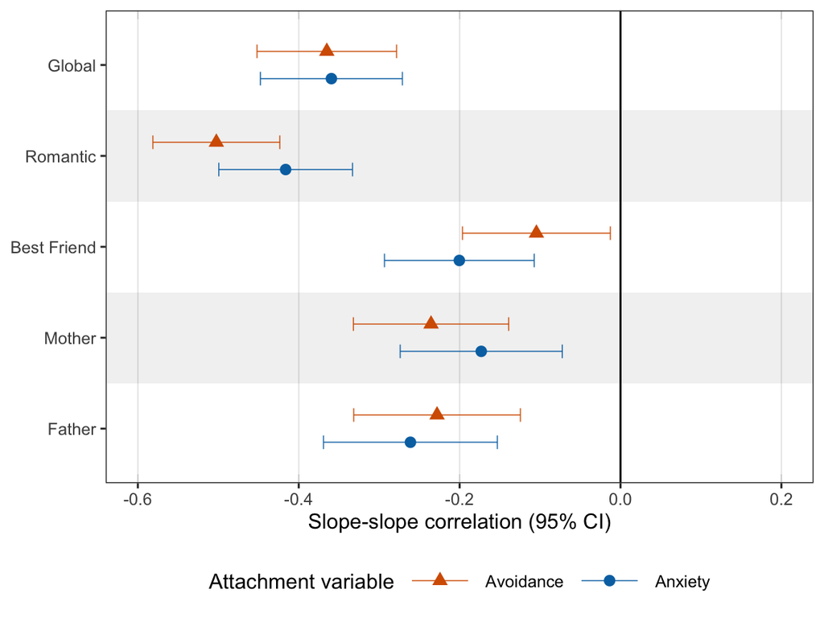

```r
plot_rq3_css_partn_c
```

Significant, negative slope-slope correlations in all attachment domains. Strongest for romantic and global attachment.

#### 5.2.5.2 Intermittently partnered

Create and save plot:

```r
# Plot standardized slope-slope correlations -> Intermittently partnered
plot_rq3_css_partn_i <- ggplot(rq3_extracted_cross_partn_i %>% filter(term=="css"),
                               aes(x = est, y = forcats::fct_rev(domain_fct),
                                   colour = forcats::fct_rev(pred_fct),
                                   shape = forcats::fct_rev(pred_fct))) +
  geom_rect(data = bg_df_rq3,
            aes(xmin = -Inf, xmax = Inf, ymin = ymin, ymax = ymax, fill = NULL),
            inherit.aes = FALSE,
            fill = bg_df_rq3$fill,
            alpha = 0.5) +
  geom_vline(xintercept = 0, colour = "black") +
  geom_point(size = 2.5, position = position_dodge(width = 0.6)) +
  geom_errorbarh(aes(xmin = ci_lo, xmax = ci_hi),
                 height = 0.3, position = position_dodge(width = 0.6),
                 linewidth = 0.3, alpha = 0.85) +
  scale_colour_manual(values = c("Avoidance" = "#D55E00", "Anxiety" = "#0072B2"),
                      breaks = c("Avoidance", "Anxiety")) +
  scale_shape_manual(values = c("Avoidance" = 17, "Anxiety" = 16),
                     breaks = c("Avoidance", "Anxiety")) +
  scale_x_continuous(limits = c(-0.60, 0.20),
                     breaks = seq(-0.60, 0.20, by = 0.20),
                     labels = scales::label_number(accuracy = 0.1),
                     oob = scales::oob_keep) +
  labs(x = "Slope-slope correlation (95% CI)",
       y = NULL, colour = NULL, shape = NULL) +
  theme_bw() +
  theme(legend.position = "bottom",
        legend.key.width = unit(1.3, "cm"),
        panel.grid.major.y = element_blank(), panel.grid.minor.y = element_blank(),
        panel.grid.major.x = element_line(color = "grey80", linewidth = 0.3), panel.grid.minor.x = element_blank()) +
  guides(colour = guide_legend(title = "Attachment variable"),
         shape = guide_legend(title = "Attachment variable"))

# save as pdf
pdf(width = 6, height = 4.5, "figures/rq3_plot_css_partn_i.pdf")
plot_rq3_css_partn_i
```

```
`height` was translated to `width`.
```

```r
dev.off()
```

Show plot:

```
`height` was translated to `width`.
```

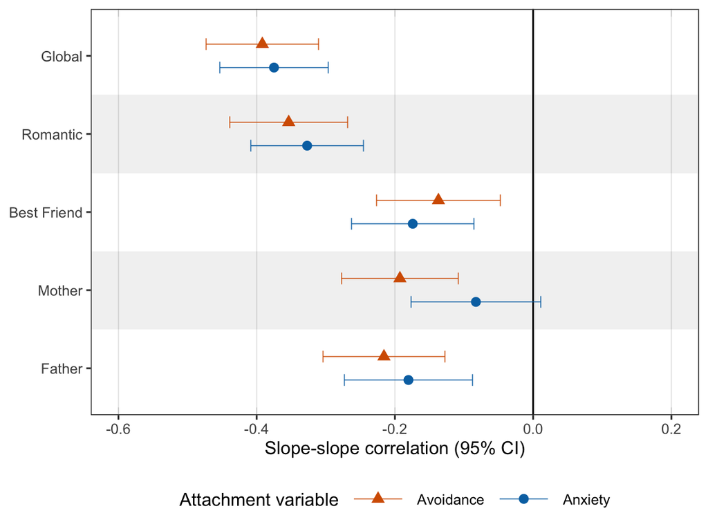

```r
plot_rq3_css_partn_i
```

Significant, negative slope-slope correlations in all attachment domains, except for mother-specific anxiety. Strongest correlations for romantic and global attachment. However, the romantic slope-slope correlations are slightly less pronounced than in the consistently partnered group.

#### 5.2.5.3 All three groups together!

Create and save plot:

```r
# joint df of all groups
rq3_extracted_cross_all <- bind_rows(
  rq3_extracted_cross %>% mutate(group = "Consistently single"),
  rq3_extracted_cross_partn_c %>% mutate(group = "Consistently partnered"),
  rq3_extracted_cross_partn_i %>% mutate(group = "Intermittently partnered")
) %>%
  mutate(group_fct = factor(group,
                            levels = c("Consistently single", "Consistently partnered", "Intermittently partnered"),
                            ordered = TRUE)) %>% select(-group)

# Define custom group colours
group_colors <- c("Consistently single" = "#008837", "Consistently partnered" = "#A23E48",
                  "Intermittently partnered" = "#6A3D9A")

# Plot standardized slope-slope correlations across groups
plot_rq3_css_all <- ggplot(rq3_extracted_cross_all %>% filter(term=="css"),
                           aes(x = est, y = forcats::fct_rev(group_fct),
                               colour = forcats::fct_rev(group_fct),
                               shape = forcats::fct_rev(group_fct))) +
  geom_vline(xintercept = 0, colour = "black") +
  geom_point(size = 2.5) +
  geom_errorbarh(aes(xmin = ci_lo, xmax = ci_hi), height = 0.3, linewidth = 0.3, alpha = 0.85) +
  scale_colour_manual(values = group_colors, breaks = c("Consistently single", "Consistently partnered", "Intermittently partnered")) +
  scale_shape_manual(values = c("Consistently single" = 16, "Consistently partnered" = 17, "Intermittently partnered" = 15), breaks = c("Consistently single", "Consistently partnered", "Intermittently partnered")) +
  scale_x_continuous(limits = c(-0.60, 0.20), breaks = seq(-0.60, 0.20, by = 0.20), labels = scales::label_number(accuracy = 0.1), oob = scales::oob_keep) +
  facet_wrap(~ outc_fct, ncol = 2, nrow = 5, dir = "v") +
  labs(x = "Slope-slope correlation (95% CI)", y = NULL, colour = NULL, shape = NULL) +
  guides(colour = guide_legend(title = "Group", override.aes = list(shape = c(16, 17, 15))), shape = "none") +
  theme_bw() +
  theme(strip.text = element_text(size = 10), strip.background = element_rect(fill = "grey95"),
        legend.position = "bottom", legend.key.width = unit(1.3, "cm"),
        panel.grid.major.y = element_blank(), panel.grid.minor.y = element_blank(),
        panel.grid.major.x = element_line(color = "grey80", linewidth = 0.3), panel.grid.minor.x = element_blank(),
        axis.text.y = element_blank(), axis.ticks.y = element_blank())

# save as pdf
pdf(width = 6, height = 7, "figures/rq3_plot_css_all.pdf")
plot_rq3_css_all
```

```
`height` was translated to `width`.
```

```r
dev.off()
```

Show plot:

```
`height` was translated to `width`.
```

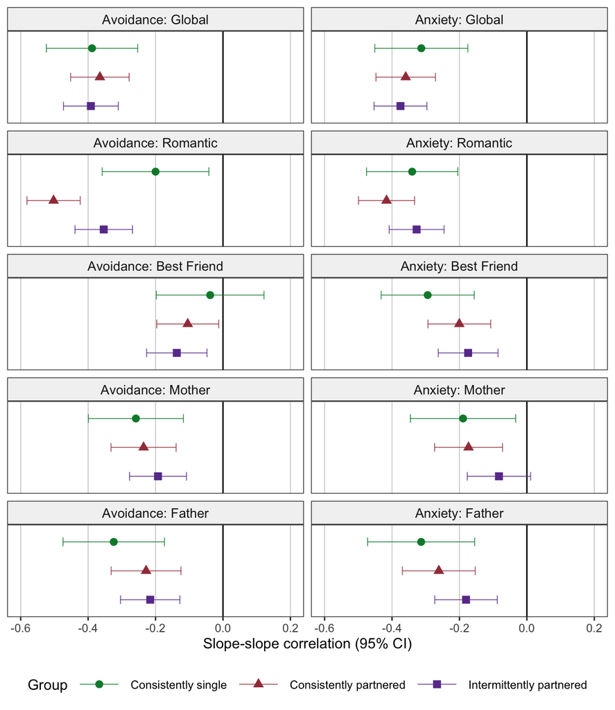

```r
plot_rq3_css_all
```

Global attachment has relatively similar co-development across groups. However, in the specific domains some important differences emerge: romantic avoidance is much more relevant for the partnered groups than the singles. Also, some more subtle differences for best-friend attachment and mother/father.

### 5.2.6 Full model results

#### 5.2.6.1 Consistently partnered

##### 5.2.6.1.1 Avoidance: Global

Full model results for avoidance (global) (in the consistently partnered people):

```r
broom::tidy(get(paste0("fit_rq3_", outcomes$short[1], "_partn_c")), conf.int = TRUE, conf.level = 0.95) %>%
  filter(label != "") %>%
  arrange(label) %>%
  select(term = label, est = estimate, ci_lo = conf.low, ci_hi = conf.high, p_value = p.value, est_std = std.all) %>%
  knitr::kable(digits = 3)
```

| term | est | ci_lo | ci_hi | p_value | est_std |
| --- | --- | --- | --- | --- | --- |
| a0 | 2.639 | 2.600 | 2.677 | 0.000 | 3.633 |
| a1 | -0.241 | -0.292 | -0.190 | 0.000 | -0.337 |
| bia | -0.005 | -0.042 | 0.032 | 0.795 | -0.007 |
| biw | -0.034 | -0.073 | 0.005 | 0.090 | -0.045 |
| bsa | 0.002 | -0.046 | 0.051 | 0.927 | 0.003 |
| bsw | -0.051 | -0.102 | 0.001 | 0.054 | -0.068 |
| cii | -0.213 | -0.245 | -0.182 | 0.000 | -0.386 |
| cis_aw | 0.024 | -0.016 | 0.064 | 0.241 | 0.044 |
| cis_wa | -0.045 | -0.085 | -0.006 | 0.026 | -0.083 |
| cisa | -0.120 | -0.160 | -0.081 | 0.000 | -0.232 |
| cisw | -0.034 | -0.077 | 0.009 | 0.117 | -0.061 |
| css | -0.193 | -0.248 | -0.138 | 0.000 | -0.365 |
| ra00 | 0.194 | 0.178 | 0.211 | 0.000 | 0.269 |
| ra01 | 0.165 | 0.145 | 0.184 | 0.000 | 0.240 |
| ra02 | 0.125 | 0.111 | 0.139 | 0.000 | 0.196 |
| ra03 | 0.127 | 0.112 | 0.141 | 0.000 | 0.200 |
| ra04 | 0.115 | 0.101 | 0.129 | 0.000 | 0.186 |
| ra05 | 0.130 | 0.114 | 0.145 | 0.000 | 0.206 |
| ra06 | 0.149 | 0.131 | 0.167 | 0.000 | 0.229 |
| ra07 | 0.121 | 0.107 | 0.136 | 0.000 | 0.196 |
| ra08 | 0.124 | 0.109 | 0.138 | 0.000 | 0.198 |
| ra09 | 0.119 | 0.105 | 0.133 | 0.000 | 0.192 |
| ra10 | 0.102 | 0.090 | 0.115 | 0.000 | 0.168 |
| ra11 | 0.121 | 0.106 | 0.135 | 0.000 | 0.191 |
| ra12 | 0.107 | 0.094 | 0.120 | 0.000 | 0.172 |
| ra13 | 0.111 | 0.096 | 0.125 | 0.000 | 0.175 |
| ra14 | 0.114 | 0.098 | 0.129 | 0.000 | 0.177 |
| ra15 | 0.100 | 0.085 | 0.115 | 0.000 | 0.156 |
| ra16 | 0.112 | 0.094 | 0.129 | 0.000 | 0.169 |
| ra17 | 0.108 | 0.090 | 0.125 | 0.000 | 0.161 |

[output cut: 78 more lines]

##### 5.2.6.1.2 Avoidance: Romantic

Full model results for avoidance (romantic) (in the consistently partnered people):

```r
broom::tidy(get(paste0("fit_rq3_", outcomes$short[2], "_partn_c")), conf.int = TRUE, conf.level = 0.95) %>%
  filter(label != "") %>%
  arrange(label) %>%
  select(term = label, est = estimate, ci_lo = conf.low, ci_hi = conf.high, p_value = p.value, est_std = std.all) %>%
  knitr::kable(digits = 3)
```

| term | est | ci_lo | ci_hi | p_value | est_std |
| --- | --- | --- | --- | --- | --- |
| a0 | 1.937 | 1.900 | 1.974 | 0.000 | 2.671 |
| a1 | -0.121 | -0.174 | -0.069 | 0.000 | -0.167 |
| bia | 0.183 | 0.147 | 0.220 | 0.000 | 0.253 |
| biw | -0.034 | -0.073 | 0.005 | 0.090 | -0.045 |
| bsa | 0.021 | -0.029 | 0.070 | 0.408 | 0.029 |
| bsw | -0.050 | -0.101 | 0.002 | 0.059 | -0.067 |
| cii | -0.262 | -0.295 | -0.230 | 0.000 | -0.491 |
| cis_aw | 0.001 | -0.037 | 0.039 | 0.953 | 0.002 |
| cis_wa | 0.013 | -0.027 | 0.054 | 0.526 | 0.024 |
| cisa | -0.124 | -0.162 | -0.085 | 0.000 | -0.243 |
| cisw | -0.034 | -0.076 | 0.009 | 0.124 | -0.060 |
| css | -0.270 | -0.329 | -0.211 | 0.000 | -0.502 |
| ra00 | 0.211 | 0.193 | 0.229 | 0.000 | 0.286 |
| ra01 | 0.147 | 0.129 | 0.165 | 0.000 | 0.221 |
| ra02 | 0.147 | 0.130 | 0.163 | 0.000 | 0.223 |
| ra03 | 0.130 | 0.115 | 0.145 | 0.000 | 0.204 |
| ra04 | 0.135 | 0.119 | 0.151 | 0.000 | 0.212 |
| ra05 | 0.138 | 0.121 | 0.154 | 0.000 | 0.216 |
| ra06 | 0.149 | 0.130 | 0.167 | 0.000 | 0.229 |
| ra07 | 0.119 | 0.105 | 0.132 | 0.000 | 0.192 |
| ra08 | 0.127 | 0.112 | 0.142 | 0.000 | 0.202 |
| ra09 | 0.129 | 0.113 | 0.144 | 0.000 | 0.204 |
| ra10 | 0.112 | 0.098 | 0.125 | 0.000 | 0.181 |
| ra11 | 0.112 | 0.099 | 0.126 | 0.000 | 0.180 |
| ra12 | 0.134 | 0.118 | 0.150 | 0.000 | 0.206 |
| ra13 | 0.097 | 0.084 | 0.109 | 0.000 | 0.156 |
| ra14 | 0.124 | 0.107 | 0.141 | 0.000 | 0.189 |
| ra15 | 0.103 | 0.087 | 0.119 | 0.000 | 0.160 |
| ra16 | 0.123 | 0.104 | 0.143 | 0.000 | 0.182 |
| ra17 | 0.152 | 0.127 | 0.176 | 0.000 | 0.211 |

[output cut: 78 more lines]

##### 5.2.6.1.3 Avoidance: Best Friend

Full model results for avoidance (best friend) (in the consistently partnered people):

```r
broom::tidy(get(paste0("fit_rq3_", outcomes$short[3], "_partn_c")), conf.int = TRUE, conf.level = 0.95) %>%
  filter(label != "") %>%
  arrange(label) %>%
  select(term = label, est = estimate, ci_lo = conf.low, ci_hi = conf.high, p_value = p.value, est_std = std.all) %>%
  knitr::kable(digits = 3)
```

| term | est | ci_lo | ci_hi | p_value | est_std |
| --- | --- | --- | --- | --- | --- |
| a0 | 2.124 | 2.087 | 2.160 | 0.000 | 3.101 |
| a1 | 0.341 | 0.272 | 0.410 | 0.000 | 0.322 |
| bia | 0.014 | -0.022 | 0.050 | 0.448 | 0.020 |
| biw | -0.034 | -0.073 | 0.005 | 0.088 | -0.045 |
| bsa | -0.059 | -0.124 | 0.006 | 0.078 | -0.056 |
| bsw | -0.051 | -0.102 | 0.001 | 0.053 | -0.069 |
| cii | -0.124 | -0.153 | -0.095 | 0.000 | -0.238 |
| cis_aw | -0.006 | -0.044 | 0.032 | 0.756 | -0.012 |
| cis_wa | -0.067 | -0.120 | -0.014 | 0.014 | -0.083 |
| cisa | -0.181 | -0.231 | -0.130 | 0.000 | -0.249 |
| cisw | -0.033 | -0.076 | 0.010 | 0.128 | -0.059 |
| css | -0.081 | -0.154 | -0.009 | 0.028 | -0.105 |
| ra00 | 0.236 | 0.216 | 0.257 | 0.000 | 0.335 |
| ra01 | 0.132 | 0.115 | 0.148 | 0.000 | 0.223 |
| ra02 | 0.120 | 0.106 | 0.134 | 0.000 | 0.211 |
| ra03 | 0.127 | 0.112 | 0.142 | 0.000 | 0.222 |
| ra04 | 0.134 | 0.118 | 0.150 | 0.000 | 0.233 |
| ra05 | 0.164 | 0.145 | 0.184 | 0.000 | 0.272 |
| ra06 | 0.170 | 0.149 | 0.191 | 0.000 | 0.278 |
| ra07 | 0.162 | 0.144 | 0.181 | 0.000 | 0.267 |
| ra08 | 0.129 | 0.114 | 0.145 | 0.000 | 0.222 |
| ra09 | 0.122 | 0.107 | 0.137 | 0.000 | 0.208 |
| ra10 | 0.144 | 0.127 | 0.162 | 0.000 | 0.232 |
| ra11 | 0.130 | 0.114 | 0.146 | 0.000 | 0.208 |
| ra12 | 0.131 | 0.115 | 0.147 | 0.000 | 0.204 |
| ra13 | 0.131 | 0.113 | 0.148 | 0.000 | 0.197 |
| ra14 | 0.145 | 0.125 | 0.166 | 0.000 | 0.207 |
| ra15 | 0.144 | 0.122 | 0.166 | 0.000 | 0.198 |
| ra16 | 0.169 | 0.143 | 0.196 | 0.000 | 0.217 |
| ra17 | 0.187 | 0.157 | 0.218 | 0.000 | 0.226 |

[output cut: 78 more lines]

##### 5.2.6.1.4 Avoidance: Mother

Full model results for avoidance (mother) (in the consistently partnered people):

```r
broom::tidy(get(paste0("fit_rq3_", outcomes$short[4], "_partn_c")), conf.int = TRUE, conf.level = 0.95) %>%
  filter(label != "") %>%
  arrange(label) %>%
  select(term = label, est = estimate, ci_lo = conf.low, ci_hi = conf.high, p_value = p.value, est_std = std.all) %>%
  knitr::kable(digits = 3)
```

| term | est | ci_lo | ci_hi | p_value | est_std |
| --- | --- | --- | --- | --- | --- |
| a0 | 3.030 | 2.969 | 3.090 | 0.000 | 2.684 |
| a1 | -0.199 | -0.264 | -0.134 | 0.000 | -0.213 |
| bia | 0.193 | 0.122 | 0.264 | 0.000 | 0.145 |
| biw | -0.063 | -0.114 | -0.013 | 0.013 | -0.070 |
| bsa | 0.030 | -0.045 | 0.106 | 0.431 | 0.028 |
| bsw | -0.073 | -0.140 | -0.007 | 0.031 | -0.083 |
| cii | -0.226 | -0.276 | -0.176 | 0.000 | -0.265 |
| cis_aw | 0.063 | -0.003 | 0.128 | 0.061 | 0.075 |
| cis_wa | 0.037 | -0.015 | 0.089 | 0.162 | 0.052 |
| cisa | -0.263 | -0.340 | -0.186 | 0.000 | -0.252 |
| cisw | -0.038 | -0.085 | 0.008 | 0.108 | -0.067 |
| css | -0.164 | -0.236 | -0.092 | 0.000 | -0.236 |
| ra00 | 0.212 | 0.192 | 0.232 | 0.000 | 0.143 |
| ra01 | 0.153 | 0.133 | 0.174 | 0.000 | 0.109 |
| ra02 | 0.126 | 0.110 | 0.142 | 0.000 | 0.092 |
| ra03 | 0.141 | 0.124 | 0.159 | 0.000 | 0.103 |
| ra04 | 0.125 | 0.109 | 0.141 | 0.000 | 0.093 |
| ra05 | 0.122 | 0.106 | 0.139 | 0.000 | 0.092 |
| ra06 | 0.145 | 0.125 | 0.164 | 0.000 | 0.107 |
| ra07 | 0.104 | 0.091 | 0.118 | 0.000 | 0.080 |
| ra08 | 0.133 | 0.115 | 0.150 | 0.000 | 0.100 |
| ra09 | 0.128 | 0.111 | 0.144 | 0.000 | 0.096 |
| ra10 | 0.122 | 0.106 | 0.138 | 0.000 | 0.092 |
| ra11 | 0.111 | 0.096 | 0.126 | 0.000 | 0.084 |
| ra12 | 0.101 | 0.088 | 0.114 | 0.000 | 0.077 |
| ra13 | 0.124 | 0.106 | 0.141 | 0.000 | 0.092 |
| ra14 | 0.132 | 0.112 | 0.151 | 0.000 | 0.097 |
| ra15 | 0.107 | 0.090 | 0.125 | 0.000 | 0.080 |
| ra16 | 0.132 | 0.110 | 0.155 | 0.000 | 0.096 |
| ra17 | 0.099 | 0.082 | 0.117 | 0.000 | 0.073 |

[output cut: 78 more lines]

##### 5.2.6.1.5 Avoidance: Father

Full model results for avoidance (father) (in the consistently partnered people):

```r
broom::tidy(get(paste0("fit_rq3_", outcomes$short[5], "_partn_c")), conf.int = TRUE, conf.level = 0.95) %>%
  filter(label != "") %>%
  arrange(label) %>%
  select(term = label, est = estimate, ci_lo = conf.low, ci_hi = conf.high, p_value = p.value, est_std = std.all) %>%
  knitr::kable(digits = 3)
```

| term | est | ci_lo | ci_hi | p_value | est_std |
| --- | --- | --- | --- | --- | --- |
| a0 | 3.248 | 3.187 | 3.309 | 0.000 | 3.029 |
| a1 | -0.232 | -0.300 | -0.163 | 0.000 | -0.251 |
| bia | 0.106 | 0.028 | 0.184 | 0.008 | 0.077 |
| biw | -0.085 | -0.141 | -0.028 | 0.003 | -0.087 |
| bsa | 0.111 | 0.023 | 0.199 | 0.013 | 0.094 |
| bsw | -0.063 | -0.141 | 0.016 | 0.116 | -0.066 |
| cii | -0.235 | -0.286 | -0.185 | 0.000 | -0.291 |
| cis_aw | 0.088 | 0.022 | 0.154 | 0.009 | 0.111 |
| cis_wa | 0.026 | -0.028 | 0.080 | 0.344 | 0.037 |
| cisa | -0.206 | -0.283 | -0.129 | 0.000 | -0.210 |
| cisw | -0.028 | -0.076 | 0.020 | 0.256 | -0.050 |
| css | -0.155 | -0.229 | -0.081 | 0.000 | -0.228 |
| ra00 | 0.228 | 0.205 | 0.250 | 0.000 | 0.165 |
| ra01 | 0.162 | 0.140 | 0.184 | 0.000 | 0.125 |
| ra02 | 0.135 | 0.118 | 0.153 | 0.000 | 0.107 |
| ra03 | 0.152 | 0.132 | 0.172 | 0.000 | 0.120 |
| ra04 | 0.107 | 0.092 | 0.122 | 0.000 | 0.088 |
| ra05 | 0.133 | 0.115 | 0.151 | 0.000 | 0.107 |
| ra06 | 0.162 | 0.139 | 0.185 | 0.000 | 0.128 |
| ra07 | 0.112 | 0.097 | 0.127 | 0.000 | 0.092 |
| ra08 | 0.111 | 0.095 | 0.127 | 0.000 | 0.091 |
| ra09 | 0.103 | 0.088 | 0.117 | 0.000 | 0.085 |
| ra10 | 0.109 | 0.094 | 0.124 | 0.000 | 0.089 |
| ra11 | 0.113 | 0.097 | 0.129 | 0.000 | 0.092 |
| ra12 | 0.117 | 0.101 | 0.134 | 0.000 | 0.094 |
| ra13 | 0.101 | 0.085 | 0.117 | 0.000 | 0.081 |
| ra14 | 0.135 | 0.114 | 0.156 | 0.000 | 0.105 |
| ra15 | 0.120 | 0.100 | 0.141 | 0.000 | 0.093 |
| ra16 | 0.124 | 0.101 | 0.146 | 0.000 | 0.094 |
| ra17 | 0.096 | 0.076 | 0.115 | 0.000 | 0.073 |

[output cut: 78 more lines]

##### 5.2.6.1.6 Anxiety: Global

Full model results for anxiety (global) (in the consistently partnered people):

```r
broom::tidy(get(paste0("fit_rq3_", outcomes$short[6], "_partn_c")), conf.int = TRUE, conf.level = 0.95) %>%
  filter(label != "") %>%
  arrange(label) %>%
  select(term = label, est = estimate, ci_lo = conf.low, ci_hi = conf.high, p_value = p.value, est_std = std.all) %>%
  knitr::kable(digits = 3)
```

| term | est | ci_lo | ci_hi | p_value | est_std |
| --- | --- | --- | --- | --- | --- |
| a0 | 3.069 | 3.018 | 3.119 | 0.000 | 3.217 |
| a1 | -0.985 | -1.060 | -0.909 | 0.000 | -0.956 |
| bia | -0.159 | -0.208 | -0.110 | 0.000 | -0.167 |
| biw | -0.035 | -0.074 | 0.005 | 0.084 | -0.045 |
| bsa | 0.106 | 0.036 | 0.177 | 0.003 | 0.103 |
| bsw | -0.049 | -0.101 | 0.002 | 0.060 | -0.067 |
| cii | -0.313 | -0.356 | -0.270 | 0.000 | -0.436 |
| cis_aw | 0.086 | 0.033 | 0.139 | 0.002 | 0.124 |
| cis_wa | -0.012 | -0.070 | 0.046 | 0.679 | -0.016 |
| cisa | -0.291 | -0.368 | -0.214 | 0.000 | -0.302 |
| cisw | -0.038 | -0.081 | 0.005 | 0.085 | -0.067 |
| css | -0.272 | -0.352 | -0.192 | 0.000 | -0.359 |
| ra00 | 0.456 | 0.417 | 0.495 | 0.000 | 0.334 |
| ra01 | 0.373 | 0.329 | 0.417 | 0.000 | 0.295 |
| ra02 | 0.290 | 0.257 | 0.324 | 0.000 | 0.250 |
| ra03 | 0.303 | 0.268 | 0.337 | 0.000 | 0.261 |
| ra04 | 0.289 | 0.255 | 0.324 | 0.000 | 0.255 |
| ra05 | 0.292 | 0.258 | 0.327 | 0.000 | 0.259 |
| ra06 | 0.292 | 0.256 | 0.328 | 0.000 | 0.261 |
| ra07 | 0.278 | 0.246 | 0.310 | 0.000 | 0.253 |
| ra08 | 0.272 | 0.239 | 0.304 | 0.000 | 0.249 |
| ra09 | 0.243 | 0.213 | 0.272 | 0.000 | 0.228 |
| ra10 | 0.260 | 0.229 | 0.291 | 0.000 | 0.240 |
| ra11 | 0.271 | 0.239 | 0.303 | 0.000 | 0.246 |
| ra12 | 0.240 | 0.211 | 0.269 | 0.000 | 0.223 |
| ra13 | 0.247 | 0.215 | 0.278 | 0.000 | 0.225 |
| ra14 | 0.242 | 0.209 | 0.276 | 0.000 | 0.220 |
| ra15 | 0.221 | 0.188 | 0.254 | 0.000 | 0.202 |
| ra16 | 0.186 | 0.156 | 0.216 | 0.000 | 0.172 |
| ra17 | 0.234 | 0.196 | 0.273 | 0.000 | 0.204 |

[output cut: 78 more lines]

##### 5.2.6.1.7 Anxiety: Romantic

Full model results for anxiety (romantic) (in the consistently partnered people):

```r
broom::tidy(get(paste0("fit_rq3_", outcomes$short[7], "_partn_c")), conf.int = TRUE, conf.level = 0.95) %>%
  filter(label != "") %>%
  arrange(label) %>%
  select(term = label, est = estimate, ci_lo = conf.low, ci_hi = conf.high, p_value = p.value, est_std = std.all) %>%
  knitr::kable(digits = 3)
```

| term | est | ci_lo | ci_hi | p_value | est_std |
| --- | --- | --- | --- | --- | --- |
| a0 | 2.378 | 2.325 | 2.431 | 0.000 | 2.381 |
| a1 | -0.674 | -0.752 | -0.596 | 0.000 | -0.602 |
| bia | -0.031 | -0.083 | 0.021 | 0.247 | -0.031 |
| biw | -0.035 | -0.074 | 0.005 | 0.085 | -0.045 |
| bsa | 0.101 | 0.028 | 0.175 | 0.007 | 0.090 |
| bsw | -0.051 | -0.102 | 0.001 | 0.054 | -0.068 |
| cii | -0.329 | -0.374 | -0.284 | 0.000 | -0.432 |
| cis_aw | 0.058 | 0.001 | 0.114 | 0.047 | 0.078 |
| cis_wa | 0.064 | 0.003 | 0.124 | 0.038 | 0.075 |
| cisa | -0.522 | -0.612 | -0.433 | 0.000 | -0.469 |
| cisw | -0.036 | -0.079 | 0.006 | 0.096 | -0.064 |
| css | -0.344 | -0.432 | -0.257 | 0.000 | -0.416 |
| ra00 | 0.519 | 0.476 | 0.563 | 0.000 | 0.342 |
| ra01 | 0.371 | 0.327 | 0.416 | 0.000 | 0.278 |
| ra02 | 0.280 | 0.248 | 0.312 | 0.000 | 0.231 |
| ra03 | 0.303 | 0.268 | 0.339 | 0.000 | 0.252 |
| ra04 | 0.250 | 0.219 | 0.280 | 0.000 | 0.222 |
| ra05 | 0.280 | 0.247 | 0.313 | 0.000 | 0.247 |
| ra06 | 0.281 | 0.246 | 0.315 | 0.000 | 0.252 |
| ra07 | 0.226 | 0.199 | 0.253 | 0.000 | 0.217 |
| ra08 | 0.232 | 0.204 | 0.260 | 0.000 | 0.224 |
| ra09 | 0.235 | 0.207 | 0.263 | 0.000 | 0.229 |
| ra10 | 0.232 | 0.203 | 0.260 | 0.000 | 0.228 |
| ra11 | 0.214 | 0.188 | 0.240 | 0.000 | 0.215 |
| ra12 | 0.221 | 0.194 | 0.248 | 0.000 | 0.221 |
| ra13 | 0.227 | 0.198 | 0.257 | 0.000 | 0.226 |
| ra14 | 0.241 | 0.208 | 0.274 | 0.000 | 0.235 |
| ra15 | 0.202 | 0.171 | 0.232 | 0.000 | 0.204 |
| ra16 | 0.192 | 0.161 | 0.223 | 0.000 | 0.193 |
| ra17 | 0.231 | 0.193 | 0.270 | 0.000 | 0.222 |

[output cut: 78 more lines]

##### 5.2.6.1.8 Anxiety: Best Friend

Full model results for anxiety (best friend) (in the consistently partnered people):

```r
broom::tidy(get(paste0("fit_rq3_", outcomes$short[8], "_partn_c")), conf.int = TRUE, conf.level = 0.95) %>%
  filter(label != "") %>%
  arrange(label) %>%
  select(term = label, est = estimate, ci_lo = conf.low, ci_hi = conf.high, p_value = p.value, est_std = std.all) %>%
  knitr::kable(digits = 3)
```

| term | est | ci_lo | ci_hi | p_value | est_std |
| --- | --- | --- | --- | --- | --- |
| a0 | 2.033 | 1.989 | 2.076 | 0.000 | 2.484 |
| a1 | -0.031 | -0.106 | 0.044 | 0.416 | -0.028 |
| bia | -0.045 | -0.088 | -0.003 | 0.038 | -0.055 |
| biw | -0.034 | -0.073 | 0.005 | 0.091 | -0.044 |
| bsa | -0.015 | -0.086 | 0.057 | 0.684 | -0.013 |
| bsw | -0.052 | -0.103 | -0.001 | 0.047 | -0.071 |
| cii | -0.181 | -0.217 | -0.146 | 0.000 | -0.291 |
| cis_aw | 0.052 | 0.007 | 0.097 | 0.024 | 0.087 |
| cis_wa | -0.050 | -0.109 | 0.008 | 0.092 | -0.059 |
| cisa | -0.345 | -0.413 | -0.276 | 0.000 | -0.377 |
| cisw | -0.035 | -0.077 | 0.008 | 0.111 | -0.062 |
| css | -0.165 | -0.246 | -0.084 | 0.000 | -0.200 |
| ra00 | 0.343 | 0.314 | 0.373 | 0.000 | 0.339 |
| ra01 | 0.220 | 0.193 | 0.247 | 0.000 | 0.254 |
| ra02 | 0.225 | 0.199 | 0.250 | 0.000 | 0.263 |
| ra03 | 0.228 | 0.202 | 0.255 | 0.000 | 0.272 |
| ra04 | 0.208 | 0.183 | 0.233 | 0.000 | 0.258 |
| ra05 | 0.233 | 0.206 | 0.261 | 0.000 | 0.284 |
| ra06 | 0.226 | 0.198 | 0.254 | 0.000 | 0.280 |
| ra07 | 0.203 | 0.179 | 0.226 | 0.000 | 0.260 |
| ra08 | 0.197 | 0.173 | 0.222 | 0.000 | 0.255 |
| ra09 | 0.202 | 0.177 | 0.226 | 0.000 | 0.259 |
| ra10 | 0.190 | 0.166 | 0.213 | 0.000 | 0.246 |
| ra11 | 0.181 | 0.159 | 0.204 | 0.000 | 0.235 |
| ra12 | 0.175 | 0.153 | 0.196 | 0.000 | 0.226 |
| ra13 | 0.233 | 0.203 | 0.262 | 0.000 | 0.275 |
| ra14 | 0.198 | 0.170 | 0.226 | 0.000 | 0.239 |
| ra15 | 0.183 | 0.155 | 0.211 | 0.000 | 0.220 |
| ra16 | 0.179 | 0.150 | 0.208 | 0.000 | 0.210 |
| ra17 | 0.233 | 0.195 | 0.271 | 0.000 | 0.250 |

[output cut: 78 more lines]

##### 5.2.6.1.9 Anxiety: Mother

Full model results for anxiety (mother) (in the consistently partnered people):

```r
broom::tidy(get(paste0("fit_rq3_", outcomes$short[9], "_partn_c")), conf.int = TRUE, conf.level = 0.95) %>%
  filter(label != "") %>%
  arrange(label) %>%
  select(term = label, est = estimate, ci_lo = conf.low, ci_hi = conf.high, p_value = p.value, est_std = std.all) %>%
  knitr::kable(digits = 3)
```

| term | est | ci_lo | ci_hi | p_value | est_std |
| --- | --- | --- | --- | --- | --- |
| a0 | 1.899 | 1.846 | 1.952 | 0.000 | 1.961 |
| a1 | -0.288 | -0.354 | -0.221 | 0.000 | -0.310 |
| bia | 0.103 | 0.041 | 0.166 | 0.001 | 0.091 |
| biw | -0.063 | -0.113 | -0.012 | 0.014 | -0.069 |
| bsa | -0.090 | -0.168 | -0.013 | 0.023 | -0.082 |
| bsw | -0.075 | -0.141 | -0.008 | 0.028 | -0.085 |
| cii | -0.187 | -0.231 | -0.143 | 0.000 | -0.254 |
| cis_aw | 0.090 | 0.029 | 0.150 | 0.004 | 0.124 |
| cis_wa | 0.030 | -0.024 | 0.083 | 0.277 | 0.042 |
| cisa | -0.455 | -0.532 | -0.378 | 0.000 | -0.511 |
| cisw | -0.042 | -0.089 | 0.005 | 0.079 | -0.073 |
| css | -0.120 | -0.192 | -0.047 | 0.001 | -0.173 |
| ra00 | 0.310 | 0.282 | 0.338 | 0.000 | 0.248 |
| ra01 | 0.224 | 0.196 | 0.253 | 0.000 | 0.198 |
| ra02 | 0.175 | 0.153 | 0.196 | 0.000 | 0.166 |
| ra03 | 0.176 | 0.154 | 0.198 | 0.000 | 0.171 |
| ra04 | 0.158 | 0.137 | 0.179 | 0.000 | 0.160 |
| ra05 | 0.148 | 0.129 | 0.168 | 0.000 | 0.156 |
| ra06 | 0.181 | 0.157 | 0.205 | 0.000 | 0.188 |
| ra07 | 0.134 | 0.117 | 0.151 | 0.000 | 0.149 |
| ra08 | 0.177 | 0.154 | 0.200 | 0.000 | 0.192 |
| ra09 | 0.177 | 0.154 | 0.200 | 0.000 | 0.194 |
| ra10 | 0.162 | 0.141 | 0.182 | 0.000 | 0.183 |
| ra11 | 0.157 | 0.137 | 0.177 | 0.000 | 0.181 |
| ra12 | 0.155 | 0.135 | 0.174 | 0.000 | 0.180 |
| ra13 | 0.156 | 0.135 | 0.178 | 0.000 | 0.183 |
| ra14 | 0.163 | 0.139 | 0.186 | 0.000 | 0.190 |
| ra15 | 0.150 | 0.126 | 0.174 | 0.000 | 0.178 |
| ra16 | 0.124 | 0.102 | 0.145 | 0.000 | 0.152 |
| ra17 | 0.129 | 0.106 | 0.153 | 0.000 | 0.158 |

[output cut: 78 more lines]

##### 5.2.6.1.10 Anxiety: Father

Full model results for anxiety (father) (in the consistently partnered people):

```r
broom::tidy(get(paste0("fit_rq3_", outcomes$short[10], "_partn_c")), conf.int = TRUE, conf.level = 0.95) %>%
  filter(label != "") %>%
  arrange(label) %>%
  select(term = label, est = estimate, ci_lo = conf.low, ci_hi = conf.high, p_value = p.value, est_std = std.all) %>%
  knitr::kable(digits = 3)
```

| term | est | ci_lo | ci_hi | p_value | est_std |
| --- | --- | --- | --- | --- | --- |
| a0 | 2.041 | 1.983 | 2.100 | 0.000 | 2.032 |
| a1 | -0.285 | -0.359 | -0.211 | 0.000 | -0.303 |
| bia | 0.150 | 0.076 | 0.224 | 0.000 | 0.117 |
| biw | -0.086 | -0.142 | -0.029 | 0.003 | -0.088 |
| bsa | -0.106 | -0.201 | -0.011 | 0.029 | -0.088 |
| bsw | -0.059 | -0.137 | 0.018 | 0.133 | -0.063 |
| cii | -0.189 | -0.236 | -0.141 | 0.000 | -0.250 |
| cis_aw | 0.081 | 0.018 | 0.143 | 0.012 | 0.110 |
| cis_wa | -0.001 | -0.059 | 0.056 | 0.961 | -0.002 |
| cisa | -0.383 | -0.466 | -0.300 | 0.000 | -0.410 |
| cisw | -0.026 | -0.074 | 0.022 | 0.292 | -0.046 |
| css | -0.180 | -0.260 | -0.100 | 0.000 | -0.261 |
| ra00 | 0.405 | 0.367 | 0.443 | 0.000 | 0.286 |
| ra01 | 0.328 | 0.286 | 0.370 | 0.000 | 0.250 |
| ra02 | 0.233 | 0.203 | 0.262 | 0.000 | 0.195 |
| ra03 | 0.183 | 0.158 | 0.208 | 0.000 | 0.163 |
| ra04 | 0.159 | 0.137 | 0.182 | 0.000 | 0.148 |
| ra05 | 0.197 | 0.170 | 0.224 | 0.000 | 0.180 |
| ra06 | 0.216 | 0.185 | 0.246 | 0.000 | 0.196 |
| ra07 | 0.153 | 0.132 | 0.174 | 0.000 | 0.149 |
| ra08 | 0.156 | 0.134 | 0.179 | 0.000 | 0.154 |
| ra09 | 0.157 | 0.135 | 0.180 | 0.000 | 0.156 |
| ra10 | 0.145 | 0.125 | 0.166 | 0.000 | 0.147 |
| ra11 | 0.145 | 0.125 | 0.166 | 0.000 | 0.148 |
| ra12 | 0.175 | 0.151 | 0.199 | 0.000 | 0.173 |
| ra13 | 0.159 | 0.135 | 0.183 | 0.000 | 0.160 |
| ra14 | 0.170 | 0.143 | 0.197 | 0.000 | 0.169 |
| ra15 | 0.159 | 0.131 | 0.186 | 0.000 | 0.159 |
| ra16 | 0.115 | 0.093 | 0.136 | 0.000 | 0.119 |
| ra17 | 0.127 | 0.102 | 0.151 | 0.000 | 0.129 |

[output cut: 78 more lines]

#### 5.2.6.2 Intermittently partnered

##### 5.2.6.2.1 Avoidance: Global

Full model results for avoidance (global) (in the intermittently partnered people):

```r
broom::tidy(get(paste0("fit_rq3_", outcomes$short[1], "_partn_i")), conf.int = TRUE, conf.level = 0.95) %>%
  filter(label != "") %>%
  arrange(label) %>%
  select(term = label, est = estimate, ci_lo = conf.low, ci_hi = conf.high, p_value = p.value, est_std = std.all) %>%
  knitr::kable(digits = 3)
```

| term | est | ci_lo | ci_hi | p_value | est_std |
| --- | --- | --- | --- | --- | --- |
| a0 | 2.565 | 2.524 | 2.606 | 0.000 | 3.664 |
| a1 | -0.234 | -0.285 | -0.184 | 0.000 | -0.340 |
| bia | -0.076 | -0.121 | -0.032 | 0.001 | -0.097 |
| biw | -0.062 | -0.112 | -0.012 | 0.015 | -0.070 |
| bsa | 0.021 | -0.033 | 0.076 | 0.445 | 0.027 |
| bsw | 0.020 | -0.048 | 0.088 | 0.563 | 0.020 |
| cii | -0.201 | -0.236 | -0.166 | 0.000 | -0.366 |
| cis_aw | 0.044 | -0.001 | 0.088 | 0.056 | 0.070 |
| cis_wa | -0.022 | -0.063 | 0.018 | 0.281 | -0.041 |
| cisa | -0.157 | -0.196 | -0.119 | 0.000 | -0.328 |
| cisw | -0.120 | -0.173 | -0.068 | 0.000 | -0.171 |
| css | -0.241 | -0.301 | -0.180 | 0.000 | -0.392 |
| ra00 | 0.222 | 0.202 | 0.242 | 0.000 | 0.312 |
| ra01 | 0.161 | 0.141 | 0.182 | 0.000 | 0.252 |
| ra02 | 0.156 | 0.137 | 0.175 | 0.000 | 0.249 |
| ra03 | 0.153 | 0.134 | 0.172 | 0.000 | 0.249 |
| ra04 | 0.137 | 0.119 | 0.154 | 0.000 | 0.231 |
| ra05 | 0.125 | 0.110 | 0.141 | 0.000 | 0.218 |
| ra06 | 0.141 | 0.124 | 0.158 | 0.000 | 0.240 |
| ra07 | 0.136 | 0.120 | 0.152 | 0.000 | 0.236 |
| ra08 | 0.127 | 0.111 | 0.143 | 0.000 | 0.224 |
| ra09 | 0.133 | 0.117 | 0.149 | 0.000 | 0.233 |
| ra10 | 0.146 | 0.129 | 0.163 | 0.000 | 0.250 |
| ra11 | 0.137 | 0.120 | 0.155 | 0.000 | 0.238 |
| ra12 | 0.152 | 0.134 | 0.170 | 0.000 | 0.257 |
| ra13 | 0.143 | 0.125 | 0.160 | 0.000 | 0.243 |
| ra14 | 0.150 | 0.131 | 0.169 | 0.000 | 0.251 |
| ra15 | 0.113 | 0.097 | 0.129 | 0.000 | 0.199 |
| ra16 | 0.121 | 0.103 | 0.138 | 0.000 | 0.208 |
| ra17 | 0.122 | 0.103 | 0.140 | 0.000 | 0.206 |

[output cut: 78 more lines]

##### 5.2.6.2.2 Avoidance: Romantic

Full model results for avoidance (romantic) (in the intermittently partnered people):

```r
broom::tidy(get(paste0("fit_rq3_", outcomes$short[2], "_partn_i")), conf.int = TRUE, conf.level = 0.95) %>%
  filter(label != "") %>%
  arrange(label) %>%
  select(term = label, est = estimate, ci_lo = conf.low, ci_hi = conf.high, p_value = p.value, est_std = std.all) %>%
  knitr::kable(digits = 3)
```

| term | est | ci_lo | ci_hi | p_value | est_std |
| --- | --- | --- | --- | --- | --- |
| a0 | 2.353 | 2.314 | 2.392 | 0.000 | 3.785 |
| a1 | -0.464 | -0.533 | -0.395 | 0.000 | -0.511 |
| bia | 0.093 | 0.051 | 0.135 | 0.000 | 0.133 |
| biw | -0.062 | -0.112 | -0.012 | 0.015 | -0.070 |
| bsa | -0.113 | -0.187 | -0.040 | 0.003 | -0.111 |
| bsw | 0.018 | -0.050 | 0.087 | 0.600 | 0.018 |
| cii | -0.154 | -0.187 | -0.122 | 0.000 | -0.317 |
| cis_aw | 0.033 | -0.010 | 0.075 | 0.135 | 0.059 |
| cis_wa | -0.004 | -0.058 | 0.051 | 0.898 | -0.005 |
| cisa | -0.257 | -0.309 | -0.204 | 0.000 | -0.462 |
| cisw | -0.123 | -0.175 | -0.070 | 0.000 | -0.174 |
| css | -0.285 | -0.365 | -0.204 | 0.000 | -0.354 |
| ra00 | 0.380 | 0.344 | 0.416 | 0.000 | 0.496 |
| ra01 | 0.349 | 0.304 | 0.393 | 0.000 | 0.486 |
| ra02 | 0.371 | 0.327 | 0.415 | 0.000 | 0.512 |
| ra03 | 0.347 | 0.305 | 0.389 | 0.000 | 0.505 |
| ra04 | 0.339 | 0.297 | 0.380 | 0.000 | 0.507 |
| ra05 | 0.380 | 0.336 | 0.425 | 0.000 | 0.544 |
| ra06 | 0.341 | 0.299 | 0.382 | 0.000 | 0.522 |
| ra07 | 0.434 | 0.385 | 0.483 | 0.000 | 0.586 |
| ra08 | 0.369 | 0.324 | 0.414 | 0.000 | 0.549 |
| ra09 | 0.351 | 0.310 | 0.393 | 0.000 | 0.539 |
| ra10 | 0.339 | 0.299 | 0.378 | 0.000 | 0.529 |
| ra11 | 0.301 | 0.263 | 0.339 | 0.000 | 0.498 |
| ra12 | 0.343 | 0.302 | 0.384 | 0.000 | 0.527 |
| ra13 | 0.307 | 0.270 | 0.344 | 0.000 | 0.494 |
| ra14 | 0.345 | 0.301 | 0.388 | 0.000 | 0.517 |
| ra15 | 0.269 | 0.232 | 0.306 | 0.000 | 0.448 |
| ra16 | 0.254 | 0.218 | 0.291 | 0.000 | 0.425 |
| ra17 | 0.294 | 0.250 | 0.338 | 0.000 | 0.451 |

[output cut: 78 more lines]

##### 5.2.6.2.3 Avoidance: Best Friend

Full model results for avoidance (best friend) (in the intermittently partnered people):

```r
broom::tidy(get(paste0("fit_rq3_", outcomes$short[3], "_partn_i")), conf.int = TRUE, conf.level = 0.95) %>%
  filter(label != "") %>%
  arrange(label) %>%
  select(term = label, est = estimate, ci_lo = conf.low, ci_hi = conf.high, p_value = p.value, est_std = std.all) %>%
  knitr::kable(digits = 3)
```

| term | est | ci_lo | ci_hi | p_value | est_std |
| --- | --- | --- | --- | --- | --- |
| a0 | 1.929 | 1.890 | 1.968 | 0.000 | 2.936 |
| a1 | 0.236 | 0.169 | 0.303 | 0.000 | 0.251 |
| bia | -0.064 | -0.107 | -0.022 | 0.003 | -0.087 |
| biw | -0.063 | -0.113 | -0.013 | 0.014 | -0.071 |
| bsa | -0.032 | -0.103 | 0.039 | 0.374 | -0.031 |
| bsw | 0.022 | -0.047 | 0.090 | 0.537 | 0.021 |
| cii | -0.166 | -0.199 | -0.133 | 0.000 | -0.322 |
| cis_aw | 0.032 | -0.011 | 0.074 | 0.149 | 0.054 |
| cis_wa | -0.004 | -0.057 | 0.049 | 0.890 | -0.005 |
| cisa | -0.232 | -0.281 | -0.183 | 0.000 | -0.377 |
| cisw | -0.124 | -0.177 | -0.071 | 0.000 | -0.176 |
| css | -0.115 | -0.192 | -0.039 | 0.003 | -0.137 |
| ra00 | 0.240 | 0.216 | 0.264 | 0.000 | 0.357 |
| ra01 | 0.184 | 0.159 | 0.209 | 0.000 | 0.306 |
| ra02 | 0.167 | 0.146 | 0.189 | 0.000 | 0.293 |
| ra03 | 0.219 | 0.192 | 0.246 | 0.000 | 0.358 |
| ra04 | 0.210 | 0.183 | 0.236 | 0.000 | 0.352 |
| ra05 | 0.221 | 0.195 | 0.248 | 0.000 | 0.369 |
| ra06 | 0.242 | 0.213 | 0.271 | 0.000 | 0.393 |
| ra07 | 0.268 | 0.237 | 0.298 | 0.000 | 0.418 |
| ra08 | 0.242 | 0.212 | 0.271 | 0.000 | 0.394 |
| ra09 | 0.272 | 0.240 | 0.304 | 0.000 | 0.421 |
| ra10 | 0.218 | 0.192 | 0.243 | 0.000 | 0.365 |
| ra11 | 0.228 | 0.199 | 0.257 | 0.000 | 0.373 |
| ra12 | 0.240 | 0.211 | 0.269 | 0.000 | 0.379 |
| ra13 | 0.216 | 0.190 | 0.242 | 0.000 | 0.349 |
| ra14 | 0.217 | 0.188 | 0.245 | 0.000 | 0.343 |
| ra15 | 0.223 | 0.193 | 0.254 | 0.000 | 0.342 |
| ra16 | 0.228 | 0.196 | 0.261 | 0.000 | 0.338 |
| ra17 | 0.187 | 0.159 | 0.216 | 0.000 | 0.287 |

[output cut: 78 more lines]

##### 5.2.6.2.4 Avoidance: Mother

Full model results for avoidance (mother) (in the intermittently partnered people):

```r
broom::tidy(get(paste0("fit_rq3_", outcomes$short[4], "_partn_i")), conf.int = TRUE, conf.level = 0.95) %>%
  filter(label != "") %>%
  arrange(label) %>%
  select(term = label, est = estimate, ci_lo = conf.low, ci_hi = conf.high, p_value = p.value, est_std = std.all) %>%
  knitr::kable(digits = 3)
```

| term | est | ci_lo | ci_hi | p_value | est_std |
| --- | --- | --- | --- | --- | --- |
| a0 | 3.082 | 3.013 | 3.151 | 0.000 | 2.752 |
| a1 | -0.256 | -0.331 | -0.181 | 0.000 | -0.249 |
| bia | 0.123 | 0.044 | 0.203 | 0.002 | 0.089 |
| biw | -0.075 | -0.133 | -0.018 | 0.011 | -0.077 |
| bsa | 0.019 | -0.066 | 0.105 | 0.661 | 0.015 |
| bsw | 0.021 | -0.059 | 0.101 | 0.610 | 0.018 |
| cii | -0.216 | -0.270 | -0.161 | 0.000 | -0.247 |
| cis_aw | 0.068 | -0.006 | 0.141 | 0.073 | 0.067 |
| cis_wa | -0.003 | -0.060 | 0.054 | 0.912 | -0.004 |
| cisa | -0.377 | -0.461 | -0.293 | 0.000 | -0.329 |
| cisw | -0.128 | -0.184 | -0.072 | 0.000 | -0.179 |
| css | -0.180 | -0.263 | -0.097 | 0.000 | -0.193 |
| ra00 | 0.248 | 0.223 | 0.273 | 0.000 | 0.165 |
| ra01 | 0.208 | 0.180 | 0.236 | 0.000 | 0.144 |
| ra02 | 0.161 | 0.140 | 0.183 | 0.000 | 0.118 |
| ra03 | 0.133 | 0.115 | 0.151 | 0.000 | 0.100 |
| ra04 | 0.143 | 0.124 | 0.163 | 0.000 | 0.109 |
| ra05 | 0.148 | 0.129 | 0.167 | 0.000 | 0.113 |
| ra06 | 0.144 | 0.125 | 0.163 | 0.000 | 0.112 |
| ra07 | 0.155 | 0.136 | 0.174 | 0.000 | 0.120 |
| ra08 | 0.157 | 0.137 | 0.177 | 0.000 | 0.122 |
| ra09 | 0.169 | 0.148 | 0.190 | 0.000 | 0.131 |
| ra10 | 0.168 | 0.147 | 0.189 | 0.000 | 0.131 |
| ra11 | 0.163 | 0.141 | 0.184 | 0.000 | 0.127 |
| ra12 | 0.159 | 0.139 | 0.179 | 0.000 | 0.124 |
| ra13 | 0.142 | 0.124 | 0.160 | 0.000 | 0.112 |
| ra14 | 0.161 | 0.140 | 0.183 | 0.000 | 0.124 |
| ra15 | 0.115 | 0.098 | 0.132 | 0.000 | 0.091 |
| ra16 | 0.139 | 0.117 | 0.160 | 0.000 | 0.107 |
| ra17 | 0.114 | 0.095 | 0.133 | 0.000 | 0.088 |

[output cut: 78 more lines]

##### 5.2.6.2.5 Avoidance: Father

Full model results for avoidance (father) (in the intermittently partnered people):

```r
broom::tidy(get(paste0("fit_rq3_", outcomes$short[5], "_partn_i")), conf.int = TRUE, conf.level = 0.95) %>%
  filter(label != "") %>%
  arrange(label) %>%
  select(term = label, est = estimate, ci_lo = conf.low, ci_hi = conf.high, p_value = p.value, est_std = std.all) %>%
  knitr::kable(digits = 3)
```

| term | est | ci_lo | ci_hi | p_value | est_std |
| --- | --- | --- | --- | --- | --- |
| a0 | 3.256 | 3.185 | 3.326 | 0.000 | 3.027 |
| a1 | -0.307 | -0.385 | -0.230 | 0.000 | -0.314 |
| bia | -0.005 | -0.089 | 0.079 | 0.904 | -0.004 |
| biw | -0.121 | -0.184 | -0.057 | 0.000 | -0.115 |
| bsa | -0.057 | -0.147 | 0.034 | 0.221 | -0.044 |
| bsw | 0.029 | -0.058 | 0.117 | 0.511 | 0.025 |
| cii | -0.179 | -0.234 | -0.125 | 0.000 | -0.211 |
| cis_aw | -0.005 | -0.079 | 0.068 | 0.888 | -0.005 |
| cis_wa | -0.006 | -0.063 | 0.051 | 0.845 | -0.007 |
| cisa | -0.290 | -0.369 | -0.210 | 0.000 | -0.275 |
| cisw | -0.131 | -0.188 | -0.074 | 0.000 | -0.183 |
| css | -0.191 | -0.275 | -0.108 | 0.000 | -0.216 |
| ra00 | 0.267 | 0.240 | 0.294 | 0.000 | 0.187 |
| ra01 | 0.153 | 0.131 | 0.176 | 0.000 | 0.119 |
| ra02 | 0.175 | 0.151 | 0.198 | 0.000 | 0.135 |
| ra03 | 0.139 | 0.120 | 0.159 | 0.000 | 0.112 |
| ra04 | 0.119 | 0.102 | 0.136 | 0.000 | 0.098 |
| ra05 | 0.140 | 0.121 | 0.158 | 0.000 | 0.114 |
| ra06 | 0.136 | 0.118 | 0.154 | 0.000 | 0.112 |
| ra07 | 0.139 | 0.121 | 0.157 | 0.000 | 0.114 |
| ra08 | 0.158 | 0.137 | 0.179 | 0.000 | 0.128 |
| ra09 | 0.179 | 0.157 | 0.202 | 0.000 | 0.144 |
| ra10 | 0.152 | 0.132 | 0.172 | 0.000 | 0.125 |
| ra11 | 0.134 | 0.116 | 0.153 | 0.000 | 0.111 |
| ra12 | 0.158 | 0.138 | 0.179 | 0.000 | 0.128 |
| ra13 | 0.125 | 0.108 | 0.141 | 0.000 | 0.103 |
| ra14 | 0.127 | 0.109 | 0.146 | 0.000 | 0.104 |
| ra15 | 0.123 | 0.104 | 0.142 | 0.000 | 0.099 |
| ra16 | 0.115 | 0.096 | 0.134 | 0.000 | 0.092 |
| ra17 | 0.137 | 0.114 | 0.160 | 0.000 | 0.107 |

[output cut: 78 more lines]

##### 5.2.6.2.6 Anxiety: Global

Full model results for anxiety (global) (in the intermittently partnered people):

```r
broom::tidy(get(paste0("fit_rq3_", outcomes$short[6], "_partn_i")), conf.int = TRUE, conf.level = 0.95) %>%
  filter(label != "") %>%
  arrange(label) %>%
  select(term = label, est = estimate, ci_lo = conf.low, ci_hi = conf.high, p_value = p.value, est_std = std.all) %>%
  knitr::kable(digits = 3)
```

| term | est | ci_lo | ci_hi | p_value | est_std |
| --- | --- | --- | --- | --- | --- |
| a0 | 3.218 | 3.163 | 3.273 | 0.000 | 3.488 |
| a1 | -0.905 | -0.988 | -0.823 | 0.000 | -0.793 |
| bia | -0.127 | -0.186 | -0.068 | 0.000 | -0.123 |
| biw | -0.063 | -0.114 | -0.013 | 0.014 | -0.071 |
| bsa | 0.005 | -0.083 | 0.093 | 0.915 | 0.004 |
| bsw | 0.022 | -0.047 | 0.090 | 0.533 | 0.022 |
| cii | -0.344 | -0.392 | -0.295 | 0.000 | -0.475 |
| cis_aw | 0.102 | 0.042 | 0.162 | 0.001 | 0.124 |
| cis_wa | -0.014 | -0.079 | 0.051 | 0.674 | -0.016 |
| cisa | -0.340 | -0.423 | -0.257 | 0.000 | -0.325 |
| cisw | -0.126 | -0.179 | -0.073 | 0.000 | -0.177 |
| css | -0.384 | -0.482 | -0.287 | 0.000 | -0.375 |
| ra00 | 0.537 | 0.488 | 0.587 | 0.000 | 0.387 |
| ra01 | 0.420 | 0.366 | 0.473 | 0.000 | 0.336 |
| ra02 | 0.357 | 0.313 | 0.401 | 0.000 | 0.306 |
| ra03 | 0.335 | 0.293 | 0.377 | 0.000 | 0.296 |
| ra04 | 0.330 | 0.288 | 0.372 | 0.000 | 0.297 |
| ra05 | 0.340 | 0.299 | 0.381 | 0.000 | 0.306 |
| ra06 | 0.343 | 0.301 | 0.385 | 0.000 | 0.309 |
| ra07 | 0.310 | 0.273 | 0.346 | 0.000 | 0.289 |
| ra08 | 0.314 | 0.275 | 0.353 | 0.000 | 0.292 |
| ra09 | 0.321 | 0.283 | 0.359 | 0.000 | 0.295 |
| ra10 | 0.340 | 0.300 | 0.380 | 0.000 | 0.306 |
| ra11 | 0.328 | 0.287 | 0.370 | 0.000 | 0.296 |
| ra12 | 0.291 | 0.255 | 0.326 | 0.000 | 0.268 |
| ra13 | 0.293 | 0.257 | 0.329 | 0.000 | 0.266 |
| ra14 | 0.291 | 0.253 | 0.329 | 0.000 | 0.260 |
| ra15 | 0.305 | 0.263 | 0.347 | 0.000 | 0.265 |
| ra16 | 0.290 | 0.248 | 0.331 | 0.000 | 0.249 |
| ra17 | 0.291 | 0.247 | 0.335 | 0.000 | 0.244 |

[output cut: 78 more lines]

##### 5.2.6.2.7 Anxiety: Romantic

Full model results for anxiety (romantic) (in the intermittently partnered people):

```r
broom::tidy(get(paste0("fit_rq3_", outcomes$short[7], "_partn_i")), conf.int = TRUE, conf.level = 0.95) %>%
  filter(label != "") %>%
  arrange(label) %>%
  select(term = label, est = estimate, ci_lo = conf.low, ci_hi = conf.high, p_value = p.value, est_std = std.all) %>%
  knitr::kable(digits = 3)
```

| term | est | ci_lo | ci_hi | p_value | est_std |
| --- | --- | --- | --- | --- | --- |
| a0 | 3.159 | 3.100 | 3.218 | 0.000 | 3.295 |
| a1 | -1.079 | -1.185 | -0.974 | 0.000 | -0.729 |
| bia | -0.065 | -0.129 | -0.002 | 0.044 | -0.061 |
| biw | -0.061 | -0.112 | -0.011 | 0.017 | -0.069 |
| bsa | -0.040 | -0.153 | 0.072 | 0.481 | -0.024 |
| bsw | 0.017 | -0.051 | 0.085 | 0.623 | 0.017 |
| cii | -0.310 | -0.361 | -0.260 | 0.000 | -0.410 |
| cis_aw | 0.087 | 0.022 | 0.151 | 0.008 | 0.101 |
| cis_wa | 0.048 | -0.036 | 0.131 | 0.265 | 0.041 |
| cisa | -0.657 | -0.776 | -0.538 | 0.000 | -0.464 |
| cisw | -0.125 | -0.178 | -0.072 | 0.000 | -0.177 |
| css | -0.432 | -0.557 | -0.307 | 0.000 | -0.327 |
| ra00 | 0.786 | 0.713 | 0.860 | 0.000 | 0.461 |
| ra01 | 0.536 | 0.464 | 0.608 | 0.000 | 0.379 |
| ra02 | 0.574 | 0.503 | 0.645 | 0.000 | 0.406 |
| ra03 | 0.566 | 0.496 | 0.636 | 0.000 | 0.412 |
| ra04 | 0.538 | 0.471 | 0.606 | 0.000 | 0.408 |
| ra05 | 0.579 | 0.511 | 0.647 | 0.000 | 0.433 |
| ra06 | 0.545 | 0.478 | 0.612 | 0.000 | 0.423 |
| ra07 | 0.560 | 0.495 | 0.625 | 0.000 | 0.434 |
| ra08 | 0.487 | 0.426 | 0.547 | 0.000 | 0.402 |
| ra09 | 0.544 | 0.479 | 0.609 | 0.000 | 0.429 |
| ra10 | 0.532 | 0.469 | 0.595 | 0.000 | 0.422 |
| ra11 | 0.501 | 0.437 | 0.565 | 0.000 | 0.404 |
| ra12 | 0.502 | 0.441 | 0.563 | 0.000 | 0.400 |
| ra13 | 0.500 | 0.439 | 0.561 | 0.000 | 0.393 |
| ra14 | 0.491 | 0.428 | 0.554 | 0.000 | 0.381 |
| ra15 | 0.527 | 0.456 | 0.599 | 0.000 | 0.389 |
| ra16 | 0.422 | 0.361 | 0.483 | 0.000 | 0.328 |
| ra17 | 0.453 | 0.386 | 0.520 | 0.000 | 0.334 |

[output cut: 78 more lines]

##### 5.2.6.2.8 Anxiety: Best Friend

Full model results for anxiety (best friend) (in the intermittently partnered people):

```r
broom::tidy(get(paste0("fit_rq3_", outcomes$short[8], "_partn_i")), conf.int = TRUE, conf.level = 0.95) %>%
  filter(label != "") %>%
  arrange(label) %>%
  select(term = label, est = estimate, ci_lo = conf.low, ci_hi = conf.high, p_value = p.value, est_std = std.all) %>%
  knitr::kable(digits = 3)
```

| term | est | ci_lo | ci_hi | p_value | est_std |
| --- | --- | --- | --- | --- | --- |
| a0 | 1.957 | 1.909 | 2.006 | 0.000 | 2.380 |
| a1 | -0.090 | -0.167 | -0.012 | 0.024 | -0.081 |
| bia | -0.139 | -0.192 | -0.086 | 0.000 | -0.150 |
| biw | -0.062 | -0.113 | -0.012 | 0.015 | -0.070 |
| bsa | 0.090 | 0.006 | 0.173 | 0.035 | 0.073 |
| bsw | 0.020 | -0.048 | 0.089 | 0.559 | 0.020 |
| cii | -0.254 | -0.296 | -0.212 | 0.000 | -0.396 |
| cis_aw | 0.051 | -0.003 | 0.105 | 0.063 | 0.070 |
| cis_wa | 0.055 | -0.007 | 0.118 | 0.083 | 0.063 |
| cisa | -0.438 | -0.514 | -0.363 | 0.000 | -0.490 |
| cisw | -0.125 | -0.177 | -0.072 | 0.000 | -0.176 |
| css | -0.171 | -0.262 | -0.081 | 0.000 | -0.174 |
| ra00 | 0.465 | 0.422 | 0.508 | 0.000 | 0.407 |
| ra01 | 0.284 | 0.246 | 0.322 | 0.000 | 0.305 |
| ra02 | 0.274 | 0.240 | 0.309 | 0.000 | 0.306 |
| ra03 | 0.296 | 0.259 | 0.332 | 0.000 | 0.331 |
| ra04 | 0.301 | 0.264 | 0.339 | 0.000 | 0.343 |
| ra05 | 0.302 | 0.266 | 0.338 | 0.000 | 0.351 |
| ra06 | 0.282 | 0.247 | 0.318 | 0.000 | 0.342 |
| ra07 | 0.343 | 0.303 | 0.382 | 0.000 | 0.392 |
| ra08 | 0.278 | 0.244 | 0.312 | 0.000 | 0.348 |
| ra09 | 0.298 | 0.262 | 0.333 | 0.000 | 0.366 |
| ra10 | 0.293 | 0.258 | 0.328 | 0.000 | 0.364 |
| ra11 | 0.316 | 0.276 | 0.356 | 0.000 | 0.382 |
| ra12 | 0.320 | 0.282 | 0.358 | 0.000 | 0.384 |
| ra13 | 0.309 | 0.272 | 0.345 | 0.000 | 0.373 |
| ra14 | 0.272 | 0.237 | 0.306 | 0.000 | 0.340 |
| ra15 | 0.299 | 0.259 | 0.340 | 0.000 | 0.357 |
| ra16 | 0.261 | 0.223 | 0.298 | 0.000 | 0.321 |
| ra17 | 0.241 | 0.205 | 0.278 | 0.000 | 0.298 |

[output cut: 78 more lines]

##### 5.2.6.2.9 Anxiety: Mother

Full model results for anxiety (mother) (in the intermittently partnered people):

```r
broom::tidy(get(paste0("fit_rq3_", outcomes$short[9], "_partn_i")), conf.int = TRUE, conf.level = 0.95) %>%
  filter(label != "") %>%
  arrange(label) %>%
  select(term = label, est = estimate, ci_lo = conf.low, ci_hi = conf.high, p_value = p.value, est_std = std.all) %>%
  knitr::kable(digits = 3)
```

| term | est | ci_lo | ci_hi | p_value | est_std |
| --- | --- | --- | --- | --- | --- |
| a0 | 1.871 | 1.813 | 1.928 | 0.000 | 2.039 |
| a1 | -0.293 | -0.359 | -0.227 | 0.000 | -0.348 |
| bia | 0.123 | 0.057 | 0.189 | 0.000 | 0.108 |
| biw | -0.076 | -0.134 | -0.019 | 0.009 | -0.078 |
| bsa | -0.103 | -0.178 | -0.027 | 0.008 | -0.098 |
| bsw | 0.021 | -0.059 | 0.102 | 0.604 | 0.019 |
| cii | -0.204 | -0.250 | -0.158 | 0.000 | -0.285 |
| cis_aw | 0.043 | -0.019 | 0.104 | 0.178 | 0.051 |
| cis_wa | 0.050 | 0.000 | 0.101 | 0.052 | 0.076 |
| cisa | -0.379 | -0.445 | -0.314 | 0.000 | -0.496 |
| cisw | -0.128 | -0.184 | -0.073 | 0.000 | -0.179 |
| css | -0.063 | -0.136 | 0.009 | 0.087 | -0.083 |
| ra00 | 0.421 | 0.382 | 0.459 | 0.000 | 0.333 |
| ra01 | 0.272 | 0.236 | 0.308 | 0.000 | 0.250 |
| ra02 | 0.237 | 0.207 | 0.267 | 0.000 | 0.230 |
| ra03 | 0.191 | 0.166 | 0.216 | 0.000 | 0.199 |
| ra04 | 0.168 | 0.145 | 0.191 | 0.000 | 0.184 |
| ra05 | 0.165 | 0.144 | 0.186 | 0.000 | 0.185 |
| ra06 | 0.164 | 0.142 | 0.185 | 0.000 | 0.187 |
| ra07 | 0.126 | 0.110 | 0.142 | 0.000 | 0.153 |
| ra08 | 0.153 | 0.132 | 0.173 | 0.000 | 0.183 |
| ra09 | 0.183 | 0.160 | 0.206 | 0.000 | 0.214 |
| ra10 | 0.162 | 0.142 | 0.182 | 0.000 | 0.197 |
| ra11 | 0.162 | 0.141 | 0.184 | 0.000 | 0.200 |
| ra12 | 0.171 | 0.149 | 0.192 | 0.000 | 0.210 |
| ra13 | 0.164 | 0.143 | 0.185 | 0.000 | 0.205 |
| ra14 | 0.166 | 0.143 | 0.188 | 0.000 | 0.208 |
| ra15 | 0.107 | 0.091 | 0.123 | 0.000 | 0.145 |
| ra16 | 0.117 | 0.099 | 0.135 | 0.000 | 0.156 |
| ra17 | 0.162 | 0.136 | 0.187 | 0.000 | 0.204 |

[output cut: 78 more lines]

##### 5.2.6.2.10 Anxiety: Father

Full model results for anxiety (father) (in the intermittently partnered people):

```r
broom::tidy(get(paste0("fit_rq3_", outcomes$short[10], "_partn_i")), conf.int = TRUE, conf.level = 0.95) %>%
  filter(label != "") %>%
  arrange(label) %>%
  select(term = label, est = estimate, ci_lo = conf.low, ci_hi = conf.high, p_value = p.value, est_std = std.all) %>%
  knitr::kable(digits = 3)
```

| term | est | ci_lo | ci_hi | p_value | est_std |
| --- | --- | --- | --- | --- | --- |
| a0 | 2.048 | 1.981 | 2.114 | 0.000 | 2.054 |
| a1 | -0.335 | -0.416 | -0.255 | 0.000 | -0.340 |
| bia | 0.066 | -0.013 | 0.145 | 0.100 | 0.050 |
| biw | -0.120 | -0.184 | -0.057 | 0.000 | -0.115 |
| bsa | -0.105 | -0.200 | -0.011 | 0.029 | -0.081 |
| bsw | 0.030 | -0.057 | 0.118 | 0.497 | 0.026 |
| cii | -0.196 | -0.247 | -0.144 | 0.000 | -0.248 |
| cis_aw | 0.080 | 0.009 | 0.151 | 0.026 | 0.089 |
| cis_wa | 0.022 | -0.037 | 0.081 | 0.469 | 0.028 |
| cisa | -0.441 | -0.525 | -0.356 | 0.000 | -0.451 |
| cisw | -0.131 | -0.188 | -0.074 | 0.000 | -0.183 |
| css | -0.160 | -0.247 | -0.074 | 0.000 | -0.180 |
| ra00 | 0.415 | 0.375 | 0.456 | 0.000 | 0.295 |
| ra01 | 0.274 | 0.235 | 0.312 | 0.000 | 0.221 |
| ra02 | 0.281 | 0.243 | 0.318 | 0.000 | 0.230 |
| ra03 | 0.202 | 0.174 | 0.230 | 0.000 | 0.181 |
| ra04 | 0.221 | 0.191 | 0.251 | 0.000 | 0.199 |
| ra05 | 0.197 | 0.171 | 0.223 | 0.000 | 0.184 |
| ra06 | 0.198 | 0.171 | 0.225 | 0.000 | 0.188 |
| ra07 | 0.182 | 0.158 | 0.205 | 0.000 | 0.178 |
| ra08 | 0.213 | 0.185 | 0.242 | 0.000 | 0.206 |
| ra09 | 0.203 | 0.177 | 0.230 | 0.000 | 0.200 |
| ra10 | 0.189 | 0.165 | 0.214 | 0.000 | 0.191 |
| ra11 | 0.192 | 0.165 | 0.218 | 0.000 | 0.194 |
| ra12 | 0.215 | 0.187 | 0.243 | 0.000 | 0.214 |
| ra13 | 0.175 | 0.151 | 0.198 | 0.000 | 0.181 |
| ra14 | 0.161 | 0.138 | 0.184 | 0.000 | 0.169 |
| ra15 | 0.138 | 0.117 | 0.160 | 0.000 | 0.148 |
| ra16 | 0.192 | 0.160 | 0.223 | 0.000 | 0.193 |
| ra17 | 0.131 | 0.109 | 0.153 | 0.000 | 0.140 |

[output cut: 78 more lines]

# 6 Robustness checks

## 6.1 LGCM re-run as multilevel models

Comparing change in consistently single people vs. consistently partnered people

A few changes to long df:

```r
df_atta_mlm <- df_atta %>%
  filter(group_fct!="Intermittently partnered people") %>%
  filter(time_month_rd %in% c(0:29)) %>% # same restriction as in the SEM -> too much attrition in later waves
  mutate(single = ifelse(group_fct=="Consistently partnered people", 0, 1))
# this dummy now contrasts consistently partnered people (= reference group) with consistently single people
```

### 6.1.1 Example model

Example model first:

```r
fit_rq2_lmer_avoi_glo <- lmerTest::lmer(
  avoi_glo ~ time_month_rd * single + age_base_z * single + (1 + time_month_rd | pid),
  data = df_atta_mlm, REML = FALSE)

summary(fit_rq2_lmer_avoi_glo)
```

```
Linear mixed model fit by maximum likelihood . t-tests use Satterthwaite's
  method [lmerModLmerTest]
Formula: avoi_glo ~ time_month_rd * single + age_base_z * single + (1 +
    time_month_rd | pid)
   Data: df_atta_mlm

      AIC       BIC    logLik -2*log(L)  df.resid
  27006.7   27086.7  -13493.3   26986.7     22162

Scaled residuals:
    Min      1Q  Median      3Q     Max
-5.4606 -0.5631 -0.0294  0.5335  7.3304

Random effects:
 Groups   Name          Variance  Std.Dev. Corr
 pid      (Intercept)   0.5213829 0.72207
          time_month_rd 0.0006608 0.02571  -0.21
 Residual               0.1267989 0.35609
Number of obs: 22172, groups:  pid, 2210

Fixed effects:
                       Estimate Std. Error         df t value Pr(>|t|)
(Intercept)           2.643e+00  1.922e-02  2.223e+03 137.487   <2e-16 ***
time_month_rd        -8.818e-03  8.963e-04  1.475e+03  -9.839   <2e-16 ***
single                3.020e-01  3.576e-02  2.208e+03   8.444   <2e-16 ***
age_base_z           -4.319e-03  1.808e-02  2.205e+03  -0.239   0.8112
time_month_rd:single -3.120e-03  1.710e-03  1.513e+03  -1.824   0.0683 .
single:age_base_z    -3.535e-02  3.171e-02  2.206e+03  -1.115   0.2651
---
Signif. codes:  0 '***' 0.001 '**' 0.01 '*' 0.05 '.' 0.1 ' ' 1

Correlation of Fixed Effects:
            (Intr) tm_mn_ single ag_bs_ tm_m_:
tim_mnth_rd -0.280
single      -0.538  0.150
age_base_z  -0.188 -0.003  0.101
tm_mnth_rd:  0.147 -0.524 -0.281  0.001
sngl:g_bs_z  0.107  0.001 -0.031 -0.570 -0.005
```

### 6.1.2 Run loop

Run all outcomes in a loop:

```r
rq2_lmer_models <- list()

for (i in seq_along(outcomes$short)) {
  out <- outcomes$short[i]
  message("Running outcome: ", out)

  model <- lmerTest::lmer(
    as.formula(paste0(out, " ~ time_month_rd * single + age_base_z * single + (1 + time_month_rd | pid)")),
    data = df_atta_mlm,
    REML = FALSE
  )

  rq2_lmer_models[[out]] <- model
  assign(paste0("fit_rq2_lmer_", out), model)
  saveRDS(model, file = paste0("models/fit_rq2_lmer_", out, ".rds"))
}
```

Extract and combine the parameters of interest

```r
# Satterthwaite-based df and p.value
rq2_lmer_summary <- purrr::imap_dfr(rq2_lmer_models, ~broom.mixed::tidy(.x, effects = "fixed", conf.int = TRUE) %>%
  filter(term %in% c("time_month_rd", "single", "time_month_rd:single", "age_base_z", "age_base_z:single")) %>%
  mutate(outc = .y,
    n_persons = dplyr::n_distinct(model.frame(.x)$pid),
    n_obs = nrow(model.frame(.x)))) %>%
  rename(est = estimate, ci_lo = conf.low, ci_hi = conf.high, p_value = p.value) %>%
  mutate(outc_fct = factor(outc, levels = outcomes$short, labels = outcomes$maj, ordered = TRUE))

# group differences in slopes
rq2_lmer_slope_diff <- rq2_lmer_summary %>%
  filter(term == "time_month_rd:single") %>%
  select(outc, outc_fct, est, ci_lo, ci_hi, p_value, n_persons, n_obs)
```

### 6.1.3 Results table

Focusing on the effect of interest: cross-level interaction of time (in months) and group (partnered vs. single)

```r
rq2_lmer_slope_diff %>% select(-1) %>%
  mutate(sig = case_when(p_value < .001 ~ "***", p_value < .01 ~ "**", p_value < .05 ~ "*", TRUE ~ "")) %>%
  relocate(sig, .after = p_value) %>%
  kable(digits = 3)
```

| outc_fct | est | ci_lo | ci_hi | p_value | sig | n_persons | n_obs |
| --- | --- | --- | --- | --- | --- | --- | --- |
| Avoidance: Global | -0.003 | -0.006 | 0.000 | 0.068 |  | 2210 | 22172 |
| Avoidance: Romantic | -0.005 | -0.009 | -0.002 | 0.004 | ** | 2210 | 22167 |
| Avoidance: Best Friend | 0.000 | -0.005 | 0.004 | 0.967 |  | 2209 | 22152 |
| Avoidance: Mother | -0.007 | -0.012 | -0.003 | 0.002 | ** | 1911 | 19185 |
| Avoidance: Father | -0.002 | -0.007 | 0.002 | 0.328 |  | 1730 | 16971 |
| Anxiety: Global | 0.004 | 0.000 | 0.009 | 0.078 |  | 2210 | 22173 |
| Anxiety: Romantic | -0.004 | -0.009 | 0.002 | 0.172 |  | 2210 | 22167 |
| Anxiety: Best Friend | -0.006 | -0.011 | -0.001 | 0.030 | * | 2209 | 22151 |
| Anxiety: Mother | 0.001 | -0.004 | 0.005 | 0.823 |  | 1911 | 19185 |
| Anxiety: Father | 0.002 | -0.003 | 0.007 | 0.408 |  | 1730 | 16971 |

To compare effect sizes with lavaan models: both now use 30 months of data

```r
rq2_lmer_slopes <- purrr::imap_dfr(rq2_lmer_models, function(model, model_name) {
  b <- lme4::fixef(model)
  V <- as.matrix(vcov(model))

  slope_p <- b["time_month_rd"]
  se_p <- sqrt(V["time_month_rd", "time_month_rd"])

  slope_s <- b["time_month_rd"] + b["time_month_rd:single"]
  se_s <- sqrt(V["time_month_rd", "time_month_rd"] +
               V["time_month_rd:single", "time_month_rd:single"] +
               2 * V["time_month_rd", "time_month_rd:single"])

  tibble::tibble(
    outc = gsub("^fit_rq2_lmer_", "", model_name),
    group = c("Consistently partnered", "Consistently single"),
    change_30m = c(slope_p, slope_s) * 30,
    ci_lo = c(slope_p - 1.96 * se_p, slope_s - 1.96 * se_s) * 30,
    ci_hi = c(slope_p + 1.96 * se_p, slope_s + 1.96 * se_s) * 30
  )
})

rq2_lmer_slopes %>%
  mutate(change_30m = sprintf("%.2f", change_30m),
         ci_95 = paste0("[", sprintf("%.2f", ci_lo), ", ", sprintf("%.2f", ci_hi), "]")) %>%
  left_join(rq2_lmer_summary %>% distinct(outc, outc_fct), by = "outc") %>%
  arrange(outc_fct, factor(group, levels = c("Consistently single", "Consistently partnered"),
                           labels = c("Consistently single", "Consistently partnered"))) %>%
  select(outc_fct, group, change_30m, ci_95) %>%
  kable(col.names = c("Outcome", "Group", "30-month change", "95% CI"))
```

| Outcome | Group | 30-month change | 95% CI |
| --- | --- | --- | --- |
| Avoidance: Global | Consistently single | -0.36 | [-0.44, -0.27] |
| Avoidance: Global | Consistently partnered | -0.26 | [-0.32, -0.21] |
| Avoidance: Romantic | Consistently single | -0.29 | [-0.38, -0.20] |
| Avoidance: Romantic | Consistently partnered | -0.13 | [-0.19, -0.07] |
| Avoidance: Best Friend | Consistently single | 0.35 | [0.24, 0.46] |
| Avoidance: Best Friend | Consistently partnered | 0.35 | [0.28, 0.42] |
| Avoidance: Mother | Consistently single | -0.44 | [-0.55, -0.32] |
| Avoidance: Mother | Consistently partnered | -0.22 | [-0.29, -0.14] |
| Avoidance: Father | Consistently single | -0.33 | [-0.45, -0.21] |
| Avoidance: Father | Consistently partnered | -0.26 | [-0.34, -0.19] |
| Anxiety: Global | Consistently single | -0.96 | [-1.09, -0.83] |
| Anxiety: Global | Consistently partnered | -1.10 | [-1.17, -1.02] |
| Anxiety: Romantic | Consistently single | -0.87 | [-1.01, -0.73] |
| Anxiety: Romantic | Consistently partnered | -0.76 | [-0.84, -0.67] |
| Anxiety: Best Friend | Consistently single | -0.22 | [-0.35, -0.09] |
| Anxiety: Best Friend | Consistently partnered | -0.05 | [-0.13, 0.03] |
| Anxiety: Mother | Consistently single | -0.32 | [-0.43, -0.20] |
| Anxiety: Mother | Consistently partnered | -0.33 | [-0.41, -0.26] |
| Anxiety: Father | Consistently single | -0.27 | [-0.40, -0.13] |
| Anxiety: Father | Consistently partnered | -0.33 | [-0.41, -0.25] |

Quite similar to the lavaan() LGCM! The significance testing is bit more liberal here compared to the LRT method (matching *p* < .10 in the LRTs…). Effect sizes are also quite similar. Main difference probably lies in the FIML method for dealing with missingness which is not applied here in the MLM.

What about differences in intercepts (at baseline)?

Evaluate ‘single’ main effect for statistical significance:

```r
# baseline group differences
rq2_lmer_baseline_diff <- rq2_lmer_summary %>%
  filter(term == "single") %>%
  select(outc, outc_fct, est, ci_lo, ci_hi, p_value, n_persons, n_obs)

rq2_lmer_baseline_diff %>% select(-1) %>%
  mutate(sig = case_when(p_value < .001 ~ "***", p_value < .01 ~ "**", p_value < .05 ~ "*", TRUE ~ "")) %>%
  relocate(sig, .after = p_value) %>%
  kable(digits = 3)
```

| outc_fct | est | ci_lo | ci_hi | p_value | sig | n_persons | n_obs |
| --- | --- | --- | --- | --- | --- | --- | --- |
| Avoidance: Global | 0.302 | 0.232 | 0.372 | 0.000 | *** | 2210 | 22172 |
| Avoidance: Romantic | 0.388 | 0.320 | 0.456 | 0.000 | *** | 2210 | 22167 |
| Avoidance: Best Friend | 0.101 | 0.033 | 0.168 | 0.004 | ** | 2209 | 22152 |
| Avoidance: Mother | 0.123 | 0.008 | 0.239 | 0.036 | * | 1911 | 19185 |
| Avoidance: Father | 0.179 | 0.059 | 0.298 | 0.003 | ** | 1730 | 16971 |
| Anxiety: Global | 0.328 | 0.237 | 0.420 | 0.000 | *** | 2210 | 22173 |
| Anxiety: Romantic | 0.902 | 0.804 | 0.999 | 0.000 | *** | 2210 | 22167 |
| Anxiety: Best Friend | 0.285 | 0.200 | 0.370 | 0.000 | *** | 2209 | 22151 |
| Anxiety: Mother | 0.140 | 0.039 | 0.242 | 0.007 | ** | 1911 | 19185 |
| Anxiety: Father | 0.107 | -0.007 | 0.220 | 0.065 |  | 1730 | 16971 |

Significant baseline group differences in all attachment domains, except for father-specific anxiety. Largest for romantic anxiety, also quite sizable for global and romantic avoidance and global and friend-specific anxiety.

### 6.1.4 Summary plot

Construct df for plot:

```r
# predict at every month and separately for the two groups
plot_traject_df_rq2_lmer <-
  purrr::imap_dfr(rq2_lmer_models,
                  ~ggeffects::ggpredict(.x, terms = c("time_month_rd [0:29]", "single [0,1]")) %>%
  as.data.frame() %>%
  mutate(outc = .y))

plot_traject_df_rq2_lmer <- plot_traject_df_rq2_lmer %>%
  mutate(group_fct = factor(group, levels = c(0, 1),
                            labels = c("Consistently partnered", "Consistently single"),
                            ordered = TRUE),
         outc_fct_label = factor(outc, levels = outcomes$short,
                                 labels = outcomes$maj, ordered = TRUE),
         time_years = x / 12)

# significance stars in labels
rq2_lmer_stars <- rq2_lmer_summary %>%
  filter(term == "time_month_rd:single") %>%
  mutate(stars = case_when(p_value < .001 ~ "***", p_value < .01 ~ "**", p_value < .05 ~ "*", TRUE ~ ""),
         stars = ifelse(stars == "", "", paste0(" (", stars, ")"))) %>%
  select(outc, stars)
# Add labelled outcome factor for plotting
plot_traject_df_rq2_lmer <- plot_traject_df_rq2_lmer %>%
  mutate(outc_fct = factor(outc, levels = outcomes$short, labels = outcomes$maj, ordered = TRUE)) %>%
  left_join(rq2_lmer_stars, by = "outc") %>%
  mutate(outc_fct_label = ifelse(stars == "", as.character(outc_fct), paste0(as.character(outc_fct), stars)),
         outc_fct_label = factor(outc_fct_label, levels = unique(outc_fct_label), ordered = TRUE))

# Define common y-axis width across facets
y_range_rq2_lmer <- 1.7
plot_traject_limits_rq2_lmer <- plot_traject_df_rq2_lmer %>%
  group_by(outc_fct_label) %>%
  summarise(y_mid = mean(range(c(conf.low, conf.high))), .groups = "drop") %>%
  mutate(y_lower = y_mid - y_range_rq2_lmer / 2,
         y_upper = y_mid + y_range_rq2_lmer / 2)

y_scales_rq2_lmer <- lapply(seq_len(nrow(plot_traject_limits_rq2_lmer)), function(i) {
  scale_y_continuous(
    limits = c(plot_traject_limits_rq2_lmer$y_lower[i],
               plot_traject_limits_rq2_lmer$y_upper[i]),
    breaks = seq(floor(plot_traject_limits_rq2_lmer$y_lower[i] * 2) / 2,
                 ceiling(plot_traject_limits_rq2_lmer$y_upper[i] * 2) / 2,
                 by = 0.5),
    labels = scales::label_number(accuracy = 0.1)
  )
})
```

Create and save plot:

```r
group_colors <- c("Consistently single" = "#008837", "Consistently partnered" = "#A23E48")
group_linetypes <- c("Consistently single" = "solid", "Consistently partnered" = "longdash")

# Plot RQ2 MLM model-implied trajectories with 95% confidence bands
plot_rq2_traject_lmer <- ggplot(plot_traject_df_rq2_lmer, aes(x = time_years, y = predicted,
                                                               colour = group_fct, fill = group_fct,
                                                               linetype = group_fct)) +
  geom_ribbon(aes(ymin = conf.low, ymax = conf.high), alpha = .20, colour = NA) +
  geom_line(linewidth = 1) +
  scale_colour_manual(values = group_colors, breaks = c("Consistently single", "Consistently partnered")) +
  scale_fill_manual(values = group_colors, breaks = c("Consistently single", "Consistently partnered")) +
  scale_linetype_manual(values = group_linetypes, breaks = c("Consistently single", "Consistently partnered")) +
  facet_wrap(~outc_fct_label, ncol = 2, nrow = 5, scales = "free_y", dir = "v") +
  ggh4x::facetted_pos_scales(y = y_scales_rq2_lmer) +
  labs(x = "Years since baseline", y = "Attachment domain (model-implied; 95% CI-band)",
       colour = NULL, fill = NULL, linetype = NULL) +
  guides(colour = guide_legend(title = "Group"),
         fill = guide_legend(title = "Group"),
         linetype = guide_legend(title = "Group")) +
  theme_bw() +
  theme(strip.text = element_text(size = 10),
        strip.background = element_rect(fill = "grey95"),
        legend.position = "bottom",
        legend.key.width = unit(1.3, "cm"),
        panel.grid.major.y = element_line(color = "grey80", linewidth = 0.3),
        panel.grid.minor.y = element_blank(),
        panel.grid.major.x = element_blank(),
        panel.grid.minor.x = element_blank())

# save as pdf
pdf(width = 6.5, height = 7.5, "figures/rq2_traject_lmer.pdf")
plot_rq2_traject_lmer
dev.off()
```

Show plot:

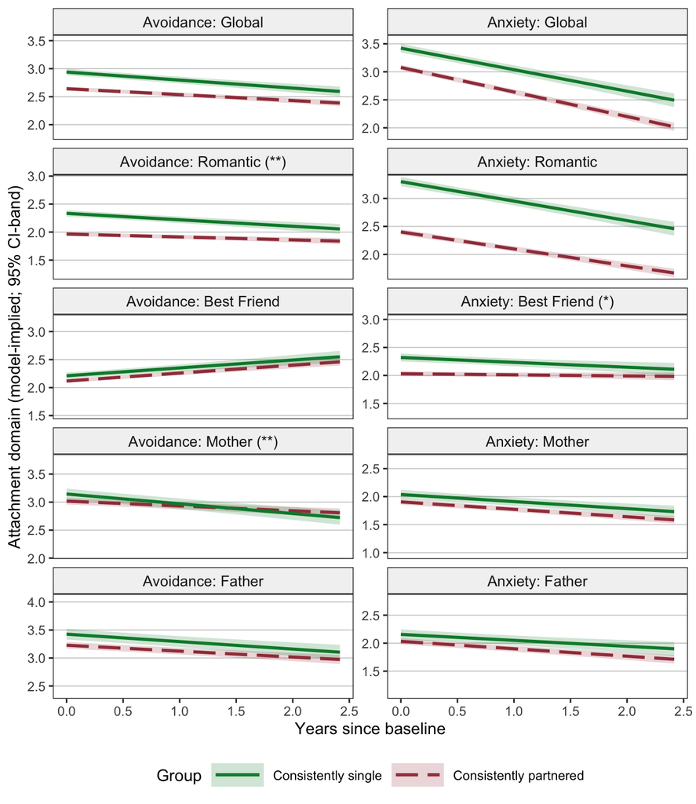

```r
plot_rq2_traject_lmer
```

These trajectories look remarkably similar to the SEM/lavaan ones. At first glance, the biggest difference is maybe the tiny difference in the singles’ slope for father-specific anxiety (but almost not noticeable).

The significance evaluation is also quite here, perhaps a bit more liberal (this is typical, in my experience). Therefore, we get significant slope differences (i.e., cross-level interactions) for romantic avoidance, mother-specific avoidance, and friend-specific anxiety.

## 6.2 LGCM but only up to 24 months

For this check, the idea is that the later months of data are relatively sparse and that most participants finished the study within 24 months. Our confirmatory models above (using 30 out of potentially 41 available months) aimed to strike a compromise and use rather more of these later months. Now we aim to be a bit more conservative and try to model the period where we definitely have sufficient observations.

```r
#overall:
table(df_atta$time_month_rd)

#by group:
table(df_atta$group_fct, df_atta$time_month_rd)
```

### 6.2.1 RQ2 models

#### 6.2.1.1 Adjust templates

```r
# Define 24-month assessment window
n_waves <- 24
times <- sprintf("%02d", 0:(n_waves - 1))
outcome_vars <- paste0("outcome_t", times)

# Intercept loadings
i_loadings <- paste0("1*", outcome_vars, collapse = " + ")

# Slope loadings (scaled 0 to 1 across 24 months)
s_values <- seq(0, 1, length.out = n_waves)
s_loadings <- paste0(round(s_values, 5), "*", outcome_vars, collapse = " + ")

# Residual variance labels
residuals <- paste0(outcome_vars, " ~~ res_", times, "*", outcome_vars, collapse = "\n")

# Model-implied trajectory parameters
trajectory_estimates <- paste0("pred_t", times, " := a0 + a1*", round(s_values, 5), collapse = "\n")

# Single-group LGCM template
rq2_template_24m <- paste0('
# Define intercept and slope factors
i =~ ', i_loadings, '

s =~ ', s_loadings, '

# Regress latent growth factors on baseline age
i ~ bi*age_base_z
s ~ bs*age_base_z

# Mean structure
i ~ a0*1
s ~ a1*1

# Variance structure
i ~~ vi*i
s ~~ vs*s
i ~~ cis*s

# Model-implied trajectories (assuming age_base_z = 0, i.e., sample-average baseline age)
', trajectory_estimates, '

# Residual variances
', residuals, '
')

# Residual variance labels (group-specific)
residuals_multi <- paste0(outcome_vars, " ~~ c(\"r", times, "_s\", \"r", times, "_p\")*", outcome_vars, collapse = "\n")

# Model-implied trajectory parameters
trajectory_estimates_multi <- paste0("pred_t", times, "_s := a0_s + a1_s*", round(s_values, 5),
                                     "\n",
                                     "pred_t", times, "_p := a0_p + a1_p*", round(s_values, 5), collapse = "\n")

# Multi-group LGCM template
rq2_template_multi_24m <- paste0('
# Define intercept and slope factors
i =~ ', i_loadings, '

s =~ ', s_loadings, '

# Regress latent growth factors on baseline age
i ~ c("bi_s", "bi_p")*age_base_z
s ~ c("bs_s", "bs_p")*age_base_z

# Mean structure
i ~ c("a0_s", "a0_p")*1
s ~ c("a1_s", "a1_p")*1

# Variance structure
i ~~ c("vi_s", "vi_p")*i
s ~~ c("vs_s", "vs_p")*s
i ~~ c("cis_s", "cis_p")*s

# Model-implied trajectories (assuming age_base_z = 0, i.e., sample-average baseline age)
', trajectory_estimates_multi, '

# Residual variances
', residuals_multi, '

')

# Constrained multi-group template
rq2_template_multi_constr_24m <- stringr::str_replace(rq2_template_multi_24m,
                                                       's ~ c\\("a1_s", "a1_p"\\)\\*1', 's ~ a1*1')
rq2_template_multi_constr_24m <- stringr::str_replace_all(rq2_template_multi_constr_24m, 'a1_s', 'a1')
rq2_template_multi_constr_24m <- stringr::str_replace_all(rq2_template_multi_constr_24m, 'a1_p', 'a1')
```

#### 6.2.1.2 Template loop & extraction

Run loop over all 5 X 2 outcomes

(Here, I suppress lavaan warnings in the html output, but they are very similar to the ones shown above for the example model. Below, I go into model diagnostics more systematically.)

```r
if (params$run_models) { # we can toggle this on/off in the YAML heading

# Loop across all attachment outcomes
for (i in 1:length(outcomes$short)) {
  print(paste0("Running outcome: ", outcomes$maj[i]))

  # Outcome-specific missingness indicator -> added this mostly for parent-specific attachment
  missi_var <- paste0(outcomes$short[i], "_missi")

  # Step 1: fill single-group model template (2x, 1 for single, 1 for partnered)
  print("-> Step 1")
  model_rq2_24m <- stringr::str_replace_all(rq2_template_24m, "outcome", outcomes$short[i])
  fit_rq2_24m <- lavaan::growth(model_rq2_24m,
                                data = df_atta_wide_single_c %>% filter(.data[[missi_var]] == 0),
                                missing = "fiml",
                                em.h1.args = list(max_iter = 5000), # to increase chance that H1 EM algorithm converges properly
                                verbose = FALSE)
  eval(call("<-", as.name(paste0("fit_rq2_", outcomes$short[i], "_24m")), fit_rq2_24m))
  saveRDS(fit_rq2_24m, file = paste0("models/fit_rq2_", outcomes$short[i], "_24m.rds"))

  fit_rq2_partn_c_24m <- lavaan::growth(model_rq2_24m,
                                        data = df_atta_wide_partn_c %>% filter(.data[[missi_var]] == 0),
                                        missing = "fiml",
                                        em.h1.args = list(max_iter = 5000), # to increase chance that H1 EM algorithm converges properly
                                        verbose = FALSE)
  eval(call("<-", as.name(paste0("fit_rq2_", outcomes$short[i], "_partn_c_24m")), fit_rq2_partn_c_24m))
  saveRDS(fit_rq2_partn_c_24m, file = paste0("models/fit_rq2_", outcomes$short[i], "_partn_c_24m.rds"))

  # Step 2: fill free multigroup model template
  print("-> Step 2")
  model_rq2_multi_24m <- stringr::str_replace_all(rq2_template_multi_24m, "outcome", outcomes$short[i])
  fit_rq2_multi_24m <- lavaan::growth(model_rq2_multi_24m,
                                      data = df_atta_wide_single_partn_c %>% filter(.data[[missi_var]] == 0) %>%
                                        arrange(group_fct),
                                      group = "group_fct",
                                      missing = "fiml",
                                      em.h1.args = list(max_iter = 5000), # to increase chance that H1 EM algorithm converges properly
                                      verbose = FALSE)
  eval(call("<-", as.name(paste0("fit_rq2_mg_", outcomes$short[i], "_24m")), fit_rq2_multi_24m))
  saveRDS(fit_rq2_multi_24m, file = paste0("models/fit_rq2_mg_", outcomes$short[i], "_24m.rds"))

  # Step 3: fill constrained multigroup model template
  print("-> Step 3")
  model_rq2_multi_constr_24m <- stringr::str_replace_all(rq2_template_multi_constr_24m, "outcome", outcomes$short[i])
  fit_rq2_multi_constr_24m <- lavaan::growth(model_rq2_multi_constr_24m,
                                             data = df_atta_wide_single_partn_c %>% filter(.data[[missi_var]] == 0) %>%
                                               arrange(group_fct),
                                             group = "group_fct",
                                             missing = "fiml",
                                             em.h1.args = list(max_iter = 5000), # to increase chance that H1 EM algorithm converges properly
                                             verbose = FALSE)
  eval(call("<-", as.name(paste0("fit_rq2_mg_", outcomes$short[i], "_constr_24m")),
            fit_rq2_multi_constr_24m))
  saveRDS(fit_rq2_multi_constr_24m, file = paste0("models/fit_rq2_mg_",
                                                  outcomes$short[i], "_constr_24m.rds"))

  # Step 4: likelihood ratio test: free vs constrained slopes
  print("-> Step 4")
  lrt_24m <- anova(fit_rq2_multi_24m, fit_rq2_multi_constr_24m)
  eval(call("<-", as.name(paste0("lrt_rq2_mg_", outcomes$short[i], "_24m")), lrt_24m))
  saveRDS(lrt_24m, file = paste0("models/lrt_rq2_mg_", outcomes$short[i], "_24m.rds"))
}
}
```

First, parameter extraction

```r
# Load saved models when run_models = FALSE
if (!params$run_models) {
  for (x in outcomes$short) {
    assign(paste0("fit_rq2_", x, "_24m"), readRDS(paste0("models/fit_rq2_", x, "_24m.rds")))
    assign(paste0("fit_rq2_", x, "_partn_c_24m"), readRDS(paste0("models/fit_rq2_", x, "_partn_c_24m.rds")))
    assign(paste0("fit_rq2_mg_", x, "_24m"), readRDS(paste0("models/fit_rq2_mg_", x, "_24m.rds")))
    assign(paste0("fit_rq2_mg_", x, "_constr_24m"), readRDS(paste0("models/fit_rq2_mg_", x, "_constr_24m.rds")))
    assign(paste0("lrt_rq2_mg_", x, "_24m"), readRDS(paste0("models/lrt_rq2_mg_", x, "_24m.rds")))
  }
}

### single-group lavaan models:
# custom function for parameter extraction
extract_lav_rq2_24m <- function(fit_obj) {
  name_obj <- as.character(substitute(fit_obj))
  name_outc <- name_obj %>%
    str_remove("fit_rq2_") %>%
    str_remove("_partn_c") %>%
    str_remove("_24m")
  group_lab <- ifelse(str_detect(name_obj, "partn_c"),
                      "Consistently partnered",
                      "Consistently single")
  # use tidy() for extraction
  broom::tidy(fit_obj, conf.int = TRUE, conf.level = 0.95) %>%
    filter(label %in% c("a0", "a1", "cis", "bi", "bs", "vi", "vs")) %>%
    mutate(outc = name_outc,
           group_fct = factor(group_lab,
                            levels = c("Consistently single", "Consistently partnered",
                                       "Intermittently partnered"),
                            labels = c("Consistently single", "Consistently partnered",
                                       "Intermittently partnered"), ordered = TRUE)) %>%
    select(outc, group_fct, term = label, est = estimate, ci_lo = conf.low, ci_hi = conf.high,
           z_value = statistic, p_value = p.value, est_std = std.all)
}

# bind all model outputs together
rq2_summary_single_24m <- bind_rows(
  extract_lav_rq2_24m(fit_rq2_avoi_glo_24m),
  extract_lav_rq2_24m(fit_rq2_avoi_rom_24m),
  extract_lav_rq2_24m(fit_rq2_avoi_fri_24m),
  extract_lav_rq2_24m(fit_rq2_avoi_mot_24m),
  extract_lav_rq2_24m(fit_rq2_avoi_fat_24m),
  extract_lav_rq2_24m(fit_rq2_anxi_glo_24m),
  extract_lav_rq2_24m(fit_rq2_anxi_rom_24m),
  extract_lav_rq2_24m(fit_rq2_anxi_fri_24m),
  extract_lav_rq2_24m(fit_rq2_anxi_mot_24m),
  extract_lav_rq2_24m(fit_rq2_anxi_fat_24m),
  extract_lav_rq2_24m(fit_rq2_avoi_glo_partn_c_24m),
  extract_lav_rq2_24m(fit_rq2_avoi_rom_partn_c_24m),
  extract_lav_rq2_24m(fit_rq2_avoi_fri_partn_c_24m),
  extract_lav_rq2_24m(fit_rq2_avoi_mot_partn_c_24m),
  extract_lav_rq2_24m(fit_rq2_avoi_fat_partn_c_24m),
  extract_lav_rq2_24m(fit_rq2_anxi_glo_partn_c_24m),
  extract_lav_rq2_24m(fit_rq2_anxi_rom_partn_c_24m),
  extract_lav_rq2_24m(fit_rq2_anxi_fri_partn_c_24m),
  extract_lav_rq2_24m(fit_rq2_anxi_mot_partn_c_24m),
  extract_lav_rq2_24m(fit_rq2_anxi_fat_partn_c_24m)
)

# Add labels
rq2_summary_single_24m <- rq2_summary_single_24m %>%
  mutate(outc_fct = factor(outc, levels = outcomes$short, labels = outcomes$maj, ordered = TRUE))#

### multi-group lavaan models
# custom function for parameter extraction
extract_lav_rq2_mg_24m <- function(fit_obj, lrt_obj) {
  name_obj <- as.character(substitute(fit_obj))
  name_outc <- str_remove(name_obj, "fit_rq2_mg_") %>% str_remove("_24m")

  # extract LRT information
  lrt_tab <- as.data.frame(lrt_obj)
  lrt_chi <- lrt_tab$`Chisq diff`[2]
  lrt_df <- lrt_tab$`Df diff`[2]
  lrt_p <- lrt_tab$`Pr(>Chisq)`[2]

  # extract model parameters
  broom::tidy(fit_obj, conf.int = TRUE, conf.level = 0.95) %>%
    filter(label %in% c("a0_s", "a0_p", "a1_s", "a1_p", "cis_s", "cis_p",
                        "bi_s", "bi_p", "bs_s", "bs_p", "vi_s", "vi_p", "vs_s", "vs_p")) %>%
    mutate(outc = name_outc,
           group_fct = case_when(str_detect(label, "_s$") ~ "Consistently single",
                                 str_detect(label, "_p$") ~ "Consistently partnered",
                                 TRUE ~ NA_character_),
      group_fct = factor(group_fct, levels = c("Consistently single", "Consistently partnered",
                                    "Intermittently partnered"), ordered = TRUE),
      lrt_chi = ifelse(str_detect(label, "^a1_"), lrt_chi, NA),
      lrt_df = ifelse(str_detect(label, "^a1_"), lrt_df, NA),
      lrt_p = ifelse(str_detect(label, "^a1_"), lrt_p, NA)) %>%
    select(outc, group_fct, term = label,
           est = estimate, ci_lo = conf.low, ci_hi = conf.high,
           z_value = statistic, p_value = p.value, est_std = std.all,
           lrt_chi, lrt_df, lrt_p)
}

# bind all model outputs together
rq2_summary_mg_24m <- bind_rows(
  extract_lav_rq2_mg_24m(fit_rq2_mg_avoi_glo_24m, lrt_rq2_mg_avoi_glo_24m),
  extract_lav_rq2_mg_24m(fit_rq2_mg_avoi_rom_24m, lrt_rq2_mg_avoi_rom_24m),
  extract_lav_rq2_mg_24m(fit_rq2_mg_avoi_fri_24m, lrt_rq2_mg_avoi_fri_24m),
  extract_lav_rq2_mg_24m(fit_rq2_mg_avoi_mot_24m, lrt_rq2_mg_avoi_mot_24m),
  extract_lav_rq2_mg_24m(fit_rq2_mg_avoi_fat_24m, lrt_rq2_mg_avoi_fat_24m),
  extract_lav_rq2_mg_24m(fit_rq2_mg_anxi_glo_24m, lrt_rq2_mg_anxi_glo_24m),
  extract_lav_rq2_mg_24m(fit_rq2_mg_anxi_rom_24m, lrt_rq2_mg_anxi_rom_24m),
  extract_lav_rq2_mg_24m(fit_rq2_mg_anxi_fri_24m, lrt_rq2_mg_anxi_fri_24m),
  extract_lav_rq2_mg_24m(fit_rq2_mg_anxi_mot_24m, lrt_rq2_mg_anxi_mot_24m),
  extract_lav_rq2_mg_24m(fit_rq2_mg_anxi_fat_24m, lrt_rq2_mg_anxi_fat_24m)
)

# Add labels
rq2_summary_mg_24m <- rq2_summary_mg_24m %>%
  mutate(outc_fct = factor(outc, levels = outcomes$short, labels = outcomes$maj, ordered = TRUE))
```

#### 6.2.1.3 Model fit

Fit statistics: single-group models  
-> These fit indices are very computationally expensive. I put them in a conditional chunk and load them as an RDS object in the next chunk.

```r
if (params$run_expensive) { # only run when we allow this in YAML heading

# model fit statistics: single-group models
rq2_fit_single_24m <- outcomes$short %>%
  purrr::map_dfr(function(x) {
    bind_rows(
      broom::glance(get(paste0("fit_rq2_", x, "_24m"))) %>%
        mutate(outc = x, group_fct = "Consistently single"),
      broom::glance(get(paste0("fit_rq2_", x, "_partn_c_24m"))) %>%
        mutate(outc = x, group_fct = "Consistently partnered"))
  }) %>%
  select(outc, group_fct, nobs, npar, AIC, BIC, cfi, rmsea, srmr) %>%
  mutate(
    outc_fct = factor(outc, levels = outcomes$short, labels = outcomes$maj, ordered = TRUE),
    group_fct = factor(group_fct,
                       levels = c("Consistently single",
                                  "Consistently partnered",
                                  "Intermittently partnered"),
                       ordered = TRUE))

# save externally:
saveRDS(rq2_fit_single_24m, "model_fit/rq2_fit_single_24m.rds")
}
```

Show fit indices table:

```r
rq2_fit_single_24m <- readRDS("model_fit/rq2_fit_single_24m.rds")

rq2_fit_single_24m %>% select(-outc) %>%
  select(outc_fct, group_fct, everything()) %>%
  kable(digits = 3)
```

| outc_fct | group_fct | nobs | npar | AIC | BIC | cfi | rmsea | srmr |
| --- | --- | --- | --- | --- | --- | --- | --- | --- |
| Avoidance: Global | Consistently single | 622 | 31 | 7473.655 | 7611.077 | 0.948 | 0.044 | 0.053 |
| Avoidance: Global | Consistently partnered | 1588 | 31 | 17860.467 | 18026.944 | 0.977 | 0.029 | 0.062 |
| Avoidance: Romantic | Consistently single | 622 | 31 | 8636.734 | 8774.155 | 0.925 | 0.049 | 0.082 |
| Avoidance: Romantic | Consistently partnered | 1588 | 31 | 18334.510 | 18500.987 | 0.965 | 0.035 | 0.058 |
| Avoidance: Best Friend | Consistently single | 622 | 31 | 9650.332 | 9787.753 | 0.870 | 0.065 | 0.172 |
| Avoidance: Best Friend | Consistently partnered | 1587 | 31 | 20202.472 | 20368.930 | 0.939 | 0.043 | 0.140 |
| Avoidance: Mother | Consistently single | 544 | 31 | 7568.373 | 7701.641 | 0.929 | 0.061 | 0.078 |
| Avoidance: Mother | Consistently partnered | 1367 | 31 | 17137.431 | 17299.263 | 0.971 | 0.040 | 0.054 |
| Avoidance: Father | Consistently single | 484 | 31 | 5866.849 | 5996.493 | 0.919 | 0.065 | 0.052 |
| Avoidance: Father | Consistently partnered | 1246 | 31 | 15233.845 | 15392.804 | 0.970 | 0.039 | 0.074 |
| Anxiety: Global | Consistently single | 622 | 31 | 11633.261 | 11770.682 | 0.920 | 0.052 | 0.101 |
| Anxiety: Global | Consistently partnered | 1588 | 31 | 28937.446 | 29103.923 | 0.942 | 0.042 | 0.083 |
| Anxiety: Romantic | Consistently single | 622 | 31 | 12219.542 | 12356.963 | 0.926 | 0.050 | 0.115 |
| Anxiety: Romantic | Consistently partnered | 1588 | 31 | 28309.166 | 28475.643 | 0.949 | 0.039 | 0.073 |
| Anxiety: Best Friend | Consistently single | 622 | 31 | 11919.753 | 12057.174 | 0.937 | 0.043 | 0.087 |
| Anxiety: Best Friend | Consistently partnered | 1587 | 31 | 25274.799 | 25441.257 | 0.950 | 0.037 | 0.130 |
| Anxiety: Mother | Consistently single | 544 | 31 | 8494.596 | 8627.864 | 0.912 | 0.059 | 0.062 |
| Anxiety: Mother | Consistently partnered | 1367 | 31 | 19565.975 | 19727.807 | 0.950 | 0.042 | 0.045 |
| Anxiety: Father | Consistently single | 484 | 31 | 7807.372 | 7937.016 | 0.884 | 0.068 | 0.061 |
| Anxiety: Father | Consistently partnered | 1246 | 31 | 18613.295 | 18772.254 | 0.948 | 0.044 | 0.055 |

Fit statistics: multi-group models (of consistently single & consistently partnered)

```r
if (params$run_expensive) { # only run when we allow this in YAML heading

# model fit statistics: multi-group models
rq2_fit_mg_24m <- outcomes$short %>%
  purrr::map_dfr(function(x) {
    broom::glance(get(paste0("fit_rq2_mg_", x, "_24m"))) %>%
      mutate(outc = x)
  }) %>%
  select(outc, nobs, npar, AIC, BIC, cfi, rmsea, srmr) %>%
  mutate(outc_fct = factor(outc, levels = outcomes$short, labels = outcomes$maj, ordered = TRUE))

# save externally:
saveRDS(rq2_fit_mg_24m, "model_fit/rq2_fit_mg_24m.rds")
}
```

Show fit indices table:

```r
rq2_fit_mg_24m <- readRDS("model_fit/rq2_fit_mg_24m.rds")

rq2_fit_mg_24m %>%
  select(-outc) %>% select(outc_fct, everything()) %>%
  kable(digits = 3)
```

| outc_fct | nobs | npar | AIC | BIC | cfi | rmsea | srmr |
| --- | --- | --- | --- | --- | --- | --- | --- |
| Avoidance: Global | 2210 | 62 | 25334.12 | 25687.57 | 0.968 | 0.034 | 0.060 |
| Avoidance: Romantic | 2210 | 62 | 26971.24 | 27324.69 | 0.955 | 0.039 | 0.064 |
| Avoidance: Best Friend | 2209 | 62 | 29852.80 | 30206.22 | 0.919 | 0.050 | 0.149 |
| Avoidance: Mother | 1911 | 62 | 24705.80 | 25050.24 | 0.959 | 0.047 | 0.061 |
| Avoidance: Father | 1730 | 62 | 21100.69 | 21438.96 | 0.955 | 0.048 | 0.068 |
| Anxiety: Global | 2210 | 62 | 40570.71 | 40924.15 | 0.935 | 0.045 | 0.088 |
| Anxiety: Romantic | 2210 | 62 | 40528.71 | 40882.15 | 0.942 | 0.043 | 0.085 |
| Anxiety: Best Friend | 2209 | 62 | 37194.55 | 37547.97 | 0.946 | 0.039 | 0.118 |
| Anxiety: Mother | 1911 | 62 | 28060.57 | 28405.01 | 0.939 | 0.048 | 0.050 |
| Anxiety: Father | 1730 | 62 | 26420.67 | 26758.93 | 0.929 | 0.052 | 0.057 |

Overall, better fit here compared to the 30-month version, esp. in the SRMR. Easier for lavaan to deal with fewer time points and lower rater of missingness (for FIML).

#### 6.2.1.4 Model diagnostics

- Did the model converge?
- Did lavaan’s internal check pass?
- Are there inadmissible negative variances?

##### 6.2.1.4.1 Single-group models

```r
# diagnostics for all single-group and partnered RQ2 models
rq2_models_24m <- c("fit_rq2_avoi_glo_24m", "fit_rq2_avoi_rom_24m",
                "fit_rq2_avoi_fri_24m", "fit_rq2_avoi_mot_24m",
                "fit_rq2_avoi_fat_24m", "fit_rq2_anxi_glo_24m",
                "fit_rq2_anxi_rom_24m", "fit_rq2_anxi_fri_24m",
                "fit_rq2_anxi_mot_24m", "fit_rq2_anxi_fat_24m",
                "fit_rq2_avoi_glo_partn_c_24m", "fit_rq2_avoi_rom_partn_c_24m",
                "fit_rq2_avoi_fri_partn_c_24m", "fit_rq2_avoi_mot_partn_c_24m",
                "fit_rq2_avoi_fat_partn_c_24m", "fit_rq2_anxi_glo_partn_c_24m",
                "fit_rq2_anxi_rom_partn_c_24m", "fit_rq2_anxi_fri_partn_c_24m",
                "fit_rq2_anxi_mot_partn_c_24m", "fit_rq2_anxi_fat_partn_c_24m")

rq2_diagnostics_24m <- purrr::map_dfr(rq2_models_24m, function(x) {
  fit <- get(x)
  tibble(
    model = x,
    converged = lavInspect(fit, "converged"),
    post_check = lavInspect(fit, "post.check"),
    neg_variances = any(parameterEstimates(fit)$op == "~~" &
                          parameterEstimates(fit)$lhs == parameterEstimates(fit)$rhs &
                          parameterEstimates(fit)$est < 0))
})

rq2_diagnostics_24m %>% kable(digits = 3)
```

| model | converged | post_check | neg_variances |
| --- | --- | --- | --- |
| fit_rq2_avoi_glo_24m | TRUE | TRUE | FALSE |
| fit_rq2_avoi_rom_24m | TRUE | TRUE | FALSE |
| fit_rq2_avoi_fri_24m | TRUE | TRUE | FALSE |
| fit_rq2_avoi_mot_24m | TRUE | TRUE | FALSE |
| fit_rq2_avoi_fat_24m | TRUE | TRUE | FALSE |
| fit_rq2_anxi_glo_24m | TRUE | TRUE | FALSE |
| fit_rq2_anxi_rom_24m | TRUE | TRUE | FALSE |
| fit_rq2_anxi_fri_24m | TRUE | TRUE | FALSE |
| fit_rq2_anxi_mot_24m | TRUE | TRUE | FALSE |
| fit_rq2_anxi_fat_24m | TRUE | TRUE | FALSE |
| fit_rq2_avoi_glo_partn_c_24m | TRUE | TRUE | FALSE |
| fit_rq2_avoi_rom_partn_c_24m | TRUE | TRUE | FALSE |
| fit_rq2_avoi_fri_partn_c_24m | TRUE | TRUE | FALSE |
| fit_rq2_avoi_mot_partn_c_24m | TRUE | TRUE | FALSE |
| fit_rq2_avoi_fat_partn_c_24m | TRUE | TRUE | FALSE |
| fit_rq2_anxi_glo_partn_c_24m | TRUE | TRUE | FALSE |
| fit_rq2_anxi_rom_partn_c_24m | TRUE | TRUE | FALSE |
| fit_rq2_anxi_fri_partn_c_24m | TRUE | TRUE | FALSE |
| fit_rq2_anxi_mot_partn_c_24m | TRUE | TRUE | FALSE |
| fit_rq2_anxi_fat_partn_c_24m | TRUE | TRUE | FALSE |

##### 6.2.1.4.2 Multi-group models

```r
rq2_mg_models_24m <- c("fit_rq2_mg_avoi_glo_24m", "fit_rq2_mg_avoi_rom_24m",
                   "fit_rq2_mg_avoi_fri_24m", "fit_rq2_mg_avoi_mot_24m",
                   "fit_rq2_mg_avoi_fat_24m", "fit_rq2_mg_anxi_glo_24m",
                   "fit_rq2_mg_anxi_rom_24m", "fit_rq2_mg_anxi_fri_24m",
                   "fit_rq2_mg_anxi_mot_24m", "fit_rq2_mg_anxi_fat_24m")

rq2_mg_diagnostics_24m <- purrr::map_dfr(rq2_mg_models_24m, function(x) {
  fit <- get(x)
  pe <- parameterEstimates(fit)
  tibble(
    model = x,
    converged = lavInspect(fit, "converged"),
    post_check = lavInspect(fit, "post.check"),
    neg_variances = any(pe$op == "~~" &
                          pe$lhs == pe$rhs &
                          pe$est < 0))
})

rq2_mg_diagnostics_24m %>% kable(digits = 3)
```

| model | converged | post_check | neg_variances |
| --- | --- | --- | --- |
| fit_rq2_mg_avoi_glo_24m | TRUE | TRUE | FALSE |
| fit_rq2_mg_avoi_rom_24m | TRUE | TRUE | FALSE |
| fit_rq2_mg_avoi_fri_24m | TRUE | TRUE | FALSE |
| fit_rq2_mg_avoi_mot_24m | TRUE | TRUE | FALSE |
| fit_rq2_mg_avoi_fat_24m | TRUE | TRUE | FALSE |
| fit_rq2_mg_anxi_glo_24m | TRUE | TRUE | FALSE |
| fit_rq2_mg_anxi_rom_24m | TRUE | TRUE | FALSE |
| fit_rq2_mg_anxi_fri_24m | TRUE | TRUE | FALSE |
| fit_rq2_mg_anxi_mot_24m | TRUE | TRUE | FALSE |
| fit_rq2_mg_anxi_fat_24m | TRUE | TRUE | FALSE |

All good here.

#### 6.2.1.5 Summary tables

##### 6.2.1.5.1 Single-group models

Latent intercept and slope factors: “alpha0” (a0) & “alpha1” (a1):

```r
rq2_table_24m_a <- rq2_summary_single_24m %>%
  filter(term=="a0" | term=="a1") %>%
  arrange(outc_fct, group_fct, term) %>%
  mutate(sig = case_when(p_value < .001 ~ "***", p_value < .01 ~ "**", p_value < .05 ~ "*", TRUE ~ "")) %>%
  select(outc_fct, group_fct, term, est, ci_lo, ci_hi, p_value, sig, est_std)

rq2_table_24m_a %>%
  knitr::kable(digits = 3, format = "html") %>%
  kableExtra::kable_styling(full_width = FALSE, bootstrap_options = c("bordered")) %>%
  kableExtra::row_spec(which(rep(c(TRUE, FALSE), each = 4, length.out = nrow(rq2_table_24m_a))),
                       background = "lightgrey")
```

| outc_fct | group_fct | term | est | ci_lo | ci_hi | p_value | sig | est_std |
| --- | --- | --- | --- | --- | --- | --- | --- | --- |
| Avoidance: Global | Consistently single | a0 | 2.947 | 2.888 | 3.005 | 0.000 | *** | 4.163 |
| Avoidance: Global | Consistently single | a1 | -0.286 | -0.358 | -0.215 | 0.000 | *** | -0.448 |
| Avoidance: Global | Consistently partnered | a0 | 2.642 | 2.603 | 2.680 | 0.000 | *** | 3.638 |
| Avoidance: Global | Consistently partnered | a1 | -0.202 | -0.246 | -0.158 | 0.000 | *** | -0.332 |
| Avoidance: Romantic | Consistently single | a0 | 2.310 | 2.254 | 2.367 | 0.000 | *** | 3.468 |
| Avoidance: Romantic | Consistently single | a1 | -0.184 | -0.265 | -0.103 | 0.000 | *** | -0.259 |
| Avoidance: Romantic | Consistently partnered | a0 | 1.939 | 1.902 | 1.976 | 0.000 | *** | 2.682 |
| Avoidance: Romantic | Consistently partnered | a1 | -0.105 | -0.150 | -0.059 | 0.000 | *** | -0.164 |
| Avoidance: Best Friend | Consistently single | a0 | 2.225 | 2.164 | 2.285 | 0.000 | *** | 3.109 |
| Avoidance: Best Friend | Consistently single | a1 | 0.255 | 0.158 | 0.352 | 0.000 | *** | 0.278 |
| Avoidance: Best Friend | Consistently partnered | a0 | 2.117 | 2.080 | 2.153 | 0.000 | *** | 3.106 |
| Avoidance: Best Friend | Consistently partnered | a1 | 0.289 | 0.231 | 0.347 | 0.000 | *** | 0.322 |
| Avoidance: Mother | Consistently single | a0 | 3.171 | 3.072 | 3.269 | 0.000 | *** | 2.888 |
| Avoidance: Mother | Consistently single | a1 | -0.384 | -0.491 | -0.276 | 0.000 | *** | -0.398 |
| Avoidance: Mother | Consistently partnered | a0 | 3.036 | 2.976 | 3.096 | 0.000 | *** | 2.698 |
| Avoidance: Mother | Consistently partnered | a1 | -0.175 | -0.229 | -0.120 | 0.000 | *** | -0.224 |
| Avoidance: Father | Consistently single | a0 | 3.426 | 3.326 | 3.525 | 0.000 | *** | 3.428 |
| Avoidance: Father | Consistently single | a1 | -0.248 | -0.351 | -0.145 | 0.000 | *** | -0.310 |
| Avoidance: Father | Consistently partnered | a0 | 3.250 | 3.189 | 3.311 | 0.000 | *** | 3.040 |
| Avoidance: Father | Consistently partnered | a1 | -0.192 | -0.250 | -0.133 | 0.000 | *** | -0.243 |
| Anxiety: Global | Consistently single | a0 | 3.432 | 3.355 | 3.509 | 0.000 | *** | 3.744 |
| Anxiety: Global | Consistently single | a1 | -0.777 | -0.880 | -0.674 | 0.000 | *** | -0.849 |
| Anxiety: Global | Consistently partnered | a0 | 3.099 | 3.048 | 3.150 | 0.000 | *** | 3.231 |
| Anxiety: Global | Consistently partnered | a1 | -0.874 | -0.940 | -0.808 | 0.000 | *** | -0.948 |
| Anxiety: Romantic | Consistently single | a0 | 3.292 | 3.210 | 3.373 | 0.000 | *** | 3.396 |
| Anxiety: Romantic | Consistently single | a1 | -0.647 | -0.764 | -0.530 | 0.000 | *** | -0.594 |
| Anxiety: Romantic | Consistently partnered | a0 | 2.397 | 2.343 | 2.450 | 0.000 | *** | 2.378 |
| Anxiety: Romantic | Consistently partnered | a1 | -0.591 | -0.659 | -0.523 | 0.000 | *** | -0.596 |
| Anxiety: Best Friend | Consistently single | a0 | 2.329 | 2.247 | 2.411 | 0.000 | *** | 2.376 |
| Anxiety: Best Friend | Consistently single | a1 | -0.182 | -0.297 | -0.068 | 0.002 | ** | -0.168 |
| Anxiety: Best Friend | Consistently partnered | a0 | 2.039 | 1.996 | 2.083 | 0.000 | *** | 2.487 |
| Anxiety: Best Friend | Consistently partnered | a1 | -0.043 | -0.107 | 0.021 | 0.188 |  | -0.045 |
| Anxiety: Mother | Consistently single | a0 | 2.058 | 1.970 | 2.147 | 0.000 | *** | 2.095 |
| Anxiety: Mother | Consistently single | a1 | -0.265 | -0.367 | -0.163 | 0.000 | *** | -0.313 |
| Anxiety: Mother | Consistently partnered | a0 | 1.910 | 1.857 | 1.964 | 0.000 | *** | 1.973 |
| Anxiety: Mother | Consistently partnered | a1 | -0.260 | -0.317 | -0.203 | 0.000 | *** | -0.332 |
| Anxiety: Father | Consistently single | a0 | 2.186 | 2.089 | 2.283 | 0.000 | *** | 2.287 |
| Anxiety: Father | Consistently single | a1 | -0.282 | -0.401 | -0.162 | 0.000 | *** | -0.316 |
| Anxiety: Father | Consistently partnered | a0 | 2.049 | 1.991 | 2.107 | 0.000 | *** | 2.042 |
| Anxiety: Father | Consistently partnered | a1 | -0.248 | -0.312 | -0.185 | 0.000 | *** | -0.308 |

Latent intercept-slope covariance: (cis)

```r
rq2_table_24m_cis <- rq2_summary_single_24m %>%
  filter(term=="cis") %>%
  arrange(outc_fct, group_fct) %>%
  mutate(sig = case_when(p_value < .001 ~ "***", p_value < .01 ~ "**", p_value < .05 ~ "*", TRUE ~ "")) %>%
  select(outc_fct, group_fct, term, est, ci_lo, ci_hi, p_value, sig, est_std)

rq2_table_24m_cis %>%
  knitr::kable(digits = 3, format = "html") %>%
  kableExtra::kable_styling(full_width = FALSE, bootstrap_options = c("bordered")) %>%
  kableExtra::row_spec(which(rep(c(TRUE, FALSE), each = 2, length.out = nrow(rq2_table_24m_cis))),
                       background = "lightgrey")
```

| outc_fct | group_fct | term | est | ci_lo | ci_hi | p_value | sig | est_std |
| --- | --- | --- | --- | --- | --- | --- | --- | --- |
| Avoidance: Global | Consistently single | cis | -0.055 | -0.110 | 0.000 | 0.052 |  | -0.121 |
| Avoidance: Global | Consistently partnered | cis | -0.104 | -0.138 | -0.070 | 0.000 | *** | -0.236 |
| Avoidance: Romantic | Consistently single | cis | -0.058 | -0.119 | 0.002 | 0.059 |  | -0.126 |
| Avoidance: Romantic | Consistently partnered | cis | -0.106 | -0.140 | -0.072 | 0.000 | *** | -0.238 |
| Avoidance: Best Friend | Consistently single | cis | -0.108 | -0.185 | -0.032 | 0.005 | ** | -0.166 |
| Avoidance: Best Friend | Consistently partnered | cis | -0.151 | -0.194 | -0.108 | 0.000 | *** | -0.247 |
| Avoidance: Mother | Consistently single | cis | -0.288 | -0.408 | -0.169 | 0.000 | *** | -0.276 |
| Avoidance: Mother | Consistently partnered | cis | -0.206 | -0.270 | -0.141 | 0.000 | *** | -0.237 |
| Avoidance: Father | Consistently single | cis | -0.110 | -0.209 | -0.012 | 0.029 | * | -0.138 |
| Avoidance: Father | Consistently partnered | cis | -0.165 | -0.230 | -0.100 | 0.000 | *** | -0.198 |
| Anxiety: Global | Consistently single | cis | -0.123 | -0.226 | -0.020 | 0.019 | * | -0.147 |
| Anxiety: Global | Consistently partnered | cis | -0.272 | -0.341 | -0.204 | 0.000 | *** | -0.315 |
| Anxiety: Romantic | Consistently single | cis | -0.174 | -0.297 | -0.051 | 0.005 | ** | -0.166 |
| Anxiety: Romantic | Consistently partnered | cis | -0.475 | -0.555 | -0.395 | 0.000 | *** | -0.478 |
| Anxiety: Best Friend | Consistently single | cis | -0.466 | -0.598 | -0.334 | 0.000 | *** | -0.441 |
| Anxiety: Best Friend | Consistently partnered | cis | -0.299 | -0.358 | -0.240 | 0.000 | *** | -0.380 |
| Anxiety: Mother | Consistently single | cis | -0.339 | -0.448 | -0.231 | 0.000 | *** | -0.425 |
| Anxiety: Mother | Consistently partnered | cis | -0.375 | -0.441 | -0.309 | 0.000 | *** | -0.497 |
| Anxiety: Father | Consistently single | cis | -0.225 | -0.340 | -0.111 | 0.000 | *** | -0.272 |
| Anxiety: Father | Consistently partnered | cis | -0.322 | -0.394 | -0.250 | 0.000 | *** | -0.402 |

Variances of the latent intercept and slope factors: (vi) & (vs)

```r
rq2_table_24m_v <- rq2_summary_single_24m %>%
  filter(stringr::str_starts(term, "v")) %>%
  arrange(outc_fct, group_fct, term) %>%
  mutate(sig = case_when(p_value < .001 ~ "***", p_value < .01 ~ "**", p_value < .05 ~ "*", TRUE ~ "")) %>%
  select(outc_fct, group_fct, term, est, ci_lo, ci_hi, p_value, sig)

rq2_table_24m_v %>%
  knitr::kable(digits = 3, format = "html") %>%
  kableExtra::kable_styling(full_width = FALSE, bootstrap_options = c("bordered")) %>%
  kableExtra::row_spec(which(rep(c(TRUE, FALSE), each = 4, length.out = nrow(rq2_table_24m_v))),
                       background = "lightgrey")
```

| outc_fct | group_fct | term | est | ci_lo | ci_hi | p_value | sig |
| --- | --- | --- | --- | --- | --- | --- | --- |
| Avoidance: Global | Consistently single | vi | 0.498 | 0.437 | 0.560 | 0 | *** |
| Avoidance: Global | Consistently single | vs | 0.408 | 0.320 | 0.495 | 0 | *** |
| Avoidance: Global | Consistently partnered | vi | 0.527 | 0.487 | 0.568 | 0 | *** |
| Avoidance: Global | Consistently partnered | vs | 0.369 | 0.319 | 0.419 | 0 | *** |
| Avoidance: Romantic | Consistently single | vi | 0.438 | 0.381 | 0.495 | 0 | *** |
| Avoidance: Romantic | Consistently single | vs | 0.495 | 0.381 | 0.608 | 0 | *** |
| Avoidance: Romantic | Consistently partnered | vi | 0.489 | 0.451 | 0.527 | 0 | *** |
| Avoidance: Romantic | Consistently partnered | vs | 0.406 | 0.350 | 0.462 | 0 | *** |
| Avoidance: Best Friend | Consistently single | vi | 0.511 | 0.446 | 0.576 | 0 | *** |
| Avoidance: Best Friend | Consistently single | vs | 0.831 | 0.656 | 1.007 | 0 | *** |
| Avoidance: Best Friend | Consistently partnered | vi | 0.464 | 0.428 | 0.501 | 0 | *** |
| Avoidance: Best Friend | Consistently partnered | vs | 0.804 | 0.713 | 0.896 | 0 | *** |
| Avoidance: Mother | Consistently single | vi | 1.179 | 1.031 | 1.327 | 0 | *** |
| Avoidance: Mother | Consistently single | vs | 0.924 | 0.750 | 1.098 | 0 | *** |
| Avoidance: Mother | Consistently partnered | vi | 1.240 | 1.143 | 1.337 | 0 | *** |
| Avoidance: Mother | Consistently partnered | vs | 0.608 | 0.529 | 0.688 | 0 | *** |
| Avoidance: Father | Consistently single | vi | 0.998 | 0.865 | 1.130 | 0 | *** |
| Avoidance: Father | Consistently single | vs | 0.639 | 0.504 | 0.774 | 0 | *** |
| Avoidance: Father | Consistently partnered | vi | 1.136 | 1.042 | 1.230 | 0 | *** |
| Avoidance: Father | Consistently partnered | vs | 0.614 | 0.530 | 0.698 | 0 | *** |
| Anxiety: Global | Consistently single | vi | 0.840 | 0.735 | 0.946 | 0 | *** |
| Anxiety: Global | Consistently single | vs | 0.836 | 0.661 | 1.012 | 0 | *** |
| Anxiety: Global | Consistently partnered | vi | 0.892 | 0.821 | 0.963 | 0 | *** |
| Anxiety: Global | Consistently partnered | vs | 0.837 | 0.725 | 0.949 | 0 | *** |
| Anxiety: Romantic | Consistently single | vi | 0.939 | 0.820 | 1.058 | 0 | *** |
| Anxiety: Romantic | Consistently single | vs | 1.173 | 0.945 | 1.402 | 0 | *** |
| Anxiety: Romantic | Consistently partnered | vi | 1.014 | 0.935 | 1.094 | 0 | *** |
| Anxiety: Romantic | Consistently partnered | vs | 0.974 | 0.847 | 1.101 | 0 | *** |
| Anxiety: Best Friend | Consistently single | vi | 0.961 | 0.840 | 1.082 | 0 | *** |
| Anxiety: Best Friend | Consistently single | vs | 1.164 | 0.938 | 1.391 | 0 | *** |
| Anxiety: Best Friend | Consistently partnered | vi | 0.670 | 0.617 | 0.724 | 0 | *** |
| Anxiety: Best Friend | Consistently partnered | vs | 0.924 | 0.810 | 1.038 | 0 | *** |
| Anxiety: Mother | Consistently single | vi | 0.916 | 0.796 | 1.035 | 0 | *** |
| Anxiety: Mother | Consistently single | vs | 0.697 | 0.542 | 0.851 | 0 | *** |
| Anxiety: Mother | Consistently partnered | vi | 0.930 | 0.854 | 1.006 | 0 | *** |
| Anxiety: Mother | Consistently partnered | vs | 0.612 | 0.526 | 0.698 | 0 | *** |
| Anxiety: Father | Consistently single | vi | 0.906 | 0.780 | 1.032 | 0 | *** |
| Anxiety: Father | Consistently single | vs | 0.760 | 0.590 | 0.930 | 0 | *** |
| Anxiety: Father | Consistently partnered | vi | 0.994 | 0.907 | 1.080 | 0 | *** |
| Anxiety: Father | Consistently partnered | vs | 0.645 | 0.546 | 0.744 | 0 | *** |

Age moderation of latent intercept and slope factors: (bi) & (bs)

```r
rq2_table_24m_b <- rq2_summary_single_24m %>%
  filter(term=="bi" | term=="bs") %>%
  arrange(outc_fct, group_fct, term) %>%
  mutate(sig = case_when(p_value < .001 ~ "***", p_value < .01 ~ "**", p_value < .05 ~ "*", TRUE ~ "")) %>%
  select(outc_fct, group_fct, term, est, ci_lo, ci_hi, p_value, sig, est_std)

rq2_table_24m_b %>%
  knitr::kable(digits = 3, format = "html") %>%
  kableExtra::kable_styling(full_width = FALSE, bootstrap_options = c("bordered")) %>%
  kableExtra::row_spec(which(rep(c(TRUE, FALSE), each = 4, length.out = nrow(rq2_table_24m_b))),
                       background = "lightgrey")
```

| outc_fct | group_fct | term | est | ci_lo | ci_hi | p_value | sig | est_std |
| --- | --- | --- | --- | --- | --- | --- | --- | --- |
| Avoidance: Global | Consistently single | bi | -0.046 | -0.099 | 0.006 | 0.084 |  | -0.073 |
| Avoidance: Global | Consistently single | bs | 0.029 | -0.034 | 0.093 | 0.362 |  | 0.051 |
| Avoidance: Global | Consistently partnered | bi | -0.006 | -0.044 | 0.031 | 0.735 |  | -0.009 |
| Avoidance: Global | Consistently partnered | bs | 0.009 | -0.032 | 0.051 | 0.668 |  | 0.015 |
| Avoidance: Romantic | Consistently single | bi | 0.071 | 0.020 | 0.121 | 0.006 | ** | 0.118 |
| Avoidance: Romantic | Consistently single | bs | -0.077 | -0.148 | -0.006 | 0.034 | * | -0.120 |
| Avoidance: Romantic | Consistently partnered | bi | 0.183 | 0.146 | 0.219 | 0.000 | *** | 0.253 |
| Avoidance: Romantic | Consistently partnered | bs | 0.021 | -0.022 | 0.064 | 0.349 |  | 0.032 |
| Avoidance: Best Friend | Consistently single | bi | -0.028 | -0.083 | 0.026 | 0.307 |  | -0.044 |
| Avoidance: Best Friend | Consistently single | bs | -0.089 | -0.174 | -0.003 | 0.043 | * | -0.107 |
| Avoidance: Best Friend | Consistently partnered | bi | 0.014 | -0.022 | 0.050 | 0.441 |  | 0.021 |
| Avoidance: Best Friend | Consistently partnered | bs | -0.047 | -0.102 | 0.009 | 0.099 |  | -0.052 |
| Avoidance: Mother | Consistently single | bi | 0.182 | 0.078 | 0.286 | 0.001 | *** | 0.149 |
| Avoidance: Mother | Consistently single | bs | -0.092 | -0.207 | 0.022 | 0.114 |  | -0.086 |
| Avoidance: Mother | Consistently partnered | bi | 0.192 | 0.120 | 0.263 | 0.000 | *** | 0.144 |
| Avoidance: Mother | Consistently partnered | bs | 0.031 | -0.033 | 0.094 | 0.344 |  | 0.033 |
| Avoidance: Father | Consistently single | bi | 0.032 | -0.076 | 0.140 | 0.559 |  | 0.027 |
| Avoidance: Father | Consistently single | bs | 0.007 | -0.106 | 0.119 | 0.906 |  | 0.007 |
| Avoidance: Father | Consistently partnered | bi | 0.106 | 0.028 | 0.184 | 0.007 | ** | 0.078 |
| Avoidance: Father | Consistently partnered | bs | 0.088 | 0.013 | 0.163 | 0.021 | * | 0.087 |
| Anxiety: Global | Consistently single | bi | -0.002 | -0.071 | 0.067 | 0.946 |  | -0.003 |
| Anxiety: Global | Consistently single | bs | -0.044 | -0.134 | 0.047 | 0.346 |  | -0.053 |
| Anxiety: Global | Consistently partnered | bi | -0.167 | -0.216 | -0.117 | 0.000 | *** | -0.174 |
| Anxiety: Global | Consistently partnered | bs | 0.109 | 0.047 | 0.171 | 0.001 | *** | 0.119 |
| Anxiety: Romantic | Consistently single | bi | 0.011 | -0.062 | 0.084 | 0.766 |  | 0.013 |
| Anxiety: Romantic | Consistently single | bs | -0.104 | -0.208 | -0.001 | 0.048 | * | -0.106 |
| Anxiety: Romantic | Consistently partnered | bi | -0.036 | -0.088 | 0.017 | 0.183 |  | -0.035 |
| Anxiety: Romantic | Consistently partnered | bs | 0.098 | 0.034 | 0.162 | 0.003 | ** | 0.099 |
| Anxiety: Best Friend | Consistently single | bi | 0.017 | -0.057 | 0.091 | 0.649 |  | 0.019 |
| Anxiety: Best Friend | Consistently single | bs | -0.091 | -0.193 | 0.010 | 0.077 |  | -0.094 |
| Anxiety: Best Friend | Consistently partnered | bi | -0.049 | -0.092 | -0.006 | 0.027 | * | -0.059 |
| Anxiety: Best Friend | Consistently partnered | bs | -0.002 | -0.064 | 0.059 | 0.941 |  | -0.002 |
| Anxiety: Mother | Consistently single | bi | 0.248 | 0.155 | 0.342 | 0.000 | *** | 0.228 |
| Anxiety: Mother | Consistently single | bs | -0.155 | -0.263 | -0.046 | 0.005 | ** | -0.165 |
| Anxiety: Mother | Consistently partnered | bi | 0.101 | 0.038 | 0.164 | 0.002 | ** | 0.088 |
| Anxiety: Mother | Consistently partnered | bs | -0.063 | -0.129 | 0.003 | 0.062 |  | -0.068 |
| Anxiety: Father | Consistently single | bi | 0.101 | -0.004 | 0.206 | 0.058 |  | 0.090 |
| Anxiety: Father | Consistently single | bs | -0.220 | -0.350 | -0.089 | 0.001 | *** | -0.209 |
| Anxiety: Father | Consistently partnered | bi | 0.148 | 0.074 | 0.223 | 0.000 | *** | 0.116 |
| Anxiety: Father | Consistently partnered | bs | -0.079 | -0.160 | 0.002 | 0.056 |  | -0.077 |

##### 6.2.1.5.2 Multi-group models

Latent intercept and slope factors: “alpha0” (a0) & “alpha1” (a1)

–> “_s” for single, “_p” for partnered

```r
rq2_table_mg_24m_a <- rq2_summary_mg_24m %>%
  filter(stringr::str_starts(term, "a")) %>%
  arrange(outc_fct, group_fct, term) %>%
  mutate(sig = case_when(p_value < .001 ~ "***", p_value < .01 ~ "**", p_value < .05 ~ "*", TRUE ~ "")) %>%
  select(outc_fct, group_fct, term, est, ci_lo, ci_hi, p_value, sig, lrt_chi, lrt_p)

rq2_table_mg_24m_a %>%
  knitr::kable(digits = 3, format = "html") %>%
  kableExtra::kable_styling(full_width = FALSE, bootstrap_options = c("bordered")) %>%
  kableExtra::row_spec(which(rep(c(TRUE, FALSE), each = 4, length.out = nrow(rq2_table_mg_24m_a))),
                       background = "lightgrey")
```

| outc_fct | group_fct | term | est | ci_lo | ci_hi | p_value | sig | lrt_chi | lrt_p |
| --- | --- | --- | --- | --- | --- | --- | --- | --- | --- |
| Avoidance: Global | Consistently single | a0_s | 2.947 | 2.888 | 3.005 | 0.000 | *** | NA | NA |
| Avoidance: Global | Consistently single | a1_s | -0.286 | -0.358 | -0.215 | 0.000 | *** | 3.899 | 0.048 |
| Avoidance: Global | Consistently partnered | a0_p | 2.642 | 2.603 | 2.680 | 0.000 | *** | NA | NA |
| Avoidance: Global | Consistently partnered | a1_p | -0.202 | -0.246 | -0.158 | 0.000 | *** | 3.899 | 0.048 |
| Avoidance: Romantic | Consistently single | a0_s | 2.310 | 2.254 | 2.367 | 0.000 | *** | NA | NA |
| Avoidance: Romantic | Consistently single | a1_s | -0.184 | -0.265 | -0.103 | 0.000 | *** | 2.819 | 0.093 |
| Avoidance: Romantic | Consistently partnered | a0_p | 1.939 | 1.902 | 1.976 | 0.000 | *** | NA | NA |
| Avoidance: Romantic | Consistently partnered | a1_p | -0.105 | -0.150 | -0.059 | 0.000 | *** | 2.819 | 0.093 |
| Avoidance: Best Friend | Consistently single | a0_s | 2.225 | 2.164 | 2.285 | 0.000 | *** | NA | NA |
| Avoidance: Best Friend | Consistently single | a1_s | 0.255 | 0.158 | 0.352 | 0.000 | *** | 0.347 | 0.556 |
| Avoidance: Best Friend | Consistently partnered | a0_p | 2.117 | 2.080 | 2.153 | 0.000 | *** | NA | NA |
| Avoidance: Best Friend | Consistently partnered | a1_p | 0.289 | 0.231 | 0.347 | 0.000 | *** | 0.347 | 0.556 |
| Avoidance: Mother | Consistently single | a0_s | 3.171 | 3.072 | 3.269 | 0.000 | *** | NA | NA |
| Avoidance: Mother | Consistently single | a1_s | -0.384 | -0.491 | -0.276 | 0.000 | *** | 11.475 | 0.001 |
| Avoidance: Mother | Consistently partnered | a0_p | 3.036 | 2.976 | 3.096 | 0.000 | *** | NA | NA |
| Avoidance: Mother | Consistently partnered | a1_p | -0.175 | -0.229 | -0.120 | 0.000 | *** | 11.475 | 0.001 |
| Avoidance: Father | Consistently single | a0_s | 3.426 | 3.326 | 3.525 | 0.000 | *** | NA | NA |
| Avoidance: Father | Consistently single | a1_s | -0.248 | -0.351 | -0.145 | 0.000 | *** | 0.871 | 0.351 |
| Avoidance: Father | Consistently partnered | a0_p | 3.250 | 3.189 | 3.311 | 0.000 | *** | NA | NA |
| Avoidance: Father | Consistently partnered | a1_p | -0.192 | -0.250 | -0.133 | 0.000 | *** | 0.871 | 0.351 |
| Anxiety: Global | Consistently single | a0_s | 3.432 | 3.355 | 3.509 | 0.000 | *** | NA | NA |
| Anxiety: Global | Consistently single | a1_s | -0.777 | -0.880 | -0.674 | 0.000 | *** | 2.388 | 0.122 |
| Anxiety: Global | Consistently partnered | a0_p | 3.099 | 3.048 | 3.150 | 0.000 | *** | NA | NA |
| Anxiety: Global | Consistently partnered | a1_p | -0.874 | -0.940 | -0.808 | 0.000 | *** | 2.388 | 0.122 |
| Anxiety: Romantic | Consistently single | a0_s | 3.292 | 3.210 | 3.373 | 0.000 | *** | NA | NA |
| Anxiety: Romantic | Consistently single | a1_s | -0.647 | -0.764 | -0.530 | 0.000 | *** | 0.655 | 0.418 |
| Anxiety: Romantic | Consistently partnered | a0_p | 2.397 | 2.343 | 2.450 | 0.000 | *** | NA | NA |
| Anxiety: Romantic | Consistently partnered | a1_p | -0.591 | -0.659 | -0.523 | 0.000 | *** | 0.655 | 0.418 |
| Anxiety: Best Friend | Consistently single | a0_s | 2.329 | 2.247 | 2.411 | 0.000 | *** | NA | NA |
| Anxiety: Best Friend | Consistently single | a1_s | -0.182 | -0.297 | -0.068 | 0.002 | ** | 4.361 | 0.037 |
| Anxiety: Best Friend | Consistently partnered | a0_p | 2.039 | 1.996 | 2.083 | 0.000 | *** | NA | NA |
| Anxiety: Best Friend | Consistently partnered | a1_p | -0.043 | -0.107 | 0.021 | 0.188 |  | 4.361 | 0.037 |
| Anxiety: Mother | Consistently single | a0_s | 2.058 | 1.970 | 2.147 | 0.000 | *** | NA | NA |
| Anxiety: Mother | Consistently single | a1_s | -0.265 | -0.367 | -0.163 | 0.000 | *** | 0.007 | 0.933 |
| Anxiety: Mother | Consistently partnered | a0_p | 1.910 | 1.857 | 1.964 | 0.000 | *** | NA | NA |
| Anxiety: Mother | Consistently partnered | a1_p | -0.260 | -0.317 | -0.203 | 0.000 | *** | 0.007 | 0.933 |
| Anxiety: Father | Consistently single | a0_s | 2.186 | 2.089 | 2.283 | 0.000 | *** | NA | NA |
| Anxiety: Father | Consistently single | a1_s | -0.282 | -0.401 | -0.162 | 0.000 | *** | 0.236 | 0.627 |
| Anxiety: Father | Consistently partnered | a0_p | 2.049 | 1.991 | 2.107 | 0.000 | *** | NA | NA |
| Anxiety: Father | Consistently partnered | a1_p | -0.248 | -0.312 | -0.185 | 0.000 | *** | 0.236 | 0.627 |

Quite similar estimates, overall! The main difference for significance testing is that we also find significant slope differences in global avoidance here (at *p* = .048; this was *p* = .052 in the 30-month model) but not in romantic avoidance (*p* = .093; this was *p* = .048 in the 30-month model). These p-values are all close to the threshold, anyways.

Otherwise, highly similar intercepts and pretty similar slopes. The 30-m. model tends to estimate somewhat larger attachment changes than the 24-m. model, which makes sense because the slope coefs give estimates across the entire period.

Latent intercept-slope covariance: (cis)

–> “_s” for single, “_p” for partnered

```r
rq2_table_mg_24m_cis <- rq2_summary_mg_24m %>%
  filter(stringr::str_starts(term, "cis")) %>%
  arrange(outc_fct, group_fct, term) %>%
  mutate(sig = case_when(p_value < .001 ~ "***", p_value < .01 ~ "**", p_value < .05 ~ "*", TRUE ~ "")) %>%
  select(outc_fct, group_fct, term, est, ci_lo, ci_hi, p_value, sig, est_std)

rq2_table_mg_24m_cis %>%
  knitr::kable(digits = 3, format = "html") %>%
  kableExtra::kable_styling(full_width = FALSE, bootstrap_options = c("bordered")) %>%
  kableExtra::row_spec(which(rep(c(TRUE, FALSE), each = 2, length.out = nrow(rq2_table_mg_24m_cis))),
                       background = "lightgrey")
```

| outc_fct | group_fct | term | est | ci_lo | ci_hi | p_value | sig | est_std |
| --- | --- | --- | --- | --- | --- | --- | --- | --- |
| Avoidance: Global | Consistently single | cis_s | -0.055 | -0.110 | 0.000 | 0.052 |  | -0.121 |
| Avoidance: Global | Consistently partnered | cis_p | -0.104 | -0.138 | -0.070 | 0.000 | *** | -0.236 |
| Avoidance: Romantic | Consistently single | cis_s | -0.058 | -0.119 | 0.002 | 0.059 |  | -0.126 |
| Avoidance: Romantic | Consistently partnered | cis_p | -0.106 | -0.140 | -0.072 | 0.000 | *** | -0.238 |
| Avoidance: Best Friend | Consistently single | cis_s | -0.108 | -0.185 | -0.032 | 0.005 | ** | -0.166 |
| Avoidance: Best Friend | Consistently partnered | cis_p | -0.151 | -0.194 | -0.108 | 0.000 | *** | -0.247 |
| Avoidance: Mother | Consistently single | cis_s | -0.288 | -0.408 | -0.169 | 0.000 | *** | -0.276 |
| Avoidance: Mother | Consistently partnered | cis_p | -0.206 | -0.270 | -0.141 | 0.000 | *** | -0.237 |
| Avoidance: Father | Consistently single | cis_s | -0.110 | -0.209 | -0.012 | 0.029 | * | -0.138 |
| Avoidance: Father | Consistently partnered | cis_p | -0.165 | -0.230 | -0.100 | 0.000 | *** | -0.198 |
| Anxiety: Global | Consistently single | cis_s | -0.123 | -0.226 | -0.020 | 0.019 | * | -0.147 |
| Anxiety: Global | Consistently partnered | cis_p | -0.272 | -0.341 | -0.204 | 0.000 | *** | -0.315 |
| Anxiety: Romantic | Consistently single | cis_s | -0.174 | -0.297 | -0.051 | 0.005 | ** | -0.166 |
| Anxiety: Romantic | Consistently partnered | cis_p | -0.475 | -0.555 | -0.395 | 0.000 | *** | -0.478 |
| Anxiety: Best Friend | Consistently single | cis_s | -0.466 | -0.598 | -0.334 | 0.000 | *** | -0.441 |
| Anxiety: Best Friend | Consistently partnered | cis_p | -0.299 | -0.358 | -0.240 | 0.000 | *** | -0.380 |
| Anxiety: Mother | Consistently single | cis_s | -0.339 | -0.448 | -0.231 | 0.000 | *** | -0.425 |
| Anxiety: Mother | Consistently partnered | cis_p | -0.375 | -0.441 | -0.309 | 0.000 | *** | -0.497 |
| Anxiety: Father | Consistently single | cis_s | -0.225 | -0.340 | -0.111 | 0.000 | *** | -0.272 |
| Anxiety: Father | Consistently partnered | cis_p | -0.322 | -0.394 | -0.250 | 0.000 | *** | -0.402 |

Overall quite similar to the 30-months model.

Variances of the latent intercept and slope factors: (vi) & (vs)

–> “_s” for single, “_p” for partnered

```r
rq2_table_mg_24m_v <- rq2_summary_mg_24m %>%
  filter(stringr::str_starts(term, "v")) %>%
  arrange(outc_fct, group_fct, term) %>%
  mutate(sig = case_when(p_value < .001 ~ "***", p_value < .01 ~ "**", p_value < .05 ~ "*", TRUE ~ "")) %>%
  select(outc_fct, group_fct, term, est, ci_lo, ci_hi, p_value, sig)

rq2_table_mg_24m_v %>%
  knitr::kable(digits = 3, format = "html") %>%
  kableExtra::kable_styling(full_width = FALSE, bootstrap_options = c("bordered")) %>%
  kableExtra::row_spec(which(rep(c(TRUE, FALSE), each = 4, length.out = nrow(rq2_table_mg_24m_v))),
                       background = "lightgrey")
```

| outc_fct | group_fct | term | est | ci_lo | ci_hi | p_value | sig |
| --- | --- | --- | --- | --- | --- | --- | --- |
| Avoidance: Global | Consistently single | vi_s | 0.498 | 0.437 | 0.560 | 0 | *** |
| Avoidance: Global | Consistently single | vs_s | 0.408 | 0.320 | 0.495 | 0 | *** |
| Avoidance: Global | Consistently partnered | vi_p | 0.527 | 0.487 | 0.568 | 0 | *** |
| Avoidance: Global | Consistently partnered | vs_p | 0.369 | 0.319 | 0.419 | 0 | *** |
| Avoidance: Romantic | Consistently single | vi_s | 0.438 | 0.381 | 0.495 | 0 | *** |
| Avoidance: Romantic | Consistently single | vs_s | 0.495 | 0.381 | 0.608 | 0 | *** |
| Avoidance: Romantic | Consistently partnered | vi_p | 0.489 | 0.451 | 0.527 | 0 | *** |
| Avoidance: Romantic | Consistently partnered | vs_p | 0.406 | 0.350 | 0.462 | 0 | *** |
| Avoidance: Best Friend | Consistently single | vi_s | 0.511 | 0.446 | 0.576 | 0 | *** |
| Avoidance: Best Friend | Consistently single | vs_s | 0.831 | 0.656 | 1.007 | 0 | *** |
| Avoidance: Best Friend | Consistently partnered | vi_p | 0.464 | 0.428 | 0.501 | 0 | *** |
| Avoidance: Best Friend | Consistently partnered | vs_p | 0.804 | 0.713 | 0.896 | 0 | *** |
| Avoidance: Mother | Consistently single | vi_s | 1.179 | 1.031 | 1.327 | 0 | *** |
| Avoidance: Mother | Consistently single | vs_s | 0.924 | 0.750 | 1.098 | 0 | *** |
| Avoidance: Mother | Consistently partnered | vi_p | 1.240 | 1.143 | 1.337 | 0 | *** |
| Avoidance: Mother | Consistently partnered | vs_p | 0.608 | 0.529 | 0.688 | 0 | *** |
| Avoidance: Father | Consistently single | vi_s | 0.998 | 0.865 | 1.130 | 0 | *** |
| Avoidance: Father | Consistently single | vs_s | 0.639 | 0.504 | 0.774 | 0 | *** |
| Avoidance: Father | Consistently partnered | vi_p | 1.136 | 1.042 | 1.230 | 0 | *** |
| Avoidance: Father | Consistently partnered | vs_p | 0.614 | 0.530 | 0.698 | 0 | *** |
| Anxiety: Global | Consistently single | vi_s | 0.840 | 0.735 | 0.946 | 0 | *** |
| Anxiety: Global | Consistently single | vs_s | 0.836 | 0.661 | 1.012 | 0 | *** |
| Anxiety: Global | Consistently partnered | vi_p | 0.892 | 0.821 | 0.963 | 0 | *** |
| Anxiety: Global | Consistently partnered | vs_p | 0.837 | 0.725 | 0.949 | 0 | *** |
| Anxiety: Romantic | Consistently single | vi_s | 0.939 | 0.820 | 1.058 | 0 | *** |
| Anxiety: Romantic | Consistently single | vs_s | 1.173 | 0.945 | 1.402 | 0 | *** |
| Anxiety: Romantic | Consistently partnered | vi_p | 1.014 | 0.935 | 1.094 | 0 | *** |
| Anxiety: Romantic | Consistently partnered | vs_p | 0.974 | 0.847 | 1.101 | 0 | *** |
| Anxiety: Best Friend | Consistently single | vi_s | 0.961 | 0.840 | 1.082 | 0 | *** |
| Anxiety: Best Friend | Consistently single | vs_s | 1.164 | 0.938 | 1.391 | 0 | *** |
| Anxiety: Best Friend | Consistently partnered | vi_p | 0.670 | 0.617 | 0.724 | 0 | *** |
| Anxiety: Best Friend | Consistently partnered | vs_p | 0.924 | 0.810 | 1.038 | 0 | *** |
| Anxiety: Mother | Consistently single | vi_s | 0.916 | 0.796 | 1.035 | 0 | *** |
| Anxiety: Mother | Consistently single | vs_s | 0.697 | 0.542 | 0.851 | 0 | *** |
| Anxiety: Mother | Consistently partnered | vi_p | 0.930 | 0.854 | 1.006 | 0 | *** |
| Anxiety: Mother | Consistently partnered | vs_p | 0.612 | 0.526 | 0.698 | 0 | *** |
| Anxiety: Father | Consistently single | vi_s | 0.906 | 0.780 | 1.032 | 0 | *** |
| Anxiety: Father | Consistently single | vs_s | 0.760 | 0.590 | 0.930 | 0 | *** |
| Anxiety: Father | Consistently partnered | vi_p | 0.994 | 0.907 | 1.080 | 0 | *** |
| Anxiety: Father | Consistently partnered | vs_p | 0.645 | 0.546 | 0.744 | 0 | *** |

Overall quite similar, with a slight tendency of the 30-months model to estimate larger variances.

Age moderation of latent intercept and slope factors: (bi) & (bs)

–> “_s” for single, “_p” for partnered

```r
rq2_table_mg_24m_b <- rq2_summary_mg_24m %>%
  filter(stringr::str_starts(term, "b")) %>%
  arrange(outc_fct, group_fct, term) %>%
  mutate(sig = case_when(p_value < .001 ~ "***", p_value < .01 ~ "**", p_value < .05 ~ "*", TRUE ~ "")) %>%
  select(outc_fct, group_fct, term, est, ci_lo, ci_hi, p_value, sig, est_std)

rq2_table_mg_24m_b %>%
  knitr::kable(digits = 3, format = "html") %>%
  kableExtra::kable_styling(full_width = FALSE, bootstrap_options = c("bordered")) %>%
  kableExtra::row_spec(which(rep(c(TRUE, FALSE), each = 4, length.out = nrow(rq2_table_mg_24m_b))),
                       background = "lightgrey")
```

| outc_fct | group_fct | term | est | ci_lo | ci_hi | p_value | sig | est_std |
| --- | --- | --- | --- | --- | --- | --- | --- | --- |
| Avoidance: Global | Consistently single | bi_s | -0.046 | -0.099 | 0.006 | 0.084 |  | -0.073 |
| Avoidance: Global | Consistently single | bs_s | 0.029 | -0.034 | 0.093 | 0.362 |  | 0.051 |
| Avoidance: Global | Consistently partnered | bi_p | -0.006 | -0.044 | 0.031 | 0.735 |  | -0.009 |
| Avoidance: Global | Consistently partnered | bs_p | 0.009 | -0.032 | 0.051 | 0.668 |  | 0.015 |
| Avoidance: Romantic | Consistently single | bi_s | 0.071 | 0.020 | 0.121 | 0.006 | ** | 0.118 |
| Avoidance: Romantic | Consistently single | bs_s | -0.077 | -0.148 | -0.006 | 0.034 | * | -0.120 |
| Avoidance: Romantic | Consistently partnered | bi_p | 0.183 | 0.146 | 0.219 | 0.000 | *** | 0.253 |
| Avoidance: Romantic | Consistently partnered | bs_p | 0.021 | -0.022 | 0.064 | 0.349 |  | 0.032 |
| Avoidance: Best Friend | Consistently single | bi_s | -0.028 | -0.083 | 0.026 | 0.307 |  | -0.044 |
| Avoidance: Best Friend | Consistently single | bs_s | -0.089 | -0.174 | -0.003 | 0.043 | * | -0.107 |
| Avoidance: Best Friend | Consistently partnered | bi_p | 0.014 | -0.022 | 0.050 | 0.441 |  | 0.021 |
| Avoidance: Best Friend | Consistently partnered | bs_p | -0.047 | -0.102 | 0.009 | 0.099 |  | -0.052 |
| Avoidance: Mother | Consistently single | bi_s | 0.182 | 0.078 | 0.286 | 0.001 | *** | 0.149 |
| Avoidance: Mother | Consistently single | bs_s | -0.092 | -0.207 | 0.022 | 0.114 |  | -0.086 |
| Avoidance: Mother | Consistently partnered | bi_p | 0.192 | 0.120 | 0.263 | 0.000 | *** | 0.144 |
| Avoidance: Mother | Consistently partnered | bs_p | 0.031 | -0.033 | 0.094 | 0.344 |  | 0.033 |
| Avoidance: Father | Consistently single | bi_s | 0.032 | -0.076 | 0.140 | 0.559 |  | 0.027 |
| Avoidance: Father | Consistently single | bs_s | 0.007 | -0.106 | 0.119 | 0.906 |  | 0.007 |
| Avoidance: Father | Consistently partnered | bi_p | 0.106 | 0.028 | 0.184 | 0.007 | ** | 0.078 |
| Avoidance: Father | Consistently partnered | bs_p | 0.088 | 0.013 | 0.163 | 0.021 | * | 0.087 |
| Anxiety: Global | Consistently single | bi_s | -0.002 | -0.071 | 0.067 | 0.946 |  | -0.003 |
| Anxiety: Global | Consistently single | bs_s | -0.044 | -0.134 | 0.047 | 0.346 |  | -0.053 |
| Anxiety: Global | Consistently partnered | bi_p | -0.167 | -0.216 | -0.117 | 0.000 | *** | -0.174 |
| Anxiety: Global | Consistently partnered | bs_p | 0.109 | 0.047 | 0.171 | 0.001 | *** | 0.119 |
| Anxiety: Romantic | Consistently single | bi_s | 0.011 | -0.062 | 0.084 | 0.766 |  | 0.013 |
| Anxiety: Romantic | Consistently single | bs_s | -0.104 | -0.208 | -0.001 | 0.048 | * | -0.106 |
| Anxiety: Romantic | Consistently partnered | bi_p | -0.036 | -0.088 | 0.017 | 0.183 |  | -0.035 |
| Anxiety: Romantic | Consistently partnered | bs_p | 0.098 | 0.034 | 0.162 | 0.003 | ** | 0.099 |
| Anxiety: Best Friend | Consistently single | bi_s | 0.017 | -0.057 | 0.091 | 0.649 |  | 0.019 |
| Anxiety: Best Friend | Consistently single | bs_s | -0.091 | -0.193 | 0.010 | 0.077 |  | -0.094 |
| Anxiety: Best Friend | Consistently partnered | bi_p | -0.049 | -0.092 | -0.006 | 0.027 | * | -0.059 |
| Anxiety: Best Friend | Consistently partnered | bs_p | -0.002 | -0.064 | 0.059 | 0.941 |  | -0.002 |
| Anxiety: Mother | Consistently single | bi_s | 0.248 | 0.155 | 0.342 | 0.000 | *** | 0.228 |
| Anxiety: Mother | Consistently single | bs_s | -0.155 | -0.263 | -0.046 | 0.005 | ** | -0.165 |
| Anxiety: Mother | Consistently partnered | bi_p | 0.101 | 0.038 | 0.164 | 0.002 | ** | 0.088 |
| Anxiety: Mother | Consistently partnered | bs_p | -0.063 | -0.129 | 0.003 | 0.062 |  | -0.068 |
| Anxiety: Father | Consistently single | bi_s | 0.101 | -0.004 | 0.206 | 0.058 |  | 0.090 |
| Anxiety: Father | Consistently single | bs_s | -0.220 | -0.350 | -0.089 | 0.001 | *** | -0.209 |
| Anxiety: Father | Consistently partnered | bi_p | 0.148 | 0.074 | 0.223 | 0.000 | *** | 0.116 |
| Anxiety: Father | Consistently partnered | bs_p | -0.079 | -0.160 | 0.002 | 0.056 |  | -0.077 |

Very similar, not very consistent evidence for age moderation.

#### 6.2.1.6 Summary plot

Create plots for manuscript: start with extracting the parameters

```r
# Custom function to extract model-implied trajectories from lavaan defined parameters
# same function as above

# Extract trajectories from all multi-group RQ2 models
plot_traject_list_rq2_24m <- list()
for (i in 1:length(outcomes$short)) {
  fit <- readRDS(paste0("models/fit_rq2_mg_", outcomes$short[i], "_24m.rds"))
  plot_traject_list_rq2_24m[[i]] <- extract_rq2_plot_traject(fit, outcomes$maj[i])
}
plot_traject_df_rq2_24m <- bind_rows(plot_traject_list_rq2_24m)

# Check extracted plotting dataframe
head(plot_traject_df_rq2_24m)
```

```
# A tibble: 6 × 7
  outcome           group               month time_years estimate ci_low ci_high
  <chr>             <chr>               <dbl>      <dbl>    <dbl>  <dbl>   <dbl>
1 Avoidance: Global Consistently single     0     0          2.95   2.89    3.01
2 Avoidance: Global Consistently partn…     0     0          2.64   2.60    2.68
3 Avoidance: Global Consistently single     1     0.0833     2.93   2.88    2.99
4 Avoidance: Global Consistently partn…     1     0.0833     2.63   2.60    2.67
5 Avoidance: Global Consistently single     2     0.167      2.92   2.86    2.98
6 Avoidance: Global Consistently partn…     2     0.167      2.62   2.59    2.66
```

```r
table(plot_traject_df_rq2_24m$outcome, plot_traject_df_rq2_24m$group, useNA = "always")
```

```
                         Consistently partnered Consistently single <NA>
  Anxiety: Best Friend                       24                  24    0
  Anxiety: Father                            24                  24    0
  Anxiety: Global                            24                  24    0
  Anxiety: Mother                            24                  24    0
  Anxiety: Romantic                          24                  24    0
  Avoidance: Best Friend                     24                  24    0
  Avoidance: Father                          24                  24    0
  Avoidance: Global                          24                  24    0
  Avoidance: Mother                          24                  24    0
  Avoidance: Romantic                        24                  24    0
  <NA>                                        0                   0    0
```

```r
# create factor variables:
plot_traject_df_rq2_24m <- plot_traject_df_rq2_24m %>%
  mutate(outc_fct = factor(outcome, levels = outcomes$maj, labels = outcomes$maj, ordered = TRUE),
         group_fct = factor(group, levels = c("Consistently single", "Consistently partnered"), ordered = TRUE))

# a bit tricky: handling variable y-axis ranges...
# Define common y-axis width across facets
y_range_rq2 <- 1.7
# Calculate facet-specific y-axis limits with equal zoom
plot_traject_limits_rq2_24m <- plot_traject_df_rq2_24m %>%
  group_by(outc_fct) %>%
  summarise(y_mid = mean(range(c(ci_low, ci_high)))) %>%
  mutate(y_lower = y_mid - y_range_rq2 / 2,
         y_upper = y_mid + y_range_rq2 / 2)
# Create facet-specific y-axis scales with half-point breaks
y_scales_rq2_24m <- lapply(1:nrow(plot_traject_limits_rq2_24m), function(i) {
  scale_y_continuous(limits = c(plot_traject_limits_rq2_24m$y_lower[i],
                                plot_traject_limits_rq2_24m$y_upper[i]),
                     breaks = seq(floor(plot_traject_limits_rq2_24m$y_lower[i] * 2) / 2,
                                  ceiling(plot_traject_limits_rq2_24m$y_upper[i] * 2) / 2,
                                  by = 0.5),
                     labels = scales::label_number(accuracy = 0.1))
})

# Create significance labels from LRT p-values
rq2_sig_labels_24m <- rq2_table_mg_24m_a %>%
  filter(term == "a1_s") %>%
  mutate(sig = case_when(lrt_p < .001 ~ "***",
                         lrt_p < .01 ~ "**",
                         lrt_p < .05 ~ "*",
                         TRUE ~ "")) %>%
  select(outc_fct, sig) %>%
  mutate(outc_label = ifelse(sig == "", as.character(outc_fct), paste0(as.character(outc_fct), " (", sig, ")")))
# Add labelled outcome factor for plotting
plot_traject_df_rq2_24m <- plot_traject_df_rq2_24m %>%
  left_join(rq2_sig_labels_24m %>% select(outc_fct, outc_label), by = "outc_fct") %>%
  mutate(outc_fct_label = factor(outc_label, levels = unique(outc_label))) %>%
  mutate(outc_fct_label = factor(outc_fct_label, levels = unique(outc_fct_label), ordered = TRUE))
```

Create and save plot:

```r
group_colors <- c("Consistently single" = "#008837", "Consistently partnered" = "#A23E48")
group_linetypes <- c("Consistently single" = "solid", "Consistently partnered" = "longdash")

# Plot RQ2 model-implied trajectories with 95% confidence bands
plot_rq2_traject_24m <- ggplot(plot_traject_df_rq2_24m, aes(x = time_years, y = estimate,
                                                     colour = group_fct, fill = group_fct,
                                                     linetype = group_fct)) +
  geom_ribbon(aes(ymin = ci_low, ymax = ci_high), alpha = .20, colour = NA) +
  geom_line(linewidth = 1) +
  scale_colour_manual(values = group_colors) +
  scale_fill_manual(values = group_colors) +
  scale_linetype_manual(values = group_linetypes) +
  facet_wrap(~outc_fct_label, ncol = 2, nrow = 5, scales = "free_y", dir = "v") +
  ggh4x::facetted_pos_scales(y = y_scales_rq2_24m) +
  labs(x = "Years since baseline", y = "Attachment domain (model-implied; 95% CI-band)",
       colour = NULL, fill = NULL, linetype = NULL) +
  guides(colour = guide_legend(title = "Group"),
         fill = guide_legend(title = "Group"),
         linetype = guide_legend(title = "Group")) +
  theme_bw() +
  theme(strip.text = element_text(size = 10),
        strip.background = element_rect(fill = "grey95"),
        legend.position = "bottom",
        legend.key.width = unit(1.3, "cm"),
        panel.grid.major.y = element_line(color = "grey80", linewidth = 0.3),
        panel.grid.minor.y = element_blank(),
        panel.grid.major.x = element_blank(),
        panel.grid.minor.x = element_blank())

# save as pdf
pdf(width = 6.5, height = 7.5, "figures/rq2_traject_24m.pdf")
plot_rq2_traject_24m
dev.off()
```

Show plot:

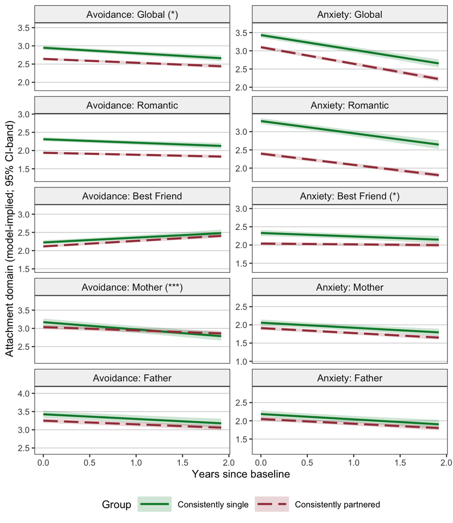

```r
plot_rq2_traject_24m
```

The trajectories look remarkably similar to the 30-month version across all domains! The main analytic difference concerns the significance evaluation for global avoidance and romantic avoidance. However, the trajectories themselves are still highly similar (for the matching time period of the first 24 months, I mean).

#### 6.2.1.7 Full model results

##### 6.2.1.7.1 Single-group models

###### 6.2.1.7.1.1 Avoidance: Global

Full model results for avoidance (global) (in the consistently single people):

```r
broom::tidy(get(paste0("fit_rq2_", outcomes$short[1], "_24m")), conf.int = TRUE, conf.level = 0.95) %>%
  filter(label != "") %>%
  arrange(label) %>%
  select(term = label, est = estimate, ci_lo = conf.low, ci_hi = conf.high, p_value = p.value, est_std = std.all) %>%
  knitr::kable(digits = 3)
```

| term | est | ci_lo | ci_hi | p_value | est_std |
| --- | --- | --- | --- | --- | --- |
| a0 | 2.947 | 2.888 | 3.005 | 0.000 | 4.163 |
| a1 | -0.286 | -0.358 | -0.215 | 0.000 | -0.448 |
| bi | -0.046 | -0.099 | 0.006 | 0.084 | -0.073 |
| bs | 0.029 | -0.034 | 0.093 | 0.362 | 0.051 |
| cis | -0.055 | -0.110 | 0.000 | 0.052 | -0.121 |
| pred_t00 | 2.947 | 2.888 | 3.005 | 0.000 | 4.163 |
| pred_t01 | 2.934 | 2.877 | 2.992 | 0.000 | 4.144 |
| pred_t02 | 2.922 | 2.865 | 2.979 | 0.000 | 4.124 |
| pred_t03 | 2.910 | 2.853 | 2.966 | 0.000 | 4.105 |
| pred_t04 | 2.897 | 2.840 | 2.954 | 0.000 | 4.085 |
| pred_t05 | 2.885 | 2.828 | 2.941 | 0.000 | 4.066 |
| pred_t06 | 2.872 | 2.815 | 2.929 | 0.000 | 4.047 |
| pred_t07 | 2.860 | 2.803 | 2.917 | 0.000 | 4.027 |
| pred_t08 | 2.847 | 2.790 | 2.905 | 0.000 | 4.008 |
| pred_t09 | 2.835 | 2.777 | 2.893 | 0.000 | 3.988 |
| pred_t10 | 2.822 | 2.763 | 2.881 | 0.000 | 3.969 |
| pred_t11 | 2.810 | 2.750 | 2.870 | 0.000 | 3.949 |
| pred_t12 | 2.797 | 2.736 | 2.859 | 0.000 | 3.930 |
| pred_t13 | 2.785 | 2.723 | 2.847 | 0.000 | 3.910 |
| pred_t14 | 2.773 | 2.709 | 2.836 | 0.000 | 3.891 |
| pred_t15 | 2.760 | 2.695 | 2.825 | 0.000 | 3.871 |
| pred_t16 | 2.748 | 2.681 | 2.815 | 0.000 | 3.852 |
| pred_t17 | 2.735 | 2.667 | 2.804 | 0.000 | 3.832 |
| pred_t18 | 2.723 | 2.652 | 2.793 | 0.000 | 3.813 |
| pred_t19 | 2.710 | 2.638 | 2.783 | 0.000 | 3.793 |
| pred_t20 | 2.698 | 2.624 | 2.772 | 0.000 | 3.774 |
| pred_t21 | 2.685 | 2.609 | 2.762 | 0.000 | 3.754 |
| pred_t22 | 2.673 | 2.595 | 2.751 | 0.000 | 3.735 |
| pred_t23 | 2.660 | 2.580 | 2.741 | 0.000 | 3.715 |
| res_00 | 0.194 | 0.168 | 0.220 | 0.000 | 0.279 |
| res_01 | 0.139 | 0.112 | 0.166 | 0.000 | 0.219 |
| res_02 | 0.112 | 0.091 | 0.132 | 0.000 | 0.184 |
| res_03 | 0.132 | 0.109 | 0.156 | 0.000 | 0.212 |
| res_04 | 0.152 | 0.125 | 0.180 | 0.000 | 0.236 |
| res_05 | 0.152 | 0.126 | 0.179 | 0.000 | 0.235 |
| res_06 | 0.151 | 0.124 | 0.178 | 0.000 | 0.232 |
| res_07 | 0.144 | 0.118 | 0.170 | 0.000 | 0.222 |
| res_08 | 0.118 | 0.096 | 0.140 | 0.000 | 0.187 |
| res_09 | 0.110 | 0.089 | 0.131 | 0.000 | 0.175 |
| res_10 | 0.140 | 0.115 | 0.165 | 0.000 | 0.210 |
| res_11 | 0.116 | 0.094 | 0.138 | 0.000 | 0.176 |
| res_12 | 0.107 | 0.086 | 0.128 | 0.000 | 0.162 |
| res_13 | 0.122 | 0.096 | 0.147 | 0.000 | 0.176 |
| res_14 | 0.099 | 0.076 | 0.122 | 0.000 | 0.145 |
| res_15 | 0.099 | 0.074 | 0.124 | 0.000 | 0.141 |
| res_16 | 0.097 | 0.072 | 0.123 | 0.000 | 0.135 |
| res_17 | 0.138 | 0.097 | 0.179 | 0.000 | 0.177 |
| res_18 | 0.126 | 0.088 | 0.165 | 0.000 | 0.160 |
| res_19 | 0.096 | 0.065 | 0.127 | 0.000 | 0.123 |
| res_20 | 0.123 | 0.084 | 0.163 | 0.000 | 0.148 |
| res_21 | 0.117 | 0.078 | 0.156 | 0.000 | 0.137 |
| res_22 | 0.154 | 0.102 | 0.205 | 0.000 | 0.167 |
| res_23 | 0.127 | 0.082 | 0.172 | 0.000 | 0.137 |
| vi | 0.498 | 0.437 | 0.560 | 0.000 | 0.995 |
| vs | 0.408 | 0.320 | 0.495 | 0.000 | 0.997 |

Full model results for avoidance (global) (in the consistently partnered people):

```r
broom::tidy(get(paste0("fit_rq2_", outcomes$short[1], "_partn_c_24m")), conf.int = TRUE, conf.level = 0.95) %>%
  filter(label != "") %>%
  arrange(label) %>%
  select(term = label, est = estimate, ci_lo = conf.low, ci_hi = conf.high, p_value = p.value, est_std = std.all) %>%
  knitr::kable(digits = 3)
```

| term | est | ci_lo | ci_hi | p_value | est_std |
| --- | --- | --- | --- | --- | --- |
| a0 | 2.642 | 2.603 | 2.680 | 0.000 | 3.638 |
| a1 | -0.202 | -0.246 | -0.158 | 0.000 | -0.332 |
| bi | -0.006 | -0.044 | 0.031 | 0.735 | -0.009 |
| bs | 0.009 | -0.032 | 0.051 | 0.668 | 0.015 |
| cis | -0.104 | -0.138 | -0.070 | 0.000 | -0.236 |
| pred_t00 | 2.642 | 2.603 | 2.680 | 0.000 | 3.638 |
| pred_t01 | 2.633 | 2.595 | 2.670 | 0.000 | 3.623 |
| pred_t02 | 2.624 | 2.587 | 2.661 | 0.000 | 3.609 |
| pred_t03 | 2.615 | 2.578 | 2.652 | 0.000 | 3.595 |
| pred_t04 | 2.606 | 2.570 | 2.643 | 0.000 | 3.580 |
| pred_t05 | 2.598 | 2.561 | 2.634 | 0.000 | 3.566 |
| pred_t06 | 2.589 | 2.553 | 2.625 | 0.000 | 3.551 |
| pred_t07 | 2.580 | 2.544 | 2.616 | 0.000 | 3.537 |
| pred_t08 | 2.571 | 2.535 | 2.608 | 0.000 | 3.522 |
| pred_t09 | 2.563 | 2.526 | 2.599 | 0.000 | 3.508 |
| pred_t10 | 2.554 | 2.517 | 2.591 | 0.000 | 3.493 |
| pred_t11 | 2.545 | 2.508 | 2.582 | 0.000 | 3.479 |
| pred_t12 | 2.536 | 2.499 | 2.574 | 0.000 | 3.464 |
| pred_t13 | 2.527 | 2.489 | 2.566 | 0.000 | 3.450 |
| pred_t14 | 2.519 | 2.480 | 2.558 | 0.000 | 3.436 |
| pred_t15 | 2.510 | 2.470 | 2.549 | 0.000 | 3.421 |
| pred_t16 | 2.501 | 2.461 | 2.541 | 0.000 | 3.407 |
| pred_t17 | 2.492 | 2.451 | 2.534 | 0.000 | 3.392 |
| pred_t18 | 2.484 | 2.441 | 2.526 | 0.000 | 3.378 |
| pred_t19 | 2.475 | 2.432 | 2.518 | 0.000 | 3.363 |
| pred_t20 | 2.466 | 2.422 | 2.510 | 0.000 | 3.349 |
| pred_t21 | 2.457 | 2.412 | 2.503 | 0.000 | 3.334 |
| pred_t22 | 2.448 | 2.402 | 2.495 | 0.000 | 3.320 |
| pred_t23 | 2.440 | 2.392 | 2.487 | 0.000 | 3.305 |
| res_00 | 0.187 | 0.171 | 0.204 | 0.000 | 0.262 |
| res_01 | 0.163 | 0.143 | 0.182 | 0.000 | 0.239 |
| res_02 | 0.124 | 0.109 | 0.138 | 0.000 | 0.194 |
| res_03 | 0.125 | 0.110 | 0.140 | 0.000 | 0.198 |
| res_04 | 0.115 | 0.101 | 0.129 | 0.000 | 0.186 |
| res_05 | 0.130 | 0.114 | 0.146 | 0.000 | 0.207 |
| res_06 | 0.149 | 0.131 | 0.167 | 0.000 | 0.230 |
| res_07 | 0.121 | 0.107 | 0.135 | 0.000 | 0.195 |
| res_08 | 0.124 | 0.109 | 0.138 | 0.000 | 0.198 |
| res_09 | 0.120 | 0.105 | 0.134 | 0.000 | 0.192 |
| res_10 | 0.102 | 0.090 | 0.115 | 0.000 | 0.168 |
| res_11 | 0.120 | 0.106 | 0.135 | 0.000 | 0.190 |
| res_12 | 0.104 | 0.092 | 0.117 | 0.000 | 0.168 |
| res_13 | 0.109 | 0.095 | 0.124 | 0.000 | 0.172 |
| res_14 | 0.111 | 0.096 | 0.127 | 0.000 | 0.172 |
| res_15 | 0.097 | 0.082 | 0.112 | 0.000 | 0.150 |
| res_16 | 0.110 | 0.092 | 0.127 | 0.000 | 0.164 |
| res_17 | 0.102 | 0.085 | 0.120 | 0.000 | 0.151 |
| res_18 | 0.084 | 0.068 | 0.100 | 0.000 | 0.124 |
| res_19 | 0.107 | 0.087 | 0.127 | 0.000 | 0.150 |
| res_20 | 0.102 | 0.083 | 0.122 | 0.000 | 0.141 |
| res_21 | 0.087 | 0.069 | 0.105 | 0.000 | 0.119 |
| res_22 | 0.120 | 0.097 | 0.143 | 0.000 | 0.153 |
| res_23 | 0.119 | 0.094 | 0.144 | 0.000 | 0.147 |
| vi | 0.527 | 0.487 | 0.568 | 0.000 | 1.000 |
| vs | 0.369 | 0.319 | 0.419 | 0.000 | 1.000 |

###### 6.2.1.7.1.2 Avoidance: Romantic

Full model results for avoidance (romantic) (in the consistently single people):

```r
broom::tidy(get(paste0("fit_rq2_", outcomes$short[2], "_24m")), conf.int = TRUE, conf.level = 0.95) %>%
  filter(label != "") %>%
  arrange(label) %>%
  select(term = label, est = estimate, ci_lo = conf.low, ci_hi = conf.high, p_value = p.value, est_std = std.all) %>%
  knitr::kable(digits = 3)
```

| term | est | ci_lo | ci_hi | p_value | est_std |
| --- | --- | --- | --- | --- | --- |
| a0 | 2.310 | 2.254 | 2.367 | 0.000 | 3.468 |
| a1 | -0.184 | -0.265 | -0.103 | 0.000 | -0.259 |
| bi | 0.071 | 0.020 | 0.121 | 0.006 | 0.118 |
| bs | -0.077 | -0.148 | -0.006 | 0.034 | -0.120 |
| cis | -0.058 | -0.119 | 0.002 | 0.059 | -0.126 |
| pred_t00 | 2.310 | 2.254 | 2.367 | 0.000 | 3.468 |
| pred_t01 | 2.302 | 2.247 | 2.358 | 0.000 | 3.457 |
| pred_t02 | 2.294 | 2.240 | 2.349 | 0.000 | 3.446 |
| pred_t03 | 2.286 | 2.232 | 2.341 | 0.000 | 3.435 |
| pred_t04 | 2.278 | 2.224 | 2.333 | 0.000 | 3.423 |
| pred_t05 | 2.270 | 2.216 | 2.324 | 0.000 | 3.412 |
| pred_t06 | 2.262 | 2.208 | 2.317 | 0.000 | 3.401 |
| pred_t07 | 2.254 | 2.200 | 2.309 | 0.000 | 3.389 |
| pred_t08 | 2.247 | 2.191 | 2.302 | 0.000 | 3.378 |
| pred_t09 | 2.239 | 2.183 | 2.295 | 0.000 | 3.367 |
| pred_t10 | 2.231 | 2.174 | 2.288 | 0.000 | 3.356 |
| pred_t11 | 2.223 | 2.164 | 2.281 | 0.000 | 3.344 |
| pred_t12 | 2.215 | 2.155 | 2.274 | 0.000 | 3.333 |
| pred_t13 | 2.207 | 2.145 | 2.268 | 0.000 | 3.322 |
| pred_t14 | 2.199 | 2.136 | 2.262 | 0.000 | 3.311 |
| pred_t15 | 2.191 | 2.126 | 2.255 | 0.000 | 3.299 |
| pred_t16 | 2.183 | 2.116 | 2.249 | 0.000 | 3.288 |
| pred_t17 | 2.175 | 2.106 | 2.244 | 0.000 | 3.277 |
| pred_t18 | 2.167 | 2.095 | 2.238 | 0.000 | 3.265 |
| pred_t19 | 2.159 | 2.085 | 2.232 | 0.000 | 3.254 |
| pred_t20 | 2.151 | 2.075 | 2.227 | 0.000 | 3.243 |
| pred_t21 | 2.143 | 2.064 | 2.221 | 0.000 | 3.232 |
| pred_t22 | 2.135 | 2.054 | 2.216 | 0.000 | 3.220 |
| pred_t23 | 2.127 | 2.043 | 2.210 | 0.000 | 3.209 |
| res_00 | 0.335 | 0.291 | 0.378 | 0.000 | 0.430 |
| res_01 | 0.209 | 0.170 | 0.249 | 0.000 | 0.323 |
| res_02 | 0.186 | 0.153 | 0.218 | 0.000 | 0.298 |
| res_03 | 0.162 | 0.133 | 0.191 | 0.000 | 0.271 |
| res_04 | 0.166 | 0.136 | 0.197 | 0.000 | 0.276 |
| res_05 | 0.196 | 0.162 | 0.231 | 0.000 | 0.309 |
| res_06 | 0.173 | 0.142 | 0.205 | 0.000 | 0.281 |
| res_07 | 0.190 | 0.156 | 0.224 | 0.000 | 0.296 |
| res_08 | 0.157 | 0.128 | 0.187 | 0.000 | 0.255 |
| res_09 | 0.159 | 0.129 | 0.189 | 0.000 | 0.253 |
| res_10 | 0.131 | 0.106 | 0.156 | 0.000 | 0.214 |
| res_11 | 0.165 | 0.134 | 0.196 | 0.000 | 0.250 |
| res_12 | 0.152 | 0.122 | 0.182 | 0.000 | 0.229 |
| res_13 | 0.138 | 0.109 | 0.166 | 0.000 | 0.206 |
| res_14 | 0.128 | 0.099 | 0.156 | 0.000 | 0.188 |
| res_15 | 0.119 | 0.090 | 0.147 | 0.000 | 0.172 |
| res_16 | 0.121 | 0.089 | 0.152 | 0.000 | 0.168 |
| res_17 | 0.131 | 0.092 | 0.170 | 0.000 | 0.174 |
| res_18 | 0.084 | 0.057 | 0.111 | 0.000 | 0.115 |
| res_19 | 0.085 | 0.057 | 0.113 | 0.000 | 0.111 |
| res_20 | 0.086 | 0.056 | 0.115 | 0.000 | 0.108 |
| res_21 | 0.105 | 0.069 | 0.141 | 0.000 | 0.124 |
| res_22 | 0.116 | 0.074 | 0.158 | 0.000 | 0.130 |
| res_23 | 0.217 | 0.140 | 0.293 | 0.000 | 0.210 |
| vi | 0.438 | 0.381 | 0.495 | 0.000 | 0.986 |
| vs | 0.495 | 0.381 | 0.608 | 0.000 | 0.986 |

Full model results for avoidance (romantic) (in the consistently partnered people):

```r
broom::tidy(get(paste0("fit_rq2_", outcomes$short[2], "_partn_c_24m")), conf.int = TRUE, conf.level = 0.95) %>%
  filter(label != "") %>%
  arrange(label) %>%
  select(term = label, est = estimate, ci_lo = conf.low, ci_hi = conf.high, p_value = p.value, est_std = std.all) %>%
  knitr::kable(digits = 3)
```

| term | est | ci_lo | ci_hi | p_value | est_std |
| --- | --- | --- | --- | --- | --- |
| a0 | 1.939 | 1.902 | 1.976 | 0.000 | 2.682 |
| a1 | -0.105 | -0.150 | -0.059 | 0.000 | -0.164 |
| bi | 0.183 | 0.146 | 0.219 | 0.000 | 0.253 |
| bs | 0.021 | -0.022 | 0.064 | 0.349 | 0.032 |
| cis | -0.106 | -0.140 | -0.072 | 0.000 | -0.238 |
| pred_t00 | 1.939 | 1.902 | 1.976 | 0.000 | 2.682 |
| pred_t01 | 1.934 | 1.898 | 1.971 | 0.000 | 2.675 |
| pred_t02 | 1.930 | 1.894 | 1.966 | 0.000 | 2.668 |
| pred_t03 | 1.925 | 1.890 | 1.961 | 0.000 | 2.661 |
| pred_t04 | 1.921 | 1.885 | 1.956 | 0.000 | 2.653 |
| pred_t05 | 1.916 | 1.881 | 1.951 | 0.000 | 2.646 |
| pred_t06 | 1.912 | 1.877 | 1.946 | 0.000 | 2.639 |
| pred_t07 | 1.907 | 1.872 | 1.942 | 0.000 | 2.632 |
| pred_t08 | 1.902 | 1.867 | 1.938 | 0.000 | 2.625 |
| pred_t09 | 1.898 | 1.863 | 1.933 | 0.000 | 2.618 |
| pred_t10 | 1.893 | 1.858 | 1.929 | 0.000 | 2.611 |
| pred_t11 | 1.889 | 1.853 | 1.925 | 0.000 | 2.603 |
| pred_t12 | 1.884 | 1.848 | 1.921 | 0.000 | 2.596 |
| pred_t13 | 1.880 | 1.842 | 1.917 | 0.000 | 2.589 |
| pred_t14 | 1.875 | 1.837 | 1.913 | 0.000 | 2.582 |
| pred_t15 | 1.871 | 1.832 | 1.910 | 0.000 | 2.575 |
| pred_t16 | 1.866 | 1.826 | 1.906 | 0.000 | 2.568 |
| pred_t17 | 1.862 | 1.821 | 1.902 | 0.000 | 2.561 |
| pred_t18 | 1.857 | 1.815 | 1.899 | 0.000 | 2.554 |
| pred_t19 | 1.852 | 1.809 | 1.895 | 0.000 | 2.546 |
| pred_t20 | 1.848 | 1.804 | 1.892 | 0.000 | 2.539 |
| pred_t21 | 1.843 | 1.798 | 1.889 | 0.000 | 2.532 |
| pred_t22 | 1.839 | 1.792 | 1.885 | 0.000 | 2.525 |
| pred_t23 | 1.834 | 1.786 | 1.882 | 0.000 | 2.518 |
| res_00 | 0.201 | 0.184 | 0.219 | 0.000 | 0.278 |
| res_01 | 0.143 | 0.125 | 0.160 | 0.000 | 0.217 |
| res_02 | 0.144 | 0.128 | 0.161 | 0.000 | 0.221 |
| res_03 | 0.129 | 0.114 | 0.144 | 0.000 | 0.205 |
| res_04 | 0.135 | 0.119 | 0.151 | 0.000 | 0.213 |
| res_05 | 0.139 | 0.122 | 0.155 | 0.000 | 0.218 |
| res_06 | 0.149 | 0.131 | 0.167 | 0.000 | 0.231 |
| res_07 | 0.118 | 0.104 | 0.132 | 0.000 | 0.191 |
| res_08 | 0.126 | 0.111 | 0.141 | 0.000 | 0.201 |
| res_09 | 0.129 | 0.113 | 0.144 | 0.000 | 0.203 |
| res_10 | 0.110 | 0.097 | 0.124 | 0.000 | 0.178 |
| res_11 | 0.112 | 0.098 | 0.126 | 0.000 | 0.178 |
| res_12 | 0.132 | 0.116 | 0.148 | 0.000 | 0.200 |
| res_13 | 0.093 | 0.081 | 0.106 | 0.000 | 0.148 |
| res_14 | 0.120 | 0.104 | 0.137 | 0.000 | 0.180 |
| res_15 | 0.099 | 0.083 | 0.115 | 0.000 | 0.150 |
| res_16 | 0.119 | 0.100 | 0.139 | 0.000 | 0.172 |
| res_17 | 0.144 | 0.120 | 0.168 | 0.000 | 0.195 |
| res_18 | 0.105 | 0.086 | 0.124 | 0.000 | 0.146 |
| res_19 | 0.095 | 0.077 | 0.113 | 0.000 | 0.131 |
| res_20 | 0.098 | 0.079 | 0.118 | 0.000 | 0.131 |
| res_21 | 0.093 | 0.074 | 0.112 | 0.000 | 0.121 |
| res_22 | 0.099 | 0.079 | 0.119 | 0.000 | 0.124 |
| res_23 | 0.096 | 0.074 | 0.117 | 0.000 | 0.117 |
| vi | 0.489 | 0.451 | 0.527 | 0.000 | 0.936 |
| vs | 0.406 | 0.350 | 0.462 | 0.000 | 0.999 |

###### 6.2.1.7.1.3 Avoidance: Best Friend

Full model results for avoidance (best friend) (in the consistently single people):

```r
broom::tidy(get(paste0("fit_rq2_", outcomes$short[3], "_24m")), conf.int = TRUE, conf.level = 0.95) %>%
  filter(label != "") %>%
  arrange(label) %>%
  select(term = label, est = estimate, ci_lo = conf.low, ci_hi = conf.high, p_value = p.value, est_std = std.all) %>%
  knitr::kable(digits = 3)
```

| term | est | ci_lo | ci_hi | p_value | est_std |
| --- | --- | --- | --- | --- | --- |
| a0 | 2.225 | 2.164 | 2.285 | 0.000 | 3.109 |
| a1 | 0.255 | 0.158 | 0.352 | 0.000 | 0.278 |
| bi | -0.028 | -0.083 | 0.026 | 0.307 | -0.044 |
| bs | -0.089 | -0.174 | -0.003 | 0.043 | -0.107 |
| cis | -0.108 | -0.185 | -0.032 | 0.005 | -0.166 |
| pred_t00 | 2.225 | 2.164 | 2.285 | 0.000 | 3.109 |
| pred_t01 | 2.236 | 2.176 | 2.295 | 0.000 | 3.121 |
| pred_t02 | 2.247 | 2.188 | 2.305 | 0.000 | 3.133 |
| pred_t03 | 2.258 | 2.200 | 2.316 | 0.000 | 3.145 |
| pred_t04 | 2.269 | 2.211 | 2.327 | 0.000 | 3.157 |
| pred_t05 | 2.280 | 2.222 | 2.338 | 0.000 | 3.169 |
| pred_t06 | 2.291 | 2.233 | 2.349 | 0.000 | 3.181 |
| pred_t07 | 2.302 | 2.243 | 2.361 | 0.000 | 3.193 |
| pred_t08 | 2.313 | 2.253 | 2.373 | 0.000 | 3.205 |
| pred_t09 | 2.324 | 2.263 | 2.385 | 0.000 | 3.218 |
| pred_t10 | 2.335 | 2.273 | 2.398 | 0.000 | 3.230 |
| pred_t11 | 2.347 | 2.282 | 2.411 | 0.000 | 3.242 |
| pred_t12 | 2.358 | 2.291 | 2.424 | 0.000 | 3.254 |
| pred_t13 | 2.369 | 2.300 | 2.437 | 0.000 | 3.266 |
| pred_t14 | 2.380 | 2.309 | 2.451 | 0.000 | 3.278 |
| pred_t15 | 2.391 | 2.318 | 2.464 | 0.000 | 3.290 |
| pred_t16 | 2.402 | 2.326 | 2.478 | 0.000 | 3.302 |
| pred_t17 | 2.413 | 2.334 | 2.492 | 0.000 | 3.314 |
| pred_t18 | 2.424 | 2.343 | 2.506 | 0.000 | 3.326 |
| pred_t19 | 2.435 | 2.351 | 2.520 | 0.000 | 3.339 |
| pred_t20 | 2.446 | 2.359 | 2.534 | 0.000 | 3.351 |
| pred_t21 | 2.458 | 2.366 | 2.549 | 0.000 | 3.363 |
| pred_t22 | 2.469 | 2.374 | 2.563 | 0.000 | 3.375 |
| pred_t23 | 2.480 | 2.382 | 2.578 | 0.000 | 3.387 |
| res_00 | 0.272 | 0.234 | 0.310 | 0.000 | 0.347 |
| res_01 | 0.193 | 0.156 | 0.231 | 0.000 | 0.277 |
| res_02 | 0.152 | 0.124 | 0.180 | 0.000 | 0.233 |
| res_03 | 0.179 | 0.147 | 0.211 | 0.000 | 0.264 |
| res_04 | 0.229 | 0.187 | 0.271 | 0.000 | 0.314 |
| res_05 | 0.195 | 0.160 | 0.230 | 0.000 | 0.278 |
| res_06 | 0.186 | 0.152 | 0.220 | 0.000 | 0.266 |
| res_07 | 0.207 | 0.170 | 0.244 | 0.000 | 0.283 |
| res_08 | 0.210 | 0.171 | 0.249 | 0.000 | 0.280 |
| res_09 | 0.175 | 0.141 | 0.208 | 0.000 | 0.238 |
| res_10 | 0.147 | 0.119 | 0.174 | 0.000 | 0.202 |
| res_11 | 0.181 | 0.146 | 0.216 | 0.000 | 0.231 |
| res_12 | 0.183 | 0.146 | 0.219 | 0.000 | 0.224 |
| res_13 | 0.116 | 0.091 | 0.142 | 0.000 | 0.150 |
| res_14 | 0.200 | 0.156 | 0.244 | 0.000 | 0.223 |
| res_15 | 0.240 | 0.185 | 0.295 | 0.000 | 0.247 |
| res_16 | 0.186 | 0.139 | 0.234 | 0.000 | 0.194 |
| res_17 | 0.174 | 0.123 | 0.225 | 0.000 | 0.176 |
| res_18 | 0.182 | 0.126 | 0.238 | 0.000 | 0.174 |
| res_19 | 0.157 | 0.106 | 0.209 | 0.000 | 0.147 |
| res_20 | 0.203 | 0.137 | 0.270 | 0.000 | 0.174 |
| res_21 | 0.177 | 0.112 | 0.243 | 0.000 | 0.148 |
| res_22 | 0.382 | 0.255 | 0.509 | 0.000 | 0.261 |
| res_23 | 0.271 | 0.177 | 0.365 | 0.000 | 0.192 |
| vi | 0.511 | 0.446 | 0.576 | 0.000 | 0.998 |
| vs | 0.831 | 0.656 | 1.007 | 0.000 | 0.989 |

Full model results for avoidance (best friend) (in the consistently partnered people):

```r
broom::tidy(get(paste0("fit_rq2_", outcomes$short[3], "_partn_c_24m")), conf.int = TRUE, conf.level = 0.95) %>%
  filter(label != "") %>%
  arrange(label) %>%
  select(term = label, est = estimate, ci_lo = conf.low, ci_hi = conf.high, p_value = p.value, est_std = std.all) %>%
  knitr::kable(digits = 3)
```

| term | est | ci_lo | ci_hi | p_value | est_std |
| --- | --- | --- | --- | --- | --- |
| a0 | 2.117 | 2.080 | 2.153 | 0.000 | 3.106 |
| a1 | 0.289 | 0.231 | 0.347 | 0.000 | 0.322 |
| bi | 0.014 | -0.022 | 0.050 | 0.441 | 0.021 |
| bs | -0.047 | -0.102 | 0.009 | 0.099 | -0.052 |
| cis | -0.151 | -0.194 | -0.108 | 0.000 | -0.247 |
| pred_t00 | 2.117 | 2.080 | 2.153 | 0.000 | 3.106 |
| pred_t01 | 2.129 | 2.093 | 2.165 | 0.000 | 3.120 |
| pred_t02 | 2.142 | 2.107 | 2.177 | 0.000 | 3.134 |
| pred_t03 | 2.154 | 2.120 | 2.189 | 0.000 | 3.148 |
| pred_t04 | 2.167 | 2.132 | 2.201 | 0.000 | 3.162 |
| pred_t05 | 2.179 | 2.145 | 2.214 | 0.000 | 3.176 |
| pred_t06 | 2.192 | 2.158 | 2.226 | 0.000 | 3.190 |
| pred_t07 | 2.205 | 2.170 | 2.239 | 0.000 | 3.204 |
| pred_t08 | 2.217 | 2.182 | 2.252 | 0.000 | 3.218 |
| pred_t09 | 2.230 | 2.194 | 2.265 | 0.000 | 3.232 |
| pred_t10 | 2.242 | 2.206 | 2.279 | 0.000 | 3.246 |
| pred_t11 | 2.255 | 2.217 | 2.292 | 0.000 | 3.260 |
| pred_t12 | 2.267 | 2.229 | 2.306 | 0.000 | 3.274 |
| pred_t13 | 2.280 | 2.240 | 2.320 | 0.000 | 3.288 |
| pred_t14 | 2.293 | 2.251 | 2.334 | 0.000 | 3.302 |
| pred_t15 | 2.305 | 2.262 | 2.348 | 0.000 | 3.315 |
| pred_t16 | 2.318 | 2.274 | 2.362 | 0.000 | 3.329 |
| pred_t17 | 2.330 | 2.284 | 2.376 | 0.000 | 3.343 |
| pred_t18 | 2.343 | 2.295 | 2.390 | 0.000 | 3.357 |
| pred_t19 | 2.355 | 2.306 | 2.405 | 0.000 | 3.371 |
| pred_t20 | 2.368 | 2.317 | 2.419 | 0.000 | 3.385 |
| pred_t21 | 2.380 | 2.328 | 2.433 | 0.000 | 3.399 |
| pred_t22 | 2.393 | 2.338 | 2.448 | 0.000 | 3.413 |
| pred_t23 | 2.406 | 2.349 | 2.463 | 0.000 | 3.427 |
| res_00 | 0.225 | 0.206 | 0.245 | 0.000 | 0.327 |
| res_01 | 0.124 | 0.108 | 0.140 | 0.000 | 0.215 |
| res_02 | 0.118 | 0.104 | 0.133 | 0.000 | 0.210 |
| res_03 | 0.126 | 0.111 | 0.142 | 0.000 | 0.224 |
| res_04 | 0.135 | 0.118 | 0.151 | 0.000 | 0.236 |
| res_05 | 0.165 | 0.146 | 0.185 | 0.000 | 0.275 |
| res_06 | 0.171 | 0.150 | 0.193 | 0.000 | 0.280 |
| res_07 | 0.163 | 0.145 | 0.182 | 0.000 | 0.268 |
| res_08 | 0.129 | 0.113 | 0.144 | 0.000 | 0.220 |
| res_09 | 0.121 | 0.106 | 0.136 | 0.000 | 0.204 |
| res_10 | 0.140 | 0.122 | 0.157 | 0.000 | 0.223 |
| res_11 | 0.124 | 0.109 | 0.140 | 0.000 | 0.198 |
| res_12 | 0.128 | 0.112 | 0.144 | 0.000 | 0.196 |
| res_13 | 0.124 | 0.107 | 0.141 | 0.000 | 0.184 |
| res_14 | 0.137 | 0.117 | 0.156 | 0.000 | 0.191 |
| res_15 | 0.138 | 0.116 | 0.159 | 0.000 | 0.184 |
| res_16 | 0.158 | 0.132 | 0.183 | 0.000 | 0.197 |
| res_17 | 0.188 | 0.157 | 0.219 | 0.000 | 0.216 |
| res_18 | 0.142 | 0.116 | 0.168 | 0.000 | 0.164 |
| res_19 | 0.146 | 0.119 | 0.173 | 0.000 | 0.161 |
| res_20 | 0.116 | 0.093 | 0.139 | 0.000 | 0.125 |
| res_21 | 0.093 | 0.073 | 0.114 | 0.000 | 0.098 |
| res_22 | 0.166 | 0.132 | 0.199 | 0.000 | 0.154 |
| res_23 | 0.106 | 0.082 | 0.130 | 0.000 | 0.098 |
| vi | 0.464 | 0.428 | 0.501 | 0.000 | 1.000 |
| vs | 0.804 | 0.713 | 0.896 | 0.000 | 0.997 |

###### 6.2.1.7.1.4 Avoidance: Mother

Full model results for avoidance (mother) (in the consistently single people):

```r
broom::tidy(get(paste0("fit_rq2_", outcomes$short[4], "_24m")), conf.int = TRUE, conf.level = 0.95) %>%
  filter(label != "") %>%
  arrange(label) %>%
  select(term = label, est = estimate, ci_lo = conf.low, ci_hi = conf.high, p_value = p.value, est_std = std.all) %>%
  knitr::kable(digits = 3)
```

| term | est | ci_lo | ci_hi | p_value | est_std |
| --- | --- | --- | --- | --- | --- |
| a0 | 3.171 | 3.072 | 3.269 | 0.000 | 2.888 |
| a1 | -0.384 | -0.491 | -0.276 | 0.000 | -0.398 |
| bi | 0.182 | 0.078 | 0.286 | 0.001 | 0.149 |
| bs | -0.092 | -0.207 | 0.022 | 0.114 | -0.086 |
| cis | -0.288 | -0.408 | -0.169 | 0.000 | -0.276 |
| pred_t00 | 3.171 | 3.072 | 3.269 | 0.000 | 2.888 |
| pred_t01 | 3.154 | 3.057 | 3.251 | 0.000 | 2.870 |
| pred_t02 | 3.137 | 3.042 | 3.233 | 0.000 | 2.853 |
| pred_t03 | 3.121 | 3.026 | 3.215 | 0.000 | 2.836 |
| pred_t04 | 3.104 | 3.010 | 3.198 | 0.000 | 2.818 |
| pred_t05 | 3.087 | 2.994 | 3.181 | 0.000 | 2.801 |
| pred_t06 | 3.071 | 2.977 | 3.164 | 0.000 | 2.784 |
| pred_t07 | 3.054 | 2.961 | 3.147 | 0.000 | 2.767 |
| pred_t08 | 3.037 | 2.944 | 3.131 | 0.000 | 2.749 |
| pred_t09 | 3.021 | 2.927 | 3.114 | 0.000 | 2.732 |
| pred_t10 | 3.004 | 2.909 | 3.098 | 0.000 | 2.715 |
| pred_t11 | 2.987 | 2.892 | 3.083 | 0.000 | 2.697 |
| pred_t12 | 2.971 | 2.874 | 3.067 | 0.000 | 2.680 |
| pred_t13 | 2.954 | 2.856 | 3.052 | 0.000 | 2.663 |
| pred_t14 | 2.937 | 2.838 | 3.036 | 0.000 | 2.645 |
| pred_t15 | 2.920 | 2.820 | 3.021 | 0.000 | 2.628 |
| pred_t16 | 2.904 | 2.801 | 3.007 | 0.000 | 2.611 |
| pred_t17 | 2.887 | 2.782 | 2.992 | 0.000 | 2.594 |
| pred_t18 | 2.870 | 2.763 | 2.977 | 0.000 | 2.576 |
| pred_t19 | 2.854 | 2.744 | 2.963 | 0.000 | 2.559 |
| pred_t20 | 2.837 | 2.725 | 2.949 | 0.000 | 2.542 |
| pred_t21 | 2.820 | 2.706 | 2.935 | 0.000 | 2.524 |
| pred_t22 | 2.804 | 2.686 | 2.921 | 0.000 | 2.507 |
| pred_t23 | 2.787 | 2.667 | 2.907 | 0.000 | 2.490 |
| res_00 | 0.258 | 0.219 | 0.296 | 0.000 | 0.176 |
| res_01 | 0.167 | 0.130 | 0.203 | 0.000 | 0.124 |
| res_02 | 0.178 | 0.145 | 0.211 | 0.000 | 0.133 |
| res_03 | 0.175 | 0.141 | 0.208 | 0.000 | 0.133 |
| res_04 | 0.146 | 0.117 | 0.174 | 0.000 | 0.114 |
| res_05 | 0.176 | 0.142 | 0.209 | 0.000 | 0.136 |
| res_06 | 0.151 | 0.122 | 0.180 | 0.000 | 0.120 |
| res_07 | 0.124 | 0.100 | 0.149 | 0.000 | 0.101 |
| res_08 | 0.140 | 0.113 | 0.168 | 0.000 | 0.112 |
| res_09 | 0.121 | 0.097 | 0.145 | 0.000 | 0.098 |
| res_10 | 0.120 | 0.096 | 0.143 | 0.000 | 0.097 |
| res_11 | 0.155 | 0.124 | 0.186 | 0.000 | 0.121 |
| res_12 | 0.120 | 0.095 | 0.146 | 0.000 | 0.095 |
| res_13 | 0.089 | 0.067 | 0.110 | 0.000 | 0.071 |
| res_14 | 0.083 | 0.062 | 0.104 | 0.000 | 0.065 |
| res_15 | 0.094 | 0.068 | 0.121 | 0.000 | 0.073 |
| res_16 | 0.117 | 0.084 | 0.149 | 0.000 | 0.086 |
| res_17 | 0.085 | 0.056 | 0.113 | 0.000 | 0.063 |
| res_18 | 0.152 | 0.103 | 0.202 | 0.000 | 0.105 |
| res_19 | 0.178 | 0.119 | 0.238 | 0.000 | 0.117 |
| res_20 | 0.103 | 0.064 | 0.143 | 0.000 | 0.069 |
| res_21 | 0.155 | 0.100 | 0.211 | 0.000 | 0.098 |
| res_22 | 0.117 | 0.070 | 0.165 | 0.000 | 0.073 |
| res_23 | 0.124 | 0.074 | 0.175 | 0.000 | 0.075 |
| vi | 1.179 | 1.031 | 1.327 | 0.000 | 0.978 |
| vs | 0.924 | 0.750 | 1.098 | 0.000 | 0.993 |

Full model results for avoidance (mother) (in the consistently partnered people):

```r
broom::tidy(get(paste0("fit_rq2_", outcomes$short[4], "_partn_c_24m")), conf.int = TRUE, conf.level = 0.95) %>%
  filter(label != "") %>%
  arrange(label) %>%
  select(term = label, est = estimate, ci_lo = conf.low, ci_hi = conf.high, p_value = p.value, est_std = std.all) %>%
  knitr::kable(digits = 3)
```

| term | est | ci_lo | ci_hi | p_value | est_std |
| --- | --- | --- | --- | --- | --- |
| a0 | 3.036 | 2.976 | 3.096 | 0.000 | 2.698 |
| a1 | -0.175 | -0.229 | -0.120 | 0.000 | -0.224 |
| bi | 0.192 | 0.120 | 0.263 | 0.000 | 0.144 |
| bs | 0.031 | -0.033 | 0.094 | 0.344 | 0.033 |
| cis | -0.206 | -0.270 | -0.141 | 0.000 | -0.237 |
| pred_t00 | 3.036 | 2.976 | 3.096 | 0.000 | 2.698 |
| pred_t01 | 3.028 | 2.969 | 3.088 | 0.000 | 2.688 |
| pred_t02 | 3.021 | 2.961 | 3.080 | 0.000 | 2.678 |
| pred_t03 | 3.013 | 2.954 | 3.072 | 0.000 | 2.669 |
| pred_t04 | 3.006 | 2.947 | 3.064 | 0.000 | 2.659 |
| pred_t05 | 2.998 | 2.940 | 3.056 | 0.000 | 2.649 |
| pred_t06 | 2.990 | 2.932 | 3.048 | 0.000 | 2.639 |
| pred_t07 | 2.983 | 2.925 | 3.041 | 0.000 | 2.630 |
| pred_t08 | 2.975 | 2.917 | 3.033 | 0.000 | 2.620 |
| pred_t09 | 2.968 | 2.909 | 3.026 | 0.000 | 2.610 |
| pred_t10 | 2.960 | 2.902 | 3.018 | 0.000 | 2.600 |
| pred_t11 | 2.952 | 2.894 | 3.011 | 0.000 | 2.591 |
| pred_t12 | 2.945 | 2.886 | 3.004 | 0.000 | 2.581 |
| pred_t13 | 2.937 | 2.878 | 2.997 | 0.000 | 2.571 |
| pred_t14 | 2.930 | 2.869 | 2.990 | 0.000 | 2.562 |
| pred_t15 | 2.922 | 2.861 | 2.983 | 0.000 | 2.552 |
| pred_t16 | 2.914 | 2.853 | 2.976 | 0.000 | 2.542 |
| pred_t17 | 2.907 | 2.844 | 2.969 | 0.000 | 2.532 |
| pred_t18 | 2.899 | 2.836 | 2.963 | 0.000 | 2.523 |
| pred_t19 | 2.892 | 2.827 | 2.956 | 0.000 | 2.513 |
| pred_t20 | 2.884 | 2.818 | 2.949 | 0.000 | 2.503 |
| pred_t21 | 2.876 | 2.810 | 2.943 | 0.000 | 2.493 |
| pred_t22 | 2.869 | 2.801 | 2.937 | 0.000 | 2.484 |
| pred_t23 | 2.861 | 2.792 | 2.930 | 0.000 | 2.474 |
| res_00 | 0.207 | 0.187 | 0.227 | 0.000 | 0.140 |
| res_01 | 0.150 | 0.130 | 0.170 | 0.000 | 0.107 |
| res_02 | 0.124 | 0.108 | 0.140 | 0.000 | 0.091 |
| res_03 | 0.139 | 0.122 | 0.157 | 0.000 | 0.102 |
| res_04 | 0.124 | 0.108 | 0.140 | 0.000 | 0.093 |
| res_05 | 0.122 | 0.105 | 0.138 | 0.000 | 0.092 |
| res_06 | 0.144 | 0.125 | 0.163 | 0.000 | 0.107 |
| res_07 | 0.104 | 0.091 | 0.118 | 0.000 | 0.080 |
| res_08 | 0.129 | 0.112 | 0.146 | 0.000 | 0.097 |
| res_09 | 0.128 | 0.111 | 0.144 | 0.000 | 0.096 |
| res_10 | 0.121 | 0.105 | 0.137 | 0.000 | 0.091 |
| res_11 | 0.111 | 0.097 | 0.126 | 0.000 | 0.084 |
| res_12 | 0.099 | 0.085 | 0.112 | 0.000 | 0.075 |
| res_13 | 0.123 | 0.105 | 0.141 | 0.000 | 0.091 |
| res_14 | 0.126 | 0.107 | 0.146 | 0.000 | 0.092 |
| res_15 | 0.104 | 0.087 | 0.122 | 0.000 | 0.076 |
| res_16 | 0.130 | 0.107 | 0.152 | 0.000 | 0.092 |
| res_17 | 0.095 | 0.077 | 0.112 | 0.000 | 0.068 |
| res_18 | 0.085 | 0.068 | 0.103 | 0.000 | 0.060 |
| res_19 | 0.108 | 0.087 | 0.130 | 0.000 | 0.074 |
| res_20 | 0.071 | 0.055 | 0.087 | 0.000 | 0.049 |
| res_21 | 0.088 | 0.068 | 0.108 | 0.000 | 0.059 |
| res_22 | 0.134 | 0.106 | 0.161 | 0.000 | 0.085 |
| res_23 | 0.106 | 0.082 | 0.130 | 0.000 | 0.067 |
| vi | 1.240 | 1.143 | 1.337 | 0.000 | 0.979 |
| vs | 0.608 | 0.529 | 0.688 | 0.000 | 0.999 |

###### 6.2.1.7.1.5 Avoidance: Father

Full model results for avoidance (father) (in the consistently single people):

```r
broom::tidy(get(paste0("fit_rq2_", outcomes$short[5], "_24m")), conf.int = TRUE, conf.level = 0.95) %>%
  filter(label != "") %>%
  arrange(label) %>%
  select(term = label, est = estimate, ci_lo = conf.low, ci_hi = conf.high, p_value = p.value, est_std = std.all) %>%
  knitr::kable(digits = 3)
```

| term | est | ci_lo | ci_hi | p_value | est_std |
| --- | --- | --- | --- | --- | --- |
| a0 | 3.426 | 3.326 | 3.525 | 0.000 | 3.428 |
| a1 | -0.248 | -0.351 | -0.145 | 0.000 | -0.310 |
| bi | 0.032 | -0.076 | 0.140 | 0.559 | 0.027 |
| bs | 0.007 | -0.106 | 0.119 | 0.906 | 0.007 |
| cis | -0.110 | -0.209 | -0.012 | 0.029 | -0.138 |
| pred_t00 | 3.426 | 3.326 | 3.525 | 0.000 | 3.428 |
| pred_t01 | 3.415 | 3.316 | 3.514 | 0.000 | 3.415 |
| pred_t02 | 3.404 | 3.306 | 3.502 | 0.000 | 3.401 |
| pred_t03 | 3.393 | 3.296 | 3.491 | 0.000 | 3.388 |
| pred_t04 | 3.382 | 3.285 | 3.480 | 0.000 | 3.374 |
| pred_t05 | 3.372 | 3.274 | 3.469 | 0.000 | 3.361 |
| pred_t06 | 3.361 | 3.263 | 3.458 | 0.000 | 3.347 |
| pred_t07 | 3.350 | 3.252 | 3.448 | 0.000 | 3.334 |
| pred_t08 | 3.339 | 3.241 | 3.438 | 0.000 | 3.320 |
| pred_t09 | 3.329 | 3.229 | 3.428 | 0.000 | 3.307 |
| pred_t10 | 3.318 | 3.218 | 3.418 | 0.000 | 3.293 |
| pred_t11 | 3.307 | 3.206 | 3.408 | 0.000 | 3.280 |
| pred_t12 | 3.296 | 3.193 | 3.399 | 0.000 | 3.266 |
| pred_t13 | 3.285 | 3.181 | 3.390 | 0.000 | 3.253 |
| pred_t14 | 3.275 | 3.169 | 3.381 | 0.000 | 3.239 |
| pred_t15 | 3.264 | 3.156 | 3.372 | 0.000 | 3.226 |
| pred_t16 | 3.253 | 3.143 | 3.363 | 0.000 | 3.212 |
| pred_t17 | 3.242 | 3.130 | 3.354 | 0.000 | 3.199 |
| pred_t18 | 3.231 | 3.117 | 3.346 | 0.000 | 3.185 |
| pred_t19 | 3.221 | 3.104 | 3.337 | 0.000 | 3.172 |
| pred_t20 | 3.210 | 3.091 | 3.329 | 0.000 | 3.159 |
| pred_t21 | 3.199 | 3.077 | 3.321 | 0.000 | 3.145 |
| pred_t22 | 3.188 | 3.064 | 3.313 | 0.000 | 3.132 |
| pred_t23 | 3.178 | 3.050 | 3.305 | 0.000 | 3.118 |
| res_00 | 0.217 | 0.183 | 0.251 | 0.000 | 0.178 |
| res_01 | 0.124 | 0.095 | 0.152 | 0.000 | 0.111 |
| res_02 | 0.106 | 0.083 | 0.128 | 0.000 | 0.097 |
| res_03 | 0.152 | 0.122 | 0.183 | 0.000 | 0.134 |
| res_04 | 0.148 | 0.117 | 0.179 | 0.000 | 0.131 |
| res_05 | 0.123 | 0.097 | 0.148 | 0.000 | 0.111 |
| res_06 | 0.133 | 0.106 | 0.161 | 0.000 | 0.119 |
| res_07 | 0.173 | 0.138 | 0.207 | 0.000 | 0.148 |
| res_08 | 0.128 | 0.101 | 0.155 | 0.000 | 0.114 |
| res_09 | 0.122 | 0.096 | 0.149 | 0.000 | 0.108 |
| res_10 | 0.112 | 0.088 | 0.135 | 0.000 | 0.098 |
| res_11 | 0.122 | 0.095 | 0.149 | 0.000 | 0.105 |
| res_12 | 0.077 | 0.059 | 0.096 | 0.000 | 0.068 |
| res_13 | 0.079 | 0.059 | 0.100 | 0.000 | 0.069 |
| res_14 | 0.109 | 0.080 | 0.139 | 0.000 | 0.090 |
| res_15 | 0.093 | 0.066 | 0.120 | 0.000 | 0.076 |
| res_16 | 0.122 | 0.086 | 0.158 | 0.000 | 0.096 |
| res_17 | 0.071 | 0.045 | 0.098 | 0.000 | 0.057 |
| res_18 | 0.112 | 0.072 | 0.151 | 0.000 | 0.084 |
| res_19 | 0.076 | 0.048 | 0.105 | 0.000 | 0.057 |
| res_20 | 0.101 | 0.063 | 0.139 | 0.000 | 0.073 |
| res_21 | 0.097 | 0.059 | 0.134 | 0.000 | 0.068 |
| res_22 | 0.048 | 0.023 | 0.074 | 0.000 | 0.034 |
| res_23 | 0.072 | 0.040 | 0.104 | 0.000 | 0.048 |
| vi | 0.998 | 0.865 | 1.130 | 0.000 | 0.999 |
| vs | 0.639 | 0.504 | 0.774 | 0.000 | 1.000 |

Full model results for avoidance (father) (in the consistently partnered people):

```r
broom::tidy(get(paste0("fit_rq2_", outcomes$short[5], "_partn_c_24m")), conf.int = TRUE, conf.level = 0.95) %>%
  filter(label != "") %>%
  arrange(label) %>%
  select(term = label, est = estimate, ci_lo = conf.low, ci_hi = conf.high, p_value = p.value, est_std = std.all) %>%
  knitr::kable(digits = 3)
```

| term | est | ci_lo | ci_hi | p_value | est_std |
| --- | --- | --- | --- | --- | --- |
| a0 | 3.250 | 3.189 | 3.311 | 0.000 | 3.040 |
| a1 | -0.192 | -0.250 | -0.133 | 0.000 | -0.243 |
| bi | 0.106 | 0.028 | 0.184 | 0.007 | 0.078 |
| bs | 0.088 | 0.013 | 0.163 | 0.021 | 0.087 |
| cis | -0.165 | -0.230 | -0.100 | 0.000 | -0.198 |
| pred_t00 | 3.250 | 3.189 | 3.311 | 0.000 | 3.040 |
| pred_t01 | 3.242 | 3.181 | 3.302 | 0.000 | 3.030 |
| pred_t02 | 3.233 | 3.173 | 3.293 | 0.000 | 3.019 |
| pred_t03 | 3.225 | 3.165 | 3.284 | 0.000 | 3.008 |
| pred_t04 | 3.217 | 3.157 | 3.276 | 0.000 | 2.998 |
| pred_t05 | 3.208 | 3.149 | 3.267 | 0.000 | 2.987 |
| pred_t06 | 3.200 | 3.141 | 3.259 | 0.000 | 2.977 |
| pred_t07 | 3.192 | 3.133 | 3.251 | 0.000 | 2.966 |
| pred_t08 | 3.183 | 3.124 | 3.242 | 0.000 | 2.955 |
| pred_t09 | 3.175 | 3.115 | 3.234 | 0.000 | 2.945 |
| pred_t10 | 3.167 | 3.107 | 3.226 | 0.000 | 2.934 |
| pred_t11 | 3.158 | 3.098 | 3.218 | 0.000 | 2.924 |
| pred_t12 | 3.150 | 3.089 | 3.211 | 0.000 | 2.913 |
| pred_t13 | 3.142 | 3.080 | 3.203 | 0.000 | 2.903 |
| pred_t14 | 3.133 | 3.071 | 3.195 | 0.000 | 2.892 |
| pred_t15 | 3.125 | 3.062 | 3.188 | 0.000 | 2.881 |
| pred_t16 | 3.117 | 3.053 | 3.181 | 0.000 | 2.871 |
| pred_t17 | 3.108 | 3.043 | 3.173 | 0.000 | 2.860 |
| pred_t18 | 3.100 | 3.034 | 3.166 | 0.000 | 2.850 |
| pred_t19 | 3.092 | 3.024 | 3.159 | 0.000 | 2.839 |
| pred_t20 | 3.083 | 3.015 | 3.152 | 0.000 | 2.828 |
| pred_t21 | 3.075 | 3.005 | 3.145 | 0.000 | 2.818 |
| pred_t22 | 3.067 | 2.995 | 3.138 | 0.000 | 2.807 |
| pred_t23 | 3.058 | 2.986 | 3.131 | 0.000 | 2.797 |
| res_00 | 0.217 | 0.196 | 0.239 | 0.000 | 0.160 |
| res_01 | 0.159 | 0.137 | 0.181 | 0.000 | 0.123 |
| res_02 | 0.133 | 0.116 | 0.151 | 0.000 | 0.106 |
| res_03 | 0.151 | 0.131 | 0.170 | 0.000 | 0.119 |
| res_04 | 0.106 | 0.091 | 0.121 | 0.000 | 0.087 |
| res_05 | 0.133 | 0.115 | 0.151 | 0.000 | 0.108 |
| res_06 | 0.161 | 0.139 | 0.184 | 0.000 | 0.128 |
| res_07 | 0.111 | 0.096 | 0.126 | 0.000 | 0.091 |
| res_08 | 0.112 | 0.096 | 0.128 | 0.000 | 0.092 |
| res_09 | 0.101 | 0.087 | 0.116 | 0.000 | 0.083 |
| res_10 | 0.107 | 0.092 | 0.122 | 0.000 | 0.087 |
| res_11 | 0.111 | 0.095 | 0.126 | 0.000 | 0.089 |
| res_12 | 0.118 | 0.102 | 0.135 | 0.000 | 0.094 |
| res_13 | 0.101 | 0.085 | 0.117 | 0.000 | 0.080 |
| res_14 | 0.133 | 0.112 | 0.154 | 0.000 | 0.101 |
| res_15 | 0.115 | 0.095 | 0.135 | 0.000 | 0.088 |
| res_16 | 0.119 | 0.097 | 0.141 | 0.000 | 0.089 |
| res_17 | 0.094 | 0.074 | 0.113 | 0.000 | 0.070 |
| res_18 | 0.117 | 0.092 | 0.141 | 0.000 | 0.084 |
| res_19 | 0.070 | 0.053 | 0.086 | 0.000 | 0.051 |
| res_20 | 0.068 | 0.051 | 0.085 | 0.000 | 0.049 |
| res_21 | 0.108 | 0.082 | 0.133 | 0.000 | 0.073 |
| res_22 | 0.113 | 0.086 | 0.139 | 0.000 | 0.074 |
| res_23 | 0.070 | 0.051 | 0.089 | 0.000 | 0.046 |
| vi | 1.136 | 1.042 | 1.230 | 0.000 | 0.994 |
| vs | 0.614 | 0.530 | 0.698 | 0.000 | 0.992 |